# PIC-tutor v0.71

这条外层体积合同现在有运行级证据。项目用官方 `test_rz_electrostatic_sphere` 输入和正确的 `warpx.rz` executable 完成了 1 rank 运行；官方 `analysis_electrostatic_sphere.py` 给出三个轴向/径向采样的 L2 误差 `0.02425`、`0.02425`、`0.01865`，均低于 `0.05`，总能量变化也低于该 test 的 `0.32%` 门限。项目独立脚本 `scripts/analyze_rz_charge_volume_contract.py` 再把末态 plotfile 的 mode-0 `rho` 乘以柱坐标 cell volume

$$\Delta V_{ij}=2\pi r_i\,\Delta r\,\Delta z$$

并与粒子权重乘电子电荷比较：`rho` 积分得到 `-1.0285648e-15 C`，粒子账本为 `-1.0263572e-15 C`，相对不一致为 `2.1509e-3 < 1e-2`。这不是对 `ApplyInverseVolumeScalingToChargeDensity()` 每个 cell 的逐行证明，但它把“最终 rho 已带上柱坐标体积语义”从源码推断提升成了可复现的全域 charge closure；报告位于 `runs/stage-c-validation/rz_electrostatic_sphere/`。运行时还暴露了一个可操作的编译边界：RZ 输入必须使用 `warpx.rz`，不能使用同为二维编译但几何合同为 Cartesian XZ 的 `warpx.2d`。

RZ 的非零模态也做了独立写回验证。由于官方 native `test_rz_langmuir_multi` 默认 `warpx.n_rz_azimuthal_modes = 1`，项目在 `runs/stage-c-validation/rz_langmuir_multimode/` 建立了不修改 WarpX 的 case-local sibling：设为 3 个模态、打开 `diag1.dump_rz_modes = 1`，并把环向每单元粒子数提高到 6，以满足三模态装填约束。末态 plotfile 中 `Er/Ez` 的 `m=1`、`m=2` 实部和虚部均非零；把 theta=0 视为

$$F(r,z,0)=F_0(r,z)+F_{1,\mathrm{real}}(r,z)+F_{2,\mathrm{real}}(r,z)$$

后，独立脚本 `scripts/analyze_rz_langmuir_multimode_contract.py` 得到 native `Er` 的重建相对误差 `3.05e-16`、`Ez` 的重建相对误差 `2.53e-16`。这验证的是 diagnostics/writeback 与模态重建合同；官方 `analysis_rz.py` 的单模解析场断言在该三模 sibling 上不适用，不能用它作为多模态结果的判据。报告保留三模 sibling 的解析场残差作为诊断信息，但不把它升级成独立的多模态精确解 gate。

因此普通 charge deposition 的更准确调用链还应再细一层：

```
WarpXParticleContainer::DepositCharge
  -> 选择 shared-memory 或普通路径
  -> 确定 icomp / xyzmin / depos_lev / ref_ratio
  -> ABLASTR deposit_charge(...) 做 guard-check、CPU/GPU 暂存与 component 偏移
  -> ChargeDeposition.H 做 node/cell shape、RZ modes 与原子加
```

这里还要把容器层接口的“做什么 / 不做什么”再拆开，否则很容易把 `DepositCharge()` 误读成一次调用就自动完成所有同步与边界修正。`../warpx/Source/Particles/WarpXParticleContainer.cpp:1794-1923` 实际上把这些职责分成几层开关：

- `reset`
  - 只决定是否在本次 species 沉积前对 `rho->setVal(0., icomp*nc, nc, rho->nGrowVect())`；
  - 它不改变 shape kernel，也不改变时间层语义。
- `local`
  - 只决定沉积后是否做 `SumBoundary(...)`；
  - `local = true` 时，结果可以停留在本地 guard/valid 区布局，不强制做跨 patch 通信。
- `apply_boundary_and_scale_volume`
  - 在 `RZ / RCYLINDER / RSPHERE` 下触发 `ApplyInverseVolumeScalingToChargeDensity(...)`；
  - 在非柱/球几何下则改为 `ApplyRhofieldBoundary(...)`，也就是按 `PEC` 之类边界条件去反射/修正 `rho`；
  - 它做的是沉积后的外层场语义整理，不参与粒子到网格的局部 shape 写入。

如果再看多层入口 `WarpXParticleContainer::DepositCharge(const MultiLevelScalarField& rho, ..., interpolate_across_levels, ...)`，还会再多一层：

- `interpolate_across_levels`
  - 只在每个 level 都沉完之后，执行 `fine -> coarse` 的 `Coarsen(...) + ParallelAdd(...)`；
  - 它处理的是 AMR 层间一致性，而不是单 level 内的 tile/guard/source kernel。

这样一来，`DepositCharge()` 这组接口的职责边界就更清楚了：

1. `DepositCharge(pti, ...)`
   - 负责单 tile、单批粒子的 bridge contract 与 kernel launch；
2. `DepositCharge(rho, lev, local, reset, apply_boundary_and_scale_volume, icomp)`
   - 负责单个 level 上的 reset、逐 tile 遍历、volume scaling / PEC 边界修正与 guard-cell 通信；
3. `DepositCharge(multilevel rho, ..., interpolate_across_levels, icomp)`
   - 负责多 level 汇总后是否继续做 fine-to-coarse average down。

这组分层还有一个对读者很重要的负面结论：**charge deposition kernel 本身并不承担 AMR average-down、PEC 边界反射、或全局 guard-cell 交换。** 这些都属于更外层的容器/通信语义。把这一点讲清以后，第 5 章里“粒子怎样写入局部 $\rho$”和“最终可用于 Maxwell/diagnostics 的 $\rho$ 怎样整理完成”才不会混成一件事。

这里再往 AMR 邻接关系上压一层，会看到 `DepositCharge()` 其实同时服务两种不同场景，而它们的跨层语义不能混看。

第一种是**独立 charge 诊断/取样**。例如 `MultiParticleContainer::DepositCharge(rho, relative_time)` 里，WarpX 明确设置的是：

- `local = true`
- `reset = false`
- `apply_boundary_and_scale_volume = false`
- `interpolate_across_levels = false`

然后逐 species 往调用者给定的 `rho` 上累加。也就是说，这条接口在这里的任务只是“把所有 species 的局部沉积加到同一张多层 `rho` 上”；真正的跨 species 清零由最外层统一先做，柱/球 inverse-volume scaling 也被推迟到 species 全部累加完成之后再统一做。它并不在 species 级别就把 fine level 自动 average-down 到 coarse level。

第二种是**运行时 AMR coarse-buffer source routing**。`PhysicalParticleContainer::Evolve()` 里，当 `has_buffer` 为真时，`PartitionParticlesInBuffers(...)` 会先把粒子数组重排成：

1. 前 `nfine_deposit` 个粒子沉到 fine patch 主场 `rho_fp`
2. 后 `np-nfine_deposit` 个粒子直接沉到 coarse buffer 场 `rho_buf`

对应源码就是：

```cpp
DepositCharge(pti, wp, ion_lev, rho, 0, 0,
              np_to_deposit, thread_num, lev, lev);
...
DepositCharge(pti, wp, ion_lev, crho, 0, np_to_deposit,
              np-np_to_deposit, thread_num, lev, lev-1);
```

以及 push 后对 `icomp=1` 的完全平行调用。这里最重要的事实是：**buffer 粒子不是先沉到 fine `rho_fp` 再 restrict 到 coarse。** 它们从一开始就以 `depos_lev = lev-1` 进入 `DepositCharge(...)`，因此：

- tile box 会先被 `coarsen(pti.tilebox(), RefRatio(lev-1))`
- `dinv` 直接取 coarse level 的 `InvCellSize(lev-1)`
- `xyzmin` 也直接按 coarse level 几何和对应 `time_shift_delta` 计算

换句话说，`rho_buf` 不是事后从 fine `rho` 裁出来的一块通信缓存，而是**在 coarse patch 几何上直接生成的源项场**。

这也解释了为什么前面那组多层接口参数不能直接替代运行时 source synchronization。运行时粗细层一致性真正依赖的是后面的 `SyncRho()` / `AddRhoFromFineLevelandSumBoundary(...)` 骨架：先把 fine `rho_fp` coarsen 成 `rho_cp`，再和 `rho_buf` 合并，再通过临时 coarse-side `fine_lev_cp + OwnerMask` 去重后并回 coarse 主场。也就是说：

1. `DepositCharge(..., depos_lev = lev-1)` 解决的是“buffer 粒子该按哪一层几何直接沉积”；
2. `interpolate_across_levels` 解决的是“一个显式给定的多层 `rho` 是否要在函数尾做平均下传”；
3. `SyncRho()` 解决的才是运行时 field-solver source 使用前的 coarse/fine/buffer 一致性整理。

把这三层分开以后，就不会误以为只要 `DepositCharge()` 有多层入口，运行时所有 `rho_buf` 邻接问题都已经在那一层自动解决了。

最后还要把 charge deposition 与 current deposition 的 implicit/守恒语义明确拆开。`ChargeDeposition.H` 的任务是把某一个已选定时间层上的粒子 cloud 写成 $\rho$，它只消费当前位置、`ion_lev`、`rho_type`、`xyzmin`、`dinv` 和几何分支；它并不恢复一步轨迹，也不构造 `old/new` shape difference，更不判断 `Esirkepov / Villasenor / Direct / Vay`。这些算法名属于 current deposition 的选择空间，而不是 charge deposition 的选择空间。

因此 `DepositCharge()` 的 “implicit 细节” 不能按 current deposition 的 implicit 路径去读。对 $\rho$ 来说，真正需要固定的是：

1. 旧/新时间层由外层 `icomp=0/1` 与 `time_shift_delta -> LowerCorner(...)` 表达；
2. 粒子位置若需要额外时间平移，由更外层 `MultiParticleContainer::DepositCharge(relative_time)` 临时 `PushX(...)` 表达；
3. coarse-buffer 粒子若要沉到粗层，由 `depos_lev = lev-1` 直接改写 tilebox、`dinv` 与 `xyzmin`；
4. shared-memory 分支只改变 binning、tile-local buffer 和回写拓扑，不引入新的物理算法；
5. PEC、guard exchange、inverse-volume scaling 和 AMR average-down 都在容器/通信层完成，不在 `ChargeDeposition.H` kernel 内完成。

本节的 current-checkout source contract 由 `scripts/audit_charge_deposition_bridge_contract.py` 固定验收。它不是替代物理推导的测试，而是防止源码阅读中的关键桥接环节被误读或在后续版本漂移：当前 13 个锚点覆盖 `icomp/time_shift_delta`、ABLASTR 的越界保护与 CPU/GPU 暂存、形状函数分派、RZ 模式以及 atomic writeback。

这组负面边界是本节的收口点：charge deposition 的局部 kernel 是“单时间层 shape 加权的源项采样器”，而不是 charge-conserving current mover。离散连续性方程仍由后面的 current deposition 与 `SyncCurrentAndRho()` 共同承担；`DepositCharge()` 在这条链里提供的是与旧/新时间层、AMR buffer 和几何体积因子一致的 $\rho^n/\rho^{n+1}$ 输入。

## 5.10 Direct current deposition：非守恒但直观的速度加权沉积

Direct current deposition 的核心 kernel 是 `../warpx/Source/Particles/Deposition/CurrentDeposition.H:47-274`。下面两段分别取自同一函数的前半段和写入段；中间省略的是与 x 方向同构的 y/z 方向 shape 初始化。先看粒子电流权重和半步位置：

```cpp
template <int depos_order>
AMREX_GPU_HOST_DEVICE AMREX_INLINE
void doDepositionShapeNKernel([[maybe_unused]] const amrex::ParticleReal xp,
                              [[maybe_unused]] const amrex::ParticleReal yp,
                              [[maybe_unused]] const amrex::ParticleReal zp,
                              const amrex::ParticleReal wq,
                              const amrex::ParticleReal vx,
                              const amrex::ParticleReal vy,
                              const amrex::ParticleReal vz,
                              amrex::Array4<amrex::Real> const& jx_arr,
                              amrex::Array4<amrex::Real> const& jy_arr,
                              amrex::Array4<amrex::Real> const& jz_arr,
                              amrex::IntVect const& jx_type,
                              amrex::IntVect const& jy_type,
                              amrex::IntVect const& jz_type,
                              const amrex::Real relative_time,
                              const amrex::XDim3 & dinv,
                              const amrex::XDim3 & xyzmin,
                              const amrex::Real invvol,
                              const amrex::Dim3 lo,
                              [[maybe_unused]] const int n_rz_azimuthal_modes)
{
    // wqx, wqy wqz are particle current in each direction
#if defined(WARPX_DIM_RZ) || defined(WARPX_DIM_RCYLINDER)
    const amrex::Real xpmid = xp + relative_time*vx;
    const amrex::Real ypmid = yp + relative_time*vy;
    const amrex::Real rpmid = std::sqrt(xpmid*xpmid + ypmid*ypmid);
    const amrex::Real costheta = (rpmid > 0._rt ? xpmid/rpmid : 1._rt);
    const amrex::Real sintheta = (rpmid > 0._rt ? ypmid/rpmid : 0._rt);
    const amrex::Real wqx = wq*invvol*(+vx*costheta + vy*sintheta);
    const amrex::Real wqy = wq*invvol*(-vx*sintheta + vy*costheta);
    const amrex::Real wqz = wq*invvol*vz;
#else
    const amrex::Real wqx = wq*invvol*vx;
    const amrex::Real wqy = wq*invvol*vy;
    const amrex::Real wqz = wq*invvol*vz;
#endif

    Compute_shape_factor< depos_order > const compute_shape_factor;
    const double xmid = ((xp - xyzmin.x) + relative_time*vx)*dinv.x;
    double sx_node[depos_order + 1] = {0.};
    double sx_cell[depos_order + 1] = {0.};
    int j_node = 0;
    int j_cell = 0;
    if (jx_type[0] == NODE || jy_type[0] == NODE || jz_type[0] == NODE) {
        j_node = compute_shape_factor(sx_node, xmid);
    }
    if (jx_type[0] == CELL || jy_type[0] == CELL || jz_type[0] == CELL) {
        j_cell = compute_shape_factor(sx_cell, xmid - 0.5);
    }
```

`relative_time` 在显式路径通常是 `-0.5*dt`。由于 `DepositCurrent()` 被调用时粒子位置已经是 $\mathbf{x}^{n+1}$，这行

$$x_\mathrm{mid}
=
\frac{x^{n+1}-x_\mathrm{min}-\frac12 v_x\Delta t}{\Delta x}$$

把沉积位置移回半步。Direct deposition 的电流权重就是 $q w_p \mathbf{v}_p/\Delta V$。

最终写入数组的源码在 `CurrentDeposition.H:211-274`：

```cpp
    // Deposit current into jx_arr, jy_arr and jz_arr
#if defined(WARPX_DIM_XZ) || defined(WARPX_DIM_RZ)
    for (int iz=0; iz<=depos_order; iz++){
        for (int ix=0; ix<=depos_order; ix++){
            amrex::Gpu::Atomic::AddNoRet(
                &jx_arr(lo.x+j_jx+ix, lo.y+l_jx+iz, 0, 0),
                sx_jx[ix]*sz_jx[iz]*wqx);
            amrex::Gpu::Atomic::AddNoRet(
                &jy_arr(lo.x+j_jy+ix, lo.y+l_jy+iz, 0, 0),
                sx_jy[ix]*sz_jy[iz]*wqy);
            amrex::Gpu::Atomic::AddNoRet(
                &jz_arr(lo.x+j_jz+ix, lo.y+l_jz+iz, 0, 0),
                sx_jz[ix]*sz_jz[iz]*wqz);
        }
    }
#elif defined(WARPX_DIM_3D)
    for (int iz=0; iz<=depos_order; iz++){
        for (int iy=0; iy<=depos_order; iy++){
            for (int ix=0; ix<=depos_order; ix++){
                amrex::Gpu::Atomic::AddNoRet(
                    &jx_arr(lo.x+j_jx+ix, lo.y+k_jx+iy, lo.z+l_jx+iz),
                    sx_jx[ix]*sy_jx[iy]*sz_jx[iz]*wqx);
                amrex::Gpu::Atomic::AddNoRet(
                    &jy_arr(lo.x+j_jy+ix, lo.y+k_jy+iy, lo.z+l_jy+iz),
                    sx_jy[ix]*sy_jy[iy]*sz_jy[iz]*wqy);
                amrex::Gpu::Atomic::AddNoRet(
                    &jz_arr(lo.x+j_jz+ix, lo.y+k_jz+iy, lo.z+l_jz+iz),
                    sx_jz[ix]*sy_jz[iy]*sz_jz[iz]*wqz);
            }
        }
    }
#endif
}
```

3D 形式可以写为

$$J_{x,i+\alpha,j+\beta,k+\gamma}
\leftarrow
J_{x,i+\alpha,j+\beta,k+\gamma}
+ q w_p v_x\frac{1}{\Delta V}
S^{J_x}_{\alpha}(x_p^{n+1/2})
S^{J_x}_{\beta}(y_p^{n+1/2})
S^{J_x}_{\gamma}(z_p^{n+1/2}),$$

$J_y,J_z$ 同理，但使用各自 staggering 对应的 shape 数组 `sx_jy/sy_jy/sz_jy` 与 `sx_jz/sy_jz/sz_jz`。Direct 路径的优点是简单，缺点是这个公式没有强制把 $\rho^n$ 和 $\rho^{n+1}$ 的差精确写成离散散度。

这里还要补一条容易被略掉的接口边界：即使到了 implicit 版本，direct deposition 的 contract 也没有升级成“恢复完整轨迹，再按边界裁剪后沉积”。`doDepositionShapeNImplicit(...)` 只是把 `\gamma^{-1}` 改成由 `u_n` 与 `u_{n+1/2}` 共同恢复，然后把

```cpp
const amrex::Real relative_time = 0._rt;
```

喂回同一个 `doDepositionShapeNKernel(...)`。源码见 `../warpx/Source/Particles/Deposition/CurrentDeposition.H:363-441`。也就是说，direct 的 implicit 语义依旧是：

1. 选定一个时间中心位置；
2. 用该时间层速度形成 $qwv/\Delta V$；
3. 按当前 staggering shape 直接沉回 `Jx/Jy/Jz`。

它并不显式接收 `domain_double`、`do_cropping`，也不把粒子轨迹当成一条可以在 `PEC/PECInsulator` 附近截断、再按 cell crossing 重分段的几何对象。这也是为什么在 near-boundary 守恒场景里，direct 不能简单充当 Villasenor 的“廉价替身”。

## 5.11 Esirkepov current deposition：用新旧形函数差构造连续性方程

阅读 Esirkepov 论文时，最容易发生的记号错位是把论文的方向分解、WarpX 的前缀累加变量和最终网格电流分量直接画等号。它们可以建立结构对应，但不是同一个层次的对象。当前源码审计固定下表作为本章的记号入口：

| 论文层对象 | WarpX 当前实现 | 读者应保留的边界 |
| --- | --- | --- |
| `W^1`：x 向 shape difference | `sx_old-sx_new` 沿 `i` 累加到 `sdxi`，再写入 `Jx` | 这是 3D Esirkepov kernel 的方向分工，不等于所有 RZ/XZ 数组布局 |
| `W^2`：y 向 shape difference | `sy_old-sy_new` 沿 `j` 累加到 `sdyj`，再写入 `Jy` | RZ/XZ 中 out-of-plane 分量会使用不同的几何分支 |
| `W^3`：z 向 shape difference | `sz_old-sz_new` 沿 `k` 累加到 `sdzk`，再写入 `Jz` | 1D/2D/RZ 会减少实际循环维度，不能照搬 3D 下标 |
| old/new form factor | `Compute_shape_factor` 与 `Compute_shifted_shape_factor` 生成 `sx/sy/sz` old/new 数组 | shifted shape 的首索引对齐是源码合同，不是论文排版中的隐含步骤 |
| transverse tensor-product factor | `one_third/one_sixth` 组成 old-old、old-new、new-old、new-new 混合平均 | 该对应由预印本与源码核对得到，不表示 CPC 定稿已逐页比较 |
| current normalization | `invdtd.x/y/z = transverse inverse cell area / dt` | 不能把三个分量都简化成单独的 `1/dt` |

这张表对应的 14 个源码锚点由 `scripts/audit_esirkepov_notation_contract.py` 验收，报告见 `runs/stage-c-validation/esirkepov-notation-source-contract/contract.{json,md}`。它关闭的是论文记号到当前 checkout 变量的映射歧义，不替代 `SyncCurrent()`、AMR coarse-fine、边界同步或全 geometry/order runtime regression。

Esirkepov 入口在 `../warpx/Source/Particles/Deposition/CurrentDeposition.H:675-723`：

```cpp
template <int depos_order>
void doEsirkepovDepositionShapeN (const GetParticlePosition<PIdx>& GetPosition,
                                  const amrex::ParticleReal * const wp,
                                  const amrex::ParticleReal * const uxp,
                                  const amrex::ParticleReal * const uyp,
                                  const amrex::ParticleReal * const uzp,
                                  const int* ion_lev,
                                  const amrex::Array4<amrex::Real>& Jx_arr,
                                  const amrex::Array4<amrex::Real>& Jy_arr,
                                  const amrex::Array4<amrex::Real>& Jz_arr,
                                  long np_to_deposit,
                                  amrex::Real dt,
                                  amrex::Real relative_time,
                                  const amrex::XDim3 & dinv,
                                  const amrex::XDim3 & xyzmin,
                                  amrex::Dim3 lo,
                                  amrex::Real q,
                                  [[maybe_unused]] int n_rz_azimuthal_modes,
                                  const amrex::Array4<const int>& reduced_particle_shape_mask,
                                  bool enable_reduced_shape
                                  )
{
    bool const do_ionization = ion_lev;

    amrex::XDim3 const invdtd = amrex::XDim3{(1.0_rt/dt)*dinv.y*dinv.z,
                                             (1.0_rt/dt)*dinv.x*dinv.z,
                                             (1.0_rt/dt)*dinv.x*dinv.y};

    Real constexpr inv_c2 = PhysConst::inv_c2;
    Real constexpr one_third = 1.0_rt / 3.0_rt;
    Real constexpr one_sixth = 1.0_rt / 6.0_rt;

    enum eb_flags : int { has_reduced_shape, no_reduced_shape };
    const int reduce_shape_runtime_flag = (enable_reduced_shape && (depos_order>1))? has_reduced_shape : no_reduced_shape;
```

`invdtd.x=(1/dt)*dinv.y*dinv.z` 不是普通的 $1/\Delta t$。因为 $J_x$ 位于 x-face，离散连续性中 $J_x$ 的差分还会除以 $\Delta x$，所以 current 的量纲需要配合横截面积 $1/(\Delta y\Delta z)$。源码使用 `dinv.y*dinv.z/dt`，后续再由差分 operator 处理 x 向差分。

粒子旧/新位置和 shape 数组在 `CurrentDeposition.H:724-935` 生成：

```cpp
amrex::ParallelFor( TypeList<CompileTimeOptions<has_reduced_shape,no_reduced_shape>>{},
    {reduce_shape_runtime_flag},
    np_to_deposit, [=] AMREX_GPU_DEVICE (long ip, auto reduce_shape_control) {
        Real const gaminv = 1.0_rt/std::sqrt(1.0_rt + uxp[ip]*uxp[ip]*inv_c2
                                             + uyp[ip]*uyp[ip]*inv_c2
                                             + uzp[ip]*uzp[ip]*inv_c2);

        Real wq = q*wp[ip];
        if (do_ionization){
            wq *= ion_lev[ip];
        }

        ParticleReal xp, yp, zp;
        GetPosition(ip, xp, yp, zp);

        double const x_new = (xp - xyzmin.x + (relative_time + 0.5_rt*dt)*uxp[ip]*gaminv)*dinv.x;
        double const x_old = x_new - dt*dinv.x*uxp[ip]*gaminv;
        double const y_new = (yp - xyzmin.y + (relative_time + 0.5_rt*dt)*uyp[ip]*gaminv)*dinv.y;
        double const y_old = y_new - dt*dinv.y*uyp[ip]*gaminv;
        double const z_new = (zp - xyzmin.z + (relative_time + 0.5_rt*dt)*uzp[ip]*gaminv)*dinv.z;
        double const z_old = z_new - dt*dinv.z*uzp[ip]*gaminv;

        const Compute_shape_factor< depos_order > compute_shape_factor;
        const Compute_shifted_shape_factor< depos_order > compute_shifted_shape_factor;
        const Compute_shifted_shape_factor< 1 > compute_shifted_shape_factor_order1;

        double sx_new[depos_order + 3] = {0.};
        double sx_old[depos_order + 3] = {0.};
        const int i_new = compute_shape_factor(sx_new+1, x_new );
        const int i_old = compute_shifted_shape_factor(sx_old, x_old, i_new);

        double sy_new[depos_order + 3] = {0.};
        double sy_old[depos_order + 3] = {0.};
        const int j_new = compute_shape_factor(sy_new+1, y_new);
        const int j_old = compute_shifted_shape_factor(sy_old, y_old, j_new);

        double sz_new[depos_order + 3] = {0.};
        double sz_old[depos_order + 3] = {0.};
        const int k_new = compute_shape_factor(sz_new+1, z_new );
        const int k_old = compute_shifted_shape_factor(sz_old, z_old, k_new );

        int dil = 1, diu = 1;
        if (i_old < i_new) { dil = 0; }
        if (i_old > i_new) { diu = 0; }
        int djl = 1, dju = 1;
        if (j_old < j_new) { djl = 0; }
        if (j_old > j_new) { dju = 0; }
        int dkl = 1, dku = 1;
        if (k_old < k_new) { dkl = 0; }
        if (k_old > k_new) { dku = 0; }
```

这里 `x_new` 与 `x_old` 是同一时间步轨迹的两端。显式路径中 `relative_time=-0.5*dt`，而粒子数组位置是 push 后位置，于是

$$x_\mathrm{new}
=
x^{n+1}
\left(-\frac12\Delta t+\frac12\Delta t\right)v_x
=x^{n+1},
\qquad
x_\mathrm{old}=x^{n+1}-v_x\Delta t=x^n.$$

最后的 3D 电流公式在 `CurrentDeposition.H:955-989`：

```cpp
for (int k=dkl; k<=depos_order+2-dku; k++) {
    for (int j=djl; j<=depos_order+2-dju; j++) {
        amrex::Real sdxi = 0._rt;
        for (int i=dil; i<=depos_order+1-diu; i++) {
            sdxi += wq*invdtd.x*(sx_old[i] - sx_new[i])*(
                one_third*(sy_new[j]*sz_new[k] + sy_old[j]*sz_old[k])
               +one_sixth*(sy_new[j]*sz_old[k] + sy_old[j]*sz_new[k]));
            amrex::Gpu::Atomic::AddNoRet( &Jx_arr(lo.x+i_new-1+i, lo.y+j_new-1+j, lo.z+k_new-1+k), sdxi);
        }
    }
}
for (int k=dkl; k<=depos_order+2-dku; k++) {
    for (int i=dil; i<=depos_order+2-diu; i++) {
        amrex::Real sdyj = 0._rt;
        for (int j=djl; j<=depos_order+1-dju; j++) {
            sdyj += wq*invdtd.y*(sy_old[j] - sy_new[j])*(
                one_third*(sx_new[i]*sz_new[k] + sx_old[i]*sz_old[k])
               +one_sixth*(sx_new[i]*sz_old[k] + sx_old[i]*sz_new[k]));
            amrex::Gpu::Atomic::AddNoRet( &Jy_arr(lo.x+i_new-1+i, lo.y+j_new-1+j, lo.z+k_new-1+k), sdyj);
        }
    }
}
for (int j=djl; j<=depos_order+2-dju; j++) {
    for (int i=dil; i<=depos_order+2-diu; i++) {
        amrex::Real sdzk = 0._rt;
        for (int k=dkl; k<=depos_order+1-dku; k++) {
            sdzk += wq*invdtd.z*(sz_old[k] - sz_new[k])*(
                one_third*(sx_new[i]*sy_new[j] + sx_old[i]*sy_old[j])
               +one_sixth*(sx_new[i]*sy_old[j] + sx_old[i]*sy_new[j]));
            amrex::Gpu::Atomic::AddNoRet( &Jz_arr(lo.x+i_new-1+i, lo.y+j_new-1+j, lo.z+k_new-1+k), sdzk);
        }
    }
}
```

这不是 $q\mathbf{v}S$ 的 direct 形式。它用新旧 shape 的差构造电流。例如 $J_x$ 内部累计量可概括为

$$\Delta J_x(i,j,k)
\propto
\sum_{i'\le i}
q\frac{S_x^n(i')-S_x^{n+1}(i')}{\Delta t\,\Delta y\,\Delta z}
\overline{S_yS_z}(j,k),$$

其中横向平均 $\overline{S_yS_z}$ 在源码中由 `one_third` 和 `one_sixth` 组合给出。这种构造保证对 `Jx/Jy/Jz` 做离散散度时，望远镜求和会还原新旧电荷形函数差：

$$\nabla_h\cdot\mathbf{J}^{n+1/2}
=
-\frac{\rho^{n+1}-\rho^n}{\Delta t}$$

在同一 shape、同一网格中心和同一边界同步规则下成立。这就是 Esirkepov 路径比 direct 路径更适合作为显式电磁 PIC 默认守恒沉积的原因。

如果把这段源码和 `Esirkepov 2001` 的 paper-level 推导对起来，逻辑会更清楚。论文第 3 节先把单粒子位移导致的总电荷变化写成

$$W^1 + W^2 + W^3
=
S(x+\Delta x,y+\Delta y,z+\Delta z)-S(x,y,z),$$

然后再要求三个方向的电流差分分别去承担 `W^1/W^2/W^3`。WarpX 没有显式保留 `W(i,j,k,m)` 这个中间数组，但实现上的等价结构就是：

1. `Compute_shifted_shape_factor(...)` 先把 old/new shape 放到统一索引框架内；
2. `sx_old-sx_new`、`sy_old-sy_new`、`sz_old-sz_new` 分别承担三个方向的差分源；
3. `one_third/one_sixth` 横向平均把多维 tensor-product shape 的耦合补回。

因此源码里的 prefix-like `sdxi/sdyj/sdzk` 不是经验配方，而是论文 `density decomposition` 在二阶 spline/tensor-product family 下的一种直接程序化实现。

如果把这条对应再压到循环级，关系会更清楚。`3D` Esirkepov kernel 并不是先算一个总的 `S_{new}-S_{old}` 再数值拆账，而是从三组 prefix loop 的拓扑上就已经把 `W^1/W^2/W^3` 固定下来了。对固定的 `j,k`，`Jx` 那组循环实际在做

```cpp
sdxi += (sx_old[i] - sx_new[i]) * yz_mixed_average(j,k);
```

其中 `yz_mixed_average` 正是 `1/3,1/6,1/6,1/3` 的 old/new 双横向组合；然后沿 `i` 方向把它累加并写回 `Jx`。`Jy` 和 `Jz` 两组循环只是把同一结构置换到 `y`、`z` 方向，于是分别承担 `W^2`、`W^3`。也就是说：

- `sdxi` 前缀和承担 `W^1`；
- `sdyj` 前缀和承担 `W^2`；
- `sdzk` 前缀和承担 `W^3`。

如果把论文里的八项结构再和这三组 loop 并排看，分工其实非常具体：`W^1` 总是把 “`x` 方向 old/new difference” 当成主变量，而把 `y,z` 两方向放进 `1/3,1/6` 的 mixed average；`W^2` 则把主变量换成 `y` 方向差分；`W^3` 再换成 `z`。所以源码里真正被“前缀累加”的不是一个抽象的三维总差分，而是三份已经在论文里各自分好工的方向性 shape 变化。这样读的时候，`sdxi/sdyj/sdzk` 就不只是三个长得很像的循环，而是：

- `sdxi`：先提取 `x` 向直接变化，再让 `y,z` 耦合平均去补横向几何；
- `sdyj`：先提取 `y` 向直接变化，再让 `x,z` 去补横向几何；
- `sdzk`：先提取 `z` 向直接变化，再让 `x,y` 去补横向几何。

这条对应对第 5 章很关键，因为它说明 `Eq.(23)` 在源码里并没有“蒸发成一堆经验循环”，而是被压缩进了三组方向前缀累加的循环骨架本身。

更进一步，项目内预印本已经足够把 `Eq.(23)` 的结构写清：每个方向的 `W^m` 都是八个 old/new corner-like shape 值的线性组合，而且只出现两种系数 `1/3` 与 `1/6`。这说明 WarpX 里显式写出来的 `one_third` / `one_sixth` 不是局部数值调味，而是论文唯一性分解的直接遗留物；当前源码中横向平均项的结构，并不是“为了让公式看起来对称”，而是为了让三方向分解在加总后精确回到总的 shape 差分。

这里还应把论文的 claim 再说硬一点。`Esirkepov 2001` 并没有把 `density decomposition` 当成众多可选配方之一，而是明确声称：在线性、零位移退化、坐标置换对称和总差分守恒这些自然条件下，这就是定义粒子相关电流的唯一允许过程。这样回头看 WarpX 的 `sdxi/sdyj/sdzk + one_third/one_sixth`，它们就不再只是“当前实现选用的一组常数”，而更接近一条被论文唯一性条件挑出来、随后在现代 tensor-product kernel 里程序化保存下来的结构。

不过这里也要把当前证据层级说清。第 5 章现在对 Esirkepov 的 paper-backed 论证，已经不再只是“源码猜测”，但它当前绑定的是项目内已经 materialize 的作者 arXiv 预印本 `physics/9901047`，而不是 Elsevier `Computer Physics Communications 135(2)` 的 publisher-formatted 定稿 PDF。也就是说，本章现在已经可以稳定依赖以下几层结论：

1. `Eq.(23)` 的 `W^1/W^2/W^3` 结构与 `1/3,1/6` 系数；
2. `density decomposition` 的唯一性口径；
3. 二阶 spline / tensor-product form-factor 如何压成可编程局部算法；
4. 这些 paper-level 结构在 WarpX `sdxi/sdyj/sdzk + one_third/one_sixth` 中的程序化对应。

但本章仍不应提前声称“2001 CPC 发表版已逐行核对”。当前本机 access audit 只证明了两件事：ScienceDirect 的 article/PDF 端点存在，而当前命令行环境访问 PDF 仍返回 `HTTP/2 403`；相对地，arXiv 预印本在同日复核下继续可达。因此更准确的正文边界应是：**Esirkepov 当前已经达到 preprint-backed + source-grounded，但还没有完成 publisher-PDF line-by-line compare**。

一旦后续拿到 CPC 定稿，本章最值得优先做的不是泛泛“再看一遍论文”，而是按五个窄目标做 bounded compare：

1. title wording；
2. abstract wording；
3. section titles and numbering；
4. `Eq.(23)` 及其前后 `density decomposition` 公式；
5. second-order spline form-factor 那一节算法说明。

这样处理的好处是，本章当前可以继续放心用预印本支撑 `Eq.(23)` 到源码 loop 的主叙述，而不会把“尚未取得 publisher PDF”误写成“论文侧还完全不可引用”。

不过这五项里其实已有一项可以先靠本地资产落下最小结论：**title wording 的确存在稳定差别。** 当前项目目录里的合法全文预印本标题是

- `Exact charge conservation scheme for Particle-in-Cell simulations for a big class of form-factors`

而本地 `access-audit.md`、DOI 记录与 WarpX bibliography 对应的 CPC 发表版标题则是

- `Exact charge conservation scheme for Particle-in-Cell simulation with an arbitrary form-factor`

这还不足以推出正文内容有何变化，但至少已经说明“预印本与发表版完全同题”这件事不能先验假定；后续 bounded compare 时，标题差异不是待发现项，而是已经确认存在、只是还未继续追踪到 abstract / section wording / equation typography 层。

截至 2026-07-11，这条 compare 线又可以把“已核实”和“仍未核实”拆得更干净。arXiv 页面明确记录预印本于 1999-01-26 提交，题名为 `Exact charge conservation scheme for Particle-in-Cell simulations for a big class of form-factors`，并标注为 13 页、无图、10 条参考文献；公开书目信息则确认 CPC 发表版为 `Computer Physics Communications 135(2), 144-153 (2001)`，题名为 `Exact charge conservation scheme for Particle-in-Cell simulation with an arbitrary form-factor`，DOI 为 `10.1016/S0010-4655(00)00228-9`。这已经足以把“发表版身份”和“当前本地全文资产”分开记录，但仍不足以推出发表版正文的逐式编辑差异。

### 5.11.1 论文、源码、代数合同与 runtime 证据的分层

为了避免把不同强度的证据压成一句“Esirkepov 已验证”，本章把当前可复核材料分成四层：

| 证据层 | 当前材料 | 可以支持的结论 | 不能支持的结论 |
| --- | --- | --- | --- |
| 论文/索引摘要 | 作者 arXiv 预印本、CPC 书目信息与 indexed abstract | `W^1/W^2/W^3`、`Eq.(23)`、arbitrary form-factor、直线轨迹、无需 Poisson solve 的 paper-level 叙述 | CPC 定稿的逐页排版、section 编号和逐式编辑差异 |
| 当前源码 | `ShapeFactors.H`、`CurrentDeposition.H`、`WarpXParticleContainer.cpp` | old/new shape 对齐、`sdxi/sdyj/sdzk` 前缀循环、`1/3/1/6` 混合平均、几何/执行分支 | 所有 geometry/order 组合都已端到端等价 |
| 代数/源码合同 | `audit_esirkepov_notation_contract.py`、`verify_esirkepov_density_decomposition.py` 与 bounded compare | 记号映射、密度分解和有限样本公式恒等式在当前定义下成立 | 公式恒等式自动等价于 GPU kernel 或 AMR source synchronization |
| runtime consumer | 1D/2D/3D Langmuir、RZ、RCYLINDER/RSPHERE 与 MR contracts | 指定案例和边界下的 field/charge/observable 结果及其 `PASS/BOUNDARY` 分类 | 从局部案例外推完整 Cartesian product、默认参数修复或正式收敛阶 |

因此，本节后文的 “paper-backed + source-grounded + runtime-backed” 是证据层叠加，不是把最弱层自动升级成最强层。尤其是 `runtime consumer` 只能回答某个输入、几何和诊断合同是否成立；它不能反向证明 CPC 发表版逐式一致，也不能替代 `SyncCurrentAndRho()` 的独立同步合同。该分层与 `notes/code-reading/particles/44-esirkepov-cpc-bounded-comparison.md` 及 `docs/public-evidence-index.md` 的 boundary 分类保持一致。

本项目把这次 bounded compare 单独记在 `notes/code-reading/particles/44-esirkepov-cpc-bounded-comparison.md`。因此，本章当前可以更准确地写成：发表版书目信息已核实，ScienceDirect 索引摘要还可以支持“任意 form-factor、直线轨迹假设、无需 Poisson solve、2D/3D demonstration”这组摘要级事实，但本地下载得到的仍是 HTML 访问响应而不是 PDF；预印本已完成 MinerU 和源码映射，`Eq.(23)` 到 `sdxi/sdyj/sdzk` 的主论证可以使用；但 abstract 的正式排版、section numbering、公式排版和 second-order spline 段落仍不能声称已经按 publisher PDF 逐页核过。

同样，当前预印本也已经足够把论文内部的 section 结构稳定绑定到第 5 章的主叙述，而不必等发表版 PDF 才能继续写。更准确地说：

1. **Section 2 `Continuity equation in finite differences`**
   - 先把离散 Maxwell + leapfrog mover 压成 `(\rho^{n+1}-\rho^n)/dt + \nabla_h\cdot J = 0`；
   - 这正对应本章先讲“为什么 direct `qvS` 不自动守恒”，再讲 source-side continuity contract 的必要性。
2. **Section 3 `Density decomposition`**
   - 先定义 `W^1/W^2/W^3`，再要求它们加总恢复总的 shape 差分；
   - 这正对应 WarpX 里 `sx_old-sx_new`、`sy_old-sy_new`、`sz_old-sz_new` 三组方向差分源，以及三组 prefix loop 的分工。
3. **Section 4 `Computing of the current with second-order polynomial form-factor`**
   - 把算法明确压成 `old shape -> push -> new shape -> difference -> directional current` 的可编码步骤；
   - 这正对应 `Compute_shifted_shape_factor(...)`、old/new arrays 同框、再到 `sdxi/sdyj/sdzk` 前缀累加这条现代 kernel 骨架。

这层结构性对应很重要，因为它说明第 5 章当前并不是只拿 `Eq.(23)` 这一条孤立公式去贴源码，而是已经能把预印本的 **问题设定、唯一性分解、到二阶 spline 算法化** 三个层次，分别对回 WarpX 的 **守恒目标、directional decomposition、kernel skeleton**。

为了避免把“论文结构已能对回源码”误读成“发表版逐页已核对”，当前证据矩阵固定如下：

| 论文层次 | 本地可用证据 | WarpX 对应 | 当前证据等级 |
| --- | --- | --- | --- |
| Section 2：离散连续性方程 | arXiv 预印本全文、MinerU Markdown | `SyncCurrentAndRho()`、`divE-rho/epsilon_0` regression | preprint-backed + source-grounded |
| Section 3：`W^1/W^2/W^3` density decomposition | 预印本公式与中文讲解 | `sx_old-sx_new`、`sy_old-sy_new`、`sz_old-sz_new` | preprint-backed + source-grounded |
| Section 4：二阶 spline 算法骨架 | 预印本算法段落 | `compute_shifted_shape_factor`、`sdxi/sdyj/sdzk` prefix loops | preprint-backed + source-grounded |
| CPC 发表版题名、卷期、页码、DOI和公开摘要 | ScienceDirect/公开书目元数据 | `Esirkepovcpc01` bibliography key | publication-metadata verified |
| CPC 发表版 abstract、section numbering、`Eq.(23)` 排版、二阶 spline 文字 | 当前环境未取得 publisher PDF | 暂无可绑定的逐页证据 | open compare |

这张表是本章当前的证据边界：前三行可以直接进入成书正文，第四行只能用于出版身份和引用信息，第五行不能写成已完成。

为避免这条边界只停留在叙述层，本版新增 `scripts/audit_esirkepov_bounded_compare.py`，对本地预印本、`access-audit.md` 和五项 bounded compare 目标做可重复检查。当前报告 `runs/stage-c-validation/esirkepov-bounded-compare/contract.{json,md}` 的 8 项检查全部通过：预印本资产、发表版题名、DOI、Section 1–5、Eq.(23)、二阶 spline 线索和 publisher PDF 缺失状态均与当前项目材料一致。这个 contract 的分类仍是 `PREPRINT_SOURCE_PUBLICATION_METADATA_VERIFIED_PUBLISHER_PDF_MISSING`，因此它完成的是“证据边界可审计化”，不是 CPC 定稿的逐行核对。

配套的本地读取包合同 `runs/stage-c-validation/esirkepov-2001-paper-asset/contract.{json,md}` 又确认了 13 页 arXiv PDF、39 张图片、MinerU 结构和第一轮中文讲解均完整。它补强的是“当前预印本资产可读且可复核”，不改变 publisher-formatted CPC PDF 仍缺失的判断。

公式层还增加了一项可复现的负责任验证：`scripts/verify_esirkepov_density_decomposition.py` 用 10000 组确定性随机 old/new shape 分量检查

$$W^1+W^2+W^3
=
(S_x^{old}+Delta S_x)(S_y^{old}+Delta S_y)(S_z^{old}+Delta S_z)
-S_x^{old}S_y^{old}S_z^{old}.$$

该脚本只验证论文 Eq.(23) 的代数分解，不替代 WarpX kernel、网格散度或端到端 regression；但它把 `1/2` 横向平均和 `1/3` 三重差分项的局部恒等式从“文字解释”提升为可重复执行的 formula-level check。用固定 seed `2001` 的 `10000` 组样本运行时，最大残差为 `8.8818e-16 <= 2e-15`；JSON/Markdown 证据归档于 `runs/stage-c-validation/esirkepov-density-decomposition/contract.{json,md}`。

公式层之外，又对当前同级 `../warpx` checkout 做了只读 source audit。`scripts/audit_esirkepov_source_contract.py` 检查 `CurrentDeposition.H` 中的 14 个锚点全部存在：包括 `doEsirkepovDepositionShapeN`、`Compute_shifted_shape_factor`、`invdtd`、`one_third/one_sixth`、`sdxi/sdyj/sdzk`、三方向 old/new shape difference 和 `Jx/Jy/Jz` writeback。报告位于 `runs/stage-c-validation/esirkepov-source-contract/contract.{json,md}`；这证明当前源码仍 materialize 了正文所描述的 skeleton，但仍不是数值 kernel regression。三方汇总见 `runs/stage-c-validation/esirkepov-paper-source-runtime-crosswalk/contract.{json,md}` 与 `notes/code-reading/particles/62-esirkepov-paper-source-runtime-crosswalk.md`；其 `PASS/BOUNDARY` scope 和 publisher-PDF 缺失边界保持不变。

在这个 Esirkepov skeleton 之上，本版又把 geometry/order 的源码审计从“函数名出现”推进到分支约束层。`scripts/audit_deposition_geometry_order_contract.py` 现在对 `CurrentDeposition.H` 的 `1D_Z/XZ/RZ/RCYLINDER/RSPHERE/3D` 宏、Vay 在 RZ/1D 的显式 abort、Vay 与 implicit 的互斥 guard，以及径向 geometry 不进入 shared-memory current kernel 的条件逐项检查；连同 charge ordinary/shared、算法分派和 shape=1/2/3/4 入口共 `69/69` 锚点通过。它证明的是当前 checkout 的编译分支和入口合同，不是所有 geometry × order 组合已经运行通过；对应报告为 `runs/stage-c-validation/deposition-geometry-order-source/contract.{json,md}`。

Villasenor 的组织方式则完全不同。`VillasenorDepositionShapeNKernel(...)` 在完成轨迹恢复和 boundary crop 之后，第一件事不是构造 shape difference，而是先统计整条轨迹的 `cell_crossings_x/y/z`，得到 `num_segments`，再按 crossing 逐段推进。3D 情况下，它甚至不会平均切段，而是每一轮都比较哪个方向先撞到下一条 crossing，并用最早发生的那个 crossing 定义当前段终点。也就是说，Villasenor 的第一性对象不是“一对 old/new shape 数组”，而是一条被真实 cell crossing 切开的粒子轨迹。

这条结构和 `Villasenor-Buneman 1992` 的 paper-level 写法也是一致的。原论文先从最简单的 four-boundary case 出发，把一整步运动写成

$$J_{x1},\;J_{x2},\;J_{y1},\;J_{y2}$$

四个局部 boundary flux；若一步跨过更多网格线，再继续拆成 seven-boundary / ten-boundary 的多段 four-boundary 子移动。这里真正应抓住的是它背后的组织原则：

- 第一性对象是局部 boundary flux，而不是全轨道 old/new shape difference；
- 遇到 crossing 就继续切段，而不是先做整轨道全局差分；
- 三维时再通过局部交叉项和分段权重，把严格守恒推广到 face-local stencil。

这也解释了为什么 `Villasenor-Buneman 1992` 会专门强调“不把一般位移拆成两次正交 move”。如果先把一条真实二维或三维轨迹硬拆成若干彼此独立的正交子移动，那么虽然也可能写出某种守恒公式，但它描述的已经不再是同一条几何扫掠。Villasenor 真正坚持的是：每一段局部通量都必须来自粒子云这一步实际先撞到哪条 boundary 的几何事实；现代 WarpX 把这条历史动机改写成 `earliest-crossing` 判据，本质上正是在程序里拒绝“先假设可以正交拆分、再回头拼装”的思路。

所以 WarpX 现代源码虽然不再显式保留 `four/seven/ten-boundary` 这套手工分类，但 `cell_crossings -> num_segments -> local this_J* writeback` 这条段式结构，正是那篇 1992 论文的现代化程序版本。

可以把这层 paper-to-code 关系压缩成下面的流程。论文用 four-/seven-/ten-boundary 给若干典型几何子移动命名；WarpX 则先统计 crossing 数，再在同一个循环中重复执行“选最早 crossing、截断 segment、局部写回”的过程。因此图中的 `four-boundary` 不是某个固定的 WarpX 枚举值，`seven/ten-boundary` 也不是源码中的两个分支名，而是 repeated segmentation 可能产生的论文级几何结果。

```
flowchart TB
    accTitle: Villasenor Segment Deposition
    accDescr: The diagram maps the paper's boundary-crossing picture to WarpX's repeated earliest-crossing segment loop and local current writeback.

    orbit_start([One-step particle orbit]) --> count_crossings[Count cell crossings]
    count_crossings --> set_segments[Set num_segments]
    set_segments --> segment_check{More than one segment?}
    segment_check -->|No| build_weights[Build cell/node weights]
    segment_check -->|Yes| choose_crossing{Choose earliest crossing}
    choose_crossing --> truncate_segment[Truncate current segment]
    truncate_segment --> build_weights
    build_weights --> write_local_flux[Write local this_J components]
    write_local_flux --> remaining_segments{Segments remain?}
    remaining_segments -->|Yes| choose_crossing
    remaining_segments -->|No| sum_flux([Sum segment-local fluxes])

    classDef process fill:#dbeafe,stroke:#2563eb,stroke-width:2px,color:#1e3a5f
    classDef decision fill:#fef9c3,stroke:#ca8a04,stroke-width:2px,color:#713f12
    classDef terminal fill:#dcfce7,stroke:#16a34a,stroke-width:2px,color:#14532d

    class count_crossings,set_segments,build_weights,truncate_segment,write_local_flux process
    class segment_check,choose_crossing,remaining_segments decision
    class orbit_start,sum_flux terminal
```

| 论文级几何名称 | 它表达的内容 | WarpX 中的运行时表示 |
| --- | --- | --- |
| four-boundary | 一个 elementary local submove 的 boundary-flux 分配 | 一个 crossing-defined segment 的 `this_J*` 局部写回 |
| seven-boundary | 在基本子移动上增加 crossing 后的多边界几何 | `num_segments > 1` 后重复执行 earliest-crossing loop；不是固定的 `seven` 分支 |
| ten-boundary | 更复杂的多 crossing 几何组合 | 同一 loop 继续累加更多 segment；具体 segment 数由端点 cell index 差决定 |

这张图也解释了源码注释中“valid for an arbitrary number of cell crossings”的含义：实现的可扩展性来自循环和 crossing 计数，而不是预先枚举有限个几何 case。论文中的 seven/ten-boundary 仍然适合用来帮助读者建立几何直觉，但阅读 WarpX 时应优先追踪 `cell_crossings_*`、`num_segments`、`ns` 和局部 `this_J*`，不要寻找同名的 case label。

更具体一点，论文里从 four-boundary 进入 seven-boundary 或 ten-boundary，本质上是在回答同一个问题：当前这一步里，粒子云先撞到哪一条新的网格边界？现代 WarpX 不再把答案写成手工 case table，而是直接在 kernel 里做“最早 crossing”判据。`XZ/RZ` 分支会比较当前候选 `x`-crossing 和 `z`-crossing 哪个先发生：

```cpp
if (dzp == 0. || std::abs(dxp_seg) < std::abs(dxp/dzp*dzp_seg)) {
    Xcell = x0_new;
    dzp_seg = dzp/dxp*dxp_seg;
    z0_new = z0_old + dzp_seg;
} else {
    Zcell = z0_new;
    dxp_seg = dxp/dzp*dzp_seg;
    x0_new = x0_old + dxp_seg;
}
```

而 `3D` 分支则把同一个逻辑扩成三方向竞争：比较 `x/y/z` 三个候选 crossing 中谁最早发生，就用那个方向来定义当前 segment 的终点。这样一来，论文里“先切成 seven-boundary 还是 ten-boundary 的哪一段”这件事，在今天的 WarpX 代码里已经被改写成了一个更通用的程序判据：

1. 为每个方向构造下一条候选 crossing；
2. 比较谁最早发生；
3. 用最早 crossing 截断当前 segment；
4. 把余下轨迹继续送回同一套局部沉积循环。

所以 seven-/ten-boundary 在现代实现里不再是离散命名的几何 case，而是 repeated earliest-crossing segmentation 的自然结果。

如果再把二维 four-boundary 公式和今天的 `XZ/RZ` kernel 对一下，关系还可以写得更硬一点。论文里的

$$J_{x1}+J_{x2}=\Delta x,\qquad J_{y1}+J_{y2}=\Delta y$$

说明二维 Villasenor 的纵向总输运，本质上仍由该方向位移本身控制；几何信息真正改变的是“这份输运怎样在两条局部 boundary 之间分配”。WarpX 当前 `XZ/RZ` segment kernel 恰好保留了这层结构：`Jx` 与 `Jz` 都写成“该段主方向输运量”乘上横向 old/new node weights 的简单平均，

```cpp
this_Jx = wqx*sx_cell[i]*(sz_old_node[k] + sz_new_node[k])/2 * seg_factor_x;
this_Jz = wqz*sz_cell[k]*(sx_old_node[i] + sx_new_node[i])/2 * seg_factor_z;
```

也就是说，二维情形里最核心的 four-boundary 几何仍然能读成：

1. 主方向总输运由 `dx_seg` 或 `dz_seg` 决定；
2. 横向 old/new 平均决定它落在哪两条局部 boundary 上、各占多少；
3. crossing 变多时，就继续把整步拆成多个 obey 同一规则的局部 segment。

这正是论文里 “two-boundary split of one directional flux” 到现代 kernel 的直接对应关系。

如果把对应再压到 `Eq.(6)-(9)` 本身，可以写得更细。论文里的

$$J_{x1}=\Delta x\left(\frac12-y-\frac12\Delta y\right),\qquad
J_{x2}=\Delta x\left(\frac12+y+\frac12\Delta y\right)$$

可以直接读成：“同一段 `x` 向总输运 `\Delta x`，按横向旧位置 `y` 和横向位移 `\Delta y` 改写成上下两条 boundary 上的两份局部 flux”。WarpX 今天的 `XZ/RZ` kernel 不再显式把这两份 flux 分别命名成 `J_{x1},J_{x2}`，而是把同一件事改写成

$$\text{cell-based support in }x
\times
\frac{S^{(z)}_{\mathrm{old}}+S^{(z)}_{\mathrm{new}}}{2}
\times
\frac{dt_{\mathrm{seg}}}{dt}.$$

其中：

1. `sx_cell[i]` 承担论文里“当前这段 flux 落在哪个主方向 cell support 上”；
2. `\frac{1}{2}(sz_{\mathrm{old}}+sz_{\mathrm{new}})` 承担论文里由 `y,\Delta y` 决定的“两条 boundary 怎样分流”；
3. `seg_factor_x = dt_{\mathrm{seg}}/dt = dx_{\mathrm{seg}}/dx` 则把这一段局部输运从整步 `\Delta x` 缩回当前 crossing-defined 子移动。

而与之完全对称的另外两式

$$J_{y1}=\Delta y\left(\frac12-x-\frac12\Delta x\right),\qquad
J_{y2}=\Delta y\left(\frac12+x+\frac12\Delta x\right)$$

则说明论文并不是把 `x` 向和 `y` 向分开用两套不同逻辑处理；它坚持的是同一条局部几何规则：**某一方向的总输运由该方向位移给出，而它分到哪两条相邻 boundary，则由正交方向上的旧位置与位移共同决定。** 换到今天的 WarpX 语言里，这正对应 `XZ/RZ` kernel 中 `Jx/Jz` 彼此镜像的两条写法：主方向分量落在 `cell-based support` 上，正交方向只通过 `old/new` 节点权重平均来决定两边界分流，而不会再额外引入第二套独立守恒机制。

若再贴近 `Eq.(6)-(9)` 本身，四个通量的角色可以直接读成：

- `J_{x1}`：`x` 向输运落到“下侧”那条局部 boundary 的份额；
- `J_{x2}`：同一份 `x` 向输运落到“上侧”那条局部 boundary 的份额；
- `J_{y1}`：`y` 向输运落到“左侧”那条局部 boundary 的份额；
- `J_{y2}`：同一份 `y` 向输运落到“右侧”那条局部 boundary 的份额。

于是 `\frac12 \mp y \mp \frac12\Delta y` 这类因子，本质上不是在给 `\Delta x` 再乘一个神秘修正，而是在回答：当 charge cloud 沿 `x` 方向推进时，它有多少面积扫过了上/下两条相邻 boundary。WarpX 当前 `XZ/RZ` kernel 用 old/new node average 来写这件事，只是把论文里显式的几何宽度改写成了现代 shape-weight 语言；它保留下来的核心物理量，仍然是“哪一条局部边界分到多少横向扫掠面积”。

所以从 paper-level 读到 code-level，真正保持不变的不是表面符号，而是这条组织关系：**先有主方向输运，再有横向分流，最后才由 crossing segmentation 决定这一份局部 flux 属于哪一段真实轨迹。**

两篇论文还有一条共同的实现边界，值得在这里顺手点明。`Villasenor 1992` 在 2D 讨论里直接把 timestep 约束和 Courant condition 连在一起；`Esirkepov 2001` 第 4 节则要求 `|\Delta x|, |\Delta y|, |\Delta z|` 不超过单个网格步长。它们说法不同，但物理边界一致：这两条严格守恒沉积都默认 one-step orbit 仍是局部对象。WarpX 现代实现对这条前提的处理方式，则是把它拆到 `dt/CFL`、implicit/suborbit endpoint reconstruction，以及 `cell_crossings -> segment loop` 这些程序结构里，而不再在正文里单独保留一个“几何 case table”。

更进一步，每个 segment 内部也不是只拿段长乘平均速度。源码会同时构造两组权重：

- 以段中心 `x0_bar/y0_bar/z0_bar` 为输入的 cell-based weights，由 `Compute_shape_factor<depos_order-1>` 生成；
- 以段两端 `x0_old -> x0_new`、`y0_old -> y0_new`、`z0_old -> z0_new` 为输入的 node-based old/new weights，由 `Compute_shape_factor_pair<depos_order>` 生成。

然后对当前段直接形成局部 `this_Jx/this_Jy/this_Jz`：

```cpp
this_Jx = wqx*sx_cell[i]*( ... )*seg_factor_x;
this_Jy = wqy*sy_cell[j]*( ... )*seg_factor_y;
this_Jz = wqz*sz_cell[k]*( ... )*seg_factor_z;
```

这里的 `seg_factor_*` 本质上就是当前段的 `dt_seg/dt`。因此 Villasenor 的守恒组织方式不是 Esirkepov 那种沿方向累加 `sdxi/sdyj/sdzk` 的 whole-orbit prefix sum，而是：

1. 用 crossing 把整条轨迹切成多个局部 segment；
2. 对每个 segment 单独构造 cell/node 权重；
3. 把该段的局部输运量直接写回 `this_Jx/this_Jy/this_Jz`；
4. 最后由所有 segment 的局部输运求和闭合整条轨迹的离散守恒。

这里还可以再压实一层。`3D` kernel 里这三个 `seg_factor`

```cpp
seg_factor_x = dxp_seg/dxp;
seg_factor_y = dyp_seg/dyp;
seg_factor_z = dzp_seg/dzp;
```

并不是抽象的“分段修正系数”，而是当前局部 segment 在三个方向上分别占整步总位移的比例。也就是说，WarpX 在每个方向上做的不是“把整条轨迹的通量平均分给若干 segment”，而是：

1. 先由 earliest-crossing 规则确定当前 segment 的真实终点；
2. 再把这一段在 `x/y/z` 三个方向上实际走过的位移，分别写成整步位移的分数；
3. 最后用这些方向分数去缩放当前段的 `this_Jx/this_Jy/this_Jz`。

这条结构和论文里 seven-/ten-boundary 的子移动通量是同一个物理意思：局部段只承担自己那一小段真实扫掠所对应的那部分 face flux，而不会提前替后续 segment“多沉一截”。因此 `seg_factor_x/y/z` 不是附带修正项，而是现代 WarpX 用程序方式保存 Villasenor 局部守恒子移动语义的关键部件。

这里还有一个容易被误读的细节。`one_third` / `one_sixth` 并不只出现在 Esirkepov 路径里；Villasenor 的每个 segment 也在横向两个方向上使用同样的 `1/3, 1/6` 组合，对 old/new node weights 做局部平均。区别不在于“是否使用这组系数”，而在于它们服务的对象完全不同：

- 在 **Esirkepov** 里，这组系数属于整条轨迹 `old/new shape difference` 的唯一分解；
- 在 **Villasenor** 里，这组系数属于单个 segment 内横向 old/new node weights 的局部 face-flux 平均。

对 `Villasenor 1992` 的 3D 推导来说，这条差别还有一层更具体的意义。论文里专门冒出来的 `\Delta x \Delta y \Delta z / 12`，强调的是三维局部通量不再是三个方向彼此独立的简单并列，而会出现真正的 mixed-direction coupling。WarpX 当前 `3D` kernel 虽然不再把这类项显式写成单个 `\Delta x \Delta y \Delta z / 12` 单项式，但它并没有把这层耦合抹掉；相反，这层耦合正是通过每个方向电流里那组

```cpp
old*old * one_third
old*new * one_sixth
new*old * one_sixth
new*new * one_third
```

的双横向 old/new 混合平均被程序化保存下来的。现代源码中的 `one_third/one_sixth` 在 Villasenor 3D 路径里不只是“平滑一下横向权重”，而是在离散实现层面承担了论文 3D 交叉耦合项的角色：它保证每个方向的局部 face flux 在做双横向平均时，仍然保留 old/new 端点之间的混合信息，而不是把三维守恒退化成三个互不相干的一维沉积。

如果把论文 `Eq.(36)` 本身也放进来看，这层对应还能再硬一点。那一式给出的 `x` 向四个 face contribution 不是四份彼此独立的 `\Delta x`，而是

1. 一份 `+\Delta x\,\bar{\eta}\,\bar{\zeta}`；
2. 两份带负号的 `-\Delta x\Delta y\Delta z/12` 修正；
3. 以及一份带正号的 `+\Delta x\Delta y\Delta z/12` 修正。

它真正表达的是：`x` 向 face flux 要同时感受到 `y/z` 两个横向方向的局部体积重叠，因此四个相邻 `x`-face 上的份额既有“横向平均面积”主项，也有“旧端点与新端点不能简单分离”的 mixed-direction coupling 修正。WarpX 当前 `3D` kernel 虽然把这层结构改写成 `old*old / old*new / new*old / new*new` 四项 old/new 混合平均，但这四项的符号与权重组织，承担的正是同一种职责：让每个 `this_Jx/this_Jy/this_Jz` 在分到四个局部横向角点时，不会丢掉论文 `Eq.(36)` 里那条 `+\,-\,-\,+` 型耦合信息。

因此两条算法虽然都继承了同一类 tensor-product 守恒平均结构，但一个把它组织成 whole-orbit decomposition，另一个把它组织成 segment-local flux closure。这解释了为什么两段 kernel 看起来都会出现 `one_third/one_sixth`，但循环骨架、support 范围和几何语义仍然截然不同。

这里同样值得把当前证据边界讲清。和 Esirkepov 那条线不同，`Villasenor-Buneman 1992` 在本项目里当前不只是 preprint-backed，而是已经基于本机现成 full-text PDF 与 MinerU 资产 materialize 到论文目录，因此第 5 章对 Villasenor 的 paper-backed 论证不再需要退回“只有源码、没有论文”的口径。当前正文已经可以稳定依赖的层次包括：

1. “不把一般位移拆成正交 move” 这条历史动机；
2. four-/seven-/ten-boundary move 的局部 boundary-flux 组织；
3. `cell_crossings -> num_segments -> local this_J* writeback` 与论文几何 case 的现代对应；
4. `XZ/RZ` 下 `directional transport * (old+new)/2 * dt_seg/dt` 这条 four-boundary 到 segment kernel 的直接映射；
5. `3D` 路径里 `one_third/one_sixth` 与 `\Delta x \Delta y \Delta z / 12` 类交叉耦合的程序化对应。

这条线当前已经完成四边界、重复分段和三维交叉项的第一轮公式级审计；仍未完成的是论文图示逐图回填、记号统一，以及所有现代 geometry/order 分支的逐项等价性审查。因此本章现在对 Villasenor 最稳妥的证据等级是 **paper-backed + source-grounded + formula-audited**，而不是把尚未完成的出版级图示精修误写成公式缺口。

### 5.11.2 Villasenor-Buneman 公式级审计：四边界、重复分段与三维交叉项

项目内的 Villasenor-Buneman 1992 full-text PDF 与 MinerU Markdown 现在已经完成第一轮公式级核对。论文以局部原点为最近的 cell-boundary 交点，对单位方形粒子的四边界运动写出：

$$\begin{aligned}
J_{x1} &= \Delta x\left(\frac12-y-\frac12\Delta y\right), &
J_{x2} &= \Delta x\left(\frac12+y+\frac12\Delta y\right),\\
J_{y1} &= \Delta y\left(\frac12-x-\frac12\Delta x\right), &
J_{y2} &= \Delta y\left(\frac12+x+\frac12\Delta x\right).
\end{aligned}$$

这四式的核心不是某个固定阶数的 shape kernel，而是“主方向位移 × 横向扫掠宽度的旧/新平均”。因此在当前 WarpX `XZ/RZ` kernel 中，对应关系应读成：主方向的 displacement 或 cell weight，乘以横向 old/new node weight 的平均，再乘 `seg_factor = dt_seg/dt`。现代源码还要额外承载 arbitrary shape order、几何分支、boundary crop 和 segment-local writeback，所以不能把源码中的表达式当成论文四式的逐字复制。

论文对 seven-boundary 和 ten-boundary 也没有另起两套独立电流公式。seven-boundary 先按第一次 complementary-mesh crossing 把轨迹分成两段，例如：

$$\Delta x_1=\frac12-x,\qquad
\Delta y_1=\frac{\Delta y}{\Delta x}\Delta x_1,qquad
\Delta x_2=\Delta x-\Delta x_1,qquad
\Delta y_2=\Delta y-\Delta y_1.$$

随后对两段分别套用四边界公式；ten-boundary 则重复同一过程三次。这个映射正好解释了 WarpX 当前的 `cell_crossings_* -> num_segments -> earliest-crossing -> local this_J*` 循环：论文中的几何名称是结果分类，源码中的可扩展性来自“截断一段、写回一段、继续推进”的循环，而不是七/十边界的固定分支标签。

下面的示意图把这层对应关系压成读者侧流程。它不是 Villasenor-Buneman 论文原图，也不表示源码里存在 `seven_boundary` 或 `ten_boundary` 两个分支；它只把论文的结果分类和 WarpX 当前循环骨架放在同一张图中：

```
flowchart LR
    A["论文：four-boundary move"] --> B["第一次 complementary-mesh crossing"]
    B --> C["写回 segment-local this_J*"]
    C --> D{"轨迹是否还有剩余位移？"}
    D -->|"是"| E["更新局部原点与 residual displacement"]
    E --> B
    D -->|"否"| F["论文分类：完成 four-boundary move"]
    E -. "两段结果" .-> G["seven-boundary case"]
    E -. "三段结果" .-> H["ten-boundary case"]
```

读图时应把实线理解成现代实现的执行顺序，把虚线理解成论文中的结果分类。也就是说，seven-/ten-boundary 不是额外的物理守恒律，而是同一局部四边界构造在一条轨迹上重复执行后出现的几何计数；这也是为什么源码只需要一个可重复的 crossing loop，就能覆盖论文中多个 case。

三维部分还给出了一个不能省略的交叉项。对某个 `x`-face，论文写成：

$$\Phi_x=\Delta x\,\bar\eta\,\bar\zeta
+\frac{\Delta x\,\Delta y\,\Delta z}{12},$$

其余三个 `x`-face 按横向因子和交叉项符号变化，`y/z` 分量由循环置换得到。论文明确指出 `\Delta x\Delta y\Delta z/12` 是三维新增项。WarpX 当前 3D Villasenor kernel 不把它保留为一个独立的单项式，而是通过 `one_third/one_sixth` 组成的四个 old/new 横向权重乘积表达同一类 mixed-direction coupling。因而“源码没有显式的 `/12`”不能被解释成“三维交叉耦合不存在”。

这次审计的完整公式与证据边界记录于 `notes/code-reading/particles/45-villasenor-formula-level-audit.md`。当前可以把 Villasenor 线标记为 **paper-backed + source-grounded + formula-audited**；尚未完成的只是论文图示逐图回填、记号统一和所有现代 geometry/order 分支的逐项等价性审查。

本地论文资产合同 `runs/stage-c-validation/villasenor-1992-paper-asset/contract.{json,md}` 进一步确认了 11 页 PDF、27 张图片、MinerU 结构和第一轮中文讲解均完整；该合同不把本地 PDF 自动升级为 publisher provenance 已核实的公开版本。

这里还应补一条维度差异，否则读者容易误以为 Villasenor 在所有几何里都完全按同一平均式沉积。实际并不是这样。WarpX 的 `3D` kernel 中，`Jx/Jy/Jz` 三个分量都要面对真正的双横向耦合，因此都会写成 `cell-based weight * (old/new node weights 的 1/3,1/6 组合) * seg_factor`。但在 `XZ/RZ` kernel 里，in-plane 的 `Jx/Jz` 只需要处理单个横向方向，所以退化成 `(old+new)/2` 的简单平均；只有 out-of-plane 的 `Jy` 仍保留 `1/3,1/6` 组合。换句话说：

- `2D/XZ/RZ`：主平面输运更接近论文 four-boundary 的“两条局部边界分流”；
- `3D`：每个方向都必须面对双横向耦合，因此每个分量都需要完整的 tensor-product 局部平均。

这条维度差异，正是 `Villasenor 1992` 二维公式和 WarpX 三维通用 kernel 之间最重要的实现延伸。

这也是为什么源码注释会强调 Villasenor “results in a tighter stencil”。它更紧，不是因为放弃了高阶修正。恰恰相反，`depos_order >= 3` 时，源码仍会对 cell-based weights 做

$$\frac{4S_{\mathrm{bar}} + S_{\mathrm{old}} + S_{\mathrm{new}}}{6}$$

式的 higher-order 修正；只是这些修正现在被局部化到了每个 segment 内，而不是像 Esirkepov 那样围绕整条 old/new shape difference 一次性组织。更稳定的结论可以直接写成：

- **Esirkepov**：把整条轨迹压成 old/new shape arrays，并在统一索引框架内做方向前缀累加；
- **Villasenor**：把整条轨迹按真实 cell crossing 切段，再让每个 segment 的局部输运逐段闭合守恒。

两条路径满足的是同一条离散连续性方程，但“守恒是怎样被压进代码里的”完全不同。

为了把这条差异固定成可复查的出版级摘要，可以把论文对象、源码对象和验证边界并排写成下表：

| 对照层 | Esirkepov 2001 | Villasenor-Buneman 1992 | 读者应保留的边界 |
| --- | --- | --- | --- |
| 第一性对象 | 整条轨迹两端的 tensor-product shape difference | crossing-defined segment 的局部 face flux | 两者都服务离散连续性，但不是同一个局部变量 |
| 论文结构 | `W^1 + W^2 + W^3` density decomposition；二阶 form-factor 使用 mixed averages | four-boundary flux；多 crossing 递归成 seven-/ten-boundary 子移动；3D 有 mixed-direction cross term | 论文 case 名称不能直接当作现代源码分支名 |
| WarpX 入口 | `doEsirkepovDepositionShapeN<depos_order>()` | `VillasenorDepositionShapeNKernel(...)` 及 explicit/implicit 前端 | 两者都由 `DepositCurrent()` 分派，不能由 `DepositCharge()` 推断 |
| 源码循环 | `sx_old-sx_new`、`sy_old-sy_new`、`sz_old-sz_new` 加 `sdxi/sdyj/sdzk` prefix accumulation | `cell_crossings_* -> num_segments -> earliest-crossing -> this_J*` segment loop | 一个是 whole-orbit directional decomposition，一个是 segment-local closure |
| `1/3,1/6` 的职责 | 论文唯一性分解中的横向 old/new mixed average | 单个 segment 的局部横向 face-flux average | 数值常数相同不代表算法组织相同 |
| 几何支持 | old/new shape 先在同一索引框架中对齐；需要 shifted shape | 轨迹按真实 crossing 裁剪和分段；支持域随 segment 局部化 | near-boundary 语义不能把 Direct 当作任一路径的替身 |
| 当前验证 | `verify_esirkepov_density_decomposition.py` 的代数恒等式，加 Langmuir/current-correction 的端到端 Gauss-law gate | `45-villasenor-formula-level-audit.md` 的公式审计，加 RZ/3D kernel 源码映射 | 公式级检查不等于 kernel bitwise equivalence 或所有 geometry/order 的端到端证明 |

表中最后一列是本章的出版边界：它允许读者在一页内看清“论文中的守恒对象如何进入源码”，同时阻止两个常见的过度推断。第一，`one_third/one_sixth` 只是共享的 tensor-product 平均结构，不意味着 Villasenor 就是 Esirkepov 的另一种循环写法；第二，公式恒等式和源码行级映射只能证明局部结构，不能自动升级成所有维度、边界、shape order 和 implicit/suborbit 分支都已逐项等价。

这条局部公式边界现在也有独立的可执行检查：`scripts/verify_villasenor_formula_contract.py` 用固定 seed 的 10000 组二维 crossing 轨迹和三维中点/位移样本，先验证四边界公式满足

$$J_{x1}+J_{x2}=\Delta x,\qquad J_{y1}+J_{y2}=\Delta y,$$

再把任意轨迹按所有 cell crossing 切成 segment，验证各段位移之和仍恢复整条轨迹；同时验证 Eq.(36) 四个 face contribution 的三维交叉项和体积分数差分闭合。二维残差最大为 `4.440892098500626e-16`，三维 face-sum 与 volume-closure 残差最大为 `1.7763568394002505e-15`，最大 crossing 数为 `6`。报告位于 `runs/stage-c-validation/villasenor_formula_contract/contract.{json,md}`。它把 `Eq.(6)-(9)`、Eq.(36) 与 repeated segmentation 的代数/几何层落成了可重复证据，但仍不替代 WarpX kernel 的 bitwise、边界或全量 Gauss-law regression。

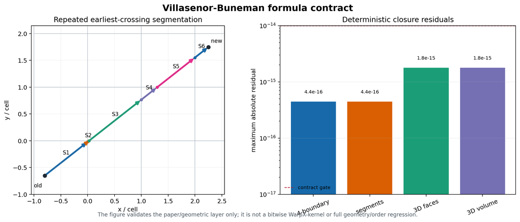

图 5-1：Villasenor 公式合同的两层证据。左侧把一条跨越多个 cell 的轨迹按 earliest crossing 切成局部 segment；右侧汇总四边界、segment、3D face 和 3D volume closure 的最大残差。该图只展示论文/几何层闭合，不把它升级为 WarpX kernel 等价或全 geometry/order 回归。

在公式审计之外，本轮又对当前 `../warpx` checkout 做了只读源码合同核对。`scripts/audit_villasenor_source_contract.py` 的 16 个锚点全部通过，覆盖 `VillasenorDepositionShapeNKernel`、explicit/implicit entrypoint、三方向 `cell_crossings_*` 计数、`num_segments` 循环、final-segment/continuation 分支、`seg_factor_*` 和 `this_Jx/this_Jy/this_Jz` 写回。报告位于 `runs/stage-c-validation/villasenor-source-contract/contract.{json,md}`；它说明正文中的 crossing-driven segment skeleton 与当前源码仍一致，但仍不替代数值 kernel regression。

本轮又把 implicit Villasenor 从源码和公式层推进到官方 2-rank 运行级证据。官方 `test_2d_theta_implicit_jfnk_vandb` 使用 `shape=2`、周期边界和 theta-implicit Newton/JFNK；上游 `analysis_vandb_jfnk_2d.py` 与独立 `scripts/analyze_implicit_villasenor_contract.py` 均通过，最大总能量相对变化为 `4.0980e-15 < 2e-14`，Gauss-law RMS 为 `9.2951e-16 < 2e-15`，末态网格为 `40x40`，所有输出字段有限。报告归档于 `runs/stage-c-validation/implicit_villasenor_2d_jfnk_mpi2/contract.{json,md}`。

同一条独立 contract 又读取官方 `test_2d_theta_implicit_jfnk_vandb_cropping`：该 sibling 把 shape 提升到 `4`、网格缩小到 `16x16`，并打开 near-boundary cropping；官方 analysis 与独立读取均通过，末态 Gauss-law 最大绝对误差为 `8.2275e-14 < 1e-13`，RMS 为 `3.0023e-14`。这两条结果可以支持“2D implicit Villasenor 的普通 shape=2 路径和 shape=4 boundary-cropping 路径均有运行级守恒证据”，但不能外推到所有 geometry/order。

同一 family 的 `test_2d_theta_implicit_jfnk_vandb_filtered` 只把 `warpx.use_filter` 打开为 `1`，保留 `shape=2`、周期边界和 JFNK 配置不变。官方 analysis 与要求显式确认 filter 输入的独立 contract 均通过：最大总能量相对变化 `3.8931e-15 < 2e-14`，Gauss-law RMS `5.1401e-16 < 2e-15`，且末态字段全部 finite。于是当前 2D 证据不只覆盖“Villasenor 能守恒”，还覆盖了 implicit current 同步之后再经过 field filter 的组合路径。

官方 `test_2d_theta_implicit_jfnk_vandb_picmi` 又提供了同一物理合同的 Python 前端路径。项目使用 Python-enabled `build_py` 的 `pywarpx.picmi` 运行 2-rank 输入脚本；PICMI 生成的 `inputs2d_from_PICMI` 和最终 `warpx_used_inputs` 均明确包含 `algo.current_deposition = "villasenor"`、`algo.evolve_scheme = "theta_implicit_em"` 与 `algo.particle_shape = 2`。官方输入脚本 producer 与独立 contract 均完成，最大总能量相对变化 `4.0980e-15 < 2e-14`，Gauss-law RMS `9.5730e-16 < 2e-15`，末态字段全部 finite。该运行日志还出现 `newton.liner_solver` unused-input 提示；它来自 PICMI 生成配置的拼写边界，不影响本次由 `GMRESLinearSolver` materialize 的实际运行，但不能把该 warning 误写成前端完全无 unused-input。

维度边界也必须如实记录：官方 RZ theta-implicit Villasenor 输入要求 `newton.linear_solver=petsc_ksp`，当前 `build_full` binary 未启用 `AMREX_USE_PETSC`，因此在 `NewtonSolver::Define()` 初始化阶段直接拒绝，未进入物理计算。随后只用命令行把同一输入的线性求解器覆盖为 `amrex_gmres` 做 control；它仍未进入物理时间推进，而是在 `WarpX::InitData() -> ThetaImplicitEM::Define() -> InitializeCurlCurlBCMasks()` 触发 `SIGILL`。因此当前 RZ blocker 不只是 PETSc 缺失，还包含 arm64 `build_full` 的 RZ theta-implicit boundary-mask 初始化失败。官方 1D planar-pinch sibling 则在 Newton 后的粒子边界处理路径出现 `SIGILL`，只落出初始诊断帧。三者均记录为构建/运行边界，而不是伪造为 Villasenor physics failure 或 pass。

| 运行级 case | 主要分支 | 独立结果 | 证据边界 |
| --- | --- | --- | --- |
| `test_2d_theta_implicit_jfnk_vandb` | 2D、shape=2、周期、energy + Gauss law | `4.0980e-15` energy、`9.2951e-16` Gauss RMS，PASS | 官方 + independent，2-rank |
| `test_2d_theta_implicit_jfnk_vandb_cropping` | 2D、shape=4、near-boundary cropping | `8.2275e-14` max charge error，PASS | 官方 + independent，未含强 energy ledger |
| `test_2d_theta_implicit_jfnk_vandb_filtered` | 2D、shape=2、`warpx.use_filter=1` | `3.8931e-15` energy、`5.1401e-16` Gauss RMS，PASS | 官方 + independent，显式确认 filter 输入 |
| `test_2d_theta_implicit_jfnk_vandb_picmi` | 2D PICMI、shape=2、Python `GMRESLinearSolver` | `4.0980e-15` energy、`9.5730e-16` Gauss RMS，PASS | Python-enabled build，保留 unused-input warning |
| `test_rz_theta_implicit_dynamic_pinch` | RZ、shape=2、axis/insulator | PETSc 官方路径在 `NewtonSolver::Define()` 拒绝；`amrex_gmres` control 在 `InitializeCurlCurlBCMasks()` `SIGILL` | 未进入物理计算 |
| `test_1d_theta_implicit_planar_pinch` | 1D、shape=2、planar pinch | Newton 后 `SIGILL`，仅初始帧 | 不作为通过证据 |

### 5.11.3 Esirkepov 运行级维度证据：1D、2D 与 3D Langmuir

前面的公式恒等式和源码合同只能证明局部结构；为了避免把它们误写成端到端证据，本轮又直接运行了 WarpX 官方 Langmuir 输入。官方 1D 和 3D 输入本身显式设置 `algo.current_deposition = esirkepov`；官方 2D 测试卡默认是 `direct`，本项目在 case-local 副本中只将这一项覆盖为 `esirkepov`，并补上官方 analysis 所需的 `rho/divE` 输出字段，因此它是可复查的验证 sibling，而不是 WarpX 上游已注册的 2D Esirkepov regression。

两条运行都使用当前 checkout 对应的 native binary、2 个 MPI rank 和 `OMP_NUM_THREADS=1`。官方 analysis 负责理论 Langmuir 场误差与其内置 charge-conservation gate；项目独立的 `scripts/analyze_esirkepov_langmuir_contract.py` 则重新读取最终 plotfile，检查 `Ex/Ey/Ez/Bx/By/Bz/jx/jy/jz/rho/divE` 的有限性，并独立计算

$$\epsilon_{\mathrm{charge}}
=
\frac{\|\mathrm{divE}-\rho/\epsilon_0\|_\infty}
{\|\rho/\epsilon_0\|_\infty}.$$

结果如下：

| case-local 证据 | 维度/网格 | 官方理论场 gate | 独立 charge gate | 结论 |
| --- | --- | --- | --- | --- |
| `runs/stage-c-validation/esirkepov_langmuir_1d_mpi2/` | 1D，`128x1x1`，shape 1 | `1.7028e-3 < 0.05` | `8.3450e-12 < 1e-11` | PASS |
| `runs/stage-c-validation/esirkepov_langmuir_2d_mpi2/` | 2D，`128x128x1`，shape 1 | `1.2201e-2 < 0.0503` | `3.5650e-12 < 1e-11` | PASS |
| `runs/stage-c-validation/esirkepov_langmuir_2d_shape2_mpi2/` | 2D，`128x128x1`，shape 2 | `3.4096e-2 < 0.0503` | `3.1326e-12 < 1e-11` | PASS |
| `runs/stage-c-validation/esirkepov_langmuir_2d_shape3_mpi2/` | 2D，`128x128x1`，shape 3 | `4.6336e-2 < 0.0503` | `4.5607e-12 < 1e-11` | PASS |
| `runs/stage-c-validation/esirkepov_langmuir_2d_particle_shape_4_mpi2/` | 2D，`128x128x1`，shape 4 | `6.0165e-2 < 0.07` | `2.8977e-12 < 1e-11` | PASS |
| `runs/stage-c-validation/esirkepov_langmuir_3d_mpi2/` | 3D，`64x64x64`，shape 1 | `3.4040e-2 < 0.05` | `1.3029e-12 < 1e-11` | PASS |
| `runs/stage-c-validation/esirkepov_langmuir_2d_mr_mpi2/` | 2D MR，`max_level=1`、ratio 4、CKC/filter | `3.8068e-2 < 0.0503` | L0 `0.8828`、L1 `1.2005` | BOUNDARY |

这些证据把第 5 章的 Esirkepov 运行覆盖推进到 **1D/2D/3D + 2D shape=1/2/3/4 + 3D shape=1/2/3/4**。2D shape=4 的 `0.07` 场误差阈值来自官方 `analysis_2d.py` 对测试名中 `particle_shape_4` 的分支，而不是本项目临时放宽；2D shape=1/2/3 仍使用 `0.0503`，3D shape=1/2/3/4 使用官方 `0.05` field gate，所有 shape 都使用独立 `1e-11` charge residual gate。3D shape=2 的 field error 为 `3.5970e-2` 并通过；shape=3/4 在 `64^3` 的 field error 为 `6.7792e-2/8.7344e-2`，但同一输入的 `128^3` refined sibling 降至 `2.3515e-2/3.0644e-2` 并通过 field gate，charge residual 分别为 `4.3288e-12/3.0001e-12`。因此当前最准确的表述是：shape=3/4 的低分辨率 field boundary 具有分辨率敏感性，尚不足以包装成正式 convergence order。shape=0 的尝试在当前 `WarpX.cpp:1450` 初始化断言处拒绝，源码合同只允许 `particle_shape=1..4`，因此记录为 unsupported boundary，而不是失败的 physics case。MR overlay 的理论场 gate通过，但逐层 reader contract 在 L0/L1 分别得到 `0.8828/1.2005`，故当前只标记为 `BOUNDARY`，不把它升级成 AMR 守恒通过；新增的 15-anchor AMR source contract 已证明路由/同步源码骨架存在，新增的 7-anchor Python observability audit 也证明 generic register API 存在，但两者都不能替代中间场与 route-count 专门验证。当前 1–4 阶运行证据仍不能推出 AMR buffer、边界裁剪、RZ/RCYLINDER/RSPHERE 或 implicit 分支都已逐项等价，也不能替代尚未取得的 CPC publisher-PDF bounded compare。2D case 的 `direct -> esirkepov` 覆盖和 `rho/divE` 诊断字段只存在于本项目 case-local 输入副本中，不能写成上游官方注册回归；3D shape=2/3/4 及 refined siblings 也是 case-local override，不改变上游测试注册。独立 contract 的 JSON/Markdown 结果分别归档在各 case-local 目录中，汇总见 `runs/stage-c-validation/esirkepov_langmuir_3d_shape-matrix/contract.{json,md}`。

本版又补入 shape=2 的 `128^3` refined sibling：field error 为 `1.2523e-2`，charge residual 为 `5.4174e-12`，同样通过双 gate。三种 shape 的 refined controls 均通过，但这仍是 case-local 分辨率证据，不足以包装成正式 convergence order。

## 5.12 沉积不只回 `rho/J`：WarpX 还把线性响应矩阵和统计矩交回网格

如果只盯 `DepositCharge()` 和 `DepositCurrent()`，会把本章的边界讲窄。WarpX 里至少还有两条同样属于 particle-to-grid deposition 的源项支线：

1. **mass matrices deposition**
   - 服务 implicit/JFNK 的线性化电流响应；
   - 不是 Maxwell 方程这一时间步要直接消费的 `current_fp`。
2. **temperature / variance deposition**
   - 服务 per-species 温度和速度方差统计；
   - 不是 `rho/J` 的附属输出，而是一条独立的 weighted-moment deposition 主线。

这三条线共享同一套 particle-to-grid 工程骨架：

- shape order
- tilebox / buffer
- guard-cell 安全检查
- boundary sum / fill-boundary

但物理语义不同。

### 5.12.1 mass matrices：沉的是 `J(E)` 的线性响应，不是当前步的 Maxwell 源项

`MultiParticleContainer::DepositMassMatrices()` 会先把

- `MassMatrices_X`
- `MassMatrices_Y`
- `MassMatrices_Z`

三组方向块清零，再逐 species 调 `pc->DepositMassMatrices(fields, lev, dt)`。源码见 `../warpx/Source/Particles/MultiParticleContainer.cpp:617-629`。

species 级的 `PhysicalParticleContainer::DepositMassMatrices()` 则取：

- `Bfield_aux`
- 九个矩阵块 `Sxx..Szz`

再调用 `WarpXParticleContainer::DepositMassMatrices(...)`，源码见 `../warpx/Source/Particles/PhysicalParticleContainer.cpp:828-883`。

因此这条线的第一性对象不是

$$\rho,\qquad \mathbf J,$$

而是 implicit 线性化里近似

$$\mathbf J(\mathbf E)\approx \mathbf J_0 + \mathbf M(\mathbf E-\mathbf
E_0)$$

所需的粒子响应块。也正因为它不是普通 current deposition 的平移版，源码一开始就拒绝：

- `Esirkepov`
- `Vay`
- collocated grid

只保留：

- `Villasenor`
- `Direct`

两条 mass-matrix deposition 路径，见 `../warpx/Source/Particles/WarpXParticleContainer.cpp:1131-1365`。

### 5.12.2 temperature / variance deposition：沉的是样本数、加权均值和去均值二次矩

species 打开 `do_temperature_deposition` 后，`PhysicalParticleContainer::AllocData()` 会按 `current_fp` 的 box/stagger/guard 规格额外分配 `T_<species>` 三个方向场，并创建 `VarianceAccumulationBuffer`。源码见 `../warpx/Source/Particles/PhysicalParticleContainer.cpp:363-387`。

真正的多物种入口不在主 `Evolve()` 里，而是 `MultiParticleContainer::DepositTemperatures()`：

1. 找出 `T_<species>`；
2. 清零；
3. 调 `pc->AccumulateVelocitiesAndComputeTemperature(T_vf, relative_time)`；

见 `../warpx/Source/Particles/MultiParticleContainer.cpp:645-670`。

这条线的工作前提也比普通 `J` 沉积更窄。`DepositTemperature()` 直接要求：

- `current_deposition_algo == Direct`
- `push_type == Explicit`
- 关闭 shared-memory current deposition

否则 abort，见 `../warpx/Source/Particles/PhysicalParticleContainer.cpp:1844-1858`。

内部统计对象不是 “直接沉温度”，而是：

- `n`
- `w`
- `wv`
- `w(v-\bar v)^2`

更具体地，当前实现硬编码走 `DOUBLE_PASS`：

1. 第一遍沉 sample count、权重和、加权速度和；
2. boundary sum；
3. 第二遍用第一遍得到的 `\bar v` 再沉去均值二次矩；
4. 再按
   $$\mathrm{var} = \frac{n}{(n-1)\sum w}\sum w(v-\bar v)^2$$
   做 unbiased normalization；
5. 最后乘 `m/k_B` 变成 Kelvin。

源码位置：

- `../warpx/Source/Particles/PhysicalParticleContainer.cpp:1982-2188`
- `../warpx/Source/Particles/Deposition/TemperatureDeposition.H:25-115`
- `../warpx/Source/Particles/Deposition/VarianceAccumulationBuffer.cpp:79-118`

因此，这条温度沉积主线更准确地说是：

- particle-to-grid weighted-moment deposition
- 再经过 boundary sum / filter / 归一化
- 最后得到 `T_x/T_y/T_z`

而不是 “顺手从 `J` 推一个温度”。

### 5.12.3 这一节回头修正了本章的总边界

到这里，本章里 “粒子把东西交回网格” 至少已经分成三类：

1. `rho/J`
   - 服务 Maxwell 源项与离散连续性；
2. `MassMatrices_*`
   - 服务 implicit/JFNK 的线性响应近似；
3. `T_<species>` / variance buffers
   - 服务统计矩和温度 diagnostics。

它们的共同点是都共享 shape、tilebox、guard-cell 和 boundary-sum 的 deposition 工程骨架；不同点是物理语义完全不同。

## 5.13 沉积后为什么还要同步

沉积 kernel 只把粒子贡献放到本地数组、tile、本 level 或 buffer 中。它还不能保证场求解器马上可以使用这些源项。主循环在 `../warpx/Source/Evolve/WarpXEvolve.cpp:555-561` 调 `SyncCurrentAndRho()`，源码注释直接把它定义成：

- filter
- exchange guard cells
- interpolate across MR levels
- apply boundary conditions

但如果只停在这句注释，本章会把真正的 source-synchronization 合同讲窄。更准确的分层如下。

### 5.13.1 `PSATD` 与 `FDTD` 的同步时序不同

`SyncCurrentAndRho()` 位于 `../warpx/Source/Evolve/WarpXEvolve.cpp:768-837`。

- `PSATD + periodic single box`
  - 即使启用了 `current correction` 或 `Vay deposition`，也立即同步；
  - 若是 Vay，则同步的名字就是 `current_fp_vay`，不是 `current_fp`。
- `PSATD + 非 periodic single box`
  - 只有在
    - 没开 `current_correction`
    - 且不是 `Vay deposition` 时才立刻 `SyncCurrent("current_fp") + SyncRho()`；
  - 否则把更完整的同步推迟到 `PushPSATD`。
- `FDTD`
  - 直接 `SyncCurrent("current_fp") + SyncRho()`。

因此 source synchronization 的时序本身就是 solver-algorithm contract 的一部分，不是沉积后永远立刻做的固定尾声。

这里还有一条容易被一句话摘要吃掉的实现边界：`PSATD + 非 periodic single box + Vay deposition` 并不是“什么都不做，等后面统一处理”，而是会先对 `current_fp_vay` 单独做 filter，而且当前源码旁边直接留着注释：

```cpp
// TODO This works only without mesh refinement
```

也就是说，`current_fp_vay` 在这条分支里当前仍带着“只假定无 MR”的现实边界。对第 5 章来说，这一点很重要，因为它说明 source synchronization 不只受 Maxwell solver 与 deposition algorithm 影响，还受当前实现是否已经覆盖 AMR 组合情形影响。

### 5.13.2 `SyncCurrent()` 的骨架：coarsen、buffer、owner mask、filter、SumBoundary

`SyncCurrent()` 的底层在 `../warpx/Source/Parallelization/WarpXComm.cpp:1174-1376`。

它的关键结构不是一句 “通信电流”，而是：

1. 若开 `do_current_centering`
   - 先把 `current_fp_nodal` 中心化回 staggered `current_fp`。
2. finest-to-coarsest 迭代
   - 先把未过滤、未求和的 `J_fp` coarsen 成 `J_cp`。
3. 若有 `current_buf`
   - 先把 `J_cp` 加到 buffer，再统一作为跨 level 的通信源。
4. coarse level 接收 finer 源项时
   - 先 `ParallelAdd` 到临时 `fine_lev_cp`
   - 再用 `OwnerMask(...)` 去掉 nodal overlap / periodic overlap 的 double counting
   - 然后才并入本 level `J_fp`
5. 最后对每个 level 再做：
   - `ApplyFilterMF(...)`
   - `SumBoundaryJ(...)`

这里尤其要注意 owner-mask 这一步：它说明 fine-to-coarse 源项并不能直接并进当前 level `J_fp`，否则 nodal overlap 点会被重复加两次。

这里可以把源码里的三个中间对象明确分开：

1. `J_cp`
   - 表示当前 fine level 先 coarsen 下来的 coarse representation；
2. `mf_comm`
   - 表示“这一轮真正要跨 level 发送的源项”；
   - 若存在 `current_buf`，它其实 alias 到 `J_buffer`，也就是“buffer + coarsened current”的合并体；
   - 若不存在 `current_buf`，才直接等于 `J_cp`；
3. `fine_lev_cp`
   - 表示 coarse level 接收完 fine 源项后的临时落点；
   - 它不是最终要保留的场，而只是为了在并回 `J_fp` 之前先做 owner-mask 去重。

这层区分很重要，因为它说明 WarpX 的 fine/coarse 同步并不是“fine 直接往 coarse 主场里加一遍”，而是：

```
J_fp(fine)
  -> coarsen 成 J_cp
  -> 若有 current_buf 则先并进 buffer，得到 mf_comm
  -> ParallelAdd 到 coarse 侧临时 fine_lev_cp
  -> 用 OwnerMask 去重
  -> 再并回 coarse 的 J_fp
```

只有这样，coarse-fine transition zone 和 nodal/periodic overlap 才不会在同一张 coarse 主场上被重复计数。

这里还有一个容易被“通信电流”四个字掩盖掉的结构：如果打开 `do_current_centering`，`SyncCurrent()` 的第一步并不是通信，而是先把 `current_fp_nodal` 中心化回 staggered `current_fp`。也就是说，某些 current 甚至在同层 box 间求和之前，都还没有处在 field solver 最终消费的 staggering 上。对成书叙述来说，这比简单说“同步后电流可用”更准确，因为它明确区分了：

1. nodal/staggered 源项重排；
2. same-level / fine-coarse 一致性；
3. filter 与 guard-cell 求和；
4. 边界条件。

`SyncCurrent()` 的最后一步也不只是“把所有 ghost cells 累加一遍”。`SumBoundaryJ()` 会先从 `get_ng_depos_J()` 出发，再叠加 current centering 与 bilinear filter 真正需要的 stencil 宽度，最后只对那部分 guard region 做 `WarpXSumGuardCells(...)`。因此这里的 same-level 同步范围并不是整个 `nGrow`，而是“沉积和后续 filter 真正需要的最小安全区”。

### 5.13.3 `SyncRho()` 平行但不完全等于 `SyncCurrent()`

`SyncRho()` 位于 `../warpx/Source/Parallelization/WarpXComm.cpp:1385-1451`，其高层结构和平行于 `SyncCurrent()`：

1. `rho_fp -> rho_cp` coarsen；
2. 若有 `rho_buf`，先和 `rho_cp` 合并；
3. coarse level 也通过临时 `fine_lev_cp + OwnerMask` 去重后再并回 `rho_fp`；
4. 最后对每个 level 调 `ApplyFilterandSumBoundaryRho(...)`。

但它和 current 不完全相同：

- 没有 `do_current_centering`
- 过滤和求和由 `ApplyFilterandSumBoundaryRho(...)` 统一处理

后者在 `../warpx/Source/Parallelization/WarpXComm.cpp:1677-1692` 中：

- 若 `use_filter`
  - 先把 filtered `rho` 写进临时 `rf`
  - 再用 `WarpXSumGuardCells(rho, rf, ...)` 把 filtered 值并回
- 否则直接 `WarpXSumGuardCells(rho, ...)`

所以 `SyncCurrent()` 与 `SyncRho()` 虽然共享 fine/coarse + buffer + owner-mask 的大骨架，但具体 filter/sum 实现并不一样。

更进一步说，`rho` 这条线比 `current` 少了一层 staggering 重排，但并没有因此退化成“更简单的数组相加”。`ApplyFilterandSumBoundaryRho(...)` 先决定是否需要构造 filtered 临时 `rf`，然后再用 `WarpXSumGuardCells(...)` 把 filtered 或 unfiltered 结果合并回去。也就是说，`rho` 的 source synchronization 也同样把“物理要不要 filter”写进了同步合同本身，而不是在同步完成后再额外修饰。

`rho` 路径里也有和 current 完全平行的“临时接收层”问题：fine level 传下来的 `rho_cp` 或 `rho_buf + rho_cp` 并不是直接加回 coarse `rho_fp`，而是同样先落到临时 `fine_lev_cp`，再通过 `OwnerMask(...)` 选出 coarse patch 上真正该保留的那一份。也就是说，fine/coarse 去重并不是 current 独有技巧，而是 source synchronization 对所有守恒源项都共享的一条骨架。

### 5.13.4 `SyncCurrentAndRho()` 的最后一步其实是边界条件

顶层同步完成后，`SyncCurrentAndRho()` 还会继续对：

- fine patch 的 `rho_fp/current_fp`
- coarse patch 的 `rho_cp/current_cp`

调用：

- `ApplyRhofieldBoundary(...)`
- `ApplyJfieldBoundary(...)`

源码见 `../warpx/Source/Evolve/WarpXEvolve.cpp:815-836`。

因此这条函数的完整职责不是：

- “做完 guard-cell 通信就结束”

更准确地说，这里调用的也不是抽象的“边界后处理”。`WarpXEvolve.cpp` 在注释里直接写的是：

- `Reflect charge and current density over PEC boundaries, if needed.`

而 `../warpx/Source/BoundaryConditions/WarpX_PEC.H` 又把底层语义钉得更死：

- `ApplyReflectiveBoundarytoRhofield(...)`：把沉积到 `PEC` 外侧的电荷密度反射回计算域；
- `ApplyReflectiveBoundarytoJfield(...)`：把沉积到 `PEC` 外侧的电流密度反射回计算域。

这意味着 `ApplyRhofieldBoundary(...)` / `ApplyJfieldBoundary(...)` 在 source synchronization 里承担的不是“最后顺手修一下边界层”，而是把已经完成 same-level 求和、fine/coarse 合并、filter 和 `OwnerMask` 去重后的源项，再按实际场边界几何物化成可供 Maxwell solver 消费的 patch-local `rho/J`。如果边界是 `PEC`，那一步会把落到导体外侧或 guard 区的沉积量，按镜像位置与分量符号规则折回域内；如果不是需要反射的边界，则这里才退化成相对平直的 boundary pass。

还有一个容易被一句话略过的实现点：WarpX 并不是只对 fine patch 做这件事，而是按 patch 类型分别处理：

- level `lev` 上始终对 fine patch 的 `rho_fp/current_fp` 调 `PatchType::fine`
- 当 `lev > 0` 时，再对 coarse patch 的 `rho_cp/current_cp` 调 `PatchType::coarse`

也就是说，source synchronization 的终点不是“得到一份全局一致的守恒源项”，而是“得到 fine/coarse 两套都已经与边界条件相容的源项 MultiFab”。这对后面的场推进很关键，因为 solver 消费的是 patch-local `rho/J`，不是一个抽象的、尚未带边界语义的守恒和。

而是：

1. solver/algorithm 条件分叉；
2. same-level 与 fine/coarse 源项同步；
3. filter；
4. boundary reflection / mirror / PEC-compatibility。

所以完整源项路径更准确地写成：

```
particle trajectory
  -> tile-level charge/current deposition
  -> species sum
  -> MultiFab/local or buffer accumulation
  -> filter / guard-cell exchange / AMR synchronization
  -> boundary conditions
  -> field solver
```

漏掉：

- owner-mask 去重、
- fine/coarse buffer 合并、
- filter 的时序、
- 或最后的 `ApplyRhofieldBoundary/ApplyJfieldBoundary`

都会把 WarpX 的 source synchronization 合同讲错。

### 5.13.5 本章对应的两条关键 regression，分别在验证哪一层 source-synchronization 合同

到这里，source synchronization 的源码主链已经闭合；对应的本地 regression 也可以更明确地挂回这条链，而不只当成零散 smoke test。

第一条是 `Examples/Tests/langmuir/` 里的 `PSATD + current_correction` 变体。它不是只看 `divE-\rho/\epsilon_0`，而是两层断言同时成立：

1. `Ex/Ey/Ez` 或 `Ex/Ez` 仍要和解析 Langmuir-wave 场解匹配；
2. `analysis_utils.py` 在 `current_correction` 路径下还会追加 `divE-\rho/\epsilon_0` 检查，容差固定放宽到 `1e-9`。

因此它验证的不是“某个 deposition kernel 单独正确”，而是：

- `Esirkepov deposition`
- `PSATD current correction`
- 立即同步后的源项一致性

这三层组合后，解析波解和离散 Gauss law 都没有被破坏。

第二条是 `Examples/Tests/vay_deposition/`。这组测试更窄，也更直接：它不再对照解析波，只断言

$$\frac{\max | \nabla\cdot E - \rho/\epsilon_0 |}{\max |\rho/\epsilon_0|}
< 10^{-3}.$$

在当前输入里，这条断言专门落在

- `algo.current_deposition = vay`
- `algo.maxwell_solver = psatd`
- `warpx.grid_type = collocated`

这组实现边界上。结合 `SyncCurrentAndRho()` 的源码分叉，`vay_deposition` 真正测到的是：`current_fp_vay` 在 filter-first、后续再交给 PSATD 同步链的专门路径里，最终是否仍能保住离散 Gauss law。

所以对本章来说，这两组 regression 的职责应分开理解：

- `Langmuir + current_correction`
  - 更宽，测 `physics solution + source consistency`；
- `vay_deposition`
  - 更窄，测 `specialized source-synchronization path` 本身。

这样第 5 章的验证闭环就不再只是“有些测试目录可以参考”，而是已经能说清：哪一条 regression 在替本章的哪一层 source contract 做断言。

## 5.14 形函数、guard cells 与稳定性

更高阶 shape 会影响三个方面：

1. gather/deposition stencil 更宽，需要更多 guard cells；
2. 粒子噪声降低，但局部性和通信成本增加；
3. 在边界、AMR coarse-fine interface、PML 和 embedded boundary 附近，shape 的截断或修正会影响守恒。

源码中 current deposition 和 charge deposition 都会检查 shape 是否能放进 guard cells。例如 current deposition 在 `WarpXParticleContainer.cpp:416-446` 计算 `shape_extent` 和 `range`；shared-memory charge deposition 在 `WarpXParticleContainer.cpp:1527-1556` 做类似检查，普通 charge deposition 则经 `Source/ablastr/particles/DepositCharge.H` 的桥接路径处理本地 tile 与 guard 区。这些检查不是性能细节，而是物理离散化安全条件。

| 路径 | 源码覆盖 | 当前运行证据 | 仍未关闭的边界 |
| --- | --- | --- | --- |
| `DepositCharge()` ordinary/shared | 1D_Z、XZ、RZ、RCYLINDER、RSPHERE、3D；shape 1/2/3/4 | 1D/2D/3D charge/Gauss-law siblings；2D shape 1/2/3/4；RZ charge/inverse-volume | RCYLINDER/RSPHERE 的逐阶 charge/Gauss-law runtime 矩阵仍不完整 |
| Direct current | 1D_Z、XZ、RZ、RCYLINDER、RSPHERE、3D；shape 1/2/3/4；implicit 入口 | 既有 Langmuir、Vay/Direct 相关回归和源码 contract | 不能据此推出所有几何、边界裁剪和 implicit 组合等价 |
| Esirkepov | shape 1/2/3/4；显式与 implicit skeleton | 1D/2D/3D Langmuir；2D shape 1/2/3/4；RCYLINDER/RSPHERE shape 1/2/3/4 径向 `Er` 与 `rho/divE` 观测；RZ `Er/Ez` field PASS；2D MR 为 `BOUNDARY` | RZ charge residual 为 `BOUNDARY`；RCYLINDER/RSPHERE 径向 charge shape=1/2/3/4 均为 `BOUNDARY`；完整 AMR route-count 仍未形成强 runtime 闭环 |
| Villasenor | shape 1/2/3/4；显式与 implicit skeleton | 2D implicit native、filtered、shape=4 cropping、PICMI；公式级 contract | RZ 因 PETSc/build 边界未形成运行级证据，其他几何/阶数组合仍需逐项核对 |
| Vay | shape 1/2/3/4 | 既有 `vay_deposition` regression | 几何与边界裁剪的全组合覆盖仍未完成 |

RZ + Esirkepov 还需要单独保留一个诊断边界：当前 2-rank case 的 `Er/Ez` field contract 通过，但同面 `divE-rho/epsilon0` residual 为 `3.593e-3`，而官方 `analysis_utils.py` 本来也明确跳过 RZ Esirkepov 的强 charge gate。原因不能简单归结为“kernel 已经错误”：`DivEFunctor` 与 `RhoFunctor` 分别从场求解器和重新沉积的 charge density 构造诊断量，再经过各自的 node/cell、mode 与插值路径。完整源码语义与可复现命令见 `notes/code-reading/particles/46-rz-esirkepov-charge-boundary.md`；本书将其标为 `BOUNDARY`，不把 field PASS 升级为守恒 PASS。

同一条证据又做了 `warpx.do_dive_cleaning=1/0` 的 paired control：全局 charge residual 从 `3.593e-3` 增至 `9.693e-2`，约为 `26.98` 倍；第一径向 cell 之外的 residual 则为 `4.293e-4/6.540e-12`。两个 case 的全局最大值都由 axis cell 主导，`Er/Ez` field error 也改变为 `2.427e-2/4.941e-3`。这说明边界同时对 axis treatment 和 cleaning 路径敏感，但不能据此把 cleaning 认定为唯一根因；比较结果归档为 `AXIS_DOMINATED_CLEANING_SENSITIVE_DIAGNOSTIC_BOUNDARY`。

进一步只切换 `boundary.verboncoeur_axis_correction`：在 `64x128`、`particle_shape=1` case 中，开启时 charge residual 为 `3.593e-3`，关闭时降为 `5.513e-12`，且 off-axis residual 为 `1.720e-12`；两者 `Er/Ez` field error 都低于 `0.12`。因此这个 shape=1 case-local control 可以恢复双 gate，但不足以要求修改 WarpX 默认值；完整低分辨率对照和参数语义见 `notes/code-reading/particles/46-rz-esirkepov-charge-boundary.md`。

在默认轴修正保持开启的条件下，RZ Esirkepov Langmuir 的 shape=1/2/3/4 field runtime coverage 也已补齐：`Er` 最大相对误差分别为 `1.075e-2/5.703e-2/8.694e-2/1.167e-1`，全部低于 `0.12`；对应 charge residual 为 `3.593e-3/4.306e-3/4.341e-3/4.433e-3`，且最大值均由 axis cell 主导。汇总报告见 `runs/stage-c-validation/esirkepov_langmuir_rz_shape-matrix/contract.{json,md}`；因此这里关闭的是 field shape coverage 缺口，不是 RZ charge boundary。

将同样的 shape=2/3/4 case 切换到 `verboncoeur_axis_correction=false` 后，charge residual 降到 `2.202e-12/2.103e-12/2.063e-12`，但 `Er` field error 升到 `0.132/0.173/0.213`，超过 `0.12`。因此轴修正对照不是一个可以全局套用的“修复开关”，而是随 shape 改变的 charge/field tradeoff；矩阵归档于 `runs/stage-c-validation/esirkepov_langmuir_rz_shape-axis-matrix/contract.{json,md}`。

随后把 shape=1 的同一 paired case 加密到 `128x256`：correction-on 的 `Er/Ez` field error 为 `2.797e-2/3.049e-2`，axis charge residual 降至 `1.520e-3`；correction-off 的 `Er/Ez` 为 `2.809e-2/3.662e-2`，charge residual 为 `9.353e-12`，field/charge 双 gate 均通过。进一步加密到 `256x512` 后，correction-on 的 `Er/Ez` 为 `1.236e-2/1.296e-2`、axis charge residual 为 `7.554e-4`；correction-off 的 `Er/Ez` 为 `1.227e-2/1.501e-2`，charge residual 升至 `1.639e-11` 并越过强 gate。三档汇总见 `runs/stage-c-validation/esirkepov_langmuir_rz_resolution-trend/contract.{json,md}`，脚本为 `scripts/summarize_rz_esirkepov_resolution_trend.py`。这组结果支持 correction-on 的 resolution trend，却明确否定了“correction-off 是通用修复”的表述。

同一汇总脚本随后参数化到 shape=2。`64x128` correction-off 的 `Er/Ez` field error 为 `0.1323/1.445e-2`，charge residual 为 `2.202e-12`；加密到 `128x256` 后，correction-off 的 `Er/Ez` 降至 `9.318e-3/7.775e-3`，charge residual 为 `9.644e-12`，field/charge 双 gate 均通过。correction-on 的高分辨率 field error 为 `9.321e-3/5.154e-3`，但 axis charge residual 仍为 `2.177e-3`。因此 shape=2 的 coarse field failure 可以归为分辨率边界，但 correction-on charge boundary 仍未闭合；报告见 `runs/stage-c-validation/esirkepov_langmuir_rz_shape2_axis-resolution-comparison/contract.{json,md}`，详细说明见 `notes/code-reading/particles/53-rz-esirkepov-shape2-resolution-contract.md`。

最后把 correction-off 的相同 resolution 对照扩展到 shape=3/4。三档 coarse `Er` field error 为 `0.1323/0.1734/0.2134`，而 `128x256` refined sibling 降至 `9.318e-3/1.113e-2/1.365e-2`；对应 refined charge residual 为 `9.644e-12/6.086e-12/6.724e-12`，三档 field/charge 双 gate 全部通过。`scripts/summarize_rz_esirkepov_shape_resolution_family.py` 将这三条 case 收成 family contract，报告见 `runs/stage-c-validation/esirkepov_langmuir_rz_shape-resolution-family/contract.{json,md}`。这关闭的是 higher-shape coarse field boundary 的分辨率诊断，不关闭 correction-on axis charge residual，也不外推到其他 geometry、AMR 或 implicit 路径。

最后将 shape=2/3/4 的 correction-on refined siblings 也纳入同一完整矩阵：`Er/Ez` field errors 分别为 `9.321e-3/5.154e-3`、`9.342e-3/6.392e-3` 和 `1.079e-2/7.454e-3`，均通过 `0.12` field gate；但 axis charge residual 仍为 `2.177e-3/2.353e-3/2.552e-3`。相比之下，correction-off refined charge residual 为 `9.644e-12/6.086e-12/6.724e-12`。完整矩阵由 `scripts/summarize_rz_esirkepov_axis_correction_family.py` 生成，报告见 `runs/stage-c-validation/esirkepov_langmuir_rz_axis-correction-family/contract.{json,md}`。因此当前第 5 章可以明确区分：高阶 shape refined field 已闭合，correction-off charge 在 case-local sibling 上闭合，而 correction-on axis charge 仍是独立诊断边界。 最后将 correction-on shape=1/2/3/4 一起推进到 `256x512`：`Er/Ez` field gate 全通过，charge residual 分别为 `7.554e-4/8.990e-4/9.289e-4/9.729e-4`，均由 axis cell 主导。`scripts/summarize_rz_esirkepov_highres_shape_family.py` 将四条 case 收成 `runs/stage-c-validation/esirkepov_langmuir_rz_highres_shape-family/contract.{json,md}`。因此当前第 5 章可以明确区分：RZ 高分辨率 field shape family 已闭合，correction-on axis charge 仍未闭合，且不能从 shape=1 的 resolution trend 外推成完整守恒或默认参数修复。 同一 `256x512` 分辨率下的 correction-off 对照显示：shape=1/2/3/4 的 `Er/Ez` field gate 也全部通过，charge residual 为 `1.639e-11/1.020e-11/8.399e-12/6.669e-12`，只有 shape=3/4 通过 `1e-11`。完整双侧矩阵由 `scripts/summarize_rz_esirkepov_highres_correction_family.py` 生成，报告见 `runs/stage-c-validation/esirkepov_langmuir_rz_highres_correction-family/contract.{json,md}`。因此 correction-off 不是单向修复开关：它在高阶 shape=3/4 上局部闭合 charge，却在 shape=1/2 上保留边界；correction-on 则四阶均保留 axis charge boundary。

本版新增统一的 `scripts/summarize_rz_esirkepov_charge_field_tradeoff.py` 汇总合同，对上述 7 组 RZ 证据做 12 项交叉检查：默认轴修正开启时 field gate 通过而 axis charge 仍为 `BOUNDARY`；关闭轴修正只在局部 sibling 上恢复 charge，不能替代默认配置；cleaning 对照显示 residual 由 axis cell 主导且对诊断路径敏感；更高 shape 与更高分辨率可以改善部分 correction-off case，但不能把它写成全局修复或正式收敛阶。该合同的准确分类是 `RZ_ESIRKEPOV_CHARGE_FIELD_TRADEOFF_SUMMARY_BOUNDARY_DEFAULT_AXIS_CHARGE_UNRESOLVED`，因此本章当前唯一稳健的结论是“field 已有覆盖，charge 仍需保留诊断边界”，而不是修改 WarpX 默认参数。

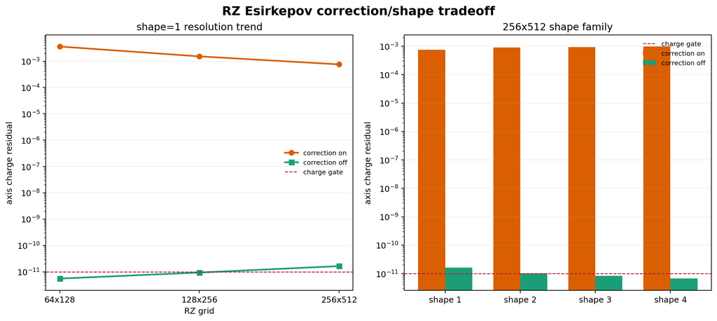

图 5-3：RZ Esirkepov axis-correction/shape tradeoff。左侧是 shape=1 的三档分辨率趋势，右侧是 `256x512` 下 shape=1/2/3/4 的 correction-on/off 对照；红色虚线是 `1e-11` charge gate。所有 field gate 均通过，但 correction-on 的 axis residual 仍约为 `O(1e-3)`，correction-off 的 charge 结果随 shape 变化，不能据此修改全局默认值或宣称正式收敛阶。

为了避免把不同诊断量混成一个结论，v0.47 又对上述 shape=2/3/4 correction-on refined sibling 直接读取 `rho`、`rho_electrons` 和 `rho_ions`。末态 `rho-(rho_electrons+rho_ions)` 的相对差分别为 `1.303e-14/1.228e-14/1.343e-14`，说明 species decomposition 在 rho-side 已达到机器精度；三个 case 的 integrated-rho 时间序列漂移分别为 `2.371e-6/2.729e-6/3.354e-6`，只作为可复核观测记录。这个结果不能替代 `divE-rho`、current closure 或完整 Gauss-law contract：同一批 case 的 axis `divE-rho` residual 仍为 `2.177e-3/2.353e-3/2.552e-3`。脚本为 `scripts/analyze_rz_esirkepov_rho_observable.py`，报告见 `runs/stage-c-validation/esirkepov_langmuir_rz_rho-observable/contract.{json,md}`。

同一诊断也已扩展到 RCYLINDER/RSPHERE shape=1：默认 correction 下 charge residual 为 `4.711e-3/4.166e-2`，关闭后为 `3.505e-12/2.420e-11`。这表明 RCYLINDER 的 axis correction off 可以恢复当前强 gate，而 RSPHERE 虽明显改善仍略超 `1e-11`；两者均不支持直接修改全局默认值，完整对照见 `runs/stage-c-validation/esirkepov_radial_charge_axis-comparison/contract.{json,md}`。

RSPHERE 的 64/128/256 resolution paired control 进一步显示：correction on 的 residual 为 `4.166e-2/1.390e-2/4.142e-3`，correction off 为 `2.420e-11/9.843e-11/7.461e-11`；六个 field gate 都通过，但六个 charge gate 都未闭合。因此这条证据只能说明 axis/resolution 组合敏感，不能替代正式收敛研究或作为全局默认参数修改依据。该组 `256` case 必须使用专用 `warpx.rsphere` executable；若误用 `warpx.3d`，会在 boundary-array parser 阶段失败，不能作为物理结论。

本版将 RCYLINDER/RSPHERE 的 shape=1/2/3/4 case-local siblings 统一纳入 `rho/divE` charge 矩阵。八条径向 `Er` field gate 全通过；RCYLINDER 的 charge residual 为 `4.711e-3/7.442e-3/7.883e-3/8.337e-3`，RSPHERE 为 `4.166e-2/6.269e-2/6.928e-2/8.003e-2`，均高于 `1e-11` 强 gate，且最大值由轴向 cell 主导。该矩阵由 `scripts/summarize_radial_charge_shape_contract.py` 汇总到 `runs/stage-c-validation/esirkepov_radial_charge_shape-matrix/contract.{json,md}`；它关闭的是“径向 shape charge 证据分散”的索引缺口，不把 BOUNDARY 写成 Gauss-law PASS。

这组径向结果的源码合同现在也已单独验收：`scripts/audit_radial_axis_volume_contract.py` 固定了 `boundary.verboncoeur_axis_correction` 的默认值和解析入口，确认 RZ/RCYLINDER 使用 `1/3` 对 `1/4`、RSPHERE 使用 `1/4` 对 `1/8` 的轴体积因子，并确认 `ApplyInverseVolumeScalingToChargeDensity()` 在 `rho_fp` 与 `rho_buf` 路径中的调用时机。因而本节的准确边界是：径向 field shape coverage 已有运行证据，charge residual 的轴体积/诊断耦合也有源码映射，但尚未形成跨 geometry、shape、resolution 的统一强守恒合同。

在已有源码分派表之外，还需要一张“证据覆盖表”，因为 geometry、shape/order、AMR、axis correction 和 implicit solver 是相互独立的维度。当前最强的运行级覆盖可压缩为：

| family | geometry | shape/order | 当前证据 | 证据范围 |
| --- | --- | --- | --- | --- |
| Esirkepov | `1D_Z` | 1 | field + charge PASS | Langmuir |
| Esirkepov | `XZ` | 1/2/3/4 | field + charge PASS | 2D Langmuir siblings |
| Esirkepov | `3D` | 1/2/3/4 | `64^3` shape=1/2 field + charge PASS、shape=3/4 field BOUNDARY；`128^3` refined shape=2/3/4 field + charge PASS | Langmuir base + refined controls |
| Esirkepov | `XZ + AMR` | 1 | field PASS；level charge BOUNDARY | 2D MR overlay |
| Esirkepov | `RZ` | 1/2/3/4 | field PASS；correction-on charge BOUNDARY；correction-off refined PASS | axis correction/resolution family |
| Esirkepov | `RCYLINDER/RSPHERE` | 1/2/3/4 | radial `Er` PASS；shape=1/2/3/4 `rho/divE` charge observed but BOUNDARY | 不含完整 charge/Gauss-law |
| Villasenor implicit | `XZ` | 2 | energy + Gauss-law PASS | native/filtered/PICMI siblings |
| Villasenor implicit | `XZ` | 4 | cropping Gauss-law PASS | near-boundary cropping |
| Villasenor implicit | `RZ` | 2 | build/runtime BOUNDARY | 未进入物理计算 |

这张矩阵由 `scripts/summarize_deposition_geometry_order_coverage.py` 从现有 contract/reference 生成，报告见 `runs/stage-c-validation/deposition-geometry-order-coverage-matrix/coverage-matrix.{json,md}`。它明确关闭的是“证据在哪里、证据能支持什么”的索引缺口，不是所有 Cartesian product 的回归缺口。当前仍不能声明：RZ correction-on charge 已闭合、RCYLINDER/RSPHERE 已有完整 charge contract、2D MR 已完成 route-count/intermediate-field 证明、RZ implicit Villasenor 已进入物理计算，或 3D shape=3/4 已形成正式 convergence-order 证明。

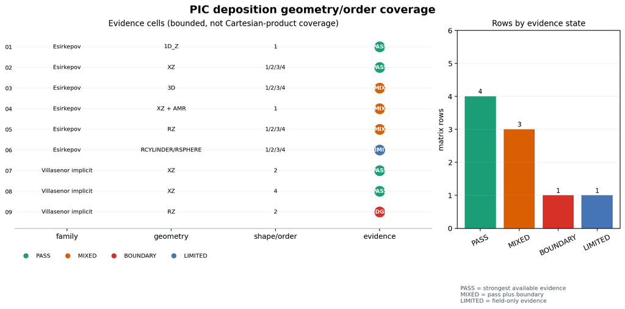

图 5-2：当前 deposition geometry/order 证据矩阵的可视化。`PASS` 表示该行最强可用证据通过，`MIX` 表示同一行同时包含通过项和边界项，`EDGE` 表示构建或运行边界，`LIMIT` 表示只覆盖径向场而非完整 charge/Gauss-law。它展示的是九条证据行，不是完整 geometry × shape/order 的笛卡尔积。

### 5.14.1 正文主张与源码版本的同步合同

本章的源码路径和行号不是静态的“参考链接”，而是必须随当前 WarpX checkout 重新核对的证据边界。为避免正文在源码演进后继续保留看似合理、实际已经漂移的描述，本项目新增 `scripts/audit_deposition_chapter_source_crosswalk.py`，对本节前面反复使用的代表性主张做分组检查：

| 正文层 | 当前源码锚点 | 这项检查能证明什么 | 不能证明什么 |
| --- | --- | --- | --- |
| charge bridge | `WarpXParticleContainer.cpp` 的 `icomp/time_shift_delta/LowerCorner` 与 `deposit_charge` | 旧/新 `rho` 时间层和普通/shared 路径仍有对应入口 | 不证明所有运行时 component 值都正确 |
| ABLASTR bridge | `DepositCharge.H` 的 `depos_lev`、`rel_ref_ratio`、GPU alias、CPU `lockAdd` | 本文对 level 与 CPU/GPU 暂存的说明仍有源码表面 | 不证明 CPU/GPU 数值结果等价 |
| implicit current | `CurrentDeposition.H` 的两条 implicit 入口和 `xp_np1` 重建 | 本文区分“端点恢复”和“共享守恒 kernel”的层次没有漂移 | 不证明 RZ implicit runtime 已通过 |
| Villasenor kernel | `VillasenorDepositionShapeNKernel`、`crop_at_boundary`、`cell_crossings`、`num_segments` | 本文关于 crossing-driven segment loop 的入口仍存在 | 不证明每种 geometry/order 都已运行 |
| shape/geometry | `ShapeFactors.H` 与 `ChargeDeposition.H` 的 helper、shape 和 geometry 分支 | 本文的 shape helper 与 RZ/径向分支指向当前源码 | 不替代 C++ 语义审计或完整笛卡尔积回归 |

该合同当前为 `13/13` 组通过。它的作用是维护“正文-源码”这条线，而不是把 source marker 误写成物理验证；论文 publisher PDF 对照、完整 geometry/order runtime 和 RZ implicit 运行边界仍按前文分类保留。

### 5.14.2 geometry/order coverage gap register

上一张 coverage matrix 解决了“已有证据分布在哪里”，但成书还需要明确记录“哪些组合仍然没有证据”。因此本节新增一份 **negative-space contract**：它只登记已知缺口、当前分类和下一步证据入口，不把缺少 runtime 结果的行写成 PASS。

| 缺口 | 当前分类 | 下一步证据入口 |
| --- | --- | --- |
| RZ 默认 axis correction 下的 charge residual | `BOUNDARY` | 分离 axis-volume 与诊断路径；在证据闭合前不修改默认值 |
| RCYLINDER/RSPHERE 的完整 charge/Gauss-law | `BOUNDARY` | 建立 geometry-specific charge consumer，不能由径向 field PASS 代替 |
| 2D MR transition-zone route-count | `UNPROVEN` | 接入真实 intermediate-field/route ledger；schema fixture 不等于 runtime proof |
| RZ implicit Villasenor | `PRE_PHYSICS_BOUNDARY` | 取得兼容 PETSc/AMReX build 后重跑，不把 `SIGILL` 写成算法失败 |
| Villasenor 非 XZ geometry/order family | `PARTIAL` | 每次增加一个带独立 consumer 的 sibling |
| Vay geometry/order family | `PARTIAL` | 将支持路径与 RZ/1D source guard 分开逐项补证据 |
| 跨 geometry/shape 的正式收敛阶 | `UNPROVEN` | 固定 observable、误差范数和 resolution family 后再做 study |

Vay 这一行现在有了更具体的正向边界。`scripts/audit_vay_geometry_order_wiring.py` 对当前官方测试目录做 `18/18` 项只读核对：`vay_deposition` 提供 2D Cartesian/shape=3 和 3D Cartesian/shape=3 两条 `divE-rho/epsilon_0` analysis + checksum 入口，Langmuir 目录另有 2D/shape=4 sibling；源码同时保留 `doVayDepositionShapeN<1..4>` 分派和 RZ/1D/implicit guard。报告见 `runs/stage-c-validation/vay-geometry-order-wiring/contract.{json,md}`。

这项结果关闭的是“Vay 官方 wiring 没有被统一登记”的索引缺口，分类仍是 `SOURCE_REGRESSION_WIRING_PARTIAL_RUNTIME_FAMILY`：它不等于 Vay 全部 geometry/order 的独立 runtime product，也不等于正式收敛阶。详细边界见 `notes/code-reading/particles/73-vay-geometry-order-wiring-contract.md`。

随后使用当前 `build_full` 的 `warpx.2d`/`warpx.3d` 在 case-local 目录中实际重放两张官方输入卡，并运行官方 `vay_deposition/analysis.py`。单进程 2D `diag1000050` 的 `divE-rho/epsilon_0` 相对误差为 `1.5542590389041434e-4 < 1e-3`，3D `diag1000025` 为 `2.9007226763170857e-4 < 1e-3`；`warpx_used_inputs` 和最终 plotfile 也均通过独立 contract。该结果分类为 `RUNTIME_SINGLE_RANK_OFFICIAL_ANALYSIS_PASS_2D_3D`，证明的是官方 analysis 的单进程 producer/consumer 复现，不把 CMake 要求的 2-rank 回归或完整 geometry/order product 偷换成已完成。详见 `notes/code-reading/particles/74-vay-runtime-consumer-contract.md`。

在此基础上，又对同一组官方 2D/3D Cartesian 输入分别切换 `particle_shape=1/2/3/4`，八个单进程 producer（其中六个为本轮新增 sibling）均写出最终 plotfile，官方 analysis 的 `error_rel` 分别为 2D `1.4635e-4/1.4689e-4/1.5543e-4/1.6473e-4`、3D `2.8824e-4/2.7647e-4/2.9007e-4/3.0592e-4`，全部低于 `1e-3`。该结果分类为 `RUNTIME_SINGLE_RANK_VAY_SHAPE_FAMILY_PASS_2D_3D`，只关闭支持的 Cartesian shape family 单进程证据缺口；shape family 的 2-rank 全组合、AMR、边界裁剪、RZ/1D 和正式收敛阶仍保持边界。详见 `notes/code-reading/particles/75-vay-shape-family-runtime-contract.md`。

随后补做了官方 CMake 注册规模的 2-rank replay：2D 使用 `warpx.numprocs=2 1`，3D 使用 `warpx.numprocs=2 1 1`，最终 `divE-rho/epsilon_0` 相对误差分别为 `4.0411e-4` 和 `6.0266e-4`，均通过 `1e-3` gate。该结果分类为 `RUNTIME_OFFICIAL_CMAKE_SCALE_2RANK_ANALYSIS_PASS_2D_3D`，关闭的是已注册 shape=3 Cartesian case 的 2-rank producer/consumer 缺口；它不外推到 shape family 的 2-rank 全组合、AMR、边界裁剪或正式收敛阶。详见 `notes/code-reading/particles/76-vay-mpi2-runtime-contract.md`。

最后将 shape=1/2/4 的 2-rank sibling 补齐，并与 shape=3 官方 case 合并成 8-case family：2D `error_rel=4.6717e-4/3.8191e-4/4.0411e-4/4.2829e-4`，3D `5.9792e-4/5.7441e-4/6.0266e-4/6.3559e-4`，均低于 `1e-3`。该结果分类为 `RUNTIME_2RANK_VAY_SHAPE_FAMILY_PASS_2D_3D_CASE_LOCAL`，关闭的是 Cartesian shape=1..4 的两进程 case-local family 缺口；shape=1/2/4 尚未成为上游 CMake 注册项，AMR、边界裁剪、RZ/1D、非 Cartesian geometry 和正式收敛阶仍保持边界。详见 `notes/code-reading/particles/77-vay-mpi2-shape-family-contract.md`。

AMR 边界则不能按同一方式继续外推。当前 `Source/WarpX.cpp` 在初始化阶段对 `Vay && maxLevel() > 0` 直接触发 `Vay deposition not implemented with mesh refinement`，并另有 PSATD-only、RZ 和 1D guard。因此这里的准确结论不是“Vay AMR runtime 失败”，而是“当前 checkout 在进入物理推进前显式拒绝 Vay + mesh refinement”；该源码边界由 `scripts/audit_vay_amr_guard_contract.py` 固化为 `SOURCE_GUARD_AMR_RUNTIME_INTENTIONALLY_REJECTED`。详见 `notes/code-reading/particles/78-vay-amr-guard-contract.md`。

维护台账见 `notes/code-reading/particles/72-deposition-geometry-order-gap-register.md`，由 `scripts/audit_deposition_geometry_order_gap_register.py` 验收。它关闭的是“缺口没有统一、可复核登记”的文档缺陷，不关闭上表中的物理或运行级缺口。

## 5.15 本章结论

沉积的物理底线是离散连续性方程。WarpX 的工程实现把它拆成多层：

```
flowchart TD
    A["PhysicalParticleContainer::Evolve"] --> B["rho component 0 before push"]
    A --> C["PushPX"]
    C --> D["x and u advanced"]
    D --> E["DepositCurrent relative_time=-0.5 dt"]
    D --> F["rho component 1 after push"]
    E --> G["WarpXParticleContainer::DepositCurrent"]
    F --> H["WarpXParticleContainer::DepositCharge"]
    G --> I["Esirkepov / Villasenor / Vay / Direct"]
    H --> J["charge deposition shape kernels"]
    I --> K["SyncCurrentAndRho"]
    J --> K
    K --> L["field solver"]
```

对当前项目推进而言，本章已经可以用这张责任矩阵把 current kernel、charge kernel 和同步层的边界稳定地交给读者；`DepositCharge()` / ABLASTR / `ChargeDeposition.H` 的主要职责边界也已在当前 v0.68 源码基线上阶段闭合。剩余工作应集中在出版级证据和表达，而不是继续扩大局部 kernel 的职责：

1. 取得合法的 CPC publisher PDF 后，完成 `Esirkepov 2001` 与预印本在 title、abstract、section numbering、`Eq.(23)` 和二阶 spline 段落上的 bounded compare；
2. 对本章源码路径、公式编号和宽表格做最终出版级精修，并继续补足尚未覆盖的 geometry/order 分支，再转向后续尚未闭合的成书模块。

## 5.16 练习与源码定位

1. **连续性方程题**：从 `rho` 的 old/new 时间层出发，解释为什么 Direct current deposition 不能自动保证 `Delta t div_h J = rho_old - rho_new`，而 Esirkepov/Villasenor 必须引入轨迹或 crossing 信息。
2. **源码定位题**：分别定位 `DepositCharge()`、`DepositCurrent()` 和 `SyncCurrentAndRho()` 的入口，给每个函数写出一个“它负责什么”和一个“它不负责什么”的边界。
3. **公式复核题**：运行 `python scripts/verify_esirkepov_density_decomposition.py`，再对照 `notes/code-reading/particles/45-villasenor-formula-level-audit.md`，说明公式级恒等式通过为什么仍不能替代端到端 Gauss-law regression。
4. **Villasenor 几何题**：运行 `python scripts/verify_villasenor_formula_contract.py --samples 10000`，解释四边界 flux closure、crossing-split displacement closure 和 Eq.(36) 三维 volume closure 分别验证了哪一层，为什么仍不能推出 `CurrentDeposition.H` 的所有 geometry/order 分支等价。

# 6. 电磁场求解器

本章当前依据的 WarpX 源码版本是：

- 只读源码路径：`../warpx`
- 分支：`pkuHEDPbranch`
- commit：`8c488b1a9`

v0.6 校准说明：本章已把场推进主入口、FDTD stencil、PSATD/JRhom 谱推进、PML damping 和 regression 入口重新核到上述 checkout，并补入读者侧分派图和求解器对照表。旧版草稿里仍保留较长的理论和代码精读段落；若后续 WarpX 更新，优先重核下表中的入口，再更新小节中的源码块。

| 主题 | 当前入口 | v0.6 证据边界 |
| --- | --- | --- |
| 主时间步分支 | `../warpx/Source/Evolve/WarpXEvolve.cpp:564-641` | `SyncCurrentAndRho()` 后，PSATD 走 `PushPSATD()`，FDTD 走 `EvolveB(dt/2) -> EvolveE(dt) -> EvolveB(dt/2)` |
| PSATD 推进 | `../warpx/Source/FieldSolver/WarpXPushFieldsEM.cpp:771-943` | current correction、Vay deposition、J/rho 谱变换、`PSATDPushSpectralFields()`、PML push 和边界回填 |
| FDTD `B/E` 分派 | `../warpx/Source/FieldSolver/WarpXPushFieldsEM.cpp:945-1045` | level/patch type 分派到 `m_fdtd_solver_fp/cp`，并在 PML 打开时调用 `EvolveBPML()` / `EvolveEPML()` |
| FDTD kernel | `../warpx/Source/FieldSolver/FiniteDifferenceSolver/EvolveB.cpp:53-225` 与 `EvolveE.cpp:55-235` | Yee/Nodal/CKC 通过模板算法替换 `Upward/Downward` 差分算子 |
| SpectralSolver 分派 | `../warpx/Source/FieldSolver/SpectralSolver/SpectralSolver.cpp:26-143` | 按 PML、comoving、Galilean、first-order JRhom、second-order JRhom 选择具体 `PsatdAlgorithm*` |
| JRhom 外层循环 | `../warpx/Source/Evolve/WarpXEvolve.cpp:843-1008` | 粒子先完整推进，再按子区间多次沉积 J/rho、谱推进并回填平均场 |
| PML split fields | `../warpx/Source/BoundaryConditions/PMLComponent.H:10-19`、`WarpXEvolvePML.cpp:46-365`、`PML.cpp:582-1197` | split component 编号、damping 因子、电流 damping、常规场与 PML 场交换 |
| 验证入口 | `../warpx/Examples/Tests/pml/` | Yee、CKC、PSATD、Galilean PSATD、RZ PSATD 和 restart PML regression |

```
flowchart TD
    A["OneStep_nosub: particles pushed and J/rho synchronized"] --> B{"algo.maxwell_solver"}
    B -->|"Yee / CKC / HybridPIC / ECT"| C["FDTD branch"]
    C --> D["EvolveF/G half step"]
    D --> E["EvolveB(dt/2)"]
    E --> F["FillBoundaryB"]
    F --> G["EvolveE(dt) or MacroscopicEvolveE(dt)"]
    G --> H["FillBoundaryE"]
    H --> I["EvolveF/G half step"]
    I --> J["EvolveB(dt/2)"]
    J --> K{"do_pml"}
    K -->|"yes"| L["DampPML and fill moving-window guards"]
    K -->|"no"| M["safe guard-cell fill if requested"]
    B -->|"PSATD"| N["PushPSATD"]
    N --> O["Correct/Vay-transform J and rho"]
    O --> P["FFT E/B and optional F/G"]
    P --> Q["SpectralSolver::pushSpectralFields"]
    Q --> R["Inverse FFT and optional averaged fields"]
    R --> S{"PML enabled"}
    S -->|"yes"| T["PML::PushPSATD or PML_RZ::PushPSATD"]
    S -->|"no"| U["Apply field boundaries"]
    A --> V{"psatd.JRhom"}
    V -->|"enabled"| W["OneStep_JRhom: skip normal deposition, redeposit J/rho over subintervals"]
    W --> Q
```

| 求解器路径 | 输入/开关 | 主源码入口 | 数值含义 | 读者检查点 |
| --- | --- | --- | --- | --- |
| Yee FDTD | `algo.maxwell_solver = yee`，staggered grid | `FiniteDifferenceSolver/EvolveB.cpp`、`EvolveE.cpp`、`CartesianYeeAlgorithm.H` | 交错网格上的 curl 更新，受 CFL 限制 | `EvolveB(dt/2) -> EvolveE(dt) -> EvolveB(dt/2)` 是否和主循环顺序一致 |
| CKC FDTD | `algo.maxwell_solver = ckc` | `CartesianCKCAlgorithm.H` 经同一 `EvolveB/E` 模板实例化 | 扩展 stencil 降低数值色散 | B 更新是否走 CKC 的横向加权 `Upward` 算子 |
| Nodal FDTD | collocated/nodal grid | `CartesianNodalAlgorithm.H` 经同一 `EvolveB/E` 模板实例化 | E/B 无 Yee 交错，差分算子变为中心形式 | `UpwardDx` 与 `DownwardDx` 是否退化为同一中心差分 |
| 标准 PSATD | `algo.maxwell_solver = psatd`，`v_galilean = 0` | `WarpX::PushPSATD()`、`SpectralSolver.cpp`、`PsatdAlgorithmGalilean.cpp` | Fourier 空间解析推进 Maxwell 线性部分 | J/rho 是否先完成 current correction 或 Vay deposition |
| Galilean PSATD | `psatd.v_galilean` 非零 | `SpectralSolver.cpp:75-82`，`PsatdAlgorithmGalilean.cpp` | 在 Galilean 坐标中降低 boosted-frame NCI | current correction 是否使用 Galilean 连续性公式 |
| PML FDTD | field boundary 为 PML 且非 PSATD 路径 | `EvolveBPML.cpp`、`EvolveEPML.cpp`、`WarpXEvolvePML.cpp` | split-field curl 更新加 sigma damping | split components 是否经 `PML::Exchange()` 回填常规场 |
| PML PSATD | PSATD 与 PML 同时打开 | `PML::PushPSATD()`、`PsatdAlgorithmPml.cpp`、`PML_RZ.cpp` | PML 区域单独谱推进或 RZ PML 谱推进 | PML push 是否发生在主域 `PSATDPushSpectralFields()` 之后 |
| JRhom PSATD | `psatd.JRhom = CL1/LQ4/...` | `WarpX::OneStep_JRhom()`、`PsatdAlgorithmJRhom*` | 一个 PIC 步内多次沉积 J/rho 并用多项式源项推进 | 是否禁用 Vay/Galilean/current correction，并按子区间重沉积 |

电磁 PIC 的场求解器离散 Maxwell 方程。显式 FDTD 的经典代表是 Yee 算法：电场和磁场在空间上交错，在时间上也交错。抽象地写，

$$\mathbf{B}^{n+1/2}=\mathbf{B}^{n}-\frac{\Delta
t}{2}\nabla_h\times\mathbf{E}^{n},$$

$$\mathbf{E}^{n+1}=\mathbf{E}^{n}+c^2\Delta
t\nabla_h\times\mathbf{B}^{n+1/2}
-\frac{\Delta t}{\epsilon_0}\mathbf{J}^{n+1/2},$$

$$\mathbf{B}^{n+1}=\mathbf{B}^{n+1/2}-\frac{\Delta
t}{2}\nabla_h\times\mathbf{E}^{n+1}.$$

这正对应 `WarpX::OneStep_nosub` 中的 FDTD 路径：`EvolveB(dt/2)`、`EvolveE(dt)`、`EvolveB(dt/2)`。本机源码位置是 `../warpx/Source/Evolve/WarpXEvolve.cpp:606-643`，其中三次核心推进调用位于 `:612`、`:617` 和 `:628`。

WarpX 的场推进封装在 `../warpx/Source/FieldSolver/WarpXPushFieldsEM.cpp`。其中：

- `WarpX::EvolveB` 在 `:945-996`：按 level 和 patch type 调用 FDTD solver 或 PML solver 的 B 更新。
- `WarpX::EvolveE` 在 `:999-1045` 起：按 level 和 patch type 调用 E 更新，并处理 PML 和电荷守恒相关字段。
- `WarpX::PushPSATD` 在 `:771-943`：处理 PSATD current correction、Vay deposition、谱空间 transform、PML push 和边界回填。

真正的 FDTD stencil 在 `Source/FieldSolver/FiniteDifferenceSolver/` 中，例如 `EvolveB.cpp`、`EvolveE.cpp`、`EvolveBPML.cpp`、`EvolveEPML.cpp`。当前已新增第一篇源码精读 `notes/code-reading/fieldsolver/00-fieldsolver-dispatch.md`，开始逐块展开这些文件。

`WarpX::EvolveB()` 的顶层路由在 `../warpx/Source/FieldSolver/WarpXPushFieldsEM.cpp:945-996`：

```cpp
void
WarpX::EvolveB (int lev, PatchType patch_type, amrex::Real a_dt, SubcyclingHalf subcycling_half, amrex::Real start_time)
{
    // Evolve B field in regular cells
    if (patch_type == PatchType::fine) {
        m_fdtd_solver_fp[lev]->EvolveB( m_fields,
                                        lev,
                                        patch_type,
                                        m_flag_info_face[lev], m_borrowing[lev], a_dt );
    } else {
        m_fdtd_solver_cp[lev]->EvolveB( m_fields,
                                        lev,
                                        patch_type,
                                        m_flag_info_face[lev], m_borrowing[lev], a_dt );
    }
```

`FiniteDifferenceSolver::EvolveB()` 的 Cartesian 主 kernel 在 `../warpx/Source/FieldSolver/FiniteDifferenceSolver/EvolveB.cpp:130-211`：

```cpp
Bx(i, j, k) += dt * T_Algo::UpwardDz(Ey, coefs_z, n_coefs_z, i, j, k)
             - dt * T_Algo::UpwardDy(Ez, coefs_y, n_coefs_y, i, j, k);

By(i, j, k) += dt * T_Algo::UpwardDx(Ez, coefs_x, n_coefs_x, i, j, k)
             - dt * T_Algo::UpwardDz(Ex, coefs_z, n_coefs_z, i, j, k);

Bz(i, j, k) += dt * T_Algo::UpwardDy(Ex, coefs_y, n_coefs_y, i, j, k)
             - dt * T_Algo::UpwardDx(Ey, coefs_x, n_coefs_x, i, j, k);
```

这就是

$$\partial_t\mathbf{B}=-\nabla_h\times\mathbf{E}.$$

`FiniteDifferenceSolver::EvolveE()` 的 Cartesian 主 kernel 在 `../warpx/Source/FieldSolver/FiniteDifferenceSolver/EvolveE.cpp:119-235`：

```cpp
Ex(i, j, k) += c2 * dt * (
    - T_Algo::DownwardDz(By, coefs_z, n_coefs_z, i, j, k)
    + T_Algo::DownwardDy(Bz, coefs_y, n_coefs_y, i, j, k)
    - PhysConst::mu0 * jx(i, j, k) );
```

它对应

$$\partial_t\mathbf{E}=c^2(\nabla_h\times\mathbf{B}-\mu_0\mathbf{J}).$$

如果开启 `do_dive_cleaning`，`EvolveE()` 还会加入 `grad(F)`；`EvolveF.cpp` 更新

$$\partial_tF=\nabla_h\cdot\mathbf{E}-\rho/\epsilon_0.$$

如果开启 `do_divb_cleaning`，`EvolveG.cpp` 更新

$$\partial_tG=c^2\nabla_h\cdot\mathbf{B},$$

并由 `EvolveB.cpp` 中的 `+grad(G)` 反馈到磁场。

PSATD 的思路不同：在 Fourier 空间中，Maxwell 方程的线性部分可以在一个时间步内解析积分。这样可以显著降低数值色散，尤其适合激光等离子体加速、boosted frame 和长距离传播问题。代价是并行分解、边界、PML、current correction 和多层 AMR 的实现更复杂。WarpX 的 `OneStep_nosub` 对 PSATD 单独分支：`../warpx/Source/Evolve/WarpXEvolve.cpp:578-604` 调用 `PushPSATD`、PML damping 和谱场回填。

电磁求解器的稳定性首先受 CFL 条件约束。对标准 Yee 网格，时间步必须小于电磁波跨越网格的稳定上限。WarpX 输入中可通过 `warpx.cfl` 控制 CFL 系数；Langmuir 示例使用 `warpx.cfl = 0.8`，uniform plasma 示例使用 `warpx.cfl = 1.0`。

一个常见误区是只把 field solver 当作 Maxwell 方程更新器。真实代码还必须处理：

- guard cell 填充；
- nodal point 同步；
- PML 阻尼；
- current filtering；
- divergence cleaning；
- embedded boundary；
- macroscopic medium；
- PSATD 的谱空间电流校正。

因此，写“场求解器正确”不能只看 `EvolveE.cpp` 和 `EvolveB.cpp`。必须同时检查它们在主循环中的调用时间、输入的 `J` 是否已同步、边界和 guard cells 是否处在正确状态。

## 6.1 FDTD 差分算子：Yee、Nodal 与 CKC

`notes/code-reading/fieldsolver/01-fdtd-evolve-e-b.md` 已经把 `T_Algo::Upward/Downward` 展开到算法头文件。Yee 的 `UpwardDx` 和 `DownwardDx` 分别是 staggered forward/backward difference：

```cpp
return inv_dx*( F(i+1,j,k,ncomp) - F(i,j,k,ncomp) );

return inv_dx*( F(i,j,k,ncomp) - F(i-1,j,k,ncomp) );
```

Nodal grid 没有 Yee 那种 E/B 空间交错，所以 `UpwardDx` 是中心差分，`DownwardDx` 直接调用同一个函数：

```cpp
return 0.5_rt*inv_dx*( F(i+1,j,k,ncomp) - F(i-1,j,k,ncomp) );
```

CKC 的关键差异是 `Upward` 使用横向邻点加权扩展 stencil，而 `Downward` 保持局部 backward difference。这对应理论文档中的

$$D_t\mathbf B=-\nabla^*\times\mathbf E,\qquad
D_t\mathbf E=\nabla\times\mathbf B-\mathbf J.$$

因此同一个 `EvolveB.cpp` 模板 kernel 在传入 `CartesianYeeAlgorithm`、`CartesianNodalAlgorithm` 或 `CartesianCKCAlgorithm` 时，会得到不同的离散 curl。

本章当前引用的核心文献线索是 `Yee`、`GodfreyJCP2014_PSATD`、`Lehe2016`、`VayJCP2013`。Yee 1966 已补入 indexed-abstract-backed 资产：摘要支持 finite-difference Maxwell、field-point placement、PEC boundary 和 conducting-cylinder example，但 IEEE full text/MinerU 仍未取得，因此不能把当前 WarpX 的完整 Yee stencil 写成已逐式来自 Yee 原文。当前 WarpX 的 `CartesianYeeAlgorithm.H`、`FiniteDifferenceSolver.cpp`、`EvolveB.cpp` 和 `EvolveE.cpp` 之间的 source crosswalk 已由 `scripts/audit_yee_source_crosswalk.py` 固化；它验证的是现代 FDTD 实现和章节路径的连通性，不是历史论文逐式等价。后续仍需要将 PSATD 相关论文用 MinerU 转换成 Markdown，并补一节 Galilean PSATD 与数值 Cherenkov 不稳定性的推导。

## 6.2 FDTD PML split-field 更新

PML 的目标是在计算区域边缘吸收入射电磁波。Berenger PML 的基本做法不是简单给整个场乘阻尼，而是把场分量拆成不同方向的 split components，并对这些分量施加匹配吸收。WarpX 的 FDTD PML 第一层实现见 `notes/code-reading/fieldsolver/02-fdtd-pml.md`。

PML split components 的 component 编号定义在 `../warpx/Source/BoundaryConditions/PMLComponent.H:8-18`：

```cpp
/* In WarpX, the split fields of the PML (e.g. Eyx, Eyz) are stored as
 * components of a MultiFab (e.g. component 0 and 1 of the MultiFab for Ey)
 * The correspondence between the component index (0,1) and its meaning
 * (yx, yz, etc.) is defined in the present file */

 struct PMLComp {
   enum { xy=0, xz=1, xx=2,
          yz=0, yx=1, yy=2,
          zx=0, zy=1, zz=2,
          x=0, y=1, z=2 }; // Used for the PML components of F
 };
```

因此，`Ex(i,j,k,PMLComp::xy)` 不是另一个物理电场分量，而是 `E_x` 中由 y 方向 curl 项驱动的 split component。这个存储约定贯穿 `EvolveBPML.cpp`、`EvolveEPML.cpp` 和 `EvolveFPML.cpp`。

`EvolveBPML()` 明确把非 Cartesian FDTD PML 排除掉：

```cpp
#if defined(WARPX_DIM_RZ) || defined(WARPX_DIM_RCYLINDER) || defined(WARPX_DIM_RSPHERE)
    amrex::ignore_unused(fields, patch_type, level, dt, dive_cleaning);
    WARPX_ABORT_WITH_MESSAGE(
        "PML only implemented in Cartesian geometry.");
#else
```

这是一条功能边界：当前读到的 FDTD PML kernel 不能拿来解释 RZ 或 spherical 几何的 PML。进入 Cartesian 后，B 的 split update 仍然复用 Yee/Nodal/CKC 的 `T_Algo::UpwardD*` 差分模板。例如 `Bx` 的更新为：

```cpp
Bx(i, j, k, PMLComp::xz) += dt * (
    T_Algo::UpwardDz(Ey, coefs_z, n_coefs_z, i, j, k, PMLComp::yx)
  + T_Algo::UpwardDz(Ey, coefs_z, n_coefs_z, i, j, k, PMLComp::yz)
  + UpwardDz_Ey_yy);

Bx(i, j, k, PMLComp::xy) -= dt * (
    T_Algo::UpwardDy(Ez, coefs_y, n_coefs_y, i, j, k, PMLComp::zx)
  + T_Algo::UpwardDy(Ez, coefs_y, n_coefs_y, i, j, k, PMLComp::zy)
  + UpwardDy_Ez_zz);
```

它仍对应普通 Maxwell 方程中的

$$\partial_tB_x=\partial_zE_y-\partial_yE_z,$$

但 `E_y` 和 `E_z` 已经被拆成 PML components，所以源码必须把相关 components 求和。`UpwardDz_Ey_yy` 和 `UpwardDy_Ez_zz` 只在开启 PML divergence cleaning 时加入。

`EvolveEPML()` 做相反的 curl(B) 更新，并在 PML 中可选加入 `F` 修正和粒子电流项：

```cpp
Ex(i, j, k, PMLComp::xz) -= c2 * dt * (
    T_Algo::DownwardDz(By, coefs_z, n_coefs_z, i, j, k, PMLComp::yx)
  + T_Algo::DownwardDz(By, coefs_z, n_coefs_z, i, j, k, PMLComp::yz) );
Ex(i, j, k, PMLComp::xy) += c2 * dt * (
    T_Algo::DownwardDy(Bz, coefs_y, n_coefs_y, i, j, k, PMLComp::zx)
  + T_Algo::DownwardDy(Bz, coefs_y, n_coefs_y, i, j, k, PMLComp::zy) );
```

这对应

$$\partial_tE_x=c^2(\partial_yB_z-\partial_zB_y),$$

只是每个参与 curl 的磁场分量也以 split components 形式存储。若 `pml_has_particles` 为真，`EvolveEPML.cpp` 还会读取 `pml_j_fp/cp` 并调用 `push_ex_pml_current` 等 helper，使 PML 中传播的粒子电流进入电场更新。

最后，`EvolveFPML()` 更新 PML divergence-cleaning 标量：

```cpp
F(i, j, k, PMLComp::x) += dt * (
      T_Algo::DownwardDx(Ex, coefs_x, n_coefs_x, i, j, k, PMLComp::xx)
    + T_Algo::DownwardDx(Ex, coefs_x, n_coefs_x, i, j, k, PMLComp::xy)
    + T_Algo::DownwardDx(Ex, coefs_x, n_coefs_x, i, j, k, PMLComp::xz) );
```

普通区域的 `F` 方程含有 `-\rho/\epsilon_0` 项；当前 PML `F` kernel 只读到 split E 的 divergence 累积。PML 中吸收系数、sigma profile、damping 因子和 current damping 的细节不在这三个 field update 文件中，下一步要继续进入 `BoundaryConditions/PML.cpp` 和 `BoundaryConditions/PML_current.H`。

## 6.3 PML sigma profile、damping 与电流源项

`notes/code-reading/fieldsolver/03-pml-damping-current.md` 已经继续展开 `BoundaryConditions/PML.cpp` 和 `WarpXEvolvePML.cpp`。PML 的吸收 profile 由 `FillLo()` / `FillHi()` 生成：

```cpp
Real offset = static_cast<Real>(glo-i);
p_sigma[i-slo] = fac*(offset*offset);
p_sigma_cumsum[i-slo] = (fac*(offset*offset*offset)/3._rt)/v_sigma;
if (i <= ohi+1) {
    offset = static_cast<Real>(glo-i) - 0.5_rt;
    p_sigma_star[i-sslo] = fac*(offset*offset);
    p_sigma_star_cumsum[i-sslo] = (fac*(offset*offset*offset)/3._rt)/v_sigma;
}
```

对应的 profile 是

$$\sigma(s)=C s^2,\qquad \int_0^s\sigma(s')\,ds'=\frac{C s^3}{3}.$$

`SigmaBox::ComputePMLFactorsE/B()` 再把它转成指数阻尼：

```cpp
p_sigma_star_fac[idim][i] = std::exp(-p_sigma_star[idim][i]*dt);
p_sigma_fac[idim][i] = std::exp(-p_sigma[idim][i]*dt);
```

`DampPML_Cartesian()` 在每个 PML tile 上调用 `warpx_damp_pml_ex/ey/ez` 和 `warpx_damp_pml_bx/by/bz`。这些 kernel 根据场的 staggered 位置选择 `sigma_fac` 或 `sigma_star_fac`，对 split components 逐方向相乘。例如 `Exy` 乘 y 方向阻尼，`Exz` 乘 z 方向阻尼；若开启 `do_pml_dive_cleaning`，`Exx` 也乘 x 方向阻尼。

若 PML 中有粒子电流，`push_ex_pml_current()` 会把 `J_x` 按横向 sigma 比例分给 `Exy` 和 `Exz`：

```cpp
alpha_xy = sigjy[k-ylo]/(sigjy[k-ylo]+sigjz[l-zlo]);
alpha_xz = sigjz[l-zlo]/(sigjy[k-ylo]+sigjz[l-zlo]);
Ex(j,k,l,PMLComp::xy) = Ex(j,k,l,PMLComp::xy) - mu_c2_dt  * alpha_xy * jx(j,k,l);
Ex(j,k,l,PMLComp::xz) = Ex(j,k,l,PMLComp::xz) - mu_c2_dt  * alpha_xz * jx(j,k,l);
```

而 `DampJPML()` 使用的是 `sigma_cumsum_fac`，不是场 damping 的 `sigma_fac`：

```cpp
damp_jx_pml(i, j, k, pml_jxfab, sigma_star_cumsum_fac_j_x,
            sigma_cumsum_fac_j_y, sigma_cumsum_fac_j_z,
            xs_lo,y_lo, z_lo);
```

这说明 WarpX 对 PML 电流采用沿吸收层积分后的 damping，而不是简单的局部 `e^{-\sigma\Delta t}`。

最后，`PML::Exchange()` 把 split fields 求和再与常规场交换：

```cpp
MultiFab totpmlmf(pml.boxArray(), pml.DistributionMap(), 1, 0);
MultiFab::LinComb(totpmlmf, 1.0, pml, 0, 1.0, pml, 1, 0, 1, 0);
if (ncp == 3) {
    MultiFab::Add(totpmlmf,pml,2,0,1,0);
}
```

所以 PML 的完整链条是：常规场进入 PML split component，PML 内 curl 更新，乘 sigma damping，split components 求和回填常规边界。只看 `EvolveEPML.cpp` 或只看 `DampPML()` 都不足以说明 PML 的实际边界条件。

## 6.4 非 Cartesian FDTD：RZ、RCYLINDER 与 RSPHERE

`notes/code-reading/fieldsolver/04-noncartesian-fdtd.md` 继续把 FDTD 从 Cartesian 推到 WarpX 的编译几何分支。`FiniteDifferenceSolver.cpp` 中，RZ/RCYLINDER 和 RSPHERE 不走 Cartesian CKC/Nodal 分支，而是只接受 Yee/HybridPIC：

```cpp
#if defined(WARPX_DIM_RZ) || defined(WARPX_DIM_RCYLINDER)
    m_dr = cell_size[0];
    m_nmodes = WarpX::n_rz_azimuthal_modes;
    m_rmin = WarpX::GetInstance().Geom(0).ProbLo(0);
    if (fdtd_algo == ElectromagneticSolverAlgo::Yee ||
        fdtd_algo == ElectromagneticSolverAlgo::HybridPIC ) {
        CylindricalYeeAlgorithm::InitializeStencilCoefficients( cell_size,
            m_h_stencil_coefs_r, m_h_stencil_coefs_z );
```

cylindrical Yee 的核心算子不是 $\partial_rF$，而是

$$\frac{1}{r}\frac{\partial(rF)}{\partial r}.$$

源码中对应：

```cpp
return 1._rt/r * inv_dr*( (r+0.5_rt*dr)*F(i+1,j,k,comp) - (r-0.5_rt*dr)*F(i,j,k,comp) );
```

RZ 的 azimuthal mode 展开使 $\partial_\theta$ 变成 $im$，所以实部/虚部会互相耦合。`EvolveBCylindrical()` 中 `Br` 的高阶 mode 更新为：

```cpp
Br(i, j, 0, 2*m-1) += dt*(
    T_Algo::UpwardDz(Etheta, coefs_z, n_coefs_z, i, j, 0, 2*m-1)
    - m * Ez(i, j, 0, 2*m  )/r );
Br(i, j, 0, 2*m  ) += dt*(
    T_Algo::UpwardDz(Etheta, coefs_z, n_coefs_z, i, j, 0, 2*m  )
    + m * Ez(i, j, 0, 2*m-1)/r );
```

轴上 $r=0$ 不能直接除以 r，源码显式使用正则化条件。例如 `Etheta(r=0,m=1)=-i Er(r=0,m=1)`：

```cpp
Etheta(i,j,0,2*m-1) =  Er(i,j,0,2*m  );
Etheta(i,j,0,2*m  ) = -Er(i,j,0,2*m-1);
```

这类条件是 RZ FDTD 的物理核心：轴上的场必须满足坐标正则性，而不是普通网格差分的延伸。

RSPHERE 使用 spherical operator：

$$\frac{1}{r^2}\frac{\partial(r^2F)}{\partial r}.$$

源码为：

```cpp
return 1._rt/(r*r) * inv_dr*( rph*rph*F(i,j,k,comp) - rmh*rmh*F(i-1,j,k,comp) );
```

对应的 `EvolveFSpherical()` 在轴上用 `6*Er/dr` 正则化：

```cpp
F(i, j, 0, 0) += dt * (
    - rho(i, j, 0, rho_shift) * inv_epsilon0
     + 6._rt*Er(i, j, 0, 0)/dr);
```

这说明非 Cartesian FDTD 不能作为 Cartesian FDTD 的坐标名替换来讲；必须把 metric factors、mode coupling 和 axis regularization 都写入公式和源码解读。

## 6.5 PSATD 谱求解主流程

`notes/code-reading/fieldsolver/05-psatd-spectral-flow.md` 开始进入 PSATD。理论上，PSATD 把 Maxwell 方程写到 Fourier 空间：

$$\frac{\partial\widetilde{\mathbf E}}{\partial t}
=i\mathbf k\times\widetilde{\mathbf B}-\widetilde{\mathbf J},
\qquad
\frac{\partial\widetilde{\mathbf B}}{\partial t}
=-i\mathbf k\times\widetilde{\mathbf E}.$$

在一个时间步内对线性部分解析积分，得到含

$$C=\cos(k\Delta t),\qquad S=\sin(k\Delta t)$$

的更新式。源码入口是 `WarpX::PushPSATD()`，当前位于 `../warpx/Source/FieldSolver/WarpXPushFieldsEM.cpp:771-943`：

```cpp
// FFT of E and B
PSATDForwardTransformEB();

// FFT of F and G
if (WarpX::do_dive_cleaning) { PSATDForwardTransformF(); }
if (WarpX::do_divb_cleaning) { PSATDForwardTransformG(); }

// Update E, B, F, and G in k-space
PSATDPushSpectralFields();

// Inverse FFT of E, B, F, and G
PSATDBackwardTransformEB();
```

在此之前，`PushPSATD()` 会根据 `current_correction`、Vay deposition、periodic single box 和 mesh refinement 分支处理 `J/rho`：

```cpp
PSATDForwardTransformJ(current_fp_string, current_cp_string);
PSATDForwardTransformRho(rho_fp_string, rho_cp_string, 0, rho_old);
PSATDForwardTransformRho(rho_fp_string, rho_cp_string, 1, rho_new);

::PSATDCurrentCorrection(finest_level, spectral_solver_fp, spectral_solver_cp);

PSATDBackwardTransformJ(current_fp_string, current_cp_string);
```

v0.5 需要特别记住两个实现边界。第一，`fft_periodic_single_box` 分支会在 `:791-837` 内完成 current correction 或 Vay deposition 的 k-space 处理；非 periodic single box 分支在 `:839-899` 里还会在 correction/Vay 后调用 `SyncCurrent()`、`SyncRho()` 或 `SumBoundaryJ()`。第二，真正的场推进顺序是 `PSATDForwardTransformEB()` `:901-902`、可选 RZ PML push `:904-907`、`F/G` transform `:909-911`、`PSATDPushSpectralFields()` `:913-914`、再做 `E/B/F/G` 反变换 `:916-926`；最后才进入每层 PML push 和物理边界条件 `:928-940`。

`SpectralSolver` 本身只负责建立 k-space、spectral field storage 和选择具体算法。当前分派入口是 `../warpx/Source/FieldSolver/SpectralSolver/SpectralSolver.cpp:26-143`：

```cpp
const SpectralKSpace k_space= SpectralKSpace(realspace_ba, dm, dx);

m_spectral_index = SpectralFieldIndex(
    update_with_rho, fft_do_time_averaging, time_dependency_J, time_dependency_rho,
    dive_cleaning, divb_cleaning, pml);
```

```cpp
void SpectralSolver::pushSpectralFields(){
    algorithm->pushSpectralFields( field_data );
}
```

所以真正的 PSATD 更新在 `PsatdAlgorithm*` 子类中。以 `PsatdAlgorithmGalilean.cpp` 为例，标准 PSATD 也通过 `v_galilean=0` 的情形进入同一套形式：

```cpp
fields(i,j,k,Idx.Ex) = T2 * C * Ex_old
                       + I * c2 * T2 * S_ck * (ky * Bz_old - kz * By_old)
                       + X4 * Jx - I * (X2 * rho_new - T2 * X3 * rho_old) * kx;
```

`(ky*Bz-kz*By)` 是谱空间 curl 的 x 分量。`X1/X2/X3/X4/T2` 是下一节需要展开的系数，它们把标准 PSATD、Galilean PSATD、是否使用 rho、是否时间平均等分支折叠成统一更新式。

PSATD 还必须处理 staggered 网格位置。`SpectralFieldData::ForwardTransform()` 在实空间场不是 nodal 时乘相位因子：

```cpp
if (!is_nodal_0) { spectral_field_value *= shift0_arr[i]; }
if (!is_nodal_1) { spectral_field_value *= shift1_arr[j]; }
if (!is_nodal_2) { spectral_field_value *= shift2_arr[k]; }
```

相位因子来自

```cpp
pshift[i] = amrex::exp( I*sign*pk[i]*0.5_rt*t_dx_idim);
```

即 $e^{\pm ik\Delta x/2}$。这一步是把 Yee staggered 数据映射到谱算法假定的位置；没有这一步，谱空间 curl 与实空间场的位置会错半格。

## 6.6 标准/Galilean PSATD 系数和 current correction

`notes/code-reading/fieldsolver/06-psatd-galilean-current-correction.md` 继续展开 `PsatdAlgorithmGalilean.cpp`。标准 PSATD 是 Galilean 实现的 $v_G=0$ 极限；源码中

$$w_c=\mathbf k_c\cdot\mathbf v_G,\qquad T_2=e^{iw_c\Delta t}.$$

`w_c` 必须使用 centered modified k：

```cpp
const amrex::Real w_c = kx_c[i]*vg_x +
#if defined(WARPX_DIM_3D)
    ky_c[j]*vg_y + kz_c[k]*vg_z;
#else
    kz_c[j]*vg_z;
#endif
```

基础振荡系数是：

```cpp
C(i,j,k) = std::cos(om_s * dt);

if (om_s != 0.)
{
    S_ck(i,j,k) = std::sin(om_s * dt) / om_s;
}
else
{
    S_ck(i,j,k) = dt;
}

T2(i,j,k) = theta_c * theta_c;
```

其中 `om_s = c*|k_s|`。`X1-X4` 把电流和电荷项折叠进统一更新式；源码显式处理 $k=0$ 和 $w_c=0$ 极限，避免除零。

current correction 的源码与官方参数文档逐项对应。标准分支为：

```cpp
fields(i,j,k,Idx.Jx_mid) = Jx - (k_dot_J - I * (rho_new - rho_old) / dt)
    * kx / (k_norm * k_norm);
```

这正是

$$\widehat{\mathbf J}_{corr}
=\widehat{\mathbf J}
-\left(\mathbf k\cdot\widehat{\mathbf J}
-i\frac{\widehat\rho^{n+1}-\widehat\rho^n}{\Delta t}\right)\frac{\mathbf
k}{k^2}.$$

Galilean 分支为：

```cpp
const Complex rho_old_mod = rho_old * amrex::exp(I * k_dot_vg * dt);
const Complex den = 1._rt - amrex::exp(I * k_dot_vg * dt);

fields(i,j,k,Idx.Jx_mid) = Jx - (k_dot_J - k_dot_vg * (rho_new - rho_old_mod) / den)
    * kx / (k_norm * k_norm);
```

这里 `rho_old_mod` 是 $\rho^n\theta^2$，`den` 是 $1-\theta^2$。因此 current correction 的目的不是平滑电流，而是投影掉违反谱空间连续性方程的纵向误差，使修正后的电流与 `rho_old/rho_new` 相容。

### 6.6.1 v0.26 `X1-X4` 系数的源码公式闭环

v0.26 把 `notes/code-reading/fieldsolver/17-psatd-x-coefficients.md` 回填到正文。这里的范围限定为 Cartesian `PsatdAlgorithmGalilean.cpp`：标准 PSATD 是 `v_galilean=0` 的极限，Galilean PSATD 则通过

$$\omega_c=\mathbf{k}_c\cdot\mathbf{v}_{gal},\qquad
T_2=\exp(i\omega_c\Delta t)$$

把旧时刻场和旧时刻电荷项移到 Galilean 网格。源码使用 centered modified k 计算 $\omega_c$，而使用 spectral solver 的 modified k 计算

$$\omega_s=c|\mathbf{k}_s|,\qquad
C=\cos(\omega_s\Delta t),\qquad
S_{ck}=\frac{\sin(\omega_s\Delta t)}{\omega_s}.$$

`S_ck` 在 $\omega_s=0$ 时直接取 $\Delta t$。这个零模分支非常重要，因为 `X1-X4` 里既有 $\omega_s^2-\omega_c^2$，也有 $\theta_c^\ast-\theta_c$ 这样的分母，不能用一个通式硬算所有模式。

四个系数在源码中的角色如下：

| 系数 | Galilean 通式或标准极限 | 更新式中的位置 | 解释 |
| --- | --- | --- | --- |
| `X1` | 通式为 `(1 - theta2_c*C + i*w_c*theta2_c*S_ck)/(epsilon0*(om_s^2-w_c^2))`；零模为 `dt^2/(2 epsilon0)` | `B_new` 中的 `i*X1*(k x J)` | 电流通过 Faraday/Ampere 耦合对磁场的贡献 |
| `X2` | `w_c!=0` 时由 `c^2*(theta_c_star*X1 - theta_c*tmp)/(theta_c_star-theta_c)` 给出；标准非零模为 `c^2*(dt-S_ck)/(epsilon0*dt*om_s^2)` | `E_new` 中 `-i*X2*rho_new*k` | 新时刻电荷对纵向电场的贡献 |
| `X3` | `w_c!=0` 时由 `c^2*(theta_c_star*X1 - theta_c_star*tmp)/(theta_c_star-theta_c)` 给出；标准非零模为 `c^2*(dt*C-S_ck)/(epsilon0*dt*om_s^2)` | `E_new` 中 `+i*T2*X3*rho_old*k` | 旧时刻电荷经 Galilean 相位后的纵向贡献 |
| `X4` | `i*w_c*X1 - theta2_c*S_ck/epsilon0`；标准 PSATD 为 `-S_ck/epsilon0` | `E_new` 中的 `X4*J` | 电流对电场的直接源项 |

因此，Cartesian standard/Galilean PSATD 的核心更新可以压缩成：

$$\mathbf{E}^{n+1}
=T_2 C\mathbf{E}^{n}
+i c^2T_2 S_{ck}(\mathbf{k}\times\mathbf{B}^{n})
+X_4\mathbf{J}
-i(X_2\rho^{n+1}-T_2X_3\rho^n)\mathbf{k},$$

$$\mathbf{B}^{n+1}
=T_2 C\mathbf{B}^{n}
-iT_2 S_{ck}(\mathbf{k}\times\mathbf{E}^{n})
+iX_1(\mathbf{k}\times\mathbf{J}).$$

这两个式子也说明为什么本章不能把 `X1-X4` 写成“稳定化系数”。它们首先是 PSATD 对源项积分的解析系数：`X1/X4` 管电流源项，`X2/X3` 管电荷源项，`T2` 管 Galilean 相位。`nci_psatd_stability` regression 里的 NCI 能量比和 Gauss-law 检查，是这些系数、current correction、filter、有限阶 modified k 和输入参数共同作用后的结果，而不是某一个 `X` 系数单独承担的验证。

本节还要保留三个边界。第一，time averaging 使用 `Psi*` 和 `Y*` 系数，不能只靠 `X1-X4` 描述平均场输出。第二，JRhom 使用 `PsatdAlgorithmJRhomFirstOrder/SecondOrder`，源项时间依赖和系数体系不同。第三，RZ、Galilean RZ、PML PSATD 都有各自的系数语义，不能把 Cartesian `PsatdAlgorithmGalilean.cpp` 的 `X1-X4` 直接搬过去。

### 6.6.2 v0.27 time-averaging Psi/Y 系数的源码公式闭环

v0.27 继续收束 `notes/code-reading/fieldsolver/18-psatd-time-averaging-coefficients.md`。这一节的重点不是普通 `E/B` 推进，而是 `psatd.do_time_averaging=1` 时写入 `Ex_avg...Bz_avg` 的 average-field 输出。源码边界很明确：`PsatdAlgorithmGalilean.cpp:76-85` 只有在 `time_averaging` 打开时才分配 `Psi1_coef`、`Psi2_coef` 和 `Y1-Y4`，而 `:98-101` 又断言 time averaging 必须配合 `psatd.update_with_rho=1`。

这说明 time averaging 不是一个只依赖电流的后处理开关。平均电场里实际含有 `rho_new/rho_old`：

```cpp
fields(i,j,k,Idx.Ex_avg) = Psi1 * Ex_old
                           - I * c2 * Psi2 * (ky * Bz_old - kz * By_old)
                           + Y4 * Jx + (Y2 * rho_new + Y3 * rho_old) * kx;
```

对应的向量形式可以写成：

$$\langle\mathbf{E}\rangle
=\Psi_1\mathbf{E}^n
-ic^2\Psi_2(\mathbf{k}\times\mathbf{B}^n)
+Y_4\mathbf{J}
+(Y_2\rho^{n+1}+Y_3\rho^n)\mathbf{k},$$

$$\langle\mathbf{B}\rangle
=\Psi_1\mathbf{B}^n
+i\Psi_2(\mathbf{k}\times\mathbf{E}^n)
+iY_1(\mathbf{k}\times\mathbf{J}).$$

这里的 `avg` 仍在谱空间。`WarpXEvolve.cpp:998-1007` 随后调用 `PSATDScaleAverageFields(1/(2*dt))` 和 `PSATDBackwardTransformEBavg(...)`，把谱空间平均场变成实空间的 `Efield_avg/Bfield_avg`，供后续 gather/通信/诊断路径使用。

`InitializeSpectralCoefficientsAveraging()` 使用的共享量和 `X1-X4` 相似，但积分区间不同。它定义

$$\omega_s=c|\mathbf{k}_s|,\qquad
\omega_c=\mathbf{k}_c\cdot\mathbf{v}_{gal},$$

并使用

$$\theta_c=e^{i\omega_c\Delta t/2},\quad
\theta_c^2=e^{i\omega_c\Delta t},\quad
\theta_c^3=e^{i3\omega_c\Delta t/2},$$

以及

$$C_1=\cos(\omega_s\Delta t/2),\quad
C_3=\cos(3\omega_s\Delta t/2),\quad
S_1=\frac{\sin(\omega_s\Delta t/2)}{\omega_s},\quad
S_3=\frac{\sin(3\omega_s\Delta t/2)}{\omega_s}.$$

于是旧场平均权重为：

$$\Psi_1
=
\frac{
\theta_c^3(\omega_s^2S_3+i\omega_cC_3)
-\theta_c(\omega_s^2S_1+i\omega_cC_1)
}{
\Delta t(\omega_s^2-\omega_c^2)
},$$

$$\Psi_2
=
\frac{
\theta_c^3(C_3-i\omega_cS_3)
-\theta_c(C_1-i\omega_cS_1)
}{
\Delta t(\omega_s^2-\omega_c^2)
}.$$

源码里 `Psi1` 的零模标准分支为 `1`，`Psi2` 的零模标准分支为 `-dt`。这个负号不能孤立解读，因为平均电场更新式里它前面还有 `-i*c2`，平均磁场更新式里则是 `+i`。

`Y1-Y4` 的角色也要分开。源码先构造内部辅助量

$$\Psi_3=
\begin{cases}
-i(\theta_c^3-\theta_c)/(\Delta t\,\omega_c), & \omega_c\ne0,\\
1, & \omega_c=0,
\end{cases}$$

然后把

$$Y_1=
\frac{1-\Psi_1-i\omega_c\Psi_2}{\epsilon_0(\omega_s^2-\omega_c^2)}$$

放入平均磁场的 $iY_1(\mathbf{k}\times\mathbf{J})$ 项。通用非零分支下，

$$Y_2=
\frac{
ic^2(\epsilon_0\omega_s^2Y_1-\Psi_3+\Psi_1)
}{
\epsilon_0\omega_s^2(\theta_c^2-1)
},
\qquad
Y_3=
\frac{
ic^2(\Psi_3-\Psi_1-\epsilon_0\theta_c^2\omega_s^2Y_1)
}{
\epsilon_0\omega_s^2(\theta_c^2-1)
}.$$

`Y2` 和 `Y3` 分别乘 `rho_new` 与 `rho_old`，因此它们是 average-field 的 charge endpoint 系数。最后

$$Y_4=\frac{\Psi_2+i\epsilon_0\omega_cY_1}{\epsilon_0}$$

是平均电场中的直接电流项。这样读，`Y1` 和 `Y4` 都与电流有关，但一个进入磁场旋度源，一个进入电场直接源；`Y2/Y3` 则与电荷端点有关。

这也给后续写作立了一个防混写规则：Cartesian `PsatdAlgorithmGalilean.cpp` 的 average-field `Y1-Y4`、JRhom second-order 的 `Y1-Y8`、RZ/Galilean RZ 的平均场系数和 PML PSATD 的 `C1-C25` 是不同算法族内的局部命名。正文可以比较它们服务的积分对象，但不能因为名字相同就合并成一张“PSATD Y 系数表”。

### 6.6.3 v0.17 文献闭环：Lehe et al. 2016 的 Galilean PSATD

v0.17 为本节补入第一篇 PSATD/Galilean/NCI 核心论文闭环：`references/06_stability_filtering_nci/2016_LehePRE2016_Elimination_of_NCI_by_Galilean_coordinates/2016_LehePRE2016_Elimination_of_NCI_by_Galilean_coordinates-中文讲解.md`。该笔记基于本地 PDF、MinerU Markdown 和论文图片，按论文顺序记录 Galilean 坐标、离散连续性方程、PIC cycle、二维稳定性分析和准柱坐标扩展。

这篇论文对本章最重要的判断是：Galilean PSATD 不是 moving window 的同义词。它首先把坐标改成

$$\mathbf{x}'=\mathbf{x}-\mathbf{v}_{gal}t,$$

于是 Maxwell 方程中的时间导数变成

$$\left(\partial_t-\mathbf{v}_{gal}\cdot\nabla'\right),$$

并且一个时间步内的电流近似也从“固定实验室网格点上常量”改为“固定 Galilean 网格点上常量”。这正是标准 PSATD 与 Galilean PSATD 在 NCI 行为上分开的根源。

对应到 current correction，Galilean 离散连续性方程不再是简单的

$$-i\frac{\widehat\rho^{n+1}-\widehat\rho^n}{\Delta t}
+i\mathbf{k}\cdot\widehat{\mathbf J}^{n+1/2}=0,$$

而是带有移动网格相位：

$$-i\frac{\widehat\rho^{n+1}-\theta^2\widehat\rho^n}{\Delta t}
+i\mathbf{k}\cdot\widehat{\mathbf J}^{n+1/2}=0,
\qquad
\theta=\exp(i\mathbf{k}\cdot\mathbf{v}_{gal}\Delta t/2).$$

这可以直接解释上面的源码：`rho_old_mod = rho_old * exp(i*k_dot_vg*dt)` 不是任意相位技巧，而是离散连续性方程在 Galilean 网格上的旧时刻电荷项。WarpX 官方 boosted-frame 文档 `../warpx/Docs/source/theory/boosted_frame.rst` 引用的 `bf-LehePRE2016` 正是这个推导来源；`../warpx/Examples/Tests/nci_psatd_stability/analysis_galilean.py` 则把论文中的稳定性判断变成 regression gate，用最终电场能量相对不稳定参考值的比例检查 NCI 是否被压住，并在 current-correction 分支继续检查 Gauss law。

因此，本书后面讲 `psatd.use_default_v_galilean` 时，不能把它写成经验开关。它的理论含义是：在 boosted-frame 或均匀流动等离子体问题中，让 Galilean 网格速度接近背景漂移速度 $\mathbf{v}_0$，使背景等离子体在数值网格中近似静止，从而移除主要 alias resonance。论文的二维稳定性分析和 Warp/FBPIC 数值实验都显示，最大增长率只在 $\mathbf{v}_{gal}\approx\mathbf{v}_0$ 附近降到零；取反方向的 Galilean 速度并不会自动稳定。

### 6.6.4 v0.18 文献闭环：Kirchen et al. 2016 的 boosted-frame 应用证据

v0.18 继续补入 Kirchen et al. 2016：`references/06_stability_filtering_nci/2016_KirchenPOP2016_Stable_discrete_representation_of_relativistically_drifting_plasmas/2016_KirchenPOP2016_Stable_discrete_representation_of_relativistically_drifting_plasmas-中文讲解.md`。这篇论文和 Lehe et al. 2016 的分工不同：Lehe 论文负责 Galilean PSATD 的推导、离散连续性方程和稳定性分析；Kirchen 论文负责说明该离散表示如何落到 Lorentz boosted-frame 等离子体加速 workflow。

在 boosted frame 中，实验室系静止的背景等离子体会以

$$\mathbf{v}_{plasma}=-\beta c\,\mathbf{e}_z$$

穿过计算域。Kirchen et al. 的关键选择就是让 Galilean 网格速度取同一个漂移速度：

$$\mathbf{v}_{gal}=\mathbf{v}_{plasma}=-\beta c\,\mathbf{e}_z.$$

这样背景等离子体在 Galilean 网格上静止，而激光、电子束等 elongated quantities 相对网格以修正后的速度传播。这个表述能把 WarpX 官方 boosted-frame 文档中的 `bf-KirchenPOP2016` 引用落成一句实际操作原则：`psatd.use_default_v_galilean` 应理解为把 `warpx.gamma_boost` 推导出的背景漂移速度交给 Galilean PSATD，而不是打开一个无物理来源的稳定化滤波器。

Kirchen 论文的应用图也给出一个读者侧验证顺序。第一，固定所有数值参数，只在 `v_gal=0` 和 `v_gal=-\beta c` 之间切换；标准 PSATD 出现强 NCI，Galilean PSATD 稳定。第二，把 boosted-frame 结果 back-transform 回实验室系，比较 $E_z$、$E_y$、激光腰斑、脉冲长度、电子束能量、能散和归一化发射度；结果在亚百分比量级内一致。也就是说，本节不能只写“Galilean PSATD 稳定”，还要写“稳定后仍保持加速器物理量”。

这也解释了 `nci_psatd_stability` regression 和更高层 boosted-frame example 之间的关系：前者用均匀流动等离子体和电场能量比做最小稳定性 gate；Kirchen 论文提供的是应用层证据，说明同一 Galilean 表示在激光等离子体加速的 boosted-frame workflow 中既抑制 NCI，又保持实验室系物理可比性。

### 6.6.5 v0.19 文献闭环：Godfrey et al. 2014 的 PSATD NCI 策略谱系

v0.19 补入 Godfrey, Vay, Haber 2014：`references/06_stability_filtering_nci/2014_GodfreyJCP2014_Numerical_stability_analysis_of_the_PSATD_PIC_algorithm/2014_GodfreyJCP2014_Numerical_stability_analysis_of_the_PSATD_PIC_algorithm-中文讲解.md`。这篇论文在本章中的位置应放在 Lehe/Kirchen 之前的理论基线：它不是 Galilean PSATD 论文，而是固定网格 PSATD 的 NCI 色散分析和抑制策略谱系。

论文的起点是 PSATD 场推进本身。谱空间中定义

$$C=\cos(k\Delta t),\qquad S=\sin(k\Delta t),$$

电场更新包含旋度场项、电流项和纵向投影项：

$$\mathbf{E}^{n+1}
= C\mathbf{E}^{n}
- iS\frac{\mathbf{k}\times\mathbf{B}^{n}}{k}
- \frac{S}{k}\mathbf{J}^{n+1/2}
+ (1-C)\frac{\mathbf{k}\mathbf{k}\cdot\mathbf{E}^{n}}{k^2}
+ \left(\frac{S}{k}-\Delta t\right)
\frac{\mathbf{k}\mathbf{k}\cdot\mathbf{J}^{n+1/2}}{k^2}.$$

PSATD 的真空电磁模没有普通 FDTD Courant 限制，但相对论束流 PIC 仍有 NCI，因为离散粒子-网格系统中存在空间 alias 和时间 alias。Godfrey et al. 把这一点写成离散色散矩阵：

$$\det \mathcal{D}(\omega,\mathbf{k})=0,$$

其中束流 alias 可写作

$$k_z'=k_z+m_z\frac{2\pi}{\Delta z},$$

而危险的共振位置满足类似

$$k_x^r =
\left[
\left(
\left(k_z+m_z\frac{2\pi}{\Delta z}\right)v
-p\frac{2\pi}{\Delta t}
\right)^2
-k_z^2
\right]^{1/2}.$$

这给本章一个很重要的写作边界：`warpx.use_filter = 1` 不是随意的数值润色，而是针对高 $k$ alias 和短波共振的 filter/smoothing 家族；但 filter 也不是万能的，因为小 $k$ 非共振增长可能需要 current scaling、插值阶数、时间步或表示方式共同处理。Godfrey 论文中的 current scaling 写成

$$\mathbf{J}=\boldsymbol{\zeta}:\mathbf{J}_e,\qquad
\boldsymbol{\zeta}=\mathrm{diag}(\zeta_z,\zeta_x,\zeta_y),$$

它是 NCI 色散矩阵中的 k 依赖电流因子。这里必须和 WarpX regression 里的 `psatd.current_correction` 分开：`psatd.current_correction` 首先是连续性方程/Gauss law 约束路径，`analysis_galilean.py` 在 current-correction 分支还会检查 `max|divE-rho/eps0|` 相对误差；Godfrey 的 $\zeta$ 则是为压低 NCI 增长率而设计的 current scaling。

Godfrey 2014、Lehe 2016、Kirchen 2016 合起来形成一个清楚的策略谱系。Godfrey 论文讲 fixed-grid PSATD 中如何用数字滤波、三次插值、current scaling 和时间步选择降低 NCI；Lehe 论文讲 Galilean PSATD 如何通过移动坐标/源项表示，在 $v_{gal}\approx v_0$ 时从表示层面消除均匀漂移 NCI；Kirchen 论文讲这个 Galilean 表示如何落到 boosted-frame LPA workflow 并保持回变换后的物理量一致。对应到 WarpX，`nci_psatd_stability` 的 `warpx.use_filter = 1`、`psatd.current_correction`、`psatd.do_time_averaging` 和 `psatd.JRhom` 应被写成不同机制的 regression 入口，而不是同一个“稳定化开关”的不同名字。

本版新增 `scripts/audit_psatd_literature_strategy_contract.py`，把上述三篇已有全文资产、章节映射、源码关键词和 runtime consumer 统一检查为 `runs/stage-c-validation/psatd-literature-strategy/contract.{json,md}`。三篇均通过；该矩阵只说明 Godfrey 的 fixed-grid NCI 基线、Lehe 的 Galilean 表示和 Kirchen 的 boosted-frame 应用各自负责什么，不把三篇论文或其 regression 结果合并成同一个“PSATD 已验证”结论。详细表格见 `notes/code-reading/fieldsolver/35-psatd-literature-source-runtime-strategy-matrix.md`。

### 6.6.6 v0.20 源码闭环：WarpX PSATD/NCI 机制对照表

v0.20 继续把上一节的策略谱系落回 WarpX 源码。结论先写清楚：当前 WarpX 中和 NCI 稳定性相关的 filter、current correction、finite-order PSATD、Galilean representation 和 JRhom 是五组不同机制；其中源码里叫 `NCIGodfreyFilter` 的路径也不是 `nci_psatd_stability` 输入卡里常见的 `warpx.use_filter = 1`。

[output not shown]

这张表给本章一个新的写作规则：以后看到 `filter` 必须先问它是实空间 source filter、RZ spectral filter，还是 FDTD gather-side Godfrey filter。三者都能和 NCI 稳定性有关，但它们不共享同一条源码路径，也不该在书中被统一写成“打开 Godfrey filter”。

`psatd.current_correction` 的边界也需要更精确。WarpX 在 `Source/WarpX.cpp:1653-1682` 根据 current deposition、divE cleaning 和用户输入决定默认值，并在 `Source/FieldSolver/WarpXPushFieldsEM.cpp:791-805`、`840-866` 把 J、rho 变换到 spectral 空间后调用 `PSATDCurrentCorrection()`。在标准连续性投影分支，核心形式可以写成

$$\mathbf{J}_{corr}
=
\mathbf{J}
-
\frac{
\mathbf{k}\cdot\mathbf{J}
- i(\rho^{n+1}-\rho^n)/\Delta t
}{
\mathbf{k}\cdot\mathbf{k}
}
\mathbf{k}.$$

`Source/FieldSolver/SpectralSolver/SpectralAlgorithms/PsatdAlgorithmJRhomSecondOrder.cpp:544-610` 中的 JRhom second-order current correction 就是这个投影式结构，并且源码断言它只在 `J` 常数、`rho` 线性时间依赖的组合下实现。Galilean 与 comoving 分支仍是连续性投影，只是连续性方程本身包含移动坐标相位。`Source/FieldSolver/SpectralSolver/SpectralAlgorithms/PsatdAlgorithmGalilean.cpp:634-731` 中，当 $\mathbf{k}_c\cdot\mathbf{v}_{gal}\ne0$ 时，源码先构造

$$\rho^n_{gal}=\rho^n \exp(i\,\mathbf{k}_c\cdot\mathbf{v}_{gal}\Delta t),$$

再用

$$\mathbf{k}\cdot\mathbf{J}
-
\frac{\mathbf{k}_c\cdot\mathbf{v}_{gal}\,(\rho^{n+1}-\rho^n_{gal})}
{1-\exp(i\,\mathbf{k}_c\cdot\mathbf{v}_{gal}\Delta t)}$$

替换标准分支里的连续性残差。`Source/FieldSolver/SpectralSolver/SpectralAlgorithms/PsatdAlgorithmComoving.cpp:418-503` 也沿用相同思想，只是速度来自 comoving formulation。由此可见，`psatd.current_correction` 是让 spectral current 满足离散连续性/Gauss-law 约束的 projection，不是 Godfrey 2014 中为降低 NCI 增长率引入的 $\zeta(k)$ current scaling。

finite-order PSATD 是另一条独立轴线。`Source/WarpX.cpp:1557-1590` 读取 `psatd.nox/noy/noz`，字符串 `"inf"` 会转成 `-1`，但源码随后断言：如果不是 `psatd.periodic_single_box_fft = 1`，每个方向的 FFT order 必须是正整数。因此普通 multi-box PSATD 不能写成“无限阶全局谱求解器”。`Source/WarpX.cpp:3164-3182` 把 `nox_fft/noy_fft/noz_fft`、`periodic_single_box`、`update_with_rho`、`fft_do_time_averaging`、solution type 和 J/rho time dependency 传给 `SpectralSolver`；`Source/FieldSolver/SpectralSolver/SpectralSolver.cpp:60-107` 再按 PML、comoving、Galilean、first-order JRhom、second-order standard/JRhom 的优先级选择具体 algorithm。

这也解释了 `Examples/Tests/nci_psatd_stability` 的输入卡为什么不能只按 “PSATD” 一个词归类。`inputs_base_2d` 打开 `warpx.use_filter = 1`，并设置 `psatd.nox/noy/noz = 16`；`inputs_base_3d` 同样打开 `warpx.use_filter = 1`，但有限阶为 `8`。这些 regression 不是无限阶 periodic single-box PSATD 的泛化代表，而是有限阶 PSATD、filter、Galilean/current-correction/JRhom 分支的组合测试。

| regression / analysis | 代表输入 | 脚本判据 | 本章应如何表述 |
| --- | --- | --- | --- |
| `analysis_galilean.py` 普通 Galilean / averaged Galilean | `inputs_test_2d_galilean_psatd*`、`inputs_test_3d_galilean_psatd*`、`inputs_test_rz_galilean_psatd*` | 读取最终 plotfile 的 `Ex/Ey/Ez`，用电场能量除以脚本中的不稳定参考能量，并要求低于维度/分支容差 | 这是 NCI 抑制的强 regression gate，但主判据是能量比，不是色散关系重建 |
| `analysis_galilean.py` current-correction 分支 | `inputs_test_2d_galilean_psatd_current_correction`、`inputs_test_3d_galilean_psatd_current_correction_psb` 等 | 除电场能量比外，还读取 `divE` 和 `rho`，检查 `max\|divE-rho/eps0\|` 的相对误差 | 这条 gate 同时覆盖稳定性和 Gauss-law/continuity projection；它不能证明 Godfrey $\zeta(k)$ current scaling 已实现 |
| RZ Galilean current-correction paired runtime | `test_rz_galilean_psatd_current_correction`、`test_rz_galilean_psatd_current_correction_psb` | 非 PSB 2-rank energy `7.536e-11` 通过但 charge `3.1805e-4 > 3e-4`；PSB single-box single-rank energy `8.163e-11`、charge `2.642e-11 < 1e-9` 均通过 | 当前项目级证据分层为 `CHARGE_BOUNDARY` 与 `PASS`；PSB 的严格 charge gate 不能外推到非 PSB 多 rank |
| `analysis_psatd_CC1.py` | `inputs_test_3d_uniform_plasma_psatd_JRhom_CC1` | 电场能量除以 `66e6` 后要求 `< 1e-8` | 这是 JRhom CC1 的 NCI 能量 gate，没有额外 charge-conservation assert |
| checksum-only RZ JRhom | `test_rz_psatd_JRhom_LL2` | CMake 中 `analysis=OFF`，只走 checksum | 只能写成 workflow/output regression，不能写成强 NCI 物理论证 |
| project-level RZ JRhom first-stage helper | 同一 `test_rz_psatd_JRhom_LL2` 的 2-rank repeated/MPI ledger | `scripts/analyze_rz_jrhom_first_stage_contract.py`：baseline `finite + energy` 通过，`ll2-no-timeavg-cleaning` reference 被拒绝 | 这是可审阅的 local validation/handoff evidence；尚未改变上游 CMake 的 `analysis=OFF` |

本版还把这条 local validation 收成可重复的交接链：`scripts/build_rz_jrhom_first_stage_patch.py` 从 `rz-jrhom-reference-scan-mpi2.json` 重建 helper、unified diff、provenance、submission packet、PR draft 和 bundle；随后 `audit`、`report`、`preview` 与 `stage --dry-run` 对只读目标 checkout 进行一致性检查。当前实际状态仍是 `unstaged`：`analysis_rz_jrhom.py` 尚未写入 `../warpx`，`test_rz_psatd_JRhom_LL2` 的 CMake 行仍为 `analysis=OFF`。因此这里交付的是可审阅、可复现的 handoff asset，不是已经进入 WarpX upstream CI 的 patch。对 bundle helper 的直接复核中，MPI=2 baseline 返回通过，`ll2-no-timeavg-cleaning` 返回拒绝；两者与独立 first-stage contract 的 `baseline_ratio=0.9770894022295227`、`reference_ratio=1.0` 一致。

把这些源码和 regression 合起来，v0.20 对 Godfrey 2014 策略谱系的落点是：

1. filtering/smoothing 在 WarpX 中至少有实空间 bilinear filter 和 RZ spectral binomial filter 两条实现；
2. 源码名为 `NCIGodfreyFilter` 的路径属于 FDTD gather-side NCI corrector，不能直接外推到 PSATD filter；
3. `psatd.current_correction` 是连续性投影，不是 Godfrey $\zeta(k)$ current scaling；
4. finite-order PSATD 由 `psatd.nox/noy/noz` 和 `periodic_single_box_fft` 共同限定，NCI tests 中常见的是有限阶分支；
5. Galilean PSATD 是表示层面的移动坐标策略，JRhom 是源项时间积分策略，二者和 filter/current correction 可以组合出不同 regression 入口，但不能合并成同一个物理机制。

## 6.7 PSATD-JRhom：多次源项沉积与一阶/二阶谱更新

`notes/code-reading/fieldsolver/07-psatd-jrhom.md` 把 PSATD-JRhom 从主循环到谱算法做了第一轮完整精读。物理上，JRhom 处理的是一个 PIC 时间步内 `J` 和 `rho` 不一定满足“电流常量、电荷线性”的假设。WarpX 使用 `psatd.JRhom` 字符串指定时间依赖：

```cpp
std::string JRhom_input;
pp_psatd.query("JRhom", JRhom_input);
if (!JRhom_input.empty()) {
    WARPX_ALWAYS_ASSERT_WITH_MESSAGE(
        JRhom_input.length() >= 3,
        "psatd.JRhom = '" + JRhom_input + "' input string is too short to parse."
    );
    m_JRhom = true;
    // parse time dependency of J from first character
    if (JRhom_input[0] == 'C') {
        time_dependency_J = TimeDependencyJ::Constant;
    }
    else if (JRhom_input[0] == 'L') {
        time_dependency_J = TimeDependencyJ::Linear;
    }
    else if (JRhom_input[0] == 'Q') {
        time_dependency_J = TimeDependencyJ::Quadratic;
    }
```

第一个字符控制 `J`，第二个字符控制 `rho`，后续数字控制子区间数 `m`。例如 `CL1` 是标准 PSATD 源项假设，`LQ4` 表示 `J` 分段线性、`rho` 分段二次，并把大时间步拆成 4 个子区间。谱求解器分配时会把内部时间步改成

```cpp
amrex::Real solver_dt = dt[lev];
if (WarpX::m_JRhom) { solver_dt /= static_cast<amrex::Real>(WarpX::m_JRhom_subintervals); }
```

因此 `PsatdAlgorithmJRhom*` 内部看到的是 $\delta t=\Delta t/m$。

JRhom 的外层 PIC loop 不走普通 `PushPSATD()`。它先推进粒子，但跳过普通沉积：

```cpp
// Push particle from x^{n} to x^{n+1}
//               from p^{n-1/2} to p^{n+1/2}
const bool skip_deposition = true;
PushParticlesandDeposit(cur_time, skip_deposition);
```

当前源码入口是 `../warpx/Source/Evolve/WarpXEvolve.cpp:843-1008`。初始化阶段先把 `E/B/F/G` 变换到谱空间 `:866-869`，按需清零平均场 `:871-872`，再对 `rho` 做初始沉积和 FFT `:874-889`，并对非 constant `J` 做第一次沉积和 FFT `:892-905`。

随后在每个子区间按时间依赖类型重新沉积 `J/rho`：

```cpp
const int n_deposit = WarpX::m_JRhom_subintervals;
const amrex::Real sub_dt = dt[0] / static_cast<amrex::Real>(n_deposit);
const int n_loop = (WarpX::fft_do_time_averaging) ? 2*n_deposit : n_deposit;

for (int i_deposit = 0; i_deposit < n_loop; i_deposit++)
{
    if (time_dependency_J != TimeDependencyJ::Constant) { PSATDMoveJNewToJOld(); }

    const amrex::Real t_deposit_current = (time_dependency_J == TimeDependencyJ::Linear) ?
        (i_deposit-n_deposit+1)*sub_dt : (i_deposit-n_deposit+0.5_rt)*sub_dt;

    const amrex::Real t_deposit_charge = (time_dependency_rho == TimeDependencyRho::Linear) ?
        (i_deposit-n_deposit+1)*sub_dt : (i_deposit-n_deposit+0.5_rt)*sub_dt;
```

线性依赖使用子区间端点，常量和二次依赖使用中点；二次依赖还会额外沉积一次，形成 `old/mid/new` 三个时间层：

```cpp
if (time_dependency_J == TimeDependencyJ::Quadratic)
{
    PSATDMoveJNewToJMid();
    mypc->DepositCurrent( m_fields.get_mr_levels_alldirs(current_string, finest_level),  dt[0], t_deposit_current + 0.5_rt*sub_dt);
    SyncCurrent("current_fp");
    PSATDForwardTransformJ("current_fp", "current_cp");
}
```

谱数组的 `old/mid/new` component 由 `SpectralFieldIndex` 分配：

```cpp
if (time_dependency_J == TimeDependencyJ::Quadratic)
{
    Jx_old = c++; Jy_old = c++; Jz_old = c++;
    Jx_new = c++; Jy_new = c++; Jz_new = c++;
    Jx_mid = c++; Jy_mid = c++; Jz_mid = c++;
}
else if (time_dependency_J == TimeDependencyJ::Linear)
{
    Jx_old = c++; Jy_old = c++; Jz_old = c++;
    Jx_new = c++; Jy_new = c++; Jz_new = c++;
}
```

二阶 JRhom kernel 把这些时间层组合成多项式系数：

```cpp
const Complex a_jx = (J_quadratic) ? (Jx_new - 2._rt * Jx_mid + Jx_old) : 0._rt;
const Complex b_jx = (J_linear || J_quadratic) ? (Jx_new - Jx_old) : 0._rt;
const Complex c_jx = (J_linear) ? (Jx_new + Jx_old)/2._rt : Jx_mid;

const Complex a_rho = (rho_quadratic) ? (rho_new - 2._rt * rho_mid + rho_old) : 0._rt;
const Complex b_rho = (rho_linear || rho_quadratic) ? (rho_new - rho_old) : 0._rt;
const Complex c_rho = (rho_linear) ? (rho_new + rho_old)/2._rt : rho_mid;
```

这对应每个子区间内

$$\widetilde{\mathbf J}(t)=\mathbf a_J\tau^2+\mathbf b_J\tau+\mathbf c_J,
\qquad
\widetilde\rho(t)=a_\rho\tau^2+b_\rho\tau+c_\rho.$$

电场更新式以 `Ex` 为例：

```cpp
fields(i,j,k,Idx.Ex) = C * Ex_old
    + I * c2 * S_ck * (ky * Bz_old - kz * By_old)
    + Y3 * a_jx + Y2 * b_jx - S_ck/ep0 * c_jx
    + I * c2 * kx * sum_rho;
```

这里 `(ky*Bz-kz*By)` 是谱空间 curl(B)，`Y3/Y2/S_ck` 分别积分二次、一次和常量电流源项，`sum_rho` 则是电荷密度多项式带来的纵向修正。

磁场更新式同样含有 `k x J` 的多项式积分：

```cpp
fields(i,j,k,Idx.Bx) = C * Bx_old
    - I * S_ck * (ky * Ez_old - kz * Ey_old)
    - I * Y1 * (ky * a_jz - kz * a_jy)
    + I * Y5 * (ky * b_jz - kz * b_jy)
    + I * Y4 * (ky * c_jz - kz * c_jy );
```

JRhom 的支持边界也必须写清楚：源码禁止 Vay deposition 与 JRhom 组合，默认关闭 JRhom current correction，并禁止 Galilean PSATD：

```cpp
if (current_deposition_algo == CurrentDepositionAlgo::Vay) {
    WARPX_ALWAYS_ASSERT_WITH_MESSAGE(
        m_JRhom == false,
        "Vay deposition not implemented with JRhom algorithm");
}

if (m_JRhom) { current_correction = false; }
```

在当前 `OneStep_JRhom()` 中，二次 `J` 的中点沉积位于 `../warpx/Source/Evolve/WarpXEvolve.cpp:941-947`，`rho` 的 old/new/mid 处理位于 `:949-975`，每个子区间的谱推进位于 `:984-985`。若开启 time averaging，平均场在 `:997-1007` 缩放并反变换回实空间。

```cpp
if (m_JRhom)
{
    WARPX_ALWAYS_ASSERT_WITH_MESSAGE(
        v_galilean_is_zero,
        "PSATD-JRhom algorithm not implemented with Galilean PSATD"
    );
}
```

所以 JRhom 不是“普通 PSATD 上再加一个系数表”，而是重排了源项采样和谱推进：粒子先完整推进，源项在多个相对时刻沉积，谱场按 `old/mid/new` 保存源项时间层，最后在每个子区间用解析积分推进 `E/B/F/G`。

### 6.7.1 v0.28 JRhom second-order Y1-Y8 系数的源码公式闭环

v0.28 把 `notes/code-reading/fieldsolver/19-psatd-jrhom-y-coefficients.md` 补成独立图谱。这个图谱的第一条规则是防混写：`PsatdAlgorithmJRhomSecondOrder.cpp` 的 `Y1-Y8` 是实系数，属于 JRhom 多项式源项积分；它们不是上一节 Cartesian Galilean/standard PSATD average-field 分支里的 complex `Y1-Y4`。

源码分配边界在 `PsatdAlgorithmJRhomSecondOrder.cpp:59-77`。`Y1-Y5` 总是分配，`Y6-Y8` 只在 `time_averaging` 打开时分配：

```cpp
Y1_coef = SpectralRealCoefficients(ba, dm, 1, 0);
Y2_coef = SpectralRealCoefficients(ba, dm, 1, 0);
Y3_coef = SpectralRealCoefficients(ba, dm, 1, 0);
Y4_coef = SpectralRealCoefficients(ba, dm, 1, 0);
Y5_coef = SpectralRealCoefficients(ba, dm, 1, 0);

if (time_averaging)
{
    Y6_coef = SpectralRealCoefficients(ba, dm, 1, 0);
    Y7_coef = SpectralRealCoefficients(ba, dm, 1, 0);
    Y8_coef = SpectralRealCoefficients(ba, dm, 1, 0);
}
```

第二条规则是时间步边界。`SpectralSolver.cpp` 在 JRhom 打开时把 `solver_dt` 除以 `m_JRhom_subintervals`，所以 `PsatdAlgorithmJRhomSecondOrder` 里看到的 $\Delta t$ 是每个 JRhom 子区间长度，而不是外层 PIC 大步长。

二阶类先把 `old/mid/new` 源项写成局部多项式：

$$\mathbf{J}(\tau)=\mathbf{a}_J\tau^2+\mathbf{b}_J\tau+\mathbf{c}_J,
\qquad
\rho(\tau)=a_\rho\tau^2+b_\rho\tau+c_\rho.$$

源码对应为：

```cpp
const Complex a_jx = (J_quadratic) ? (Jx_new - 2._rt * Jx_mid + Jx_old) : 0._rt;
const Complex b_jx = (J_linear || J_quadratic) ? (Jx_new - Jx_old) : 0._rt;
const Complex c_jx = (J_linear) ? (Jx_new + Jx_old)/2._rt : Jx_mid;

const Complex a_rho = (rho_quadratic) ? (rho_new - 2._rt * rho_mid + rho_old) : 0._rt;
const Complex b_rho = (rho_linear || rho_quadratic) ? (rho_new - rho_old) : 0._rt;
const Complex c_rho = (rho_linear) ? (rho_new + rho_old)/2._rt : rho_mid;
```

共享谱量仍是

$$\omega_s=c|\mathbf{k}_s|,\qquad
C=\cos(\omega_s\Delta t),\qquad
S_{ck}=\frac{\sin(\omega_s\Delta t)}{\omega_s},$$

并在 $\omega_s=0$ 时取 `S_ck = dt`。`Y1-Y5` 的非零模公式为：

$$Y_1=
\frac{
(1-C)(8-\omega_s^2\Delta t^2)-4S_{ck}\omega_s^2\Delta t
}{
2\epsilon_0\Delta t^2\omega_s^4
},$$

$$Y_2=
\frac{
2(C-1)+S_{ck}\omega_s^2\Delta t
}{
2\epsilon_0\Delta t\,\omega_s^2
},
\qquad
Y_3=
\frac{
S_{ck}\omega_s(8-\omega_s^2\Delta t^2)-4(1+C)\omega_s\Delta t
}{
2\epsilon_0\Delta t^2\omega_s^3
},$$

$$Y_4=\frac{1-C}{\epsilon_0\omega_s^2},
\qquad
Y_5=
\frac{(1+C)\Delta t-2S_{ck}}
{2\epsilon_0\Delta t\,\omega_s^2}.$$

零模分支分别是：

$$Y_1=-\frac{\Delta t^2}{12\epsilon_0},\quad
Y_2=0,\quad
Y_3=-\frac{\Delta t}{6\epsilon_0},\quad
Y_4=\frac{\Delta t^2}{2\epsilon_0},\quad
Y_5=-\frac{\Delta t^2}{12\epsilon_0}.$$

这些系数在 ordinary field push 里分工如下。`Y3/Y2/S_ck` 分别积分二次、一次、常量电流对电场的贡献：

```cpp
fields(i,j,k,Idx.Ex) = C * Ex_old
    + I * c2 * S_ck * (ky * Bz_old - kz * By_old)
    + Y3 * a_jx + Y2 * b_jx - S_ck/ep0 * c_jx
    + I * c2 * kx * sum_rho;
```

`Y1/Y5/Y4` 则进入磁场中的 `k x J` 多项式积分：

```cpp
fields(i,j,k,Idx.Bx) = C * Bx_old
    - I * S_ck * (ky * Ez_old - kz * Ey_old)
    - I * Y1 * (ky * a_jz - kz * a_jy)
    + I * Y5 * (ky * b_jz - kz * b_jy)
    + I * Y4 * (ky * c_jz - kz * c_jy );
```

同一组 `Y1/Y5/Y4` 还出现在电荷纵向组合里：

```cpp
const Complex sum_rho = Y1 * a_rho - Y5 * b_rho - Y4 * c_rho;
```

如果打开 `dive_cleaning`，`F` 也复用这组源项积分：

```cpp
fields(i,j,k,Idx.F) = C * F_old + S_ck * I * k_dot_E
    + I * ( Y1 * k_dot_ddJ - Y5 * k_dot_dJ - Y4 * k_dot_J_mid )
    +  Y3 * a_rho + Y2 * b_rho - S_ck/ep0 * c_rho;
```

`Y6-Y8` 只属于 time-averaged field 累计。非零模公式为：

$$Y_6=
\frac{
\Delta t^3\omega_s^3
-3\Delta t^2\omega_s^3S_{ck}
-12\Delta t\omega_s(1+C)
+24\omega_sS_{ck}
}{
6\epsilon_0\Delta t^2\omega_s^5
},$$

$$Y_7=
\frac{
\Delta t\omega_s^2S_{ck}+2C-2
}{
2\epsilon_0\Delta t\omega_s^4
},
\qquad
Y_8=
\frac{\Delta t-S_{ck}}{\epsilon_0\omega_s^2}.$$

零模分支为：

$$Y_6=\frac{\Delta t^3}{30\epsilon_0},\quad
Y_7=-\frac{\Delta t^3}{24\epsilon_0},\quad
Y_8=\frac{\Delta t^3}{6\epsilon_0}.$$

源码注释明确说 average-field 是累加形式，因为 JRhom 可配合 sub-cycling：

```cpp
fields(i,j,k,Idx.Ex_avg) += S_ck * Ex_old
    + I * c2 * ep0 * Y4 * (ky * Bz_old - kz * By_old)
    - I * c2 * kx * (Y6 * a_rho + Y7 * b_rho + Y8 * c_rho)
    + ( Y1 * a_jx - Y5 * b_jx - Y4 * c_jx);
```

因此 v0.28 对第 6 章的写作边界是：`Y1-Y5` 是 JRhom ordinary field push 的源项积分，`Y6-Y8` 是 JRhom time averaging 的累计积分；二者都不应和 Cartesian Galilean average-field 的 `Y1-Y4` 合并。后续如果继续拆 RZ/Galilean RZ，也要按 algorithm class 和 field layout 单独建表。

## 6.8 RZ PSATD：Hankel transform、azimuthal modes 与 `Ep/Em`

`notes/code-reading/fieldsolver/08-psatd-rz-hankel.md` 进入 RZ spectral solver。RZ PSATD 不能理解成“二维 PSATD”。它使用 azimuthal mode decomposition：

$$F(r,z,\theta)=\sum_m \Re\left(F_m(r,z)e^{im\theta}\right),$$

并且每个实空间 MultiFab 的 component 数为

$$n_\mathrm{comps}=2n_\mathrm{modes}-1.$$

源码中：

```cpp
utils::parser::queryWithParser(pp_warpx, "n_rz_azimuthal_modes", n_rz_azimuthal_modes);
WARPX_ALWAYS_ASSERT_WITH_MESSAGE( n_rz_azimuthal_modes > 0,
    "The number of azimuthal modes (n_rz_azimuthal_modes) must be at least 1");
```

```cpp
ncomps = n_rz_azimuthal_modes*2 - 1;
```

RZ spectral solver 入口选择标准、Galilean 或 PML 算法：

```cpp
if (with_pml) {
        PML_algorithm = std::make_unique<PsatdAlgorithmPmlRZ>(
            k_space, dm, m_spectral_index, n_rz_azimuthal_modes, norder_z, grid_type, dt);
}
if (v_galilean[2] == 0) {
    algorithm = std::make_unique<PsatdAlgorithmRZ>(
        k_space, dm, m_spectral_index, n_rz_azimuthal_modes, norder_z, grid_type, dt,
        update_with_rho, fft_do_time_averaging, time_dependency_J, time_dependency_rho, dive_cleaning, divb_cleaning);
} else {
    algorithm = std::make_unique<PsatdAlgorithmGalileanRZ>(
        k_space, dm, m_spectral_index, n_rz_azimuthal_modes, norder_z, grid_type, v_galilean, dt, update_with_rho);
}
```

RZ 的 `kz` 来自 z 向 FFT，而 `kr` 来自径向 Hankel transform 的 Bessel roots。`SpectralKSpaceRZ` 只构造 z 向 k：

```cpp
const int i_dim = 1;
const bool only_positive_k = false;
k_vec[i_dim] = getKComponent(dm, realspace_ba, i_dim, only_positive_k);
```

Hankel transformer 为每个 mode 建立三套 transform：

```cpp
for (int mode=0 ; mode < m_n_rz_azimuthal_modes ; mode++) {
    dht0[mode] = std::make_unique<HankelTransform>(mode  , mode, m_nr, rmax);
    dhtp[mode] = std::make_unique<HankelTransform>(mode+1, mode, m_nr, rmax);
    dhtm[mode] = std::make_unique<HankelTransform>(mode-1, mode, m_nr, rmax);
}
```

标量用 `dht0`。横向矢量场先组合为

$$F_p=\frac{F_r-iF_\theta}{2},\qquad
F_m=\frac{F_r+iF_\theta}{2},$$

源码中对应：

```cpp
// temp_p = (F_r - I*F_t)/2
// temp_m = (F_r + I*F_t)/2
F_r_physical_array(i,j,k,mode_r) = 0.5_rt*(r_real + t_imag);
F_r_physical_array(i,j,k,mode_i) = 0.5_rt*(r_imag - t_real);
F_t_physical_array(i,j,k,mode_r) = 0.5_rt*(r_real - t_imag);
F_t_physical_array(i,j,k,mode_i) = 0.5_rt*(r_imag + t_real);
```

然后分别做 `dhtp/dhtm`：

```cpp
dhtp[mode]->HankelForwardTransform(F_r_physical, mode_r, G_p_spectral, mode_r);
dhtm[mode]->HankelForwardTransform(F_t_physical, mode_r, G_m_spectral, mode_r);
```

所以 `PsatdAlgorithmRZ` 中的 `Ep/Em` 不是 `Ex/Ey`，而是由 `E_r/E_theta` 组合出的谱分量：

```cpp
int const Ep_m = Idx.Ex + Idx.n_fields*mode;
int const Em_m = Idx.Ey + Idx.n_fields*mode;
int const Ez_m = Idx.Ez + Idx.n_fields*mode;
int const Bp_m = Idx.Bx + Idx.n_fields*mode;
int const Bm_m = Idx.By + Idx.n_fields*mode;
int const Bz_m = Idx.Bz + Idx.n_fields*mode;
```

RZ PSATD 的电场更新以 `Ep/Em/Ez` 为变量：

```cpp
fields(i,j,k,Ep_m) = C*Ep_old
            + S_ck*(-c2*I*kr/2._rt*Bz_old + c2*kz*Bp_old - inv_ep0*Jp)
            + 0.5_rt*kr*rho_diff;
fields(i,j,k,Em_m) = C*Em_old
            + S_ck*(-c2*I*kr/2._rt*Bz_old - c2*kz*Bm_old - inv_ep0*Jm)
            - 0.5_rt*kr*rho_diff;
fields(i,j,k,Ez_m) = C*Ez_old
            + S_ck*(c2*I*kr*Bp_old + c2*I*kr*Bm_old - inv_ep0*Jz)
            - I*kz*rho_diff;
```

RZ 的谱散度写成

$$\nabla\cdot\mathbf E
\rightarrow k_r(E_p-E_m)+ik_zE_z.$$

源码中 `update_with_rho=0` 时用它重构电荷项：

```cpp
Complex const divE = kr*(Ep_old - Em_old) + I*kz*Ez_old;
Complex const divJ = kr*(Jp - Jm) + I*kz*Jz;

rho_diff = (X2 - X3)*PhysConst::epsilon_0*divE - X2*dt*divJ;
```

RZ current correction 也沿这个谱散度结构投影：

```cpp
Complex const F = - ((rho_new - rho_old)/dt + I*kz*Jz + kr*(Jp - Jm))/k_norm2;

fields(i,j,k,Jp_m) += +0.5_rt*kr*F;
fields(i,j,k,Jm_m) += -0.5_rt*kr*F;
fields(i,j,k,Jz_m) += -I*kz*F;
```

反变换后，RZ 还要按 mode 对称性填充轴下 guard cells：

```cpp
if (i < 0) {
    ii = -i - 1;
    if (icomp == 0) {
        // Mode zero is symmetric
        sign = +1._rt;
    } else {
        // Odd modes are anti-symmetric
        const auto imode = (icomp + 1)/2;
        sign = static_cast<amrex::Real>(std::pow(-1._rt, imode));
    }
}
```

这说明 RZ PSATD 的“正确性”同时依赖三件事：Hankel/Bessel 谱基、`Ep/Em` 横向矢量代数、以及轴上/轴下 mode 对称性。把 Cartesian PSATD 的 `kx,ky,kz` 公式机械删去一个方向，得不到 WarpX 的 RZ 实现。

### 6.8.1 v0.29 RZ/Galilean RZ PSATD 系数边界

v0.29 把 `notes/code-reading/fieldsolver/20-psatd-rz-galilean-rz-coefficients.md` 补成 RZ 系数边界图谱。第一条结论先写清楚：RZ 标准 PSATD 的 `X1-X3/X5-X6` 和 Galilean RZ 的 `X1-X4/Theta2/T_rho` 不能和 Cartesian 同名系数直接合并，因为 RZ 的谱基、横向字段和 current correction 都不同。

`PsatdAlgorithmRZ.cpp:43-55` 总是分配实系数 `C/S_ck/X1-X3`，只有 linear-J time averaging 才分配 `X5/X6`。standard RZ 的非零模公式为：

$$C=\cos(ck\Delta t),\qquad
S_{ck}=\frac{\sin(ck\Delta t)}{ck},$$

$$X_1=\frac{1-C}{\epsilon_0c^2k^2},
\qquad
X_2=\frac{1-S_{ck}/\Delta t}{\epsilon_0k^2},
\qquad
X_3=\frac{C-S_{ck}/\Delta t}{\epsilon_0k^2},$$

其中 $k=\sqrt{k_r^2+k_z^2}$。零模分支为：

$$C=1,\quad
S_{ck}=\Delta t,\quad
X_1=\frac{\Delta t^2}{2\epsilon_0},\quad
X_2=\frac{c^2\Delta t^2}{6\epsilon_0},\quad
X_3=-\frac{c^2\Delta t^2}{3\epsilon_0}.$$

这些系数进入 `Ep/Em/Ez` 更新时，径向符号并不是 Cartesian 向量式的简单投影：

```cpp
fields(i,j,k,Ep_m) = C*Ep_old
            + S_ck*(-c2*I*kr/2._rt*Bz_old + c2*kz*Bp_old - inv_ep0*Jp)
            + 0.5_rt*kr*rho_diff;
fields(i,j,k,Em_m) = C*Em_old
            + S_ck*(-c2*I*kr/2._rt*Bz_old - c2*kz*Bm_old - inv_ep0*Jm)
            - 0.5_rt*kr*rho_diff;
```

standard RZ 的 time averaging 支持边界很窄：只允许 `psatd.time_dependency_J=linear`。若 time averaging 配合非线性 `J`，源码直接 abort。linear-J 分支中，`X5/X6` 的非零模公式为：

$$X_5=\frac{c^2}{\epsilon_0}
\left[
\frac{S_{ck}}{\omega^2}
-\frac{1-C}{\omega^4\Delta t}
-\frac{\Delta t}{2\omega^2}
\right],
\qquad
X_6=\frac{c^2}{\epsilon_0}
\left[
\frac{1-C}{\omega^4\Delta t}
-\frac{\Delta t}{2\omega^2}
\right],$$

其中 $\omega=ck$。零模分支为

$$X_5=-\frac{c^2\Delta t^3}{8\epsilon_0},
\qquad
X_6=-\frac{c^2\Delta t^3}{24\epsilon_0}.$$

`X5/X6` 在 average-field 更新中分别乘 old/new `rho` 和 old/new `J`：

```cpp
fields(i,j,k,Ep_avg_m) += S_ck * Ep_old
    + c2 * ep0 * X1 * (kz * Bp_old - I * kr * 0.5_rt * Bz_old)
    - kr * 0.5_rt * (X5 * rho_old + X6 * rho_new) + X3/c2 * Jp - X2/c2 * Jp_new;
```

Galilean RZ 又是另一套边界。`PsatdAlgorithmGalileanRZ.cpp` 只使用 `m_v_galilean[2]`，也就是轴向速度：

```cpp
const amrex::Real vz = m_v_galilean[2];
amrex::Real const kv = kz*vz;
```

它分配 `C/S_ck` 两个实系数，以及 complex `X1-X4/Theta2/T_rho`。令

$$k_v=k_zv_z,\qquad
\nu=\frac{k_v}{ck},\qquad
\theta=e^{ik_v\Delta t/2},$$

则源码中

$$\Theta_2=\theta^2,\qquad
T_\rho=
\begin{cases}
-\Delta t, & k_z=0,\\
\dfrac{1-\theta^2}{ik_zv_z}, & k_z\ne0.
\end{cases}$$

一般分支 `nu != 1 && nu != 0` 先构造

$$x_1=\frac{\theta^\ast-C\theta+ik_vS_{ck}\theta}{1-\nu^2},$$

再定义

$$X_1=\frac{\theta x_1}{\epsilon_0c^2k^2},
\qquad
X_2=\frac{x_1-\theta(1-C)}{(\theta^\ast-\theta)\epsilon_0k^2},
\qquad
X_3=\frac{x_1-\theta^\ast(1-C)}{(\theta^\ast-\theta)\epsilon_0k^2},$$

$$X_4=ik_vX_1-\frac{\theta^2S_{ck}}{\epsilon_0}.$$

当 `nu == 0`，Galilean RZ 回到 standard RZ 的 `X1-X3`，并取 `X4=-S_ck/epsilon0`。当 `nu == 1`，源码有专门极限分支，避免 $1-\nu^2$ 和 $\theta^\ast-\theta$ 分母退化。零模分支则取 `Theta2=1`、`X4=-dt/epsilon0`。

Galilean RZ 的更新式与 standard RZ 使用相同 `Ep/Em` layout，但旧场和 curl 项乘 `T2=Theta2`，电流直接项用 `X4`：

```cpp
fields(i,j,k,Ep_m) = T2*C*Ep_old
            + T2*S_ck*(-c2*I*kr/2._rt*Bz_old + c2*kz*Bp_old)
            + X4*Jp + 0.5_rt*kr*rho_diff;
```

电荷项中旧时刻 `rho` 也带 Galilean 相位：

```cpp
if (update_with_rho) {
    rho_diff = X2*rho_new - T2*X3*rho_old;
} else {
    rho_diff = T2*(X2 - X3)*myeps0*divE + T_rho*X2*divJ;
}
```

RZ current correction 沿 `Ep/Em/Jp/Jm` 的谱梯度方向修正，而不是 Cartesian 的 `Jx/Jy/Jz` 投影。standard RZ 使用

```cpp
Complex const F = - ((rho_new - rho_old)/dt + I*kz*Jz + kr*(Jp - Jm))/k_norm2;
fields(i,j,k,Jp_m) += +0.5_rt*kr*F;
fields(i,j,k,Jm_m) += -0.5_rt*kr*F;
fields(i,j,k,Jz_m) += -I*kz*F;
```

Galilean RZ 则把 `rho_old` 乘 `theta2`，并用 Galilean 连续性残差替换普通时间差分。两条 RZ 路径都显式不支持 Vay deposition。

所以 v0.29 对第 6 章的边界补充是：RZ 标准 PSATD、RZ time averaging、Galilean RZ 和 Cartesian/Galilean/JRhom/PML 都应各自成表。它们可以共享 `C/S_ck` 这类基础三角函数，但不能共享同一组更新式语义。

### 6.8.2 v0.30 comoving PSATD 系数与验证边界

v0.30 把 `notes/code-reading/fieldsolver/21-psatd-comoving-coefficients.md` 补成 regular-domain comoving PSATD 的系数图谱。这个分支在源码中不是 Galilean PSATD 的小选项，而是 `SpectralSolver.cpp` 里优先级最高的 regular-domain algorithm：

```cpp
if (v_comoving[0] != 0. || v_comoving[1] != 0. || v_comoving[2] != 0.)
{
    algorithm = std::make_unique<PsatdAlgorithmComoving>(...);
}
else if (v_galilean[0] != 0. || v_galilean[1] != 0. || v_galilean[2] != 0.)
{
    algorithm = std::make_unique<PsatdAlgorithmGalilean>(...);
}
```

`WarpX.cpp` 解析参数时进一步保证 `v_comoving` 与 `v_galilean` 互斥。`psatd.use_default_v_comoving=1` 只能在 `warpx.gamma_boost` 已设置时使用，并只自动填 `z` 向 normalized velocity：

```cpp
m_v_comoving[2] = -std::sqrt(1._rt - 1._rt / (gamma_boost * gamma_boost));
```

随后源码把 `m_v_comoving` 乘以 `PhysConst::c`。因此正文要区分输入卡中的“光速单位速度”和 algorithm 内部的 SI 速度。comoving 还要求 direct current deposition，强制 `psatd.update_with_rho=1`，并且不支持 Esirkepov/Villasenor、Vay deposition 或非默认 `J constant / rho linear` 时间依赖。

`PsatdAlgorithmComoving` 分配 `C/S_ck` 两个实系数，以及 complex `X1-X4/Theta2`：

```cpp
C_coef    = SpectralRealCoefficients(ba, dm, 1, 0);
S_ck_coef = SpectralRealCoefficients(ba, dm, 1, 0);
X1_coef     = SpectralComplexCoefficients(ba, dm, 1, 0);
X2_coef     = SpectralComplexCoefficients(ba, dm, 1, 0);
X3_coef     = SpectralComplexCoefficients(ba, dm, 1, 0);
X4_coef     = SpectralComplexCoefficients(ba, dm, 1, 0);
Theta2_coef = SpectralComplexCoefficients(ba, dm, 1, 0);
```

这里最容易漏掉的是两套波数的分工：`C/S_ck` 使用 finite-order modified wave number，

$$\omega_\mathrm{mod}=c|\mathbf k_\mathrm{mod}|,\qquad
C=\cos(\omega_\mathrm{mod}\Delta t),\qquad
S_{ck}=\frac{\sin(\omega_\mathrm{mod}\Delta t)}{\omega_\mathrm{mod}},$$

而 comoving 相位使用 infinite-order $\mathbf k$ 与 comoving velocity：

$$k_v=\mathbf k\cdot\mathbf v_c,\qquad
\omega=c|\mathbf k|,\qquad
\nu=-\frac{k_v}{\omega},$$

$$\theta=e^{i\nu\omega\Delta t/2},\qquad
\Theta_2=\theta^2.$$

一般非退化分支满足 `nu != om_mod/om`、`nu != -om_mod/om` 且 `nu != 0`。源码先构造

$$x_1=\frac{\omega^2}{\omega_\mathrm{mod}^2-\nu^2\omega^2}
\left(\theta^\ast-\theta C+i\nu\omega\theta S_{ck}\right),$$

再定义

$$X_1=\frac{x_1}{\epsilon_0\omega^2},$$

$$X_2=\frac{c^2\left(x_1\omega_\mathrm{mod}^2-\theta(1-C)\omega^2\right)}
{(\theta^\ast-\theta)\epsilon_0\omega^2\omega_\mathrm{mod}^2},$$

$$X_3=\frac{c^2\left(x_1\omega_\mathrm{mod}^2-\theta^\ast(1-C)\omega^2\right)}
{(\theta^\ast-\theta)\epsilon_0\omega^2\omega_\mathrm{mod}^2},$$

$$X_4=i\nu\omega X_1-\frac{\theta S_{ck}}{\epsilon_0}.$$

ordinary field push 仍使用 Cartesian `Ex/Ey/Ez/Bx/By/Bz` layout。电场中 `X4` 乘电流，`X2/X3` 分别乘 new/old charge density：

```cpp
fields(i,j,k,Idx.Ex) = C*Ex_old + S_ck*c2*I*(ky_mod*Bz_old - kz_mod*By_old)
    + X4*Jx - I*(X2*rho_new - X3*rho_old)*kx_mod;
```

磁场中 `X1` 乘 current curl：

```cpp
fields(i,j,k,Idx.Bx) = C*Bx_old - S_ck*I*(ky_mod*Ez_old - kz_mod*Ey_old)
    + X1*I*(ky_mod*Jz - kz_mod*Jy);
```

当 `nu == 0` 时，comoving `X1-X4` 退到 standard PSATD 形式：

$$X_1=\frac{1-C}{\epsilon_0\omega_\mathrm{mod}^2},\quad
X_2=\frac{c^2(1-S_{ck}/\Delta t)}{\epsilon_0\omega_\mathrm{mod}^2},\quad
X_3=\frac{c^2(C-S_{ck}/\Delta t)}{\epsilon_0\omega_\mathrm{mod}^2},\quad
X_4=-\frac{S_{ck}}{\epsilon_0}.$$

当 `nu == om_mod/om` 或 `nu == -om_mod/om`，源码用 `tmp1/tmp2` 与半步相位写出专门极限，避免 $\omega_\mathrm{mod}^2-\nu^2\omega^2$ 分母退化。`knorm_mod` 与 `knorm` 任一为零时也有单独分支；完全零模时：

$$C=1,\quad S_{ck}=\Delta t,\quad \Theta_2=1,\quad
X_1=\frac{\Delta t^2}{2\epsilon_0},\quad
X_2=\frac{c^2\Delta t^2}{6\epsilon_0},\quad
X_3=-\frac{c^2\Delta t^2}{3\epsilon_0},\quad
X_4=-\frac{\Delta t}{\epsilon_0}.$$

comoving current correction 也有自己的 continuity 残差。若 $\mathbf k\cdot\mathbf v_c\ne0$，源码使用

```cpp
const Complex theta = amrex::exp(- I * k_dot_v * dt * 0.5_rt);
const Complex den = 1._rt - theta * theta;
fields(i,j,k,Idx.Jx_mid) = Jx
    - (kmod_dot_J + k_dot_v * theta * (rho_new - rho_old) / den)
    * kx_mod / (knorm_mod * knorm_mod);
```

若 $\mathbf k\cdot\mathbf v_c=0$，则退回普通 continuity correction：

```cpp
fields(i,j,k,Idx.Jx_mid) = Jx
    - (kmod_dot_J - I * (rho_new - rho_old) / dt)
    * kx_mod / (knorm_mod * knorm_mod);
```

验证边界同样要写窄。当前 `Examples/Tests/nci_psatd_stability/CMakeLists.txt` 注册了 `test_2d_comoving_psatd_hybrid`，输入卡使用 `algo.current_deposition=direct`、`psatd.use_default_v_comoving=1`、`warpx.gamma_boost=13.`、`warpx.grid_type=hybrid`，但 analysis 字段是 `OFF`，只接了

```
"analysis_default_regression.py --path diags/diag1000400"
```

所以本书目前只能把它称为 comoving boosted-frame hybrid PSATD 的 checksum regression，而不能声称它已经提供和 `analysis_galilean.py` 同等级的 NCI 增长率或稳定性强判据。

v0.30 之后，第 6 章的 PSATD 系数边界已经形成一套明确分层：Cartesian Galilean `X1-X4`、average-field `Psi/Y`、JRhom `Y1-Y8`、RZ/Galilean RZ `X/Theta/T_rho`、comoving `X1-X4/Theta2` 和 PML `C1-C25` 都按 algorithm class 分开；后续工作应从“验证强度”继续推进，而不是继续把同名符号并表。

### 6.8.3 v0.31 comoving PSATD regression analysis 方案

v0.31 把 `notes/code-reading/fieldsolver/22-psatd-comoving-regression-analysis-plan.md` 补成 `test_2d_comoving_psatd_hybrid` 的 analysis 升级方案。当前 CMake 注册是：

```
add_warpx_test(
    test_2d_comoving_psatd_hybrid
    2
    2
    inputs_test_2d_comoving_psatd_hybrid
    OFF
    "analysis_default_regression.py --path diags/diag1000400"
    OFF
)
```

这表示它现在只有 checksum 自动消费者。输入卡本身已经是很明确的 boosted-frame hybrid comoving producer：

```
algo.maxwell_solver = psatd
algo.current_deposition = direct
psatd.use_default_v_comoving = 1
psatd.current_correction = 0
warpx.grid_type = hybrid
warpx.gamma_boost = 13.
warpx.do_moving_window = 1
warpx.use_filter = 1
diag1.fields_to_plot = Ex Ey Ez Bx By Bz jx jy jz rho
```

因此 v0.31 的第一条边界是：现有输出能支持 `Ex/Ey/Ez/Bx/By/Bz/jx/jy/jz/rho` 的 analysis，但不能直接支持 `divE-rho/epsilon0` 的 charge-conservation gate，因为 `divE` 没有输出。

可直接落地的第一阶段 analysis 应包括三类检查。第一，finite field sanity：所有输出字段都必须有限，避免 checksum 之外的 NaN/Inf 被掩盖：

```python
for name in ["Ex", "Ey", "Ez", "Bx", "By", "Bz", "jx", "jy", "jz", "rho"]:
    arr = all_data["boxlib", name].squeeze().v
    assert np.all(np.isfinite(arr))
```

第二，沿用 Galilean analysis 的电场能量 proxy：

$$U_E=\sum \frac{\epsilon_0}{2}(E_x^2+E_y^2+E_z^2).$$

但 `energy_ref_comoving` 不能借用 `analysis_galilean.py` 中的 Galilean reference；它必须来自 comoving reference run 或 CI baseline 的明确记录。初版脚本可以写成：

```python
energy = np.sum(scc.epsilon_0 / 2 * (Ex**2 + Ey**2 + Ez**2))
err_energy = energy / energy_ref_comoving
assert err_energy < tol_energy
```

第三，增加局部异常 spike sanity：

$$R_E=\frac{\max |\mathbf E|}{\mathrm{p99}(|\mathbf E|)+\delta}.$$

这个 ratio 可以发现单点谱异常或边界异常，但仍只是异常探测，不是 NCI 增长率拟合。

如果后续要把这个 regression 推到更强的 Gauss-law 证据，输入卡必须先增加：

```
diag1.fields_to_plot = Ex Ey Ez Bx By Bz jx jy jz rho divE
```

然后才能定义

$$\epsilon_G=
\frac{\|\nabla\cdot\mathbf E-\rho/\epsilon_0\|_\infty}
{\max(\|\nabla\cdot\mathbf
E\|_\infty,\|\rho/\epsilon_0\|_\infty,\delta)}.$$

由于当前 comoving 输入卡设置 `psatd.current_correction=0`，这条 Gauss-law gate 的语义应写成“末态 Gauss-law drift diagnostic”，不能写成“current-correction correctness”。

v0.31 对读者的实际增量是把“checksum-only”拆成一条可执行的升级路线：

| 层级 | 当前状态 | 可支持的说法 |
| --- | --- | --- |
| checksum | 已存在 | 末态 plotfile 与 baseline 一致 |
| finite field sanity | 可直接实现 | 捕捉 NaN/Inf，不是物理强判据 |
| electric energy ceiling | 需要 reference 标定 | 可作为稳定性 proxy，不是增长率拟合 |
| spike ratio | 需要 reference 标定 | 捕捉局部异常，不替代能量判据 |
| Gauss-law drift | 需要输出 `divE` | 验证末态 Gauss-law drift，需和 `current_correction=0` 语义分开 |

所以后续真正提交 WarpX 侧 patch 时，最小完整包应包含 `analysis_comoving.py`、CMake wiring、必要时的 `divE` 输出变更，以及 `energy_ref/tol_energy/spike_ratio_ref` 的 reference 来源说明。

### 6.8.4 comoving PSATD reference 标定与 patch 收口条件

仅把 `analysis_comoving.py` 的脚本骨架写出来，还不够形成可提交的 WarpX regression patch。真正难的部分是 reference 标定：`energy_ref`、`tol_energy` 和 `spike_ratio_ref` 不能随手抄一次本机输出，而要像 `analysis_galilean.py` 那样有清楚的物理语义和 provenance。

这里最值得借用的是 Galilean 那条现成模式。`analysis_galilean.py` 不是把稳定运行和自身比较，而是把稳定配置的末态电场能量和一个已知不稳定对照配置比较；`analysis_psatd_CC1.py` 则展示了另一种更窄的写法：单独给某一条 test 固定一个 `energy_ref`，只保留能量比 gate。comoving 的第一版 patch 更接近第二种形式，但其 reference 语义仍应继承第一种思路，也就是先明确“如果关闭当前 comoving 稳定化关键开关，末态电场能量会膨胀到什么量级”。

这意味着 comoving 不能直接借用 Galilean 分支里现成的 `energy_ref`。当前 `test_2d_comoving_psatd_hybrid` 同时打开了 hybrid grid、moving window、boosted frame、filter 和 laser/plasma/beam 场景，算法路径和 producer surface 都不同；如果把别的 family 的 reference 常量搬过来，就会把“算法不同”和“reference 不同”混成一件事。更稳妥的做法，是先在当前稳定输入上冻结一份 stable ledger，至少记下 `diag1000400` 末态的电场能量、`max(|E|)` 与 `p99(|E|)`；随后再构造一个只关闭 comoving 关键稳定化机制的 sibling 输入，从同一张 `diag1000400` 取出 `energy_ref_unstable`。这样脚本里的能量 gate 才真正有“稳定配置相对不稳定对照被压低了多少”的解释力。

局部 spike gate 则不应和能量 gate 共用同一种 reference 口径。它的用途更像异常探测，而不是 NCI 增长率 proxy，所以应优先绑定 stable envelope：拿当前稳定 baseline 的 `spike_ratio = max(|E|) / p99(|E|)` 作为上界，必要时再乘一个有来源说明的 safety factor。相反，Gauss-law drift 仍属于第二阶段工作。只有当输入卡真的把 `divE` 加入 `fields_to_plot`，并且正文明确区分“current correction 断言”和“`current_correction = 0` 情形下的末态 drift 观测”之后，才适合把它加入 patch。

`v0.32` 的实际推进，是把上面这套标定流程至少跑到一本地 audit 的粒度。当前 `PIC-tutor` 已在只读 `../warpx` 前提下，用 `inputs_test_2d_comoving_psatd_hybrid` 先跑出 stable baseline，再用命令行覆盖 `psatd.use_default_v_comoving=0` 与 `psatd.v_comoving=0` 跑出 sibling，对两张 `diag1000400` 生成 `runs/fieldsolver-validation/comoving-reference-ledgers/comoving-stable-baseline.{md,json}` 与 `comoving-stable-vs-no-comoving.{md,json}`。这一步确认了两件事：第一，override 后的运行日志里不再出现 comoving velocity 行，说明它确实切到了非 comoving 分支；第二，当前单进程样本并没有出现“关闭 comoving 后电场能量显著抬高”的预期，反而得到 `stable_over_unstable_energy_ratio = 1.0469608718245416`，也就是 stable baseline 的电场能量略高于 no-comoving sibling。

这个结果直接决定了 patch 策略边界。当前 local sample 仍然能提供 `spike_ratio_ref_stable = 1.1103719982074416` 这样的 stable envelope 候选值，也能证明 ledger/provenance 工具链是通的；但它还不能让我们诚实地把 `energy_ref_unstable = 7.786411776882875e+14` 宣称为最终 CI gate，因为这个“unstable reference”并没有在本地样本上表现出比 stable baseline 更高的电场能量。

更重要的是，后续本地 control experiment 进一步收紧了这个判断。用同一台机器、同样的 `warpx.numprocs='1 1'` 覆盖方式，对 WarpX 已经具备成熟 energy gate 的 `test_2d_galilean_psatd_hybrid` 再做一组 stable / no-Galilean sibling 对照，当前仓库在 `runs/fieldsolver-validation/galilean-reference-ledgers/galilean-stable-vs-no-galilean.{md,json}` 中得到 `stable_over_unstable_energy_ratio = 0.8418992628444483`：也就是 stable Galilean baseline 的电场能量明显低于禁用 Galilean 的 sibling。这个 control 说明“本机缺 MPI，所以单进程样本看不出 unstable contrast”并不是一个足够强的解释；至少对 Galilean family 而言，单进程本地设置仍然能复现预期的 unstable-energy ordering。

这里还有一个更硬的事实。当前 `no-comoving` 和 `no-galilean` 两个 sibling 的末态 `electric_energy`、`e_mag_max`、`e_mag_p99` 和 `spike_ratio` 在本地 ledger 中已经重合到 `1e-14` 相对误差量级；换句话说，一旦把 `v_comoving` 或 `v_galilean` 都压成零，它们在这组 2D hybrid boosted-frame 运行里就实际汇合到同一条 standard-PSATD branch。于是问题就不再是“comoving 的 unstable sibling 还没找到”，而是“当前可识别的 shared unstable branch 对 Galilean family 提供了有效 energy ordering，却没有对 comoving family 提供同样的 ordering”。

因此，更严格的说法应当是：本地 audit 已经验证了参数分支和 ledger 提取流程，但 comoving `no-comoving` sibling 当前没有给出可用的 unstable-energy contrast，这更像是 comoving family 本身未必适合直接沿用 Galilean 式 energy gate 语义，而不只是并行环境缺失。真正写入 WarpX `analysis_comoving.py` 的实现方向，接下来至少要先回答两个问题之一：要么重新选择更有解释力的 comoving sibling；要么明确承认 comoving 的第一阶段 patch 应该以 finite/spike 或其他更合适的判据为主，把 energy gate 降级为待更多样本后再定。

这条更保守的路线现在已经有了脚本原型，而不再只是文字判断。`PIC-tutor` 当前新增了 `scripts/analysis_comoving.py`：它保持 WarpX regression helper 的读取方式，但把 gate 拆成三层接口，默认始终执行 finite-field sanity，可按 ledger 启用 spike gate，而 energy gate 只有在显式传入参数时才会启用。更关键的是，这个原型已经用现有本地样本做过自校验：stable comoving baseline 能通过 `finite + spike`，而 `no-comoving` sibling 会在同一 `spike_ratio_ref_stable` 阈值下失败。于是第一个真正可执行的第一阶段 patch 形态已经变得具体起来：即便后续继续搁置 energy gate，comoving family 也已经具备一条可落地的 `finite + spike` analysis 路线。

本轮又把这组判别收成了独立的 reader-side contract：`scripts/analyze_comoving_first_stage_contract.py` 同时读取 stable baseline 和 `no-comoving` reference，要求前者通过、后者被同一 spike ceiling 拒绝。实际结果为 stable `spike_ratio=1.1103719982074416`，reference `spike_ratio=1.1119614945212388`，阈值 `1.1114823702056489`；两组输出字段都保持 finite，只有 reference 未通过 spike gate。因此这不是“两个 case 都能跑”的弱 smoke，而是对第一阶段 gate 判别力的最小正/负对照。报告归档于 `runs/fieldsolver-validation/comoving-reference-ledgers/comoving-first-stage-contract.{json,md}`。同时，能量 gate 仍明确关闭：当前本地 calibration 没有形成可解释的 unstable-energy oracle。

为了再往前逼近真正的 WarpX patch 目录结构，当前仓库还把这条路线进一步压成了一个最小 draft helper：`notes/code-reading/fieldsolver/analysis_comoving_first_stage_draft.py`，并配套 `24-psatd-comoving-first-stage-patch-draft.md` 说明其 intended wiring 和候选 `SPIKE_RATIO_MAX` 来源。这份 draft helper 的目标不是替代本地原型，而是回答另一个更实际的问题：如果下一轮真的要往 `Examples/Tests/nci_psatd_stability/` 提 patch，最小、最克制、最不夸大证据边界的第一版文件长什么样。当前答案是：只带 `finite + spike`，不带 energy gate。现在这份 helper 及其 `comoving_first_stage_patch.diff` 也已经不再是手工维护的孤立草稿，而是可以通过 `scripts/build_comoving_first_stage_patch.py` 从 `comoving-stable-vs-no-comoving.json` ledger 自动重建，从而把阈值来源、helper 内容和 CMake wiring 绑定回同一份 reference 证据。

这一轮模块收口又往前走了一步：生成链现在不只输出 helper、diff 和 provenance note，还会自动生成 `comoving_first_stage_submission_packet.md`、`comoving_first_stage_pr_draft.md`，以及镜像 WarpX 目录结构的 `comoving_first_stage_bundle/`。前者固定 scope、review claim、checklist 和 follow-up boundary；PR draft 直接给出可复用的 title、summary、out-of-scope 列表与 reviewer checklist；staging bundle 则把 `analysis_comoving.py`、patch diff 和随附说明收成可直接复制到另一个 worktree 的目录包。进一步地，`PIC-tutor` 现在还补了 `scripts/stage_comoving_first_stage_patch.py`，可以对目标 WarpX worktree 先做 dry-run，再自动复制 helper 并只改写 `test_2d_comoving_psatd_hybrid` 那一段 CMake analysis wiring，而不碰其他 test block；`scripts/audit_comoving_first_stage_patch.py` 又把同一个目标 worktree 的状态判成 `unstaged / partial / staged` 三档，避免后续连“现在到底装没装进去”都只能靠人工 grep；`scripts/report_comoving_first_stage_patch.py` 则把这份状态和下一条推荐命令写成 markdown 预检报告，方便后续接续者直接接手；而 `scripts/preview_comoving_first_stage_patch.py` 再往前一步，把目标 checkout 将会发生的 helper/CMake 改动直接打印成 unified diff。换句话说，当前 `PIC-tutor` 已经把 comoving 第一阶段 patch 从“本地可验证的 helper 草案”继续推进成“可直接整理成 upstream 提交描述并交给真实 WarpX worktree 的 handoff bundle”。这不会自动证明 energy gate 已经成立，但它把第一阶段 patch 应该如何被诚实地提交、评审和后续拆分，收成了更稳定的文字资产。

本次重建和复核把上述 handoff 链重新跑通：`scripts/build_comoving_first_stage_patch.py` 由 stable/no-comoving ledger 生成 bundle，`audit/report/preview/stage --dry-run` 均成功；直接执行 bundle helper 时 stable 返回 `0`、no-comoving 返回 `1`，独立 contract 也确认 stable `spike_ratio=1.1103719982074416` 低于 `1.1114823702056489`，reference `1.1119614945212388` 被拒绝。目标 checkout 仍保持 `unstaged`，所以本节的结论是“交接包可复现且可审阅”，不是“WarpX upstream 已接入”。

因此，comoving reference 标定这块现在的闭合条件可以重新表述为：第一，正文诚实记录当前 `analysis=OFF`、第一阶段 finite/energy/spike gate 和第二阶段 `divE` gate 之间的证据等级差异；第二，stable ledger、no-comoving sibling 和 provenance note 已经 materialize，且已确认当前单进程样本不足以直接推出最终 `energy_ref_unstable`；第三，下一步若继续做 WarpX patch，就该把重心放在更贴近 upstream regression 的 repeated/MPI contrast，而不是继续停留在抽象方案描述。达到这一步，模块本身已经足够支撑一个“local calibration audit”版本号，但还不足以声称 WarpX 侧强 analysis gate 已经定稿。

在这之后，当前仓库又沿 `v_comoving` 本身做了一轮更窄的 sibling 扫描，结果记录在 `notes/code-reading/fieldsolver/25-psatd-comoving-velocity-candidate-scan.md` 与 `runs/fieldsolver-validation/comoving-reference-ledgers/comoving-velocity-scan.{md,json}`。这轮扫描刻意不改 filter、moving window、hybrid grid 或 deposition，只比较五条 velocity 路径：stable default selector、显式写回默认 `v_comoving`、半速 `v_comoving`、零 `v_comoving` 和反号 `v_comoving`。结果有三点最关键。第一，显式默认 `v_comoving` 与 stable baseline 的 `electric_energy` 和 `spike_ratio` 在舍入误差内完全重合，说明 default selector 本身不是隐藏变量。第二，`half-default-beta` 与 `zero-comoving` 都没有把末态电场能量抬高到 stable 之上，反而分别降到 `0.9880x` 和 `0.9551x stable`，因此“只沿 velocity 自身减弱 comoving”仍然给不出可用的 local energy-reference sibling。第三，反号 `v_comoving` 会把 `spike_ratio` 推到 `1.0622x stable`，但同时把 `electric_energy` 压到 `0.8028x stable`。这说明在 comoving family 内部，spike 与 energy 已经可以明确解耦：它是一个更坏的局部异常候选，却不是一个更高能量的末态候选。于是第一阶段 patch 的收口逻辑反而更清楚了：`finite + spike` 继续是当前最有本地证据支撑的主 gate，而 `energy gate` 若还要争取，就不应继续停留在本机 `v_comoving` 数值扫描，而应转向更接近 upstream regression 的 repeated/MPI contrast。

和这条 comoving 主线并行的后备收口方向，现在也可以写得更硬了：`notes/code-reading/fieldsolver/26-rz-psatd-validation-strong-criteria.md` 已经把 RZ PSATD 当前真正的强 validation 主线收成一张判据表。当前最强的 RZ PSATD regression 并不是 `test_rz_psatd_JRhom_LL2`，而是三条分开的 active family：第一，`test_rz_galilean_psatd*` 用 `analysis_galilean.py` 提供 RZ NCI suppression 与 `current_correction/periodic_single_box_fft` 的 charge gate；第二，`test_rz_langmuir_multi_psatd*` 用 `analysis_rz.py + analysis_utils.py` 提供解析 `Er/Ez` 波形与部分 charge-conservation gate；第三，`test_rz_pml_psatd` 用 `analysis_pml_psatd_rz.py` 提供 radial PML 残余场上界。相对地，`test_rz_psatd_JRhom_LL2` 当前仍只有 checksum。

[output not shown]

这张表的意义不在于再重复一遍 CMake，而是把“RZ PSATD 已经有哪些强 gate、哪些还没有”收成一本书里可直接引用的证据等级表。这样如果 comoving 第一阶段 patch 线暂时不直接上提，第 6 章接下来的最合理推进就不是继续堆外围 patch 工具，而是补 RZ JRhom LL2 的独立 main analysis，或至少继续保持这条线的表述纪律: 已有强 gate 的 family 就按强 gate 写，没有 main analysis 的 family 就明确写成 checksum-only workflow。

沿着这条缺口继续往前压，当前仓库又把 `test_rz_psatd_JRhom_LL2` 下一步到底该补哪类 analysis 单独判定了一次，结果记录在 `notes/code-reading/fieldsolver/27-rz-jrhom-ll2-analysis-direction.md`。关键结论是：这条 RZ JRhom 路线虽然也带 `update_with_rho + do_time_averaging`，但它并不像 `langmuir/analysis_rz.py` 那样站在一个小振幅、周期、解析可写的 modal scaffold 上。相反，它当前的 producer 形状是 moving window、rigid `driver`、`driver_back`、continuous-injection `plasma_e/plasma_p`、damped longitudinal boundary，再叠 `JRhom_LL2 + div cleaning` 的 application workflow；而 diagnostics 只输出 `Er Ez Bt jr jz rho rho_driver rho_plasma_e rho_plasma_p`，并没有 `divE`、`phi` 或可直接回代理论波形的 reduced diagnostic。这意味着如果第一步就强行走 Langmuir 式解析 `Er/Ez` gate，反而要先额外定义“理论上应该长什么样”。

在当前证据下，它更像 `analysis_psatd_CC1.py` 或 `analysis_galilean.py` 那类 stability-style gate 候选，而不是解析场 gate 候选。最实际的第一阶段主判据，应先尝试补一个末态 field-energy route：先在同一 workflow 上寻找最小改动的 reference sibling，确认是否存在稳定的 energy ordering；若 ordering 成立，再决定把第一阶段脚本收成 `finite + energy`，还是 `finite + energy + spike`。换句话说，`test_rz_psatd_JRhom_LL2` 现在最需要补的不是另一张解析场表，而是一条和 `nci_psatd_stability` family 口径一致的独立 stability-style main analysis。

这一步现在也已经不再只是口头计划。当前仓库新增了 `scripts/build_rz_psatd_reference_ledger.py` 与 `scripts/scan_rz_jrhom_reference_candidates.py`，并在 `notes/code-reading/fieldsolver/28-rz-jrhom-reference-sibling-scan.md` 里固定了第一批最小改动 sibling：保持当前 workflow 不变，只比较 `JRhom` 从 `LL2 -> CL1`、关闭 `do_time_averaging`、关闭 `divE/divB cleaning`，以及它们的组合。这样下一步就可以直接去跑 `diag1000025` 的 energy/spike ordering，而不需要再手工拼接 reference sibling 和 ledger 汇总流程。

这轮本地扫描现在已经给出第一批真正可用的排序。当前 `diag1000025` surface 上，`ll2-no-timeavg-cleaning` 同时给出最高 `electric_energy` 和最高 `spike_ratio`，因此它是第一阶段最像 unstable reference 的候选；相对地，单独关掉 `divE/divB cleaning` 并不会把能量抬高，`cl1-no-timeavg-no-cleaning` 虽然会略抬高 spike，但能量仍低于 baseline，而 `cl1-timeavg-cleaning` 更是被 `PsatdAlgorithmRZ.cpp` 的源码断言直接拒绝，因为 RZ `psatd.do_time_averaging=1` 只支持 `J` 线性时间依赖。这意味着下一步已经不必继续泛泛地“搜索 reference sibling”，而是可以直接围绕 baseline 与 `ll2-no-timeavg-cleaning` 这对候选去写第一阶段 `finite + energy` helper，并把 `spike` 作为增强项保留。

这条 helper 现在也已经落成脚本原型，记录在 `notes/code-reading/fieldsolver/29-rz-jrhom-first-stage-helper.md`。当前新增的 `scripts/analysis_rz_jrhom.py` 保持了和本地 `analysis_comoving.py` 类似的接口形态，但换成 RZ 字段口径：它始终检查 `Er/Ez/Bt/jr/jz/rho` 的 finite 性，默认从 `rz-jrhom-reference-scan.json` 读取 baseline `baseline-jrhom-ll2-timeavg-cleaning` 与 unstable reference `ll2-no-timeavg-cleaning`，并把

$$\mathrm{err\_energy} = \frac{E_{\mathrm{plotfile}}}{E_{\mathrm{ref}}}$$

作为主 gate，再用当前 stable/reference 比值乘一个很小的 safety factor 自动导出 `tol_energy`。按当前 ledger，baseline 样本满足 `err_energy = 9.7708651502456867 \times 10^{-1}`，而 reference sibling 自身会因为 `err_energy = 1` 在同一阈值下失败。这说明 `test_rz_psatd_JRhom_LL2` 这条线已经不只是“知道下一步该写 helper”，而是已经具备了一个可直接运行的第一阶段 `finite + energy` 原型。

与此同时，`spike` 仍被刻意保留为第二层增强项，而不是第一阶段默认主合同。原因不是它没有分辨力，而是当前最需要先回答的问题，是这条 RZ JRhom workflow 能否像 `analysis_psatd_CC1.py` 那样先拥有一条稳定性主 gate。现在答案已经是肯定的：至少在 `diag1000025` 这一张 active checksum surface 上，当前仓库已经把这条主 gate 收成了可运行脚本和可追溯阈值来源。后续若 repeated/MPI 设置或更长时间窗继续支持同样 ordering，再决定是否把这条 helper 真正上提到 WarpX `Examples/Tests/nci_psatd_stability/`，以及是否把 `spike` 从可选增强项升级成正式第二 gate。

这一轮继续往 upstream 方向推进时，还多得到了一条同样重要的执行边界，记录在 `notes/code-reading/fieldsolver/30-rz-jrhom-input-numprocs-audit.md`。`test_rz_psatd_JRhom_LL2` 的输入卡本身写着 `warpx.numprocs = 1 2`，而 `CMakeLists.txt` 里它也注册成 `nprocs = 2`。当前仓库先把 `scan_rz_jrhom_reference_candidates.py` 扩成可显式切换 `--numprocs-override` 和 `--command-prefix-str` 的脚本，再用 `--numprocs-override none` 做输入卡原生审计。第一轮 plain single-process 调用确实统一触发了 `warpx.numprocs, if specified ... number of processes` 断言，说明单进程 direct invocation 与输入卡原生 `1 x 2` decomposition 的进程数合同不匹配；但这条线没有停在“缺 launcher”上。进一步搜索本机环境后，当前已经在另一个 Conda 环境里找到可用的 `mpiexec -n 2`，并用同一脚本真正重跑出 `rz-jrhom-reference-scan-mpi2.{md,json}`。结果更关键：baseline、`ll2-no-timeavg-cleaning`、`ll2-timeavg-no-cleaning` 和 `cl1-no-timeavg-no-cleaning` 都能在 2 ranks 下落出 `diag1000025`，而且 repeated/MPI 下的 energy 排序与本机 `1 1` 快速样本完全一致，仍然是 `ll2-no-timeavg-cleaning > baseline > cl1-no-timeavg-no-cleaning > ll2-timeavg-no-cleaning`。这意味着当前 `finite + energy` helper 已经不再只是本机单进程样本的临时口径，而是有了更贴近 upstream regression 形状的 2-rank 复核支持。它当然还没有自动变成 WarpX upstream 的正式 analysis，但至少“当前排序只是单进程偶然产物”这条怀疑，现在已经没有证据支撑了。

更进一步，当前仓库已经把这条 repeated/MPI 已验证的 helper 又往前收成了一套真正可交接的 handoff 资产，记录在 `notes/code-reading/fieldsolver/31-rz-jrhom-first-stage-patch-draft.md`。具体来说，`scripts/build_rz_jrhom_first_stage_patch.py` 现在会从 `rz-jrhom-reference-scan-mpi2.json` 自动重建六类产物：`analysis_rz_jrhom_first_stage_draft.py`、`rz_jrhom_first_stage_patch.diff`、`rz_jrhom_first_stage_provenance_note.md`、`rz_jrhom_first_stage_submission_packet.md`、`rz_jrhom_first_stage_pr_draft.md` 和 `rz_jrhom_first_stage_bundle/`。它们的作用和边界都很明确：第一阶段 patch 只声称 `finite + energy`，仍保留现有 checksum，不引入新的 diagnostics surface，也不把 spike gate 一起塞进第一版草案。这样一来，RZ JRhom LL2 这条线现在已经不只是“有一个本地可运行 helper”，而是已经具备了 helper、diff、review 口径和 bundle 目录一体化的上提草案。

但仅有 bundle 还不够，因为真正的接续问题不是“能不能再生成一份 diff”，而是“目标 WarpX checkout 当前到底是什么状态，这份 bundle 会对它造成什么精确改动”。因此当前仓库又补了 `notes/code-reading/fieldsolver/32-rz-jrhom-target-checkout-workflow.md`，把这一轮工程闭合点压到 target-checkout workflow：`scripts/preview_rz_jrhom_first_stage_patch.py` 只读打印 unified diff，`scripts/audit_rz_jrhom_first_stage_patch.py` 把目标 worktree 判成 `unstaged / partial / staged` 三档，`scripts/report_rz_jrhom_first_stage_patch.py` 自动生成 markdown 预检报告，而 `scripts/stage_rz_jrhom_first_stage_patch.py` 则在显式传入 `--warpx-root` 的前提下支持 dry-run 和最小写入 staging。它们共同绑定的写入面很克制：只新增 `Examples/Tests/nci_psatd_stability/analysis_rz_jrhom.py`，并只把 `test_rz_psatd_JRhom_LL2` 的 analysis 行从 `OFF` 改成 `"analysis_rz_jrhom.py diags/diag1000025"`，不碰任何其他 test block、checksum 行或 dependency 行。这样第 6 章现在已经不只是“说明如何设计这条 helper”，而是已经把“如果要把它交给另一个 WarpX checkout，应当先如何预览、审计、报告和 staging”收成了可直接执行的工程流程。换句话说，当前这条线的下一步已经不再是继续打磨 handoff 文本，而是非常具体的两种选择：要么在目标 checkout 上按当前口径做 preview/report/dry-run/stage，并准备实际提交流程；要么把它作为一个已经闭合的 first-stage boundary 暂时冻结，转去推进下一个成书模块。

截至 2026-07-12，对相邻目标 checkout `../warpx` 的只读审计结果是：整体状态为 `unstaged`；`Examples/Tests/nci_psatd_stability/analysis_rz_jrhom.py` 尚不存在；`test_rz_psatd_JRhom_LL2` 的 CMake analysis 行仍是 `OFF`。本轮重新运行 audit、dry-run 和 unified preview，三者均成功，精确改动仍只有两项：新增第一阶段 `finite + energy` helper，以及把该 test 的 analysis 行改成 `"analysis_rz_jrhom.py diags/diag1000025"`。因此当前项目可以声称“RZ JRhom first-stage handoff bundle 和目标 checkout workflow 已准备好”，但不能声称 patch 已经写入 WarpX，更不能声称 upstream regression 已经接入。

这次审计报告已写入 `notes/code-reading/fieldsolver/rz_jrhom_first_stage_target_report.md`，运行级 JSON/Markdown 快照另归档于 `runs/fieldsolver-validation/rz-reference-ledgers/rz-jrhom-first-stage-target-audit.{json,md}`。它把 bundle 状态、helper 状态、CMake 状态和下一条推荐命令固定在同一份可接续记录中；后续若要实际 staging，仍需显式传入目标 checkout 并先执行 dry-run，当前书稿工作本身不修改 `../warpx`。

### 6.8.5 PSATD/场求解器算法族决策矩阵

前面的各节分别解释了系数、源项时间依赖和验证脚本，但读者在实际阅读输入卡或源码时还需要一个横向索引。下面这张表只做算法族导航，不把同名系数强行合并；“验证强度”描述的是本项目当前 checkout 中能直接找到的证据等级，不等于算法理论上的完整正确性。

| 算法族 | 主要谱基/空间表示 | 源项时间模型 | 粒子沉积与组合限制 | 代表系数或字段 | 当前可用验证证据 |
| --- | --- | --- | --- | --- | --- |
| FDTD / Yee / CKC | 实空间有限差分 stencil | 按离散时间层推进 `E/B/J` | 依赖对应的 current deposition、guard-cell 和边界链；不进入 PSATD 的谱系 | Yee/CKC 差分算子、split-field PML 系数 | NCI FDTD、PML 和部分解析场 regression 可提供强判据 |
| Cartesian standard PSATD | 3D Fourier `k` 空间 | 常规 `J`/`rho` 时间依赖与可选 current correction | 与 `grid_type`、`current_deposition`、filter 和 periodic FFT 组合受约束 | `C`、`S_ck`、`K^{-2}`、`X1-X4` | Langmuir、NCI energy、Gauss-law 和部分 PML regression |
| Cartesian Galilean PSATD | Fourier `k` 空间 + Galilean moving frame | 以 `v_galilean` 修正相位和源项积分 | 与 current correction、Vay、JRhom、implicit 等存在反向兼容约束 | Galilean `X1-X4`、`Theta2`、average-field `Psi/Y` | `analysis_galilean.py` 提供较成熟的 NCI/energy 与部分 charge gate |
| Cartesian comoving PSATD | regular-domain Fourier `k` 空间 + `v_comoving` | comoving 相位、`rho` 参考层和 current correction | 当前要求 direct deposition、`update_with_rho=1`；不支持 Esirkepov/Villasenor/Vay 和 JRhom 组合 | comoving `X1-X4`、`Theta2`、comoving continuity residual | 当前有 local `finite + spike` 原型；energy reference 尚未形成可靠 ordering |
| Cartesian PSATD-JRhom | Fourier `k` 空间 + 子区间推进 | `J/rho` 在一个 PIC 步内按 constant/linear/quadratic 形式分段采样 | 不支持 Vay 和 Galilean PSATD；外层 `OneStep_JRhom()` 改写沉积与谱推进时序 | JRhom `Y1-Y8`、`E/B/F/G` 子区间更新 | `analysis_psatd_CC1.py` 有强 NCI/energy 入口；其余家族需按时间模型分别验证 |
| RZ standard / Galilean PSATD | `k_z` FFT + `k_r` Hankel/Bessel roots；`Ep/Em/Ez` 字段布局 | standard 或轴向 Galilean 相位/源项积分 | RZ mode 对称性、轴上 guard、current correction 和 time-averaging 有独立限制；不支持 Vay | standard `X1-X3/X5-X6`；Galilean `X1-X4/Theta2/T_rho` | RZ Langmuir、RZ Galilean NCI、RZ PML 可提供强判据 |
| PSATD PML | split-field spectral/PML 表示 | 吸收层内使用专用 split-field 时间推进 | 受 PML profile、方向、RZ 分支和 `C1-C25` 系数合同约束 | `C1-C25`、PML split fields | Cartesian/RZ PML residual-field analysis；论文闭环仍待 Lee/Vay 全文 |

读这张表时应先区分三种“选择”：第一是谱基或空间离散（FDTD、Cartesian Fourier、RZ Hankel/Fourier）；第二是源项时间模型（普通、Galilean/comoving、JRhom）；第三是沉积与同步组合（Direct、charge-conserving current、Vay、current correction、filter）。例如，`JRhom` 的 `Y1-Y8` 不能因为名字与 Galilean average-field 的 `Y1-Y4` 相似就合并解释；同样，RZ 的 `Ep/Em` 不是 Cartesian `Ex/Ey` 的简单改名。

验证列也应按证据等级阅读。`analysis_galilean.py`、Langmuir 解析场和 PML residual-field analysis 已经能对相应 family 提供较强的物理断言；`test_rz_psatd_JRhom_LL2` 的上游 CMake 仍是 checksum/workflow 入口，但本地 repeated/MPI ledger 已支持一个通过正/负对照的 `finite + energy` helper，二者必须分开写。comoving 同理：本地 ledger 已验证分支选择和 `finite + spike` 方向，却还没有证明可复用 Galilean 式 `energy_ref`。这张矩阵因此同时是算法选择表和证据边界表。

本轮又把这条 helper 收成独立的正/负 contract：`scripts/analyze_rz_jrhom_first_stage_contract.py` 直接读取真实 2-rank repeated/MPI 末态 plotfile，要求 baseline 被 energy ceiling 接受、`ll2-no-timeavg-cleaning` reference 被同一 ceiling 拒绝。实际 baseline energy ratio 为 `0.9770894022295227`，reference ratio 为 `1.0`，由 `1.001` safety factor 导出的阈值为 `0.9780664916317521`；六个字段 `Er/Ez/Bt/jr/jz/rho` 在两组 plotfile 中均 finite。报告位于 `runs/fieldsolver-validation/rz-reference-ledgers/rz-jrhom-first-stage-contract.{json,md}`。这仍是 project-level repeated/MPI validation，不等于 WarpX upstream CMake 已经接入 analysis；spike 只记录、不作为第一阶段主 gate。

## 6.9 静电与静磁求解器

绑定精读笔记：`notes/code-reading/fieldsolver/09-electrostatic-magnetostatic.md`。

WarpX 的 electrostatic 路径不再用 Maxwell curl 方程推进场，而是在每一步从当前粒子/流体源项重新解椭圆方程。最基本的 lab-frame 静电模式是

$$\nabla^2\phi=-\rho/\epsilon_0,\qquad \mathbf E=-\nabla\phi.$$

如果启用 `labframe-electromagnetostatic`，还会解磁矢势：

$$\nabla^2\mathbf A=-\mu_0\mathbf J,\qquad \mathbf B=\nabla\times\mathbf
A.$$

如果启用 `relativistic`，WarpX 对每个 species 用平均速度 $\boldsymbol\beta=\langle\mathbf v\rangle/c$ 解修正 Poisson 方程：

$$\left[\nabla^2-(\boldsymbol\beta\cdot\nabla)^2\right]\phi=-\rho/\epsilon_0,$$

并按

$$\mathbf E=-\nabla\phi+\boldsymbol\beta(\boldsymbol\beta\cdot\nabla\phi),
\qquad
\mathbf B=-\frac{1}{c}\boldsymbol\beta\times\nabla\phi$$

重建场。这个模式不能把所有 species 的电荷先相加，因为不同 species 的平均速度不同。

参数入口在 `WarpX::ReadParameters()`。一旦 `warpx.do_electrostatic` 不是 `none`，Maxwell solver 会被关闭：

```cpp
pp_warpx.query_enum_sloppy("do_electrostatic", electrostatic_solver_id, "-_");
// if an electrostatic solver is used, set the Maxwell solver to None
if (electrostatic_solver_id != ElectrostaticSolverAlgo::None) {
    electromagnetic_solver_id = ElectromagneticSolverAlgo::None;
}
```

这句代码是模型边界：静电 PIC 不传播光波，也不描述激光/辐射传播。它用瞬时 Poisson 解代替全 Maxwell 更新。

solver 对象在 `WarpX::WarpX()` 构造期选择：

```cpp
if ((WarpX::electrostatic_solver_id == ElectrostaticSolverAlgo::LabFrame)
    || (WarpX::electrostatic_solver_id == ElectrostaticSolverAlgo::LabFrameElectroMagnetostatic))
{
    m_electrostatic_solver = std::make_unique<LabFrameExplicitES>(nlevs_max);
}
else if (electrostatic_solver_id == ElectrostaticSolverAlgo::LabFrameEffectivePotential)
{
    m_electrostatic_solver = std::make_unique<EffectivePotentialES>(nlevs_max);
}
else
{
    m_electrostatic_solver = std::make_unique<RelativisticExplicitES>(nlevs_max);
}
```

每步入口是 `WarpX::ComputeSpaceChargeField()`。如果 `reset_fields=true`，E/B 先被清零，再由静电/静磁求解器把自洽场加回：

```cpp
if (reset_fields) {
    // Reset all E and B fields to 0, before calculating space-charge fields
    ABLASTR_PROFILE("WarpX::ComputeSpaceChargeField::reset_fields");
    for (int lev = 0; lev <= max_level; lev++) {
        for (int comp=0; comp<3; comp++) {
            m_fields.get(FieldType::Efield_fp, Direction{comp}, lev)->setVal(0);
            m_fields.get(FieldType::Bfield_fp, Direction{comp}, lev)->setVal(0);
        }
    }
}

m_electrostatic_solver->ComputeSpaceChargeField(
    m_fields, *mypc, myfl.get(), max_level );
```

### 6.9.1 Poisson 边界条件

`PoissonBoundaryHandler` 读取 `boundary.potential_lo_x/hi_x/...` 和 `warpx.eb_potential(x,y,z,t)`，再把 field boundary 转成 AMReX linear operator boundary。Multigrid 支持 periodic、PEC/Dirichlet、Neumann；open/PML 会被拒绝：

```cpp
WARPX_ALWAYS_ASSERT_WITH_MESSAGE(
    (WarpX::field_boundary_lo[idim] != FieldBoundaryType::Open &&
    WarpX::field_boundary_hi[idim] != FieldBoundaryType::Open &&
    WarpX::field_boundary_lo[idim] != FieldBoundaryType::PML &&
    WarpX::field_boundary_hi[idim] != FieldBoundaryType::PML) ,
    "Open and PML field boundary conditions only work with "
    "warpx.poisson_solver = fft."
);
```

Dirichlet 电势由 `setPhiBC()` 写入 nodal `phi` 的物理边界：

```cpp
if (dirichlet_flag[2*idim] && iv[idim] == domain.smallEnd(idim)){
    phi_arr(i,j,k) = phi_bc_values_lo[idim];
}
if (dirichlet_flag[2*idim+1] && iv[idim] == domain.bigEnd(idim)) {
    phi_arr(i,j,k) = phi_bc_values_hi[idim];
}
```

因此边界电势是解空间上的约束，而不是加到 $\rho$ 的体源项。

### 6.9.2 Lab-frame 静电

`LabFrameExplicitES::ComputeSpaceChargeField()` 先取出 `rho_fp/rho_cp/phi_fp/Efield_fp`，把所有粒子电荷和流体电荷沉积到总 `rho`：

```cpp
const MultiLevelScalarField rho_fp = fields.get_mr_levels(FieldType::rho_fp, max_level);
const MultiLevelScalarField rho_cp = fields.get_mr_levels(FieldType::rho_cp, max_level, skip_lev0_coarse_patch);
const MultiLevelScalarField phi_fp = fields.get_mr_levels(FieldType::phi_fp, max_level);
const MultiLevelVectorField Efield_fp = fields.get_mr_levels_alldirs(FieldType::Efield_fp, max_level);

mpc.DepositCharge(rho_fp, 0.0_rt);
if (mfl) {
    const int lev = 0;
    mfl->DepositCharge(fields, *rho_fp[lev], lev);
}
```

随后同步电荷密度：

```cpp
const Vector<std::unique_ptr<MultiFab> > rho_buf(num_levels);
auto & warpx = WarpX::GetInstance();
warpx.SyncRho( rho_fp, rho_cp, amrex::GetVecOfPtrs(rho_buf) );
```

lab-frame 中 `beta=0`，所以 `computeE()` 退化为普通的 `E=-grad(phi)`：

```cpp
const std::array<Real, 3> beta = {0._rt};

setPhiBC(phi_fp, warpx.gett_new(0));

computePhi(rho_fp, phi_fp, beta, self_fields_required_precision,
           self_fields_absolute_tolerance, self_fields_max_iters,
           self_fields_verbosity, is_igf_2d_slices, Efield_fp);
```

### 6.9.3 Relativistic self fields

Relativistic solver 对每个 species 分别求自场。核心差异是先沉积单 species 电荷，再用该 species 的全局平均速度设置 `beta`：

```cpp
bool const local_average = false; // Average across all MPI ranks
std::array<ParticleReal, 3> beta_pr = pc.meanParticleVelocity(local_average);
std::array<Real, 3> beta;
for (int i=0 ; i < static_cast<int>(beta.size()) ; i++) {
    beta[i] = beta_pr[i]/PhysConst::c; // Normalize
}
```

然后用 species 自己的 self-field solver 参数求势并加场：

```cpp
computePhi( amrex::GetVecOfPtrs(rho), amrex::GetVecOfPtrs(phi),
            beta, pc.self_fields_required_precision,
            pc.self_fields_absolute_tolerance, pc.self_fields_max_iters,
            pc.self_fields_verbosity, is_igf_2d_slices);

computeE( Efield_fp, amrex::GetVecOfPtrs(phi), beta );
computeB( Bfield_fp, amrex::GetVecOfPtrs(phi), beta );
```

`computeE()` 的 nodal 3D `Ex` 代码正是 $(\beta_i\beta_j-\delta_{ij})\partial_j\phi$：

```cpp
Ex_arr(i,j,k) +=
    +(beta_x*beta_x-1._rt)*0.5_rt*inv_dx*(phi_arr(i+1,j  ,k  )-phi_arr(i-1,j  ,k  ))
    + beta_x*beta_y       *0.5_rt*inv_dy*(phi_arr(i  ,j+1,k  )-phi_arr(i  ,j-1,k  ))
    + beta_x*beta_z       *0.5_rt*inv_dz*(phi_arr(i  ,j  ,k+1)-phi_arr(i  ,j  ,k-1));
```

`computeB()` 在 `beta=0` 时立即返回；否则按 $-\boldsymbol\beta\times\nabla\phi/c$ 生成磁场：

```cpp
if ((beta[0] == 0._rt) && (beta[1] == 0._rt) && (beta[2] == 0._rt)) { return; }
```

```cpp
Bx_arr(i,j,k) += PhysConst::inv_c * (
    -beta_y*inv_dz*0.5_rt*(phi_arr(i,j  ,k+1)-phi_arr(i,j  ,k-1))
    +beta_z*inv_dy*0.5_rt*(phi_arr(i,j+1,k  )-phi_arr(i,j-1,k  )));
```

### 6.9.4 Effective potential

Effective potential solver 把 Poisson 方程改为 variable-coefficient elliptic solve。它先分配 cell-centered `effective_potential_sigma`：

```cpp
fields.alloc_init(
    warpx::fields::FieldType::effective_potential_sigma, /*level=*/ 0,
    convert(rho->boxArray(), IntVect(AMREX_D_DECL(0,0,0))),
    rho->DistributionMap(), 1, IntVect(AMREX_D_DECL(0,0,0)), 1.0_rt
);
```

`ComputeSigma()` 中的核心因子是

源码写作：

```cpp
auto mult_factor = (
    C_SI * warpx.getdt(lev) * warpx.getdt(lev) / (4._rt * PhysConst::epsilon_0)
);
```

每个 species 对 `sigma` 的贡献为：

```cpp
auto const q = std::abs(pc->getCharge());
auto const mult_factor_pc = mult_factor * q / pc->getMass();

sigma_arr(i, j, k, 0) += time_filter_param * mult_factor_pc * rho_cc;
```

最后调用专门的 variable-coefficient solver：

```cpp
ablastr::fields::computeEffectivePotentialPhi(
    sorted_rho,
    sorted_phi,
    *sigma,
    required_precision,
    absolute_tolerance,
    max_iters,
    verbosity,
    warpx.Geom(),
    warpx.DistributionMap(),
    warpx.boxArray(),
    WarpX::grid_type,
    false,
    EB::enabled(),
    WarpX::do_single_precision_comms,
    warpx.refRatio(),
    post_phi_calculation,
    *m_poisson_boundary_handler,
    warpx.gett_new(0),
    eb_farray_box_factory
);
```

### 6.9.5 Magnetostatic vector Poisson

`labframe-electromagnetostatic` 的磁场不是 Maxwell curl 更新，而是解 vector Poisson 后取 curl。入口明确要求无 mesh refinement：

```cpp
WARPX_ALWAYS_ASSERT_WITH_MESSAGE(this->max_level == 0,
    "Magnetostatic solver not implemented with mesh refinement.");

AddMagnetostaticFieldLabFrame();
```

它先清零并沉积所有 species 的电流：

```cpp
for (int lev = 0; lev <= max_level; lev++) {
    for (int dim=0; dim < 3; dim++) {
        m_fields.get(FieldType::current_fp, Direction{dim}, lev)->setVal(0.);
    }
}

for (int ispecies=0; ispecies<mypc->nSpecies(); ispecies++){
    WarpXParticleContainer& species = mypc->GetParticleContainer(ispecies);
    if (!species.do_not_deposit) {
        species.DepositCurrent(
            m_fields.get_mr_levels_alldirs(FieldType::current_fp, finest_level),
            dt[0], 0.);
    }
}
```

再同步电流，设置矢势边界，调用 vector Poisson solver：

```cpp
SyncCurrent("current_fp");

setVectorPotentialBC(m_fields.get_mr_levels_alldirs(FieldType::vector_potential_fp_nodal, finest_level));

computeVectorPotential(
    m_fields.get_mr_levels_alldirs(FieldType::current_fp, finest_level),
    m_fields.get_mr_levels_alldirs(FieldType::vector_potential_fp_nodal, finest_level),
    magnetostatic_solver_required_precision, magnetostatic_solver_absolute_tolerance,
    magnetostatic_solver_max_iters, magnetostatic_solver_verbosity
);
```

矢势的 PEC 边界条件按分量区分：法向 `A_n` 用 Neumann，切向 `A_t` 用 Dirichlet：

```cpp
if ( WarpX::field_boundary_lo[idim] == FieldBoundaryType::PEC ) {
    if (ndotA) {
        lobc[adim][idim] = LinOpBCType::Neumann;
        dirichlet_flag[adim][idim*2] = false;
    } else {
        lobc[adim][idim] = LinOpBCType::Dirichlet;
        dirichlet_flag[adim][idim*2] = true;
    }
}
```

Poisson solve 后，`EBCalcBfromVectorPotentialPerLevel::operator()` 从 MLMG 取每个 `A` 分量的梯度，再按 curl 组合成 `B`。例如 `Ax` 对 `By/Bz` 的贡献：

```cpp
mlmg[0]->getGradSolution({buf_ptr});

// Interpolate dAx/dz to By grid buffer, then add to By
this->doInterp(*m_grad_buf_e_stag[lev][2],
               *m_grad_buf_b_stag[lev][1]);
MultiFab::Add(*(m_b_field[lev][1]), *(m_grad_buf_b_stag[lev][1]), 0, 0, 1, 0 );

// Interpolate dAx/dy to Bz grid buffer, then subtract from Bz
this->doInterp(*m_grad_buf_e_stag[lev][1],
               *m_grad_buf_b_stag[lev][2]);
m_grad_buf_b_stag[lev][2]->mult(-1._rt);
MultiFab::Add(*(m_b_field[lev][2]), *(m_grad_buf_b_stag[lev][2]), 0, 0, 1, 0 );
```

逐项合起来就是

$$B_x=\partial_y A_z-\partial_z A_y,\qquad
B_y=\partial_z A_x-\partial_x A_z,\qquad
B_z=\partial_x A_y-\partial_y A_x.$$

因此这一路径的正确性依赖三个环节同时一致：电流沉积/同步给出正确 `J`，vector Poisson 解出符合边界条件的 `A`，post callback 再把 `curl A` 插值到 `Bfield_fp` 的实际 staggering。

## 6.10 Hybrid PIC：广义 Ohm 定律与 B 场 RK 子步

`notes/code-reading/fieldsolver/12-hybrid-pic-model-deep-dive.md` 把 WarpX 的 kinetic-fluid hybrid solver 从模型参数到 kernel 做了第一轮深拆。这个路径不使用 Maxwell-Ampere 方程推进电场，而是把电子视为流体、离子仍作为 kinetic particles，用广义 Ohm 定律求电场：

$$\mathbf E =
-\frac{1}{e n_e}\left(\mathbf J_e\times\mathbf B+\nabla P_e\right)
+\eta\mathbf J-\eta_h\nabla^2\mathbf J.$$

其中准中性假设给出 `rho = e n_e`，总电流由忽略位移电流后的 Ampere 定律给出：

$$\mu_0\mathbf J=\nabla\times\mathbf B.$$

电子电流不直接沉积，而是由

$$\mathbf J_e=\mathbf J-\mathbf J_i-\mathbf J_{\rm ext}$$

得到。源码里的 `Jfield` 已经在 `CalculatePlasmaCurrent()` 阶段扣除了外部电流，所以 Ohm kernel 中只显式出现 `J - Ji`。

### 6.10.1 参数与辅助场

`HybridPICModel` 保存 hybrid solver 的所有模型参数和辅助场接口：

```cpp
class HybridPICModel
{
public:
    HybridPICModel ();
    void ReadParameters ();
    void AllocateLevelMFs (... ) const;
    void InitData (const ablastr::fields::MultiFabRegister& fields);
    void GetCurrentExternal ();
    void CalculatePlasmaCurrent (... ) const;
    void HybridPICSolveE (... ) const;
    void BfieldEvolveRK (... );
    void FieldPush (... );
    void CalculateElectronPressure () const;
```

它要求用户指定电子温度，并在非等温多方闭合时要求 `n0_ref`：

```cpp
utils::parser::queryWithParser(pp_hybrid, "gamma", m_gamma);
if (!utils::parser::queryWithParser(pp_hybrid, "elec_temp", m_elec_temp)) {
    Abort("hybrid_pic_model.elec_temp must be specified when using the hybrid solver");
}
const bool n0_ref_given = utils::parser::queryWithParser(pp_hybrid, "n0_ref", m_n0_ref);
if (m_gamma != 1.0 && !n0_ref_given) {
    Abort("hybrid_pic_model.n0_ref should be specified if hybrid_pic_model.gamma != 1");
}
```

电子温度从 eV 转成 J 后参与压力计算：

```cpp
// convert electron temperature from eV to J
m_elec_temp *= PhysConst::q_e;
```

Hybrid PIC 需要额外场来存储电子压强、时间插值用的 `rho/J_i`、Ampere 电流和外部电流：

```cpp
fields.alloc_init(FieldType::hybrid_electron_pressure_fp,
    lev, amrex::convert(ba, rho_nodal_flag),
    dm, ncomps, ngRho, 0.0_rt);

fields.alloc_init(FieldType::hybrid_rho_fp_temp,
    lev, amrex::convert(ba, rho_nodal_flag),
    dm, ncomps, ngRho, 0.0_rt);

fields.alloc_init(FieldType::hybrid_current_fp_plasma, Direction{0},
    lev, amrex::convert(ba, jx_nodal_flag),
    dm, ncomps, ngJ, 0.0_rt);
```

`InitData()` 还会记录 `J/B/E` 的 index type。这个细节决定 `HybridPICSolveE.cpp` 里每个物理量如何从自身 staggering 插值到 `Ex/Ey/Ez` 的位置：

```cpp
amrex::IntVect Jx_stag = fields.get(FieldType::current_fp, Direction{0}, 0)->ixType().toIntVect();
amrex::IntVect Bx_stag = fields.get(FieldType::Bfield_fp, Direction{0}, 0)->ixType().toIntVect();
amrex::IntVect Ex_stag = fields.get(FieldType::Efield_fp, Direction{0}, 0)->ixType().toIntVect();

Jx_IndexType[idim] = Jx_stag[idim];
Bx_IndexType[idim] = Bx_stag[idim];
Ex_IndexType[idim] = Ex_stag[idim];
```

### 6.10.2 顶层 field update

Hybrid field update 的主入口是 `WarpX::HybridPICEvolveFields()`。它目前硬性限制为单 level：

```cpp
WARPX_ALWAYS_ASSERT_WITH_MESSAGE(
    finest_level == 0,
    "Ohm's law E-solve only works with a single level.");
```

进入这个函数时，粒子已经被推到 `x^{n+1}`。接着沉积 `rho^{n+1}` 和 `J_i^{n+1/2}`：

```cpp
// The particles have now been pushed to their t_{n+1} positions.
// Perform charge deposition at t_{n+1} and current deposition at t_{n+1/2}.
HybridPICDepositRhoAndJ();

// Get the external current
m_hybrid_pic_model->GetCurrentExternal();
```

因为上一步末尾保存了 `rho^n` 和 `J_i^{n-1/2}`，源码可以构造中间时间层。`J_i^n` 由两侧半步平均得到：

```cpp
MultiFab::LinComb(
    *current_fp_temp[lev][idim],
    0.5_rt, *current_fp_temp[lev][idim], 0,
    0.5_rt, *m_fields.get(FieldType::current_fp, Direction{idim}, lev), 0,
    0, 1, current_fp_temp[lev][idim]->nGrowVect()
);
```

`rho^{n+1/2}` 同样由 `rho^n` 和 `rho^{n+1}` 平均：

```cpp
MultiFab::LinComb(
    *rho_fp_temp[lev], 0.5_rt, *rho_fp_temp[lev], 0,
    0.5_rt, *m_fields.get(FieldType::rho_fp, lev), 0, 0, 1,
    rho_fp_temp[lev]->nGrowVect()
);
```

第一个半步用 `E^n` 推 `B^n -> B^{n+1/2}`，第二个半步用 `E^{n+1/2}` 推 `B^{n+1/2} -> B^{n+1}`。最后，为了得到 `E^{n+1}`，代码把 ion current 外推到 `n+1`：

```cpp
MultiFab::LinComb(
    *current_fp_temp[lev][idim],
    -1._rt, *current_fp_temp[lev][idim], 0,
    2._rt, *m_fields.get(FieldType::current_fp, Direction{idim}, lev), 0,
    0, 1, current_fp_temp[lev][idim]->nGrowVect()
);
```

由于此时 `current_fp_temp = J_i^n = 0.5(J_i^{n-1/2}+J_i^{n+1/2})`，上式就是

$$J_i^{n+1}=\frac32J_i^{n+1/2}-\frac12J_i^{n-1/2}.$$

### 6.10.3 Ampere 电流与 Ohm kernel

每个 B 场 RK stage 都通过 `FieldPush()` 闭合一次 `B -> J -> E -> B`：

```cpp
// Calculate J = curl x B / mu0 - J_ext
CalculatePlasmaCurrent(Bfield, eb_update_E);
// Calculate the E-field from Ohm's law
HybridPICSolveE(Efield, Jfield, Bfield, rhofield, eb_update_E, true);

// Push forward the B-field using Faraday's law
warpx.EvolveB(dt, subcycling_half, t_old);
warpx.FillBoundaryB(ng, nodal_sync);
```

`CalculatePlasmaCurrent()` 先用 finite-difference solver 从 B 计算 Ampere 电流，再减去外部电流：

```cpp
warpx.get_pointer_fdtd_solver_fp(lev)->CalculateCurrentAmpere(
    current_fp_plasma, Bfield, eb_update_E, lev
);

if (m_has_external_current) {
    ablastr::fields::VectorField current_fp_external =
        warpx.m_fields.get_alldirs(FieldType::hybrid_current_fp_external, lev);
    for (int i=0; i<3; i++) {
        current_fp_plasma[i]->minus(*current_fp_external[i], 0, 1, 1);
    }
}
```

`HybridPICSolveECartesian()` 先把 `J`、`J_i` 和 `B` 插值到 nodal grid，并计算 Hall 项：

```cpp
// calculate enE = (J - Ji) x B
enE_nodal(i, j, k, 0) = (
    (jy_interp - jiy_interp) * Bz_interp
    - (jz_interp - jiz_interp) * By_interp
);
enE_nodal(i, j, k, 1) = (
    (jz_interp - jiz_interp) * Bx_interp
    - (jx_interp - jix_interp) * Bz_interp
);
enE_nodal(i, j, k, 2) = (
    (jx_interp - jix_interp) * By_interp
    - (jy_interp - jiy_interp) * Bx_interp
);
```

随后在每个 E 分量所在的 grid staggering 上除以 `rho`，加入压力梯度、阻性和超阻性项。以 `Ex` 为例：

```cpp
const Real rho_val = Interp(rho, nodal, Ex_stag, coarsen, i, j, k, 0);

if (rho_val < rho_floor && holmstrom_vacuum_region) {
    Ex(i, j, k) = 0._rt;
} else {
    const Real grad_Pe = (!solve_for_Faraday) ?
        T_Algo::UpwardDx(Pe, coefs_x, n_coefs_x, i, j, k)
        : 0._rt;

    const auto enE_x = Interp(enE, nodal, Ex_stag, coarsen, i, j, k, 0);
    const auto rho_val_limited = std::max(rho_val, rho_floor);

    Ex(i, j, k) = (enE_x - grad_Pe) / rho_val_limited;
}
```

`solve_for_Faraday` 是一个重要分支：如果这个 E 只用于更新 B，则 `curl(grad Pe)=0`，压力梯度对 Faraday 更新没有贡献，所以源码跳过它；如果最终要求输出 `E^{n+1}`，才把纵向压力项加回。

阻性和超阻性只在 `solve_for_Faraday=true` 时加入：

```cpp
Ex(i, j, k) += eta(rho_val, jtot_val) * Jx(i, j, k);

auto nabla2Jx = T_Algo::Dxx(Jx, coefs_x, n_coefs_x, i, j, k)
    + T_Algo::Dyy(Jx, coefs_y, n_coefs_y, i, j, k)
    + T_Algo::Dzz(Jx, coefs_z, n_coefs_z, i, j, k);

Ex(i, j, k) -= eta_h(rho_val, btot_val) * nabla2Jx;
```

因此源码完整对应

$$\eta\mathbf J-\eta_h\nabla^2\mathbf J.$$

### 6.10.4 电子压力与外部矢势 split field

电子压力闭合是多方形式：

```cpp
static amrex::Real get_pressure (amrex::Real const n0,
                                 amrex::Real const T0,
                                 amrex::Real const gamma,
                                 amrex::Real const rho) {
    return n0 * T0 * std::pow((rho/PhysConst::q_e)/n0, gamma);
}
```

也就是

$$P_e=n_0T_{e0}\left(\frac{n_e}{n_0}\right)^\gamma.$$

外部矢势由 `ExternalVectorPotential` 管理。用户提供空间矢势 `A(x,y,z)` 和时间函数 `s(t)`，代码从中构造

$$\mathbf B_{\rm ext}=s(t)\nabla\times\mathbf A,
\qquad
\mathbf E_{\rm ext}=-\frac{d s}{dt}\mathbf A.$$

源码用中心差分计算时间因子：

```cpp
const amrex::Real scale_factor_B = m_A_time_scale[i](t);

const amrex::Real sf_l = m_A_time_scale[i](t-0.5_rt*dt);
const amrex::Real sf_r = m_A_time_scale[i](t+0.5_rt*dt);
const amrex::Real scale_factor_E = -(sf_r - sf_l)/dt;
```

然后累加到 hybrid 外部场：

```cpp
AddExternalFieldFromVectorPotential(E_ext[lev], scale_factor_E, A_ext[lev],
    warpx.GetEBUpdateEFlag()[lev]);
AddExternalFieldFromVectorPotential(B_ext[lev], scale_factor_B, curlA_ext[lev],
    warpx.GetEBUpdateBFlag()[lev]);
```

在 `HybridPICEvolveFields()` 中，若启用 split external fields，推进前先从总 B 中减去外部 B，结束时再把外部 E/B 加回。这一点防止 Ohm solver 把外部驱动场误当成自洽 plasma response。

这一路径的实现边界也很明确：目前 field solve 只支持单 level；RZ Ohm solver 只支持 `m=0`；`n_floor` 是除以密度时的硬下限；`holmstrom_vacuum_region` 会在低密度区置零 E 以抑制真空区波动。Hybrid PIC 的正确性不能只检查 `HybridPICSolveE.cpp`，还必须同时检查沉积时间层、Ampere current、RK 子步、外部场分裂和边界填充是否一致。

### 6.10.5 `Fluids/` 与 `HybridPICModel` 不是同一条流体链

这里有一个很容易混淆的边界：WarpX 当前 worktree 里同时存在

- `Source/Fluids/*`
- `FieldSolver/FiniteDifferenceSolver/HybridPICModel/*`

它们都带有“fluid”语义，但职责完全不同。

`HybridPICModel` 是 field solver 内部的电子流体闭合。它不维护一套独立的 species state，也不通过 `WarpXFluidContainer` 推进电子。它做的是：

1. 从 `curl B / \mu_0` 得到总 plasma current；
2. 扣掉外部电流和 kinetic ion current；
3. 用剩下的电子流体电流加上电子压强闭合广义 Ohm 定律，求出 `E`；
4. 再用 Faraday 定律和 RK 子步推进 `B`。

而 `Fluids/` 里的 `MultiFluidContainer -> WarpXFluidContainer` 则是另一条 runtime layer。它真正维护的是每个 fluid species 的 nodal

$$(N,\; N U_x,\; N U_y,\; N U_z),$$

并在每个 PIC step 里执行：

1. 从 `Efield_aux/Bfield_aux` gather 主场；
2. 复用粒子侧 `UpdateMomentumHigueraCary(...)` 加 Lorentz source；
3. 用 `AdvectivePush_Muscl()` 做 cold-fluid 守恒更新；
4. 把 `qN` 和 `qNU/\gamma` 再沉积回普通 `rho_fp/current_fp`。

所以 `Fluids/` 更像“额外 cold-fluid species 参与普通场沉积”，而不是“hybrid solver 的电子闭合实现”。这也是为什么：

- `WarpX.cpp` 里 `do_fluid_species` 和 `electromagnetic_solver_id == HybridPIC` 是两套独立 existence gate；
- `Fluids/` 会在 moving window 下整体平移并对新暴露 nodal box 重新 `InitData()`；
- 最直接的 validation 入口是 `langmuir_fluids` 这类 cold-fluid regression，而不是 `ohm_solver_*`。

## 6.11 FieldSolver regression 判据：从 analysis 脚本反读物理检查量

前面各节解释了场求解器的离散方程和源码路径。还需要回答一个实际问题：WarpX 自己怎样判断这些 solver 没有坏掉？答案不只在 `CMakeLists.txt` 里。`Examples/Tests/*/CMakeLists.txt` 告诉我们跑哪些输入文件和 checksum；真正带物理含义的判据在 `analysis*.py` 中。

因此本节只讨论源码/脚本判据，不把本地运行结果混入结论。FieldSolver 相关测试大致分三类：

- 明确 `assert` 物理量：NCI 场能、PSATD Gauss law、静电球 L2 误差、隐式能量守恒、Newton/GMRES 迭代数。
- 半物理半回归：Hybrid Ohm solver 的 RZ normal modes 和 ion beam instability 会比较谱采样或增长率 RMS 的历史值。
- 可视化加 checksum：Landau damping、magnetic reconnection、Cartesian Ohm EM modes、cylinder compression 主要生成物理图像并依靠 checksum 自动发现输出漂移。

### 6.11.1 NCI FDTD：场能增长是否被 corrector 压住

`../warpx/Examples/Tests/nci_fdtd_stability/analysis_ncicorr.py` 的核心检查是读 plotfile 中的 `Ex`、`Ez`、`By`，计算

$$\mathcal E_{\rm NCI}=\sum_{\rm grid}\left(E_x^2+E_z^2+c^2B_y^2\right).$$

源码判据是：

```python
use_MR = re.search("nci_correctorMR", fn) is not None

if use_MR:
    energy_corrector_off = 5.0e32
    energy_threshold = 1.0e28
else:
    energy_corrector_off = 1.5e26
    energy_threshold = 1.0e24

ex = ad0["boxlib", "Ex"].v
ez = ad0["boxlib", "Ez"].v
by = ad0["boxlib", "By"].v
energy = np.sum(ex**2 + ez**2 + scc.c**2 * by**2)

assert energy < energy_threshold
```

这条 regression 的输入骨架也值得写清。`inputs_base_2d` 不是空白模板，而是已经固定了：

- 2D periodic drifting plasma；
- `algo.current_deposition = esirkepov`；
- `algo.particle_shape = 3`；
- `warpx.use_filter = 1`；
- `warpx.cfl = 1`；
- `warpx.do_subcycling = 1`；
- 电子和离子都沿漂移方向取无量纲动量 `u_z = 1000`；
- base 层已经打开 `particles.use_fdtd_nci_corr = 1`。

`inputs_test_2d_nci_corrector` 只是把它固定为单层 `amr.max_level = 0`，而 `inputs_test_2d_nci_corrector_mr` 则切到 `amr.max_level = 1` 并用 `warpx.fine_tag_lo/hi` 把整个域提升到 refined level。也就是说，这两条并不是“是否开 corrector”的 AB 对照，而是“同一 corrected drifting-plasma 骨架”在 non-MR 与 MR 配置下的稳定性检查。

还要明确一个当前源码树边界：`analysis_ncicorr.py` 试图用

```python
use_MR = re.search("nci_correctorMR", fn) is not None
```

来切换 non-MR 的 `1e24` 阈值与 MR 的 `1e28` 阈值，但当前 `CMakeLists.txt` 给两条活跃测试传入的参数都写成 `diags/diag1000600`。因此，从可见注册层看，MR 分支并没有被单独显式选通。保守的结论应是：

- non-MR 强断言是直接可见并可证实的；
- MR 变体的验证目标明确是“mesh refinement 下也要压制 NCI”，但 `1e28` 那条阈值分支目前更像 analysis 脚本中的预留区分逻辑，而不是注册参数层已直接证明的独立入口。

这个量不是严格写成 SI 形式的电磁能，而是 NCI 增长指示量。脚本把 corrector 关闭时的 benchmark 能量量级也打印出来，说明测试要捕捉的是“数值 Cherenkov 不稳定性是否被压低很多个数量级”。它对应前面 FDTD `EvolveE/B`、NCI corrector/filter 和边界/同步状态的组合效果，而不是单独验证某一行 curl stencil。

### 6.11.2 NCI PSATD：电场能量比与 Gauss law

PSATD 的 NCI 稳定性测试在 `../warpx/Examples/Tests/nci_psatd_stability/analysis_galilean.py`。脚本先从 `warpx_used_inputs` 判断维度、current correction、time averaging 和 single-box FFT，然后设置不同 reference energy 与容差。

核心源码是：

```python
energy = np.sum(scc.epsilon_0 / 2 * (Ex**2 + Ey**2 + Ez**2))
err_energy = energy / energy_ref
assert err_energy < tol_energy

if current_correction:
    divE = all_data["boxlib", "divE"].squeeze().v
    rho = all_data["boxlib", "rho"].squeeze().v / scc.epsilon_0
    err_charge = np.amax(np.abs(divE - rho)) / max(np.amax(divE), np.amax(rho))
    assert err_charge < tol_charge
```

这里 `energy_ref` 不是解析电磁能，而是同一测试在不稳定设置下的参考能量。例如 Galilean PSATD case 的参考来自 `psatd.v_galilean=(0,0,0)`，averaged Galilean case 的参考来自关闭 time averaging。判据是

$$\frac{\sum \epsilon_0|\mathbf E|^2/2}{\mathcal E_{\rm unstable,ref}}
<{\tt tol\_energy}.$$

如果打开 `psatd.current_correction`，脚本还检查离散 Gauss law：

$$\epsilon_\rho=
\frac{\|\nabla_h\cdot\mathbf E-\rho/\epsilon_0\|_\infty}
{\max(\|\nabla_h\cdot\mathbf E\|_\infty,\|\rho/\epsilon_0\|_\infty)}
<{\tt tol\_charge}.$$

这正对应前面 PSATD 章节中的两件事：`PsatdAlgorithmGalilean` 通过移动坐标系降低 NCI；current correction 通过谱空间投影修正 `J`，使更新后的 `E` 与 `rho` 满足 Gauss law。

### 6.11.3 Maxwell hybrid QED：真空修正后的相速度偏移

`../warpx/Examples/Tests/maxwell_hybrid_qed/analysis.py` 不是在检查辐射反作用、光子发射或 Breit-Wheeler 产额，而是在检查 hybrid-QED 修正后的 Maxwell 色散关系。输入文件固定了：

- `warpx.grid_type = collocated`
- `algo.maxwell_solver = psatd`
- `warpx.use_hybrid_QED = 1`
- `warpx.quantum_xi = 1.e-23`

并直接用 parser 外场构造一个叠加在静态背景场 `E_s` 上的高斯包络平面波：

```
warpx.Ey_external_grid_function(x,y,z) = "exp(-z**2/L**2)*cos(2*pi*z/wavelength) + Es"
warpx.Bx_external_grid_function(x,y,z)= "-sqrt((1+(12*xi*Es**2)/epsilon0)/(1+(4*xi*Es**2)/epsilon0))*exp(-z**2/L**2)*cos(2*pi*z/wavelength)/clight"
```

analysis 从最终 `Ey(x_mid,z)` 线抽取脉冲峰值位置，进而计算模拟相速度：

```python
EyQED = EyQED_2d[EyQED_2d.shape[0] // 2, :]
z_end = dsQED.domain_left_edge[1].v + np.argmax(EyQED) * dz
phase_velocity_pic = (z_end - z_start) / dsQED.current_time.v
```

然后与输入里同一组 `Es`、`xi` 对应的理论相速度比较：

```python
phase_velocity_theory = scc.c / np.sqrt(
    (1.0 + 12.0 * xi * Es**2 / scc.epsilon_0) / (1.0 + 4.0 * xi * Es**2 / scc.epsilon_0)
)
error_percent = (
    100.0 * np.abs(phase_velocity_pic - phase_velocity_theory) / phase_velocity_theory
)
assert error_percent < 1.25
```

因此它验证的是：

$$v_\phi^{\rm PIC}
\approx
v_\phi^{\rm hybrid\ QED}
=
\frac{c}{\sqrt{(1+12\xi E_s^2/\epsilon_0)/(1+4\xi E_s^2/\epsilon_0)}}.$$

这条 test 的定位应当是“field solver / Maxwell hybrid QED / vacuum-dispersion benchmark”，而不是宽泛的“QED processes”。它和第 4 章那类粒子 QED regression 的差别很大：这里没有粒子事件统计，只有带 vacuum-polarization 修正的场传播速度。

本书目前对 Hockney 1971 的使用是摘要级而不是全文级：摘要公开了 NGP/CIC/HNGP/HCIC 的比较、collision/heating time 缩放、optimum path 和 `K_2` 系数，项目内 contract 归档于 `runs/stage-c-validation/hockney-1971-abstract/`。因此这些关系可以作为第 6 章稳定性设计语言的来源边界，但不能替代原论文图表、拟合过程和完整误差预算。

QPM/PPPM 与 force-shaping 两篇 1974 摘要还提供了 solver-side 的历史补充：前者说明 Gaussian cloud、potential shaping 和近邻 particle-particle correction 如何服务于低噪声或 sub-mesh resolution，后者说明 charge-sharing hierarchy 与 potential-correction coefficients 如何影响 force-law isotropy。项目内双论文 contract 位于 `runs/stage-c-validation/particle-mesh-1974-abstract/contract.{json,md}`，当前只能作为摘要级来源，不能替代原文推导和图表。

### 6.11.4 `K_4`、QPM 与 thermal-plasma 长期 figure of merit

Birdsall Chapter 13 对 Hockney 2d2v 长时间实验的转述，还给出了一条比“提高 shape order 会降低噪声”更可操作的设计语言。在 optimum path 上，heating time 与 slowing-down time 的比值可以写成

$$\left(\frac{\tau_H}{\tau_s}\right)_{\mathrm{opt}}
=
K_4\left(\frac{\lambda_D}{\Delta x}\right)^2.$$

这里的 `K_4` 是 particle shape、Poisson operator 和 potential correction 组合的经验 figure of merit。它不应被误读成当前 WarpX 任意输入的 universal constant；它只描述 Birdsall 所转述的 thermal-plasma 2d2v 参数面和 optimum-path 拟合。转述中的量级对比是：标准 CIC 的 `K_4` 约为 `100`；QS weighting 加 9-point Poisson solver 时约为 `150`；再加入 potential correction、有效粒子半径约为 `1.8--3` 个网格尺度的 QPM 变体时可到约 `3000`。后者的含义不是“只多一个滤波开关”，而是 particle shape、场算子和势修正共同削弱了 mesh alias 对长期 heating 的耦合；Birdsall 转述的估计是，计算代价约增加到两倍，但 `K_4` 和 `\tau_H/\tau_{pe}` 的 figure of merit 可获得数量级提升。

同一组实验还把 field fluctuation 写成 mesh-aware 粒子数的缩放：

$$\frac{E_x^2/8\pi}{n m v_t^2}
\propto
\frac{1}{N_C},
\qquad
N_C=n\left[\lambda_D^2+(R\Delta x)^2\right].$$

因此 `N_C` 同时连接三件事：有效粒子数、有限尺寸 cloud 对 Debye-scale physics 的替代，以及 field-noise / collision / heating 的长期尺度。当 `R\Delta x>\lambda_D` 时，cloud 半径而不是单独的 Debye length 主导统计误差；这也是为什么只报告宏粒子数密度或只报告 `\lambda_D/\Delta x` 都不足以描述 thermal-plasma 的数值健康度。

最后，Hockney 观察到 kinetic-energy 增量 `h(t)` 近似随时间线性增长。该形状应解释为 stochastic heating 的长期积累，而不是自动解释成某个离散 mode 的瞬时爆炸。对当前 `uniform_plasma`、`energy_conserving_thermal_plasma` 和稳定性案例，较稳妥的 reader-side 问题应当是：漂移是否近似线性、在多少个 `\tau_s` 内积累到可见，以及 `\tau_H/\tau_s` 是否足够大；不能只凭短时间总能量曲线就宣称热背景“长期稳定”。这些 `K_4` 数值和 QPM 结构来自 Birdsall 对 Hockney 结果的转述；Hockney-Eastwood 原书/发表版全文仍未在本地取得，因此本节不宣称对原始图表逐页核对。

### 6.11.5 静电球：解析场 L2 误差与能量守恒

`../warpx/Examples/Tests/electrostatic_sphere/analysis_electrostatic_sphere.py` 检查均匀带电电子球的库仑展开。球半径满足

$$\ddot r=\frac{a}{r^2},
\qquad
a=\frac{q_eq_{\rm tot}}{4\pi\epsilon_0m_e}.$$

脚本把解析反函数写成：

```python
def v_exact(r):
    return np.sqrt(q_e * q_tot / (2 * pi * e_mass * epsilon_0) * (1 / r_0 - 1 / r))

def t_exact(r):
    return np.sqrt(r_0**3 * 2 * pi * e_mass * epsilon_0 / (q_e * q_tot)) * (
        np.sqrt(r / r_0 - 1) * np.sqrt(r / r_0)
        + np.log(np.sqrt(r / r_0 - 1) + np.sqrt(r / r_0))
    )

r_end = fsolve(func, r_0)[0]

def E_exact(r):
    return np.sign(r) * (
        q_tot / (4 * pi * epsilon_0 * r**2) * (abs(r) >= r_end)
        + q_tot * abs(r) / (4 * pi * epsilon_0 * r_end**3) * (abs(r) < r_end)
    )
```

然后沿三条坐标轴抽取 WarpX 电场，避开靠近边界的区域，计算相对 L2 误差：

```python
L2_error = np.sqrt(sum((E_exact_grid - E_grid) ** 2)) / np.sqrt(
    sum((E_exact_grid) ** 2)
)

assert L2_error_x < l2_tolerance
assert L2_error_y < l2_tolerance
assert L2_error_z < l2_tolerance
```

普通 case 的 `l2_tolerance=0.05`，`emass_10` case 放宽到 `0.096`。如果粒子 openPMD 诊断里有 `phi`，脚本还检查势能释放和总能量守恒：

```python
assert Ep_f < 0.7 * Ep_i
assert abs((Ek_i + Ep_i) - (Ek_f + Ep_f)) < energy_fraction * (
    Ek_i + Ep_i
)
```

这组判据直接覆盖 `ElectrostaticSolvers` 的 Poisson solve、边界处理、粒子 `phi` 诊断和粒子-场能量一致性。与 NCI 测试不同，它有明确解析解，因此最适合作为静电求解器章节的物理闭环例子。

这里正好可以接回 Birdsall-Langdon 第一分卷 `4-9` 到 `4-10` 的两个老判断。第一，Poisson stencil 的“局部更高阶”不自动意味着整套 PIC 离散系统更准确，因为真正决定误差的是 mover、shape、field differencing 和 solver 合起来的系统合同，而不是某一个局部公式单独最优。第二，在已经用 finite-size particles 和网格差分改写了短程库仑作用之后，场能量更基础的记账式是

$$\mathrm{ESE} \propto \sum_k \rho_k \phi_k^*$$

而不是简单把

$$\sum_k |E_k|^2$$

当成无条件等价的替代。因为一旦离散系统把 `\rho -> \phi -> E` 的合同改成了 `K^2`、`\kappa`、smoothing 和 staggered differencing 的版本，`|E_k|^2` 与 `\rho_k \phi_k^*` 的比值就会带上额外的离散因子。第 6 章后面遇到 electrostatic sphere、Pierce diode 和其它静电 benchmark 时，应优先把 `rho`、`phi`、field solve 和总能量账本放在同一个检查框架里，而不是只看场图像。

Chapter 8 则把这条判断推进成更系统的 finite-grid 理论：`K(k)`、`\kappa(k)`、`S(k)` 和 alias sum 不是分散在不同实现角落里的“修正项”，而是直接一起进入 grid-modified dielectric function。换句话说，field solver 在 PIC 里不是单独决定色散的；它总是和 particle shape、sampled density、force interpolation 共同定义一条离散色散关系。所以本章讨论 Poisson、spectral solve、smoothing 和 field differencing 时，不能只按“求解器精度”排序，而必须同时追问这些算子会怎样改写 alias branches、Langmuir dispersion 和 warm-plasma damping 的数值边界。

Chapter 9/10 进一步把这条判断分成两半。第一，finite `\Delta t` 也会制造自己的 time aliases，因此 numerical heating 不一定只是 spatial-grid aliases 的副产品；当某条 plasma branch 靠近 `\pi/\Delta t` 一带的时间 alias 时，branch-coupling 本身就能触发高噪声和非物理增热。第二，若想得到 exact energy conservation，关键不是“把 `E` 算得更准”，而是让离散 Poisson 解、`\sum_j \rho_j\phi_j` 场能量账本和粒子受力共享同一套 reciprocity 合同。也正因为如此，energy-conserving 路线和 momentum-conserving 路线不是同一求解器上可自由互换的小选项，而是两套不同的离散系统组织方式：前者优先保证总能量账本，后者更自然地保留零总力/动量结构，而 long-wavelength dispersion、self-force 与 alias errors 则必须另行逐项审查。

Chapter 12 再把这件事推进到统计层。Birdsall 在 `12-3` 到 `12-7` 里说明：PIC 里的 thermal noise、Debye shielding、field correlation 和 numerical heating 不能只被看成“粒子数有限导致的随机噪声”，而应写成带有 `S(k_p)`、`\epsilon(k,\omega)` 和时间 alias comb `\omega_g` 的 fluctuation spectrum。此时 `1/2\,\rho\phi` 又一次成为更基础的能量变量，因为它直接把 `(\rho^2)_{k,\omega}` 通过 `K^2` 接到 field-energy density 上。更关键的是，Birdsall 进一步把 grid effects 写成 effective kinetic collision operator，并用 `H`-theorem 说明：space-time grid 可以在 Maxwellian 本应最大熵的情形下继续制造 entropy，这正是 nonphysical heating、drift drag 和 velocity diffusion 的统一统计图像。因此本章后面凡是谈 Poisson、PSATD、smoothing、Langmuir damping、uniform-plasma noise floor 或 NCI/stability 时，都不该只问“色散关系对不对”，还要追问这套离散合同在 `(\rho^2)_{k,\omega}`、`1/2\,\rho\phi`、drift / diffusion 和 entropy production 这几类观测量上会留下什么数值病灶。 Chapter 13 则把这条统计图像压成了更直接的工程尺度。第一，thermal plasma 的 heating/cooling 不能只按 `N_D` 或 CFL 粗略估；它还显式依赖 `\lambda_D/\Delta x`、`v_t\Delta t/\Delta x`、shape order，以及 mover 自身的 phase error。第二，damped equations of motion 既可能抑制某些高频 branch，也可能通过 nonresonant drag term 制造 nonphysical cooling，所以“总能量下降”并不自动代表数值健康。第三，Hockney 的 2d2v 长时间实验和 Abe 的摘要级 `sigma(K_g)`/correlation-time 观测说明：真正有设计价值的量往往不是单独的 collision time `\tau_s` 或 heating time `\tau_H`，而是二者的比值 `\tau_H/\tau_s` 及其短时 fluctuation 边界；这些历史结果不能直接变成当前 WarpX solver 的定量预测。也就是说，本章后面只写“某求解器稳定”还不够；更严谨的说法应当是，它把 thermal-plasma 观测窗口放在了多少个 collision times 之前，或者把 nonphysical heating / cooling 推迟到了多久之后。

`Dawson 1983` 对本章的补充则更偏“为什么 electrostatic solver 会自然长成这个样子”。这篇综述不是从 Poisson 方程本身出发，而是先从 finite-size particles 与 coarse-grained density 讲起，然后把 `shape factor -> charge sharing / multipole expansion -> uniform-grid FFT -> Fourier-space Poisson solve -> inverse FFT -> gather back to particle` 写成标准 electrostatic particle-model contract。这样一来，本章讨论 electrostatic / spectral 路线时就不该把 FFT-Poisson 看成孤立求解器技巧，而应把它视为和 particle shape、source representation、field interpolation 同时定义的一整条离散系统。

同一篇综述对 electromagnetic / Darwin 路线也给出了一条很适合保留的高层边界。对 full electromagnetic model，时间步首先受最高频 light mode 与 CFL 限制；主动截断高频 `k` modes 的理由，不只是“算得更快”，而是把弱耦合短波 branch 从建模目标里剔除，从而把时间分辨率留给真正关心的大尺度 collective physics。与此同时，Dawson 还明确批评了 space/time filtering 的根本不对称：空间方向早已有 particle size、`k`-mode truncation 与 Fourier solve 这类成熟手段，但时间方向并没有真正等价的 `\omega`-space filtering，因此 large-time-step / time-averaged routes 仍然只是不同程度的时间滤波妥协。

对 Darwin model，他的判断更直接：这条路线的目标不是更完整地逼近 Maxwell，而是主动删去 displacement current 和不关心的 radiation branch，以便在 Alfvén waves、pinches、ion-cyclotron 这类低频磁化问题上摆脱 light-wave time-step 限制。但它也不能靠“把 Maxwell 少一项再原样 leapfrog”获得，因为直接这样做会因 different-current mutual inductance 而数值不稳定，必须重新组织 transverse-field 方程。这正好说明本章后面遇到的 electrostatic、full EM、implicit、hybrid 或 Darwin-like low-frequency routes，并不是同一个 solver 家族上的小微调，而是针对不同 branch-retention 目标做出的不同模型组织。

`Dawson 1983` 在 numerical stability 小节里又给了一个比 Birdsall 更概括的总结：particle simulation 里的两类典型数值不稳定，本质上都来自 stroboscopic sampling。空间离散会把连续 density spectrum 投影到有限 field Fourier modes 上，从而制造 spatial aliasing；有限 `\Delta t` 则会把高频 branch 重新折叠成低频有效 branch，形成 time aliasing。这样看，finite-size particles、short-wavelength cutoff 和足够小的 time step 并不只是零散经验，而是在分别压制这两类 alias resonance。这个高层说法对本章很有用，因为它把 electrostatic、full EM、PSATD、implicit 和后面所有 time-filtering / space-filtering 取舍都放回了同一组数值病灶。

同一篇综述在 `Tests of the statistical theory of plasmas` 的入口又补了一条很有用的校验边界：对一维 electrostatic sheet model，因其力律简单、无需 grid，可以直接跟踪 point-particle dynamics 到接近 machine accuracy，文中甚至给出长时间能量守恒到 `10^{-12}` 量级的代表性代码。这意味着后面凡是讨论 gridded electrostatic model 的 drag、diffusion、field fluctuations 或 transport coefficients，都不该只拿解析理论作唯一标尺；更基础的比较对象还包括这类无 grid、近 exact 的 particle benchmark。换句话说，Poisson solver、particle shape 和 field interpolation 的数值副作用，很多时候应被理解成“相对于更 fundamental particle model 多引入了多少统计输运偏差”，而不只是“场图看起来是否平滑”。

这条统计理论主线再往下走，还有两个对本章特别实用的测量合同。第一，velocity diffusion 不是一条单斜率直线：`Dawson 1983` 明确把它分成 short-time 的 `\langle \Delta v^2\rangle \propto \tau^2` 阶段和 decorrelation 之后的近线性增长阶段。这意味着 diffusion coefficient 只有在进入 random-impulse regime 后才有稳定解释。第二，thermal field fluctuation 的第一层合同不是整张场图，而是每个 Fourier mode 的 time-averaged modal energy；对 point particles，它满足 `KT/2` 型 equipartition，而 finite-size particle shape 会系统改写这一 fluctuation level。于是本章后面不论讨论 electrostatic noise floor、shape order，还是 smoothing / spectral filtering，都应追问它们怎样改写 modal fluctuation spectrum，而不是只看总场能量是否变小。

再进一步，`Dawson 1983` 还明确说明：thermal-plasma wave diagnostics 至少要分成 power spectrum、time correlation 和 magnetized peak taxonomy 三层。power spectrum 的第一价值是把 Debye-cloud random continuum 和 collective plasma spike 分开，而不是单纯“看哪里有峰”；同时 `\Delta\omega \simeq 1/T` 又说明有限 run length 会直接限制谱结构的可解释性。对有外磁场的体系，谱图里还会出现 Bernstein harmonics、upper-hybrid peak、可动离子时的 ion-cyclotron / lower-hybrid peaks，以及 `\omega=0` 的 convective-cell / charged-flux-tube 结构。于是本章后面讨论噪声底、shape order、smoothing、spectral filtering 或 magnetized fluctuation 时，都不应只写“能量更小/更稳定”，而应继续问：谱是在 continuum 还是 discrete spike 上被改写、相关时间有多长、以及被改写的是哪一类 mode family。

除了均匀带电球，当前本地 examples 里还有一个更偏工程器件侧、但同样有理论对照的静电强基准：`Examples/Physics_applications/pierce_diode/`。它把两平行板间的 1D Pierce diode 直接设到 Child-Langmuir 极限，输入里：

- `warpx.do_electrostatic = labframe`
- `boundary.potential_lo_z = 0`
- `boundary.potential_hi_z = extractor_voltage`
- `ions.flux = J_CL/q_e`

也就是把注入通量直接固定成理论空间电荷限制电流。analysis 随后读取 openPMD 中的 `phi`、`E_z`、`rho`、`j_z` 和离子 `z/u_z`，并把 `phi(z)` 与 `J(z)` 和 Child-Langmuir 理论解比较，要求相对误差都低于 `20%`。

所以 `pierce_diode` 的意义不是泛泛的“静电应用案例”，而是：

- Poisson solver
- fixed-potential conducting boundaries
- 连续粒子注入通量
- space-charge-limited diode steady profile

这四层在同一个 1D 理论基准下被同时闭合。

### 6.11.6 隐式 EM：能量、Gauss law 与求解器迭代数

隐式 solver 的 regression 不是只看场图像，而是直接读 reduced diagnostics。`../warpx/Examples/Tests/implicit/analysis_1d.py` 对 1D Picard case 做总能量漂移检查：

```python
field_energy = np.loadtxt("diags/reducedfiles/field_energy.txt", skiprows=1)
particle_energy = np.loadtxt("diags/reducedfiles/particle_energy.txt", skiprows=1)

total_energy = field_energy[:, 2] + particle_energy[:, 2]
delta_E = (total_energy - total_energy[0]) / total_energy[0]
max_delta_E = np.abs(delta_E).max()

if re.match("test_1d_semi_implicit_picard", test_name):
    tolerance_rel = 2.5e-5
elif re.match("test_1d_theta_implicit_picard", test_name):
    tolerance_rel = 1.0e-14

assert max_delta_E < tolerance_rel
```

本项目已在当前 checkout 上完成 `inputs_test_1d_theta_implicit_picard` 的单进程复现。运行产物位于 `PIC-tutor/runs/stage-c-validation/implicit_theta_picard`，共 101 个 reduced-diagnostic 样本；项目脚本 `scripts/analyze_implicit_theta_picard_contract.py` 与官方 `analysis_1d.py` 均通过：

$$\max\left|\frac{W(t)-W(0)}{W(0)}\right|
=3.4784001\times 10^{-15}
<10^{-14}.$$

这条结果把第 3 章的 implicit 时间合同接到了第 6 章的 field-solver gate：粒子能量与场能量必须作为一个总账本检查，不能只看某一类能量。还要注意官方 `analysis_1d.py` 通过 CMake 测试目录名选择容差；直接在任意自定义目录执行会出现 `tolerance_rel` 未定义，因此项目保留了独立、不依赖目录名的合同分析脚本。

`theta_implicit_picard` 要求接近机器精度，`semi_implicit_picard` 允许更大的能量误差。对 exactly energy-conserving implicit EM，`analysis_implicit.py` 还检查 Gauss law RMS：

本项目随后在同一 checkout 上复现了 sibling `inputs_test_1d_semi_implicit_picard`。它同样输出 101 个 reduced-energy 样本，但采用半隐式 EM 的实际容差合同：

$$\begin{array}{c|c|c|c}
\text{scheme} & \max |\Delta W/W_0| & \text{tolerance} &
\text{status}\\
\hline
\text{theta-implicit Picard} & 3.4784001\times 10^{-15} &
10^{-14} & \text{PASS}\\
\text{semi-implicit Picard} & 2.2569031\times 10^{-6} &
2.5\times 10^{-5} & \text{PASS}
\end{array}$$

两条结果均由官方 `analysis_1d.py` 和项目独立脚本 `scripts/analyze_implicit_picard_energy_contract.py` 复核。这里不能把两档容差读成分析脚本不一致：它们对应的是两个不同的时间离散/场推进合同。theta-implicit 分支在该基准上把粒子与场总账本压到机器精度量级；semi-implicit 分支则以 `2.5e-5` 作为官方允许的能量漂移上界。运行产物分别归档于 `runs/stage-c-validation/implicit_theta_picard/` 和 `runs/stage-c-validation/implicit_semi_picard/`。

```python
drho = (rho - epsilon_0 * divE) / e / ne0
drho2_avg = (drho**2).sum() / (nX * nY * nZ)
drho_rms = np.sqrt(drho2_avg)

assert drho_rms < tolerance_rel_charge
```

归一化形式是

$$\epsilon_{\rm Gauss,rms}=
\left[
\frac{1}{N}\sum_{\mathbf i}
\left(
\frac{\rho_{\mathbf i}-\epsilon_0(\nabla_h\cdot\mathbf E)_{\mathbf i}}
{e n_{e0}}
\right)^2
\right]^{1/2}.$$

如果只看这些 diagnostics，很容易把 implicit case 误解成“普通场推进外加一个 nonlinear solver 黑箱”。实际上源码里，Gauss law 和能量误差背后还隐含着一条更具体的线性化装配链。`../warpx/Source/FieldSolver/ImplicitSolvers/ImplicitSolver.cpp:771-788` 的 `PreLinearSolve()` 在线性求解前会：

```cpp
m_WarpX->DepositMassMatrices();

if (m_use_mass_matrices_jacobian) {
    FinishMassMatrices();
    SaveE();
}

if (m_use_mass_matrices_pc) {
    SyncMassMatricesPCAndApplyBCs();
    const amrex::Real theta_dt = m_theta*m_dt;
    SetMassMatricesForPC( theta_dt );
}
```

这几步不是普通缓存刷新，而是在把粒子响应拆成两套不同对象：

- `current_fp_non_suborbit = J_0`；
- `MassMatrices_X/Y/Z = dJ/dE` 的完整局域响应；
- `MassMatrices_PC` 是从主质量矩阵裁剪、通信、施边界、再乘上 $c^2\mu_0\theta\Delta t$ 后供 preconditioner 使用的近似系数场。

随后 `../warpx/Source/FieldSolver/ImplicitSolvers/ImplicitSolver.cpp:105-125` 和 `:144-356` 把 linear stage 的电流明确写成

$$J(E)=J_{\rm suborbit}+J_0+MM\,(E-E_0),$$

其中 `E_0` 由 `Efield_fp_save` 保存。`ComputeJfromMassMatrices()` 不是抽象矩阵乘法，而是在每个 `Jx/Jy/Jz` 分量的真实 staggered grid 上，对 `Ex/Ey/Ez-E0` 做局域 stencil 卷积。再往下，`../warpx/Source/NonlinearSolvers/MatrixPC.H:300-318`、`JacobiPC.H:286-317` 和 `CurlCurlMLMGPC.H:275-308` 分别把 `MassMatrices_PC` 当成稀疏矩阵条目、局域 Jacobi 权重或 MLMG 的 `beta` 系数来消费。

因此这些 implicit regression 实际同时在检查三层东西：

1. 粒子推进和 `J_0/MM/J_{\rm suborbit}` 分拆是否一致；
2. Jacobian 近似是否真的围绕同一个 `E_0` 线性化；
3. preconditioner 拿到的 `MassMatrices_PC` 是否已经是边界、通信和物理系数都正确处理过的线性算子系数。

再往下一层，Newton 真正送进 GMRES / PETSc 的也不是 `R(U)` 本身，而是

$$F(U)=U-b-R(U).$$

`../warpx/Source/NonlinearSolvers/NewtonSolver.H:454-468` 的 `EvalResidual()` 明确写成：

```cpp
m_ops->ComputeRHS( m_R, a_U, a_time, a_iter, false );

// Compute residual: F(U) = U - b - R(U)
a_F.Copy(a_U);
a_F -= m_R;
a_F -= a_b;
```

而 matrix-free Jacobian `../warpx/Source/NonlinearSolvers/JacobianFunctionMF.H:198-234` 再用有限差分构造方向作用：

```cpp
m_Z.linComb( 1.0, m_Y0, eps, a_dU ); // Z = Y0 + eps*dU
m_ops->ComputeRHS(m_R, m_Z, m_cur_time, -1, true );

// dF = dU - (R(Z)-R(Y0))/eps
a_dF.linComb( 1.0, a_dU, eps_inv, m_R0 );
a_dF.increment(m_R,-eps_inv);
```

因此 WarpX 的 JFNK 线性 solve 实际是在做

$$J_F(U_0)\,\delta U
\approx
\delta U-\frac{R(U_0+\epsilon\delta U)-R(U_0)}{\epsilon},$$

而不是手工显式装配整块 Jacobian。接着 `WarpX_PETSc.cpp:174-190,300-318` 只把这两个本地回调接进 PETSc：

- `applyMatOp` 调 `a_linop->apply(...)`
- `applyNativePC` 调 `a_linop->precond(...)`

也就是说，PETSc 在这里不是重新定义物理，而只是消费 WarpX 本地已经定义好的 residual、Jacobian 方向作用和 preconditioner apply。

若再切到 `pc_petsc` 这条支线，结构还要再分一次：`../warpx/Source/FieldSolver/ImplicitSolvers/StrangImplicitSpectralEM.cpp:106-123` 里，Strang split implicit spectral EM 的 nonlinear 右端不是 curl-curl 场更新，而是直接

$$R(U)=-\frac{\Delta t}{2}\mu_0 c^2 J^{n+1/2},$$

因为 source-free Maxwell 部分已经由前后两次 spectral advance 吃掉。对应源码是：

```cpp
a_RHS.Copy(FieldType::current_fp, warpx::fields::FieldType::None, allow_type_mismatch);
amrex::Real constexpr coeff = PhysConst::c2 * PhysConst::mu0;
a_RHS.scale(-coeff * 0.5_rt*m_dt);
```

而当 PETSc 不走 `PCSHELL`，`WarpX_PETSc.cpp:115-140,342-391` 会在 SNES Jacobian callback 里触发一次 `assemblePCMatrix()`，把 WarpX 本地 preconditioner 近似搬进显式 `Mat P`。这条链的关键不是 Jacobian `A` 被显式装配，而是：

- `A` 仍然是 shell matrix，继续通过 `apply()` 做 matrix-free Jacobian；
- 只有 `P` 被单独装配成 sparse matrix 给 PETSc PC 使用。

对应初始化代码是：

```cpp
KSPSetOperators( m_ksp->obj, this->m_A->obj, this->m_P->obj );
```

`MatrixPC::Assemble()` 则把这块 `P` 写成

$$P \approx I + \nabla\times(\alpha\nabla\times \cdot) + M_{\rm PC},$$

其中单位阵、curl-curl stencil 和 `MassMatrices_PC` 都通过 `insertOrAdd()` 累加到同一行的列条目里。也就是说，`pc_petsc` 路径不是“把整个 implicit 求解显式矩阵化”，而只是把 preconditioner 近似显式矩阵化，再交给 PETSc 处理。

若再往下追一层，`../warpx/Source/FieldSolver/ImplicitSolvers/WarpXSolverDOF.cpp:19-207` 说明 `MatrixPC` 的每一行并不是抽象的 “`Ex/Ey/Ez` 某个分量块”，而是先由 `WarpXSolverDOF` 给 staggered `Efield_fp` 的每个有效点分配一对 `{local,global}` 自由度编号。这个编号还不是对整个 `MultiFab` 无差别铺开，而是先经过 `getFieldDotMaskPointer(...)` 取回的 dot-mask 裁剪：只有 mask 为真的位置才进入线性系统，其他位置的 local/global 槽都保留为 invalid。于是 `MatrixPC::Assemble()` 里的

```cpp
const int ridx_l = dof_arr(i,j,k,0);
const int ridx_g = dof_arr(i,j,k,1);
if (ridx_l < 0) { return; }
```

实际意思就是：这一条矩阵行只对应一个被 dot-mask 接受的 staggered 电场自由度，而 `ridx_l` 决定它在本 rank 的行号，`ridx_g` 决定它在全局稀疏矩阵里的真实列号。

在此基础上，`../warpx/Source/NonlinearSolvers/MatrixPC.H:319-809` 再按几何把这一行写成局域 stencil。共有三层叠加：

1. 先无条件写单位对角 `I`；
2. 若 `thetaDt>0`，再写 `curl(alpha curl .)` 的离散条目；
3. 若 `m_include_mass_matrices=true`，最后再把 `MassMatrices_PC` 的同分量局域窗口写进去。

不同几何的差异主要体现在第二层。1D `Z` 几何下只有横向 `Ex/Ey` 行带三点二阶差分，`Ez` 不带 curl-curl；XZ / RZ 下 `dir=0,2` 不只是本分量三点模板，还会额外跨到横向分量写四个 mixed-derivative 角点条目，对应二维的 $\partial_x\partial_z$ 交叉导数；3D 下每个分量行都会同时耦合到另外两个分量，在两个横向方向上写二阶项和 mixed-derivative 项；RCYLINDER 则没有这类跨分量 mixed derivative，但径向二阶项都显式带有 `1 \pm 0.5/i` 这类圆柱几何因子。所有这些条目都通过 `insertOrAdd()` 合并到同一行里，并逐项乘上 `BC_mask_Edir_arr(...)`，所以边界条件不是事后再修，而是在矩阵条目生成时就已经嵌入 stencil。

而 `BC_mask_Edir_arr(...)` 本身也不是临时判断得到的布尔开关，而是 `../warpx/Source/FieldSolver/ImplicitSolvers/ThetaImplicitEM.cpp:190-417` 在 `pc_petsc` 模式下预先分配并写好的系数场。`InitializeCurlCurlBCMasks()` 会根据几何维度先决定每个 `E` 分量需要多少类 mask，然后再把 PEC、PMC、Silver-Mueller、PECInsulator 甚至轴线 `None` 的边界重构系数直接写进这些分量里。所以 `MatrixPC::Assemble()` 在边界上不是“先写标准 stencil，再删条目”，而是直接把已经改写好的离散系数乘进对角项、邻点项和 mixed-derivative 项。

`MassMatrices_PC` 这边也有类似的“前处理后消费”结构。`../warpx/Source/FieldSolver/ImplicitSolvers/ImplicitSolver.cpp:470-765` 先按 deposition 算法、shape 和 `mass_matrices_pc_width` 得到完整的 Jacobian mass-matrix 窗口 `m_ncomp_xx/yy/zz`，再裁出只供 preconditioner 使用的 `m_ncomp_pc_xx/yy/zz`。当前这一步只保留 `xx/yy/zz` 三个同分量块，不显式保留 `xy/xz/...` 交叉块；随后 `PreLinearSolve()` 再对 `MassMatrices_PC` 做同步、`J` 边界处理和 `c^2\mu_0\theta\Delta t` 缩放。因此 `MatrixPC::Assemble()` 读到的 `sigma_ii_arr` 已经不是原始粒子沉积结果，而是一个经过窗口裁剪、通信和边界条件处理的 diagonal-block 近似。

最后一步 `../warpx/Source/NonlinearSolvers/WarpX_PETSc.cpp:342-389,468-490` 说明 `pc_petsc` 的矩阵提交流程是：WarpX 先按本 rank 的 `m_ndofs_l` 创建 `Mat P` 的 local 行块，再由 `assemblePCMatrix()` 从 `MatrixPC` 取回 device 端的行存数组，拷回 host，逐行调用 `MatSetValues()`，最后统一 `MatAssemblyBegin/End`。所以这条链的并行 ownership 仍然完全跟着 `WarpXSolverDOF` 的 local/global 编号走，PETSc 只负责把这些本地行提交拼成全局 sparse matrix，而不重新定义行列的物理含义。

这些实现细节之所以值得追到测试层，是因为 `Examples/Tests/implicit/analysis_petsc_matrix.py` 给了它们一个非常强的硬断言：`inputs_test_2d_curl_curl_petsc_pc`、`inputs_test_rz_curl_curl_petsc_pc` 和 `inputs_test_rcylinder_curl_curl_petsc_pc` 都把 `jacobian.pc_type = pc_petsc` 和 `pc_petsc.type = lu` 放在一起，然后直接要求

```python
assert total_gmres_iters == num_steps
assert total_newton_iters == num_steps
```

也就是每个时间步恰好只需要 1 次 Newton 和 1 次 GMRES。由于 LU 在这里是精确线性求解器，这组 regression 实际不是在检验长期物理解，而是在把 `WarpXSolverDOF` 编号、`MatrixPC::Assemble()` 几何条目、`curl2_BC_mask`、`MassMatrices_PC` 和 `assemblePCMatrix()` 提交链整体当成一个“应当等价于精确 PC”的矩阵装配系统来验收。只要这条断言失败，就更应该先怀疑矩阵条目生成或提交，而不是先怀疑 Maxwell 方程本身。

同一条结构判据现在应明确绑定到三条 benchmark 名，而不该再混成一个笼统的 implicit checksum 桶：

- `test_2d_curl_curl_petsc_pc`
- `test_rz_curl_curl_petsc_pc`
- `test_rcylinder_curl_curl_petsc_pc`

它们共享同一个 `analysis_petsc_matrix.py`，区别只在几何维度和 `MatrixPC` 的装配分支。

相比之下，`Examples/Tests/implicit/analysis_planar_pinch.py` 的验证口径更综合。它一边读取 `newton_solver.txt` 约束平均 `GMRES/Newton` 和 `Newton/step` 迭代数，一边把 `field_energy.txt`、`particle_energy.txt` 和 `poynting_flux.txt` 合成完整能量账本，再用 plotfile 里的 `divE` 与 `rho` 做 Gauss 定律 RMS 误差检查。因此 planar pinch 这一组 regression 不只是 solver smoke test，而是在同时检验：implicit 粒子-场耦合是否保持能量守恒，边界 Poynting flux 是否正确计入能量账本，preconditioner 是否维持可接受效率，以及最终的电荷约束是否仍在机器精度附近。

另外一组经常被忽略但同样关键的 regression 是 `analysis_vandb_jfnk_2d.py` 与 `analysis_vandb_jfnk_2d_cropping.py`。前者把 `theta_implicit_em + newton + Villasenor` 放在 2D periodic thermal plasma 下，只检查两件事：总能量机器精度守恒，以及

$$\rho-\epsilon_0\nabla\cdot E$$

的 RMS 误差仍在机器精度附近。它因此更像是对 `ImplicitPushPX.cpp`、`CurrentDeposition.H` 中 Villasenor 路径、以及 `SyncCurrentAndRho()` 后续消费链的专项守恒验收，而不是对 `pc_petsc` 的矩阵装配验收。`inputs_test_2d_theta_implicit_jfnk_vandb_filtered` 只是把 `warpx.use_filter = 1` 打开，然后继续用同一个 analysis，这等价于给 filter 路径加了一条“不能破坏能量守恒和 Gauss 定律”的强回归约束。

`analysis_vandb_jfnk_2d_cropping.py` 则更偏向边界和粒子轨道纠正路径。对应输入把 PEC 场边界、absorbing 粒子边界、`particles.crop_on_PEC_boundary = 1`、`implicit_evolve.particle_suborbits = 1` 和 `algo.current_deposition = villasenor` 同时打开，但 analysis 只保留一个最大局部误差断言：

```python
assert drho_max < tolerance_max_charge
```

这表明它关心的不是闭域总能量，而是：当 particle cropping、PEC 边界、suborbit fallback 和 Villasenor charge-conserving deposition 一起出现时，局部 Gauss 定律还能不能被守住。换句话说，这个 regression 实际把第 5 章的 charge-conserving deposition、第 4 章的 implicit suborbit fallback，以及第 7 章的 PEC/cropping 边界语义绑成了一条共同的验证链。

因此 `Examples/Tests/implicit/` 现在至少应分成五条不同验证线，而不应继续被写成一个统一的 implicit checksum 桶：

1. `analysis_1d.py` 验证 1D Picard 周期热等离子体的总能量漂移，其中 `semi_implicit_picard` 容差较宽，`theta_implicit_picard` 要求机器精度；
2. `analysis_implicit.py` 验证周期/对称边界下 exactly energy-conserving implicit EM 的总能量和 Gauss-law RMS 同时达到机器精度；
3. `analysis_2d_psatd.py` 验证 `strang_implicit_spectral_em + psatd` 的 spectral split 没有破坏总能量守恒；
4. `analysis_planar_pinch.py` 验证 planar pinch 的能量账本、边界 Poynting flux、平均 Newton/GMRES 迭代数和 Gauss 定律；
5. `analysis_vandb_jfnk_2d.py` 与 `analysis_vandb_jfnk_2d_cropping.py` 分别验证 JFNK + Villasenor 周期热等离子体守恒，以及 PEC cropping / suborbit fallback 组合下的局部 Gauss-law 约束。

这样看，`inputs_test_2d_theta_implicit_jfnk_vandb_filtered` 和 `inputs_test_2d_theta_implicit_jfnk_vandb_picmi.py` 也都不再是“新的 implicit 物理 benchmark”，而只是把同一条 JFNK/Villasenor 守恒合同分别延伸到 filter 路径和 PICMI front-end 映射路径。

PSATD 这边的验证树也应采用同样的分层，而不是把所有 `nci_psatd_stability` tests 都写成一个统一的 “PSATD / spectral solver” 桶。当前至少应分成三类：

1. `analysis_galilean.py` 族： 2D/3D/RZ 的普通 Galilean、`current_correction`、`current_correction + periodic_single_box_fft`，以及 averaged Galilean 与其 hybrid-grid 版本。共同判据是把最终电场能量与一个已知不稳定参考值比较，并在 `current_correction=1` 时额外检查 `divE-rho/\epsilon_0` 的相对误差。
2. `analysis_psatd_CC1.py`： 单独覆盖 `test_3d_uniform_plasma_psatd_JRhom_CC1`，验证 `JRhom = CC1` 配合 `do_divb_cleaning/do_dive_cleaning` 后的 NCI 抑制。
3. checksum-only 基线： `test_2d_comoving_psatd_hybrid`、`test_2d_galilean_psatd_hybrid` 和 `test_rz_psatd_JRhom_LL2` 当前都没有独立 analysis，应诚实记录为工作流/输出基线，而不是强稳定性断言。

Planar pinch case 还必须把边界 Poynting flux 纳入能量账本：

```python
dE = Efields + Eplasma + dE_poynting
rel_net_energy = np.abs(dE - dE[0]) / Eplasma
assert max_rel_net_energy < rel_net_energy_tol

assert total_gmres_iters / total_newton_iters < gmres_iters_tol
assert total_newton_iters / num_steps < newton_iters_tol
```

这说明隐式 field solver 的正确性至少有三层：离散能量守恒、Gauss law 约束、非线性/线性求解器效率。PETSc matrix 测试进一步把求解器结构变成硬断言：

```python
assert total_gmres_iters == num_steps
assert total_newton_iters == num_steps
```

当 LU 作为精确求解器或预条件器时，每个时间步只需要 1 次 Newton 和 1 次 GMRES；如果这个断言失败，问题更可能出在矩阵装配、DOF 映射、PETSc bridge 或预条件器，而不是 Maxwell 方程本身。

### 6.11.7 Hybrid Ohm solver：哪些是强判据，哪些只是输出回归

Hybrid Ohm solver 的测试更接近物理 benchmark。`ohm_solver_em_modes/analysis_rz.py` 先对 $E_\theta(r,z,t)$ 做径向 Hankel 投影、轴向 Fourier transform 和时间 Fourier transform：

```python
def transform_spatially(data_for_transform):
    interp = RegularGridInterpolator(
        (info.z, info.r), data_for_transform, method="linear"
    )
    data_interp = interp((zg, rg))

    Fmz = np.einsum("ijkl,kl->ij", proj, data_interp)
    Fmn = fft.fftshift(fft.fft(Fmz, axis=1), axes=1)
    return Fmn

F_kw = fft.fftshift(fft.fft(results, axis=0), axes=0)
```

它会画出 fast/slow branch 和热共振线。显式 assert 只比较谱上固定采样点：

```python
amps = np.abs(F_kw[2, 1, len(kz) // 2 - 2 : len(kz) // 2 + 2])
assert np.allclose(
    amps, np.array([55.65891974, 31.29213566, 70.13683876, 15.395433])
)
```

所以这不是完整色散关系拟合，而是谱结构回归。Ion beam R instability 更接近增长率 benchmark：对 `B_y(z,t)` 做空间 FFT，追踪 `m=4,5,6` 模，并用 Munoz et al. 2018 Fig. 12a 的增长率在 $10<t\Omega_i<40$ 内拟合：

```python
gamma4 = 0.1915611861780133
gamma5 = 0.20087036355662818
gamma6 = 0.17123024228396777
idx = np.where((t_grid > 10) & (t_grid < 40))

A4 = np.exp(np.mean(np.log(np.abs(field_kt[idx, 4] / sim.B0)) - t_points * gamma4))
m4_rms_error = np.sqrt(
    np.mean(
        (np.abs(field_kt[idx, 4] / sim.B0) - A4 * np.exp(t_points * gamma4)) ** 2
    )
)

assert np.isclose(m4_rms_error, 1.546, atol=0.01)
```

脚本注释说明这些容差来自测试创建时的误差，不是从理论直接推导出的严格误差上界。因此失败时不能只看 assert，需要重跑 full benchmark 并人工比较增长到饱和前的理论趋势。

另外几类 Hybrid Ohm 测试没有显式 assert：

- `ohm_solver_ion_Landau_damping/analysis.py` 画出 $|E_z(k_m,t)|/|E_z(k_m,0)|$ 与 $\exp(-\gamma t)$ 的比较，$\gamma$ 来自 Munoz et al. 2018 Fig. 14b 插值。
- `ohm_solver_magnetic_reconnection/analysis.py` 输出重联率

$$R(t)=\frac{\langle E_y\rangle}{v_A B_0}.$$

- `ohm_solver_em_modes/analysis.py` 对 Cartesian parallel/perpendicular EM modes 做二维 FFT 谱图。
- `ohm_solver_cylinder_compression` 在 CMake 中 `analysis=OFF`，只有 checksum。

这给本章一个重要限制：Hybrid PIC 章节不能把所有 regression 都写成“物理判据已严格验证”。更准确的说法是：RZ normal modes 和 ion beam instability 有脚本级硬断言；Landau damping、magnetic reconnection、Cartesian EM modes 和 cylinder compression 主要提供物理图像与输出回归线索。

### 6.11.8 具体 regression 入口索引

上面的验证讨论按物理检查量组织。实际维护时，还需要知道哪些 regression 入口正在覆盖这些检查。下表按当前 `../warpx/Examples/Tests` 的 CMake 与 analysis 脚本整理，目的是让读者能从正文回到可运行测试，而不是只停留在抽象“有验证”的说法上。

| family | 代表输入 / 测试名 | analysis 入口 | 主要判据 | 本章对应的源码风险 |
| --- | --- | --- | --- | --- |
| PML FDTD Yee | `pml/inputs_test_2d_pml_x_yee` | `pml/analysis_pml_yee.py diags/diag1000300` | 末态场能量除以初始激光能量，反射率相对理论值误差 `< 5%` | `EvolveBPML/EPML`、sigma damping、`PML::Exchange()` 是否能吸收而不反射 |
| PML FDTD CKC | `pml/inputs_test_2d_pml_x_ckc` | `pml/analysis_pml_ckc.py diags/diag1000300` | 同样检查反射率，理论参考值不同，误差 `< 5%` | CKC stencil 与 split-field PML 是否组合正确 |
| PML PSATD / Galilean | `pml/inputs_test_2d_pml_x_psatd`、`inputs_test_2d_pml_x_galilean` | `pml/analysis_pml_psatd.py diags/diag1000300` | 先要求 iteration 50 的能量与脚本常量一致到 `1e-14`，再要求最终反射率 `< 1e-6` | `PushPSATD()` 后的 `PML::PushPSATD()`、谱场回填和 PML 边界是否正确 |
| PML restart | `pml/inputs_test_2d_pml_x_yee_restart`、`inputs_test_2d_pml_x_psatd_restart` | `analysis_default_restart.py` + checksum | 重启前后最终 plotfile 一致 | PML split fields 和场 guard cells 是否可 checkpoint/restart |
| RZ PML PSATD | `pml/inputs_test_rz_pml_psatd` | `pml/analysis_pml_psatd_rz.py diags/diag1000500` | 末态 `max(\|Er\|, \|Ez\|) < 2.0` | `PML_RZ::PushPSATD()`、RZ spectral PML 和径向边界吸收 |
| Galilean PSATD NCI | `nci_psatd_stability/inputs_test_{2d,3d,rz}_galilean_psatd*` | `nci_psatd_stability/analysis_galilean.py` | 电场能量与不稳定参考能量之比小于维度/分支容差；current correction 分支还检查 `max\|divE-rho/eps0\|` 相对误差 | Galilean `PsatdAlgorithm` 是否抑制 boosted-frame NCI，并保持 Gauss law |
| Averaged Galilean PSATD | `inputs_test_2d_averaged_galilean_psatd*`、`inputs_test_3d_averaged_galilean_psatd*` | `analysis_galilean.py` | 同样用电场能量比检查稳定性，time averaging 分支容差更宽 | `fft_do_time_averaging` 的平均场回填是否稳定 |
| PSATD-JRhom NCI | `inputs_test_3d_uniform_plasma_psatd_JRhom_CC1` | `analysis_psatd_CC1.py diags/diag1000300` | 电场能量除以 `66e6` 后 `< 1e-8` | `OneStep_JRhom()` 多次沉积与 `PsatdAlgorithmJRhom*` 源项积分是否抑制 NCI |
| RZ PSATD-JRhom smoke | `inputs_test_rz_psatd_JRhom_LL2` | `analysis=OFF` + checksum | 只有最终 plotfile checksum | RZ JRhom 当前是输出回归入口，不应写成物理强判据 |
| Langmuir FDTD / PSATD 2D | `langmuir/inputs_test_2d_langmuir_multi*` | `langmuir/analysis_2d.py diags/diag1000080` | `Ex/Ez` 与解析 Langmuir 场最大相对误差 `< 0.0503`；四阶形函数分支 `< 0.07`；部分分支追加 charge conservation | 场求解器、沉积、gather 和 guard-cell 同步在解析 plasma wave 中是否闭合 |
| Langmuir 3D / div cleaning | `langmuir/inputs_test_3d_langmuir_multi*` | `langmuir/analysis_3d.py diags/diag1000040` | 网格场与粒子处场均与解析场比较，误差 `< 5e-2`；div-cleaning 分支还检查 `dF/dt = divE-rho/eps0` 到 `1e-2` | 3D PSATD/FDTD、粒子场诊断和 divergence cleaning 的一致性 |
| Langmuir RZ / RZ PSATD | `langmuir/inputs_test_rz_langmuir_multi*` | `langmuir/analysis_rz.py diags/diag1000080` | `Er/Ez` 与 RZ 解析 Langmuir 场误差 `< 0.12`，并检查 RZ 粒子过滤诊断 | RZ field solver、RZ PSATD/current correction/JRhom 和诊断过滤是否共同正确 |

这个索引表也暴露了一个写作边界：有些 regression 是物理强判据，例如 Langmuir 解析场、PML 反射率、NCI 电场能量比；有些只是 checksum 或 restart 路径，例如 RZ PSATD-JRhom smoke 和部分 PML restart。正文讨论“验证链”时要区分这两类证据，不能把 checksum 说成完整物理验证。

### 6.11.9 本章正文与源码同步合同

本章的正文-源码对应关系由 `scripts/audit_field_solver_chapter_source_crosswalk.py` 维护。它把外层 `WarpXEvolve.cpp` 推进入口、FDTD/PML kernel、Cartesian spectral algorithm 分派、RZ spectral algorithm 分派，以及 regression consumer 的证据边界固定成 12 组可重复检查。该脚本检查的是代表性入口是否仍存在、章节是否仍明确写出对应路径；它不是 C++ 语义等价证明，也不替代实际运行和论文推导。

因此，后续修改 FieldSolver 章节时应同时更新三处：正文的算法解释、`notes/code-reading/fieldsolver/43-fieldsolver-chapter-source-crosswalk.md` 的维护边界、以及脚本输出的 `contract.json`/`contract.md`。当某个入口迁移或重命名时，先确认新的 dispatch 和 consumer，再改正文；不要把 checksum-only 测试升级为物理强判据。

## 6.12 练习与运行验证

1. **solver 分派题**：给定 `algo.maxwell_solver`、`psatd.JRhom`、`m_implicit_solver` 和 AMR subcycling 四个开关，使用第 2 章决策图判断它们分别会落到哪一个 `OneStep` 入口，并列出一个不允许的组合。
2. **源码定位题**：从 `EvolveB/EvolveE`、`PushPSATD`、`ImplicitSolver::ComputeRHS` 中各选一个入口，指出它消费的是 `J/rho`、谱空间历史源项还是 nonlinear residual。
3. **最小运行题**：复现 `runs/stage-c-validation/implicit_theta_picard/` 与 `implicit_semi_picard/` 的独立能量合同，解释两者为什么分别使用 `1e-14` 与 `2.5e-5` 容差，而不能只比较“是否通过”。

### 6.12.1 本章验证链的结论

综合这些脚本，FieldSolver 的验证链可以这样归纳：

| 求解器路径 | analysis 量 | 主要检查 |
| --- | --- | --- |
| FDTD + NCI corrector | $\sum(E_x^2+E_z^2+c^2B_y^2)$ | 数值 Cherenkov 是否被抑制 |
| PSATD Galilean/current correction | 电场能量比、$\nabla\cdot E-\rho/\epsilon_0$ | NCI 抑制和 Gauss law |
| Electrostatic Poisson | 均匀球解析 $E_r$ 的三轴 L2、粒子势能/动能 | Poisson 场、边界和能量一致性 |
| Implicit EM | 总能量漂移、Gauss RMS、Newton/GMRES 迭代数 | 隐式离散守恒和求解器结构 |
| Hybrid Ohm | 谱采样、增长率 RMS、阻尼/重联图像、checksum | Ohm solver 的物理 benchmark 和输出回归 |

这也决定后续写作方式：场求解器的“正确性”不能只靠某一个 `assert`，而要把连续方程、离散公式、源码时间层、边界/同步和 regression analysis 合起来看。否则，单独贴 `EvolveE.cpp` 的 curl 更新式，仍然无法证明真实 WarpX field solver 在完整 PIC loop 中保持物理一致。

# 7. 边界条件、PML 与 AMR

> v0.68 源码基线：本章按相邻 `../warpx` 的 `pkuHEDPbranch / 8c488b1a9` 重新校准入口。当前已具备边界、PML、guard-cell 与 AMR 的源码入口地图，LeeCPC2015 accepted manuscript、WarpX source crosswalk 和多条 Cartesian/RZ PML runtime evidence 也已接入；仍未关闭的是 publisher-formatted CPC PDF、`C1-C25`/Galilean `T2`/cleaning `F/G` 的逐项历史归因，以及真实 transition-zone route-count regression。

边界条件在 PIC 中同时作用于场和粒子。场边界控制 Maxwell 方程如何在计算域边缘闭合；粒子边界控制宏粒子离开、反射、吸收、周期穿越或被记录的方式。二者不能混为一谈。

WarpX 官方理论文档把 PML、PEC、PMC、Silver-Mueller、周期边界和嵌入边界放在 `Docs/source/theory/boundary_conditions.rst`。源码入口主要是：

- `../warpx/Source/BoundaryConditions/`
- `../warpx/Source/Particles/ParticleBoundaries.cpp`
- `../warpx/Source/Particles/ParticleBoundaries_K.H`
- `../warpx/Source/Evolve/WarpXEvolve.cpp::HandleParticlesAtBoundaries`

当前边界源码精读已建立两篇基础笔记：

- `notes/code-reading/boundary/00-field-boundary-parameters.md`
- `notes/code-reading/boundary/01-pml-data-and-update.md`

随后又补入：

- `notes/code-reading/boundary/02-pec-insulator-silver-mueller.md`
- `notes/code-reading/boundary/03-boundary-parameter-table.md`
- `notes/code-reading/boundary/04-silver-mueller-internal-stencil.md`
- `notes/code-reading/embedded-boundary/00-eb-initialization.md`
- `notes/code-reading/embedded-boundary/01-face-extensions.md`
- `notes/code-reading/embedded-boundary/02-particle-scraping-and-deposition-near-eb.md`

这两篇笔记分别覆盖“参数如何进入 WarpX”和“PML 如何变成真实 split fields / sigma arrays”。对于边界模块，这个切分比直接按文件顺序扫描更有效，因为边界问题天然跨参数解析、主循环分派、场数组镜像和粒子沉积四层。

## 7.0 v0.68 源码入口地图

本章后续不能只按“边界条件”这个名词归类，因为 WarpX 中的边界语义会穿过参数解析、场数组 guard cell、PML split field、粒子删除/反射/记录、诊断和 AMR 重建。本节把当前 v0.68 的读代码入口固定如下：

[output not shown]

把这些入口串起来，边界章节的主线应当是：

```
flowchart TD
    A["WarpX::MakeWarpX()"] --> B["parse_field_boundaries()"]
    B --> C["periodicity array"]
    C --> D["parse_particle_boundaries()"]
    B --> E["ApplyE/B field boundary"]
    E --> F["PEC / PMC / PECInsulator / Silver-Mueller / axis"]
    E --> G["Apply rho/J reflective boundary"]
    E --> H["PML split fields and current damping"]
    H --> I["WarpXComm FillBoundary and PML exchange"]
    I --> J["GuardCellManager guard budgets"]
    J --> K["AMR regrid / RemakeLevel / EB factory"]
    D --> L["Handle particle boundaries and buffers"]
    L --> M["BoundaryScrapingDiagnostics"]
```

因此，后续解释边界时要同时回答三类问题：输入参数如何被约束，场和粒子的运行时边界动作在哪里发生，以及这些动作怎样与 PML、guard cell、AMR 和 diagnostics 互相交叉。

## 7.1 field / particle 边界不是两套彼此独立的输入

`WarpX::MakeWarpX()` 在构造单例之前，先解析 field boundary，再从中提取 periodic 掩码，最后才解析 particle boundary：

```cpp
std::tie(field_boundary_lo, field_boundary_hi) =
    warpx::boundary_conditions::parse_field_boundaries();

const auto is_field_boundary_periodic =
    warpx::boundary_conditions::get_periodicity_array(field_boundary_lo, field_boundary_hi);

std::tie(particle_boundary_lo, particle_boundary_hi) =
    warpx::particles::parse_particle_boundaries(is_field_boundary_periodic);
```

源码位置：`../warpx/Source/WarpX.cpp:284-291`。

这意味着 particle 边界不是“读完自己就结束”，而是依赖 field 边界的第二阶段配置。其后果有两条：

1. 某方向若 field 是 periodic，则 particle 必须两侧都 periodic；
2. 如果用户根本没写 `boundary.particle_lo/hi`，periodic 的 field 方向会自动把 particle 边界改成 periodic，而不是保留 absorbing。

对应的 field consistency 检查在 `FieldBoundaries.cpp`：

```cpp
WARPX_ALWAYS_ASSERT_WITH_MESSAGE(
    (is_lo_periodic == is_hi_periodic),
    "field boundary must be consistenly periodic in both lo and hi");
```

源码位置：`../warpx/Source/BoundaryConditions/FieldBoundaries.cpp:27-33`。

而 field/particle 联合一致性检查在 `ParticleBoundaries.cpp`：

```cpp
WARPX_ALWAYS_ASSERT_WITH_MESSAGE(
    (particle_boundary_lo[idim] == ParticleBoundaryType::Periodic) &&
    (particle_boundary_hi[idim] == ParticleBoundaryType::Periodic),
    "field and particle boundary must be periodic in both lo and hi");
```

源码位置：`../warpx/Source/Particles/ParticleBoundaries.cpp:43-46`。

因此，periodic 在 WarpX 中的真实语义不是“某一侧做周期延拓”，而是“整根坐标轴拓扑闭合”。

若只想先找参数入口而不立刻读实现，当前最适合查的是 `notes/code-reading/boundary/03-boundary-parameter-table.md`，它已经把 `boundary.field_*`、`boundary.particle_*`、`boundary.potential_*`、PECInsulator parser、`particles.crop_on_PEC_boundary` 和 PML 参数的依赖关系汇总成总表。

## 7.2 电磁 field boundary 的顶层分派

field boundary 参数解析完成后，真正把边界施加到场数组的入口在 `WarpXFieldBoundaries.cpp`。`ApplyEfieldBoundary()` 顶层首先按边界类型分派：

```cpp
if (::isAnyBoundary<FieldBoundaryType::PEC>(field_boundary_lo, field_boundary_hi)) {
    PEC::ApplyPECtoEfield(...);
}

if (::isAnyBoundary<FieldBoundaryType::PMC>(field_boundary_lo, field_boundary_hi)) {
    PEC::ApplyPECtoBfield(...);
}

if (::isAnyBoundary<FieldBoundaryType::PECInsulator>(field_boundary_lo, field_boundary_hi)) {
    pec_insulator_boundary->ApplyPEC_InsulatortoEfield(...);
}
```

源码位置：`../warpx/Source/BoundaryConditions/WarpXFieldBoundaries.cpp:55-161`。

`ApplyBfieldBoundary()` 除了 PEC/PMC/PECInsulator 外，还处理 Silver-Mueller：

```cpp
if (lev == 0) {
    if (subcycling_half == SubcyclingHalf::FirstHalf) {
        if(::isAnyBoundary<FieldBoundaryType::Absorbing_SilverMueller>(field_boundary_lo, field_boundary_hi)){
            m_fdtd_solver_fp[0]->ApplySilverMuellerBoundary(...);
        }
    }
}
```

源码位置：`../warpx/Source/BoundaryConditions/WarpXFieldBoundaries.cpp:231-239`。

这说明 Silver-Mueller 不是通用 field boundary post-process，而是挂在 Yee/FDTD 的 `B` first half-push 上的专用边界。

继续往下看其内部实现时，还要再补一层认识：它更新的不是域内最后一层 `B`，而是物理域外第一层 guard cell，并且按 Yee 交错把切向 `E` 递推到切向 `B`。这一点已经单独整理在 `notes/code-reading/boundary/04-silver-mueller-internal-stencil.md`。

## 7.3 PEC / PMC 不只是场边界，也是沉积对称性

官方理论文档对 PEC 的定义是：边界上切向 `E` 与法向 `B` 为零；guard 区对场做奇偶镜像；rho 和平行电流的边界处理还取决于粒子边界是 reflecting 还是 absorbing。见 `../warpx/Docs/source/theory/boundary_conditions.rst:275-323`。

这意味着 PEC/PMC 的章节写法不能只停留在“某些分量置零”：

- 对 E/B，要讲边界值和 guard-cell 镜像；
- 对 rho/J，要讲镜像沉积与 image charge / reflective deposition；
- 对粒子，要讲 `ApplyBoundaryConditions()` 和沉积语义如何配套。

这些细节现在已经在 `notes/code-reading/boundary/02-pec-insulator-silver-mueller.md` 里拆开，后续可直接据此继续回填本章的 PEC/PMC/PECInsulator 小节。

当前本地 checkout 里，PMC 还有一条很直接的场级 regression：`Examples/Tests/pec/inputs_test_3d_pmc_field`。它在 `z` 方向设 PMC、在局部区域初始化正弦 `Ey/Bx` 波包，然后用 `analysis_pec.py` 检查反射后的 standing wave 是否达到理论上的 constructive interference 振幅 `±2E_in`。因此这条测试验证的不是抽象“PMC 边界存在”，而是 PMC 通过交换 PEC 的 E/B 角色后，反射相位与站波振幅仍满足理论合同。

Silver-Mueller 的 regression 则是另一条完全不同的口径。`Examples/Tests/silver_mueller/analysis.py` 直接读取最终 Full diagnostics，并要求所有场分量在脉冲离域后都满足

$$|E| < 0.01\ \mathrm{V/m},$$

而这些输入里的入射激光峰值量级约为 `10 V/m`。所以这组测试检验的不是“反射后应形成某种驻波”，而是

$$|E_{\mathrm{reflected}}| \ll |E_{\mathrm{incident}}|.$$

当前本地 family 里共有四条最小基准：

- `test_1d_silver_mueller`
- `test_2d_silver_mueller_x`
- `test_2d_silver_mueller_z`
- `test_rz_silver_mueller_z`

它们分别覆盖 1D 轴向出射、2D `x` 向出射、2D `z` 向出射，以及 RZ `z` 向出射；其中 RZ 版本还同时把 `r_lo = none` 的轴线正则性和 `absorbing_silver_mueller` 开放边界放到同一最小回归里。

`PEC` 与 `PECInsulator` 的 regression 边界也应和上面区分开。当前本地 `pec` family 里至少有两组强 analysis：

1. `test_3d_pec_field` 与 `test_3d_pec_field_mr` 这两条分别用 `analysis_pec.py` 和 `analysis_pec_mr.py` 检查反射后 standing-wave 的 `Ey_max/Ey_min` 是否接近理论 `±2E_in`。单级版本容差为 `1%`，MR 版本放宽到 `5%`。因此它们真正验证的是 PEC 场边界反射后的波振幅合同，而不是抽象“边界条件被支持”。
2. `test_2d_pec_field_insulator_implicit` 与 `..._restart` 这两条走 `analysis_pec_insulator_implicit.py`，把 `fieldenergy.txt` 与 `poyntingflux.txt` 合成完整能量账本，并要求相对误差低于 `10^{-13}`。因此它们真正验证的是 `pec_insulator` parser 边界、implicit 场推进和边界 Poynting flux reduced diagnostics 一起构成的精确能量记账合同。`..._restart` 版本说明从 checkpoint 恢复后同一合同仍成立，但它并不是独立的逐字段 restart 对照。

相比之下，`test_3d_pec_particle` 当前没有独立 analysis，仍应诚实记录为粒子侧 gather/deposition 的 checksum 基线，而不是被误写成强物理 benchmark。

PML 的物理目标是吸收入射电磁波，使开放边界尽量不反射。经典 PML 思想来自 Berenger。WarpX 在 `OneStep_nosub` 的场推进后处理 PML：FDTD 分支中，场推进后若 `do_pml` 为真，执行 `DampPML()` 并填充 E/B/F/G 的 moving-window guard cells。PSATD 分支中也有单独的 PML damping。

## 7.4 PML 在 WarpX 里是独立子域，不是单个边界公式

`PML` 类本身管理的是一整套 PML 子域、split fields 和阻尼系数缓存：

```cpp
class PML
{
public:
    PML (...,
         int ncell, int delta, ...,
         int pml_has_particles, int do_pml_in_domain,
         ...,
         bool do_pml_dive_cleaning, bool do_pml_divb_cleaning,
         ...);
```

源码位置：`../warpx/Source/BoundaryConditions/PML.H:137-156`。

真正承载阻尼 profile 的核心数据结构是 `SigmaBox`，其中缓存了：

- `sigma` / `sigma_star`
- `sigma_cumsum` / `sigma_star_cumsum`
- `sigma_fac` / `sigma_star_fac`
- `sigma_cumsum_fac` / `sigma_star_cumsum_fac`

源码位置：`../warpx/Source/BoundaryConditions/PML.H:46-76`。

`SigmaBox` 的 profile 在 `PML.cpp` 中按离边界距离平方增长：

```cpp
Real offset = static_cast<Real>(glo-i);
p_sigma[i-slo] = fac*(offset*offset);
...
offset = static_cast<Real>(glo-i) - 0.5_rt;
p_sigma_star[i-sslo] = fac*(offset*offset);
```

源码位置：`../warpx/Source/BoundaryConditions/PML.cpp:83-92`。

所以 `warpx.pml_delta` 控制的是阻尼增长深度，而不是简单的总厚度。

## 7.5 PML split field 与 PML 电流

在主循环里，PML 阻尼入口是 `WarpX::DampPML()`，Cartesian 实际工作函数是 `DampPML_Cartesian()`。见 `../warpx/Source/BoundaryConditions/WarpXEvolvePML.cpp:45-84`。

这个函数先取出 `pml_E`、`pml_B`、`sigba` 和每个分量的 stagger 信息，然后把它们送进 `warpx_damp_pml_ex/ey/ez/bx/by/bz`。例如 `Ex` 的 split 分量阻尼：

```cpp
if (sy == 0) {
    Ex(i,j,k,PMLComp::xy) *= sigma_star_fac_y[j-ylo];
} else {
    Ex(i,j,k,PMLComp::xy) *= sigma_fac_y[j-ylo];
}
```

源码位置：`../warpx/Source/BoundaryConditions/WarpX_PML_kernels.H:77-82`。

这说明 PML 不是给整个 `E_x` 统一乘一个阻尼系数，而是对 `Exy`、`Exz` 这类 split components 按其离散位置和方向分别阻尼。

如果进一步允许粒子进入 PML，即 `warpx.pml_has_particles = 1`，那么粒子电流还要按 split 方式注入 PML 电场。`push_ex_pml_current()` 的形式是：

```cpp
alpha_xy = sigjy[k-ylo]/(sigjy[k-ylo]+sigjz[l-zlo]);
alpha_xz = sigjz[l-zlo]/(sigjy[k-ylo]+sigjz[l-zlo]);
Ex(j,k,l,PMLComp::xy) = Ex(j,k,l,PMLComp::xy) - mu_c2_dt  * alpha_xy * jx(j,k,l);
Ex(j,k,l,PMLComp::xz) = Ex(j,k,l,PMLComp::xz) - mu_c2_dt  * alpha_xz * jx(j,k,l);
```

源码位置：`../warpx/Source/BoundaryConditions/PML_current.H:27-36`。

也就是说，PML 中的 `J_x` 不是直接加到“整体 `E_x`”上，而是要分摊到与阻尼方向一致的 split components 上。

PML 的 regression 入口也不能继续混成单一 checksum 桶。当前最稳定的五条验证线是：

1. `test_2d_pml_x_yee`
   - `analysis_pml_yee.py`
   - 从最终全场重建总电磁能量
   - 计算反射率 `R = E_end / E_start`
   - 要求其相对理论 `5.683000058954201e-07` 的误差低于 `5%`
2. `test_2d_pml_x_ckc`
   - `analysis_pml_ckc.py`
   - 做同一反射率检查
   - 但理论值变成 `1.8015e-06`
3. `test_2d_pml_x_psatd` 与 `test_2d_pml_x_galilean`
   - 共享 `analysis_pml_psatd.py`
   - 先从 `diag1000050` 复算初始电磁能量并要求与硬编码参考值一致到 `1e-14`
   - 再要求最终反射率低于 `1e-6`
   - 因而这里验证的是 `PSATD/Galilean PSATD + PML` 的低反射率合同
4. `test_rz_pml_psatd`
   - `analysis_pml_psatd_rz.py`
   - 不比较能量比，而是在脉冲离域后直接要求域内 `max(|Er|,|Ez|) < 2`
   - 它真正验证的是 RZ radial PML 的残余场衰减
5. `test_2d_pml_x_yee_restart` 与 `test_2d_pml_x_psatd_restart`
   - 复用顶层 `Examples/analysis_default_restart.py`
   - 逐字段比较 restart 与非 restart 输出
   - 因而这两条是在测 `PML + solver` 场景的 restart 可重复性，而不是新物理吸收判据

相比之下，`test_3d_pml_psatd_dive_divb_cleaning` 当前 `analysis=OFF`。它把 `psatd + pml + do_dive_cleaning + do_divb_cleaning + do_pml_dive/divb_cleaning` 组合在一起，但目前只应诚实记录为 workflow/output checksum 基线，不能写成与上面四条同等级的强吸收 benchmark。

### 7.5.1 v0.9 边界 regression 入口索引

上面的讨论已经说明：同样叫“边界测试”，证据强度并不一样。`CMakeLists.txt` 只能说明一个输入卡被注册成 regression；真正能说明物理合同的是 `analysis*.py`。v0.9 先把第 7 章需要回填的入口收成下表，后续再逐条扩写成正文。

| family | 代表输入 / 测试名 | analysis 入口 | 主要判据 | 本章对应的源码风险 |
| --- | --- | --- | --- | --- |
| 粒子 domain boundary | `boundaries/inputs_test_3d_particle_boundaries` | `boundaries/analysis.py diags/diag1000008`；独立 `scripts/analyze_particle_boundaries_contract.py` | 官方 analysis 与独立合同通过；reflecting position/velocity 误差 `0/0`，periodic position 绝对误差 `4.44e-16`、velocity 误差 `0`，absorbing 由 `3 -> 1` 保留保底粒子 | `parse_particle_boundaries()`、`ParticleBoundaries_K.H::apply_boundaries()`、domain boundary buffer 和粒子删除/重分布顺序 |
| Thermal particle boundary | `particle_thermal_boundary/inputs_test_2d_particle_thermal_boundary` | `particle_thermal_boundary/analysis.py`；独立 `scripts/analyze_particle_thermal_boundary_contract.py` | 201 个 `EF/EN` 样本；场能 final/reference `9.0907`、末态场能 `9.8450e-6 < 5e-5`、粒子能相对漂移 `1.7030% < 2%` | thermal rethermalization、PML field boundary、`ParticleEnergy/FieldEnergy` reduced ledger 与热边界能量注入 |
| Absorbing particle boundary + thermalizer | `particle_absorbing_boundary/inputs_test_1d_particle_absorbing_boundary` | `particle_absorbing_boundary/analysis.py`；独立 `scripts/analyze_particle_absorbing_boundary_contract.py` | `1000x1000` `ParticleHistogram2D`；`z=[0,50] um, uz=[-5,-1]` 尾部权重 `2.15096e20 < 3.2e20` | absorbing Silver-Mueller + particle boundary、`ParticleThermalizer`、parser-derived histogram bin window |
| PEC / PMC 场反射 | `pec/inputs_test_3d_pec_field`、`inputs_test_3d_pmc_field` | `pec/analysis_pec.py diags/diag1000125` 或 `diag1000134` | 反射后 `Ey_max/Ey_min` 相对理论 `±2E_in` 的误差 `< 1%`；PMC 复用同一站波振幅合同 | `WarpXFieldBoundaries.cpp` 中 PEC/PMC 对 E/B 的角色分派、guard-cell 镜像和 FDTD 半步相位 |
| 3D PEC field reflection | `pec/inputs_test_3d_pec_field` | `pec/analysis_pec.py diags/diag1000125`；独立 `scripts/analyze_3d_pec_field_contract.py` | 官方和独立 analysis 通过；`Ey_max`/`Ey_min` 相对 `+/-2e5 V/m` 误差 `0.559%/0.632% < 1%` | 3D Yee standing-wave、z 两端 PEC、周期横向边界和反射振幅 |
| 3D PEC + MR field reflection | `pec/inputs_test_3d_pec_field_mr` | `pec/analysis_pec_mr.py diags/diag1000125`；独立 `scripts/analyze_3d_pec_field_mr_contract.py` | 官方和独立 analysis 通过；两层 AMR 上 `Ey_max`/`Ey_min` 误差 `4.100%/3.554% < 5%`；producer 有 first-level-only projection-cleaner warning | PEC 反射、coarse/fine field synchronization、MR covering-grid consumer 和清理器适用边界 |
| 3D PMC field reflection | `pec/inputs_test_3d_pmc_field` | `pec/analysis_pec.py diags/diag1000134`；独立 `scripts/analyze_3d_pmc_field_contract.py` | 官方和独立 analysis 通过；`Ey_max`/`Ey_min` 相对 `+/-2e5 V/m` 误差 `0.615%/0.690% < 1%` | 3D Yee standing-wave、z 两端 PMC、周期横向边界；与 PEC 共用振幅 consumer，但边界分量语义不同 |
| PEC 粒子近边界场抑制 | `pec/inputs_test_3d_pec_particle` + local periodic control | `analysis=OFF`；独立 `scripts/analyze_pec_particle_contract.py` | PEC/periodic 全场 `max\|E\|` 比值 `0.0070491<0.01`，`Ey` 比值 `0.0022796<0.01`；粒子数和末态状态一致 | PEC 近边界场边界与粒子 source 的组合输出；支撑场抑制对照，不等同于直接 gather/deposition kernel instrumentation |
| PECInsulator 显式 boundary drive | `pec/inputs_test_2d_pec_field_insulator` | `analysis=OFF`；独立 `scripts/analyze_pec_insulator_explicit_contract.py` | 初态场全零；末态上边界中段 `By_max=3.2492848e-3`，相对输入 `3.3e-3` 误差 `1.54%<5%`；下边界 `By=0` | `PEC_Insulator` parser、局部 `area_x_hi`、时间驱动 `By_x_hi` 和 Yee field-boundary application；不等同于 implicit energy ledger |
| PECInsulator implicit / restart | `pec/inputs_test_2d_pec_field_insulator_implicit`、`..._restart` | `pec/analysis_pec_insulator_implicit.py diags/diag1000020` | 把 `fieldenergy.txt` 与 `poyntingflux.txt` 合成能量账本，要求相对误差 `< 1e-13`；restart 版本继承同一合同并依赖前置测试 | `pec_insulator`、implicit EM、边界 Poynting flux reduced diagnostic 与 checkpoint 恢复的一致性 |
| 2D PECInsulator implicit energy | `pec/inputs_test_2d_pec_field_insulator_implicit` | `pec/analysis_pec_insulator_implicit.py diags/diag1000020`；独立 `scripts/analyze_pec_insulator_implicit_contract.py` | 官方和独立账本通过；21 个 field-energy/Poynting 样本，最大归一化能量误差 `1.268e-15 < 1e-13` | theta-implicit Picard、PECInsulator 局部边界注入、FieldEnergy/PoyntingFlux reduced diagnostics |
| 2D PECInsulator implicit restart | `pec/inputs_test_2d_pec_field_insulator_implicit_restart` | 同一 `analysis_pec_insulator_implicit.py`；独立 `scripts/analyze_pec_insulator_implicit_contract.py --case-name ..._restart` | 从 `chk000010` 接续后 10 个样本仍通过；最大归一化能量误差 `1.268e-15 < 1e-13` | checkpoint 恢复、隐式 solver continuation、reduced ledger 时间序列连续性 |
| PML FDTD | `pml/inputs_test_2d_pml_x_yee`、`inputs_test_2d_pml_x_ckc` | `pml/analysis_pml_yee.py`、`analysis_pml_ckc.py diags/diag1000300` | 末态电磁能量除以初始激光能量得到反射率；Yee 理论值 `5.683000058954201e-07`，CKC 理论值 `1.8015e-06`，相对误差均 `< 5%` | `PML` split fields、`DampPML()`、Yee/CKC stencil 与 `PML::Exchange()` 的组合 |
| PML PSATD / Galilean | `pml/inputs_test_2d_pml_x_psatd`、`inputs_test_2d_pml_x_galilean` | `pml/analysis_pml_psatd.py diags/diag1000300` | 先用 `diag1000050` 复算初始能量并要求相对误差 `< 1e-14`，再要求最终反射率 `< 1e-6` | `PushPSATD()` 后 PML push、谱场回填、Galilean 坐标和 PML 交界 |
| PML restart | `pml/inputs_test_2d_pml_x_yee_restart`、`inputs_test_2d_pml_x_psatd_restart` | `analysis_default_restart.py diags/diag1000300` + checksum | restart 前后最终 plotfile 逐字段一致；不是新的吸收率判据 | PML split field、guard cells、checkpoint/restart 序列化 |
| RZ PML PSATD | `pml/inputs_test_rz_pml_psatd` | `pml/analysis_pml_psatd_rz.py diags/diag1000500` | 脉冲离开后要求 `max(\|Er\|, \|Ez\|) < 2.0` | `PML_RZ`、RZ spectral PML、径向 PML 与轴线 `none` 边界的组合 |
| PML cleaning smoke | `pml/inputs_test_3d_pml_psatd_dive_divb_cleaning` | `analysis=OFF` + checksum | 当前只提供 3D PSATD + PML + div cleaning 的输出回归线索 | `do_pml_dive_cleaning/do_pml_divb_cleaning` 的 workflow 覆盖，但缺少强物理断言 |
| particles in PML | `particles_in_pml/inputs_test_{2d,3d}_particles_in_pml*` | `particles_in_pml/analysis_particles_in_pml.py`；独立 `scripts/analyze_particles_in_pml_contract.py` | 2D 单层 `2.554e-4<3e-4`、2D MR `3.661e-4<6e-4`、3D 单层 `4.326<10` 均通过；3D MR 官方 signed `106.435<110` 通过但 absolute `110.399>110` 失败 | `warpx.pml_has_particles=1`、in-domain PML、PML current damping、AMR fine patch 与粒子穿出后的残余场；官方 analysis 使用有符号最大值，不能替代绝对值审计 |
| RZ Silver-Mueller open boundary | `silver_mueller/inputs_test_rz_silver_mueller_z` | `silver_mueller/analysis.py diags/diag1000500`；独立 `scripts/analyze_rz_silver_mueller_contract.py` | 官方和独立 analysis 通过；`max(\|Er\|,\|Et\|,\|Ez\|) = (6.690e-3,3.043e-3,8.990e-4) V/m < 0.01 V/m` | RZ Yee + absorbing Silver-Mueller field boundary、激光脉冲出域和残余反射场 |
| 3D EB particle scrape | `particle_boundary_scrape/inputs_test_3d_particle_scrape` | `particle_boundary_scrape/analysis_scrape.py diags/diag1000060` | step 40 仍有 `612` 个电子，step 60 主容器中为 `0`；说明粒子在撞到 EB 后被删除/记录 | EB `ParticleBoundaryBuffer`、`save_particles_at_eb`、embedded boundary 刮擦与主容器删除 |
| 3D EB absorption with PEC | `particle_boundary_process/inputs_test_3d_particle_absorption` | `particle_boundary_process/analysis_absorption.py diags/diag1000060` | 当前 checkout 2-rank producer 与官方 analysis 通过；step 40 `612` 个、step 60 `0` 个电子 | PEC field boundary + cubic EB + absorbing particle path；与全 `none` field-boundary 的 particle scrape case 分开记录 |
| RZ EB scraping | `scraping/inputs_test_rz_scraping` | `scraping/analysis_rz.py diags/diag1000037` | 末态主容器剩 `512` 个粒子；每个输出 iteration 都满足 `remaining + scraped = initial`，最终 scraped+remaining 的 id 集合等于初始 id 集合 | RZ EB 刮擦、BoundaryScrapingDiagnostics openPMD 输出、scraped buffer flush 后的一致性 |
| RZ EB scraping filter | `scraping/inputs_test_rz_scraping_filter` | `scraping/analysis_rz_filter.py diags/diag1000037` | 末态仍剩 `512` 个粒子；由于只记录 `z > 0`，检查 `2 * scraped + remaining = initial`，并要求 scraped 粒子中 `z <= 0` 数量为 `0` | `BoundaryScrapingDiagnostics` 的 per-species `plot_filter_function`、scraped buffer 选择性输出 |
| RZ EB flux injection | `flux_injection/inputs_test_rz_flux_injection_from_eb` | `flux_injection/analysis_flux_injection_from_eb.py diags/diag1000020`；独立 `scripts/analyze_rz_flux_injection_from_eb_contract.py` | 官方和独立 analysis 通过；总权重相对误差 `0.2156% < 1%`，最小 `r/R=0.997896`，法向/两切向速度分布均通过 histogram gate | EB surface emission、RZ-to-3D particle reconstruction、法/切向 Maxwellian flux 分布和粒子权重闭合 |
| 3D EB flux injection | `flux_injection/inputs_test_3d_flux_injection_from_eb` | `flux_injection/analysis_flux_injection_from_eb.py diags/diag1000020`；独立 `scripts/analyze_3d_flux_injection_from_eb_contract.py` | 官方和独立 analysis 通过；总权重相对误差 `0.3655% < 1%`，最小 `r/R=0.996380`，法向/两切向速度分布均通过 histogram gate | 3D sphere EB surface emission、局部正交基构造、法/切向分布和多 rank 粒子输出 |
| 2D EB flux injection | `flux_injection/inputs_test_2d_flux_injection_from_eb` | `flux_injection/analysis_flux_injection_from_eb.py diags/diag1000020`；独立 `scripts/analyze_2d_flux_injection_from_eb_contract.py` | 官方和独立 analysis 通过；总权重相对误差 `0.0606% < 1%`，最小 `r/R=0.998653`，法向/两切向速度分布均通过 histogram gate | 2D cylinder EB surface emission、二维切向基构造、法/切向分布和多 rank 粒子输出 |
| RZ PICMI EB mirror reflection | `particle_boundary_interaction/inputs_test_rz_particle_boundary_interaction_picmi.py` | `particle_boundary_interaction/analysis.py diags/diag1/`；独立 `scripts/analyze_rz_particle_boundary_interaction_contract.py` | Python callback 消费 EB buffer 并重注入；x 相对误差 `0.4092% < 2%`、z 相对误差 `1.7867% < 2%`、y=`0` | `ParticleBoundaryBufferWrapper`、`afterstep` callback、RZ spherical EB 法向反射和剩余时间推进 |
| RZ PICMI secondary emission | `secondary_ion_emission/inputs_test_rz_secondary_ion_emission_picmi.py` | `secondary_ion_emission/analysis.py diags/diag1/`；独立 `scripts/analyze_rz_secondary_ion_emission_contract.py` | `64x64` 默认基线最近端点为 `3.6038% > 2%`，保留 BOUNDARY；`128x128/256x256` controls 为 `0.9977%/0.6646%` 并通过 | EB 刮擦 buffer、Python secondary-emission callback、随机热 kick 与球面 impact-point 回溯；误差对分辨率敏感 |
| RZ PICMI spacecraft charging | `spacecraft_charging/inputs_test_rz_spacecraft_charging_picmi.py` | `spacecraft_charging/analysis.py diags/diag1/`；独立 `scripts/analyze_spacecraft_charging_contract.py` | 官方和独立 fit 通过；`phi_min` 约 `0 -> -140.218 V`，`v0` 相对误差 `3.551% < 4%`、`tau` 相对误差 `16.561% < 20%` | `ParticleBoundaryBufferWrapper` 跨 species 收集电荷、`set_potential_on_eb` 在线改写导体势、Poisson field correction 和 charging curve |
| 2D PICMI domain reflection buffer | `particle_boundary_process/inputs_test_2d_particle_reflection_picmi.py` | 输入脚本内 `ParticleBoundaryBufferWrapper` 断言；final plotfile checksum | `z_hi/z_lo` buffer 数量 `63/67`，`stepScraped` 恒为 `4/8`；CMake analysis=`OFF` | Python boundary-buffer wrapper、reflection model、domain boundary scrape timestamp 与 checksum surface 分离 |
| Cartesian 2D Silver-Mueller x | `silver_mueller/inputs_test_2d_silver_mueller_x` | `silver_mueller/analysis.py diags/diag1000500`；独立 `scripts/analyze_silver_mueller_cartesian_contract.py` | 官方和独立通过；`max(\|Ex\|,\|Ey\|,\|Ez\|)=(9.149e-4,3.516e-3,3.912e-3) V/m < 0.01 V/m` | `ApplySilverMuellerBoundary()`、x 向双侧开放边界、Gaussian laser 离域后的 Cartesian 残余场 |
| Cartesian 2D Silver-Mueller z | `silver_mueller/inputs_test_2d_silver_mueller_z` | `silver_mueller/analysis.py diags/diag1000500`；独立 `scripts/analyze_silver_mueller_cartesian_contract.py` | 官方和独立通过；`max(\|Ex\|,\|Ey\|,\|Ez\|)=(3.912e-3,3.516e-3,9.149e-4) V/m < 0.01 V/m`，与 x 向结果分量置换对称 | `ApplySilverMuellerBoundary()`、z 向双侧开放边界、Gaussian laser 离域后的 Cartesian 残余场 |
| Cartesian 1D Silver-Mueller | `silver_mueller/inputs_test_1d_silver_mueller` | `silver_mueller/analysis.py diags/diag1000500`；独立 `scripts/analyze_silver_mueller_cartesian_contract.py` | 官方和独立通过；`max(\|Ex\|,\|Ey\|,\|Ez\|)=(3.887e-8,3.887e-8,0) V/m < 0.01 V/m` | 1D 双侧 Silver-Mueller、Gaussian pulse 离域后的极低 Cartesian 残余场 |
| Silver-Mueller open boundary | `silver_mueller/inputs_test_1d_silver_mueller`、`inputs_test_2d_silver_mueller_x/z`、`inputs_test_rz_silver_mueller_z` | `silver_mueller/analysis.py diags/diag1000500` | 脉冲离域后所有场分量都低于脚本阈值，检验反射场远小于入射场 | `ApplySilverMuellerBoundary()` 只在 level 0 `B` first half-push 生效的开放边界合同 |

这个表的用途不是替代正文推导，而是给后续写作设定证据等级。强 analysis 可以支撑“验证某个物理合同”；restart analysis 支撑“恢复后状态一致”；checksum-only 只能支撑“当前输出没有漂移”。第 7 章后续扩写时，必须在每条边界结论旁边标明它属于哪一类证据。

本轮对官方 `test_3d_particle_boundaries` 做了 2-rank 复现，官方 `analysis.py` 以 exit code `0` 结束；独立脚本进一步从初末态按粒子 ID 排序并回代自由飞行轨迹。reflecting 粒子的镜像位置最大绝对误差为 `0`、速度反号归一化误差为 `0`；periodic 粒子的位置回绕最大绝对误差为 `4.4409e-16`、速度保持误差为 `0`；absorbing species 从初始 `3` 个粒子变为最终保留的 `1` 个保底粒子。报告归档于 `runs/stage-c-validation/particle_boundaries_mpi2/contract.{json,md}`。这条证据覆盖的是 domain boundary kernel 的解析几何合同，不等同于 EB scraping 或 transition-zone route-count 验证。

RZ PICMI 镜面反射 case 也已完成真实 Python-enabled WarpX 2-rank 复现。此前 `build_full` 的 `WarpX_PYTHON=OFF` 只允许记录环境边界；本轮使用现有 `build_py` 配置完成 `WarpX_PYTHON=ON`、RZ pybind bindings 和 `amrex.space2d` import smoke test，再运行 `inputs_test_rz_particle_boundary_interaction_picmi.py`。官方 `analysis.py` 与独立脚本均通过：末态数值坐标为 `(x,y,z)=(0.03307856,0,-0.20299489)`，解析镜面反射坐标为 `(0.03321447,0,-0.20668779)`，x/z 相对误差分别为 `0.4092%` 和 `1.7867%`。这条证据直接闭合了“EB buffer -> Python after-step callback -> 法向镜像 -> 剩余 `dt-delta_t` 重注入”的运行链；运行时依赖、Python-enabled build 和报告归档于 `runs/stage-c-validation/particle_boundary_interaction_rz_mpi2/`。

同一 Python-enabled build 还完成了 `test_2d_particle_reflection_picmi` 的 1-rank 运行。官方输入脚本在 `sim.step(10)` 后直接通过 `ParticleBoundaryBufferWrapper` 断言：`z_hi` buffer 有 `63` 个粒子且每个 `stepScraped=4`，`z_lo` buffer 有 `67` 个粒子且每个 `stepScraped=8`；脚本以 exit code `0` 结束。由于上游 CMake 对这条路径保持 `analysis=OFF`，这里的强证据是 input-level Python assertion，不能把 final plotfile checksum 误写成同等级的解析物理 analysis。报告归档于 `runs/stage-c-validation/particle_reflection_picmi_2d/contract.{json,md}`。

官方 `test_rz_flux_injection_from_eb` 也已完成当前 checkout 的 2-rank 复现。上游 analysis 检查总注入量、EB 外侧位置和法向/两切向速度分布，全部通过；独立 reader-side contract 从同一末态 plotfile 重新计算，得到 `75347` 个电子宏粒子、总权重相对误差 `0.2156% < 1%`、最小 `r/R=0.997896 > 0.98`，三组加权 histogram 的 residual 也分别低于上游阈值。该证据闭合的是“sphere EB surface emission -> RZ particle reconstruction -> distribution/weight consumer”组合链，不等同于 secondary-emission callback 或 transition-zone route-count 证明。报告归档于 `runs/stage-c-validation/rz_flux_injection_from_eb_mpi2/contract.{json,md}`。

同一 `flux_injection_from_eb` family 的 3D sibling 也已用 2-rank producer 复现。官方 analysis 与独立 `scripts/analyze_3d_flux_injection_from_eb_contract.py` 均通过：`801308` 个电子宏粒子、总权重相对误差 `0.3655% < 1%`、最小 `r/R=0.996380 > 0.98`，法向和两条切向速度 histogram 均低于对应阈值。RZ 和 3D 两条结果共同支持 sphere EB surface-emission 的权重/几何/分布组合合同，但不等同于粒子边界 buffer route-count 验证。报告归档于 `runs/stage-c-validation/3d_flux_injection_from_eb_mpi2/contract.{json,md}`。

2D cylinder sibling 随后也完成 2-rank 复现。官方 analysis 与独立 `scripts/analyze_2d_flux_injection_from_eb_contract.py` 均通过：`50235` 个电子宏粒子、总权重相对误差 `0.0606% < 1%`、最小 `r/R=0.998653 > 0.98`，法向和两条切向速度 histogram 均通过。至此 `flux_injection_from_eb` 的 RZ sphere、3D sphere 和 2D cylinder 三条几何路径都有同等级的 producer/analysis/reader-side 证据；这仍不等同于 transition-zone route-count 或 secondary-emission callback 证明。报告归档于 `runs/stage-c-validation/2d_flux_injection_from_eb_mpi2/contract.{json,md}`。

官方 `test_rz_spacecraft_charging_picmi` 也已完成 Python-enabled 2-rank 复现。1000 步 producer 通过 `ParticleBoundaryBufferWrapper` 跨 species 汇总 EB 收集电荷，并在 `afterEsolve` callback 中修正场、更新 `set_potential_on_eb`；官方 `analysis.py` 和独立 `scripts/analyze_spacecraft_charging_contract.py` 对同一 `101` 个 openPMD 时间样本拟合出 `v0=-145.9723`、`tau=3.63045e-6 s`，相对参考误差分别为 `3.551%` 和 `16.561%`，均在 gate 内。该证据支持当前 charging callback/application workflow 的组合合同，不等同于长期浮动电势收敛或一般 EB route-count 证明。报告归档于 `runs/stage-c-validation/spacecraft_charging_rz_mpi2/contract.{json,md}`。

RZ Silver–Mueller 开放边界也已完成官方 2-rank 复现。500 步 Yee/RZ 激光脉冲 producer 后，官方 `analysis.py` 与独立 `scripts/analyze_rz_silver_mueller_contract.py` 都检查末态 covering grid 的 `Er/Et/Ez`；最大绝对值分别为 `6.690e-3`、`3.043e-3`、`8.990e-4 V/m`，均低于 `0.01 V/m`。这条证据支撑的是 RZ Silver–Mueller field boundary 的短时低残余场合同，不替代 PML 反射率、长期吸收效率或不同入射角的系统扫描。报告归档于 `runs/stage-c-validation/rz_silver_mueller_z_mpi2/contract.{json,md}`。

Cartesian 2D x 向 sibling 也已完成官方 2-rank、500 步复现。官方 `silver_mueller/analysis.py` 与独立 `scripts/analyze_silver_mueller_cartesian_contract.py` 在 `diag1000500` 上均通过：`max|Ex|=9.1492743e-4`、`max|Ey|=3.5158070e-3`、`max|Ez|=3.9117365e-3 V/m`，最大值 `3.9117365e-3 < 0.01 V/m`。这条结果把同一短时残余场合同扩展到 Cartesian x 向双侧开放边界；仍不替代 2D z 向、1D sibling 的逐一复现，也不等同于长期反射率或入射角扫描。报告归档于 `runs/stage-c-validation/silver_mueller_2d_x_mpi2/contract.{json,md}`。

Cartesian 2D z 向 sibling 随后按同一 2-rank、500 步配置完成复现。官方 analysis 与独立 contract 均通过：`max|Ex|=3.9117365e-3`、`max|Ey|=3.5158069e-3`、`max|Ez|=9.1492744e-4 V/m`，最大值 `3.9117365e-3 < 0.01 V/m`。x/z 两个 case 的分量峰值呈置换对称，说明当前短时 residual-field consumer 对法向方向切换保持一致；这仍不是长期反射率、不同入射角或 1D sibling 的系统扫描。报告归档于 `runs/stage-c-validation/silver_mueller_2d_z_mpi2/contract.{json,md}`。

Cartesian 1D sibling 也完成了官方 2-rank、500 步复现。官方 `silver_mueller/analysis.py` 与同一独立 Cartesian contract 在 `diag1000500` 上均通过：`max|Ex|=3.8865209e-8`、`max|Ey|=3.8865209e-8`、`max|Ez|=0 V/m`，最大值远低于 `0.01 V/m`。至此 1D、2D x/z 与 RZ 都有同一量纲阈值下的短时 residual-field evidence；这仍不等于长期吸收效率或角度/频率扫描。报告归档于 `runs/stage-c-validation/silver_mueller_1d_mpi2/contract.{json,md}`。

3D PEC field sibling 也已完成 2-rank 复现。官方 `analysis_pec.py` 与独立 `scripts/analyze_3d_pec_field_contract.py` 在 `diag1000125` 上均通过：`Ey_max=1.988811e5 V/m`、`Ey_min=-1.987356e5 V/m`，相对理论 `+/-2e5 V/m` 的误差为 `0.559%/0.632%`。独立脚本另外记录 z 两端 cell-centered field 的边界最大值，但不把它当成额外 pass gate，因为上游合同实际检查的是站波振幅。该证据支撑的是 3D Yee + PEC 反射组合，不等同于 PEC 粒子 gather/deposition 或 PECInsulator implicit 能量合同。报告归档于 `runs/stage-c-validation/pec_field_3d_mpi2/contract.{json,md}`。

PEC+MR sibling 随后完成 2-rank 复现。官方 `analysis_pec_mr.py` 与独立 `scripts/analyze_3d_pec_field_mr_contract.py` 均通过：两层 AMR 的 `Ey_max=1.917992e5 V/m`、`Ey_min=-1.928917e5 V/m`，相对 `+/-2e5 V/m` 的误差为 `4.100%/3.554%`，在上游放宽后的 `5%` gate 内。producer 同时报告 `Projection Div Cleaner` 只清理 first AMR level 的 warning；本书把它保留为实现适用边界，不将其误写成 PEC reflection analysis 失败。报告归档于 `runs/stage-c-validation/pec_field_mr_3d_mpi2/contract.{json,md}`。

PMC sibling 也已完成 2-rank 复现。官方 `analysis_pec.py` 与独立 `scripts/analyze_3d_pmc_field_contract.py` 在 `diag1000134` 上均通过：`Ey_max=1.987693e5 V/m`、`Ey_min=-1.986197e5 V/m`，相对 `+/-2e5 V/m` 的误差为 `0.615%/0.690%`。这条结果说明当前 PMC 配置下同一 standing-wave amplitude consumer 处于官方 gate 内；由于上游 analysis 不直接断言独立磁场边界分量，本书不把它升级为完整 PMC 分量级证明。报告归档于 `runs/stage-c-validation/pmc_field_3d_mpi2/contract.{json,md}`。

2D PECInsulator implicit case 也已完成 2-rank 复现。官方 `analysis_pec_insulator_implicit.py` 与独立 `scripts/analyze_pec_insulator_implicit_contract.py` 从 `diags/reducedfiles/fieldenergy.txt` 和 `poyntingflux.txt` 重建同一能量账本，21 个样本的最大归一化差为 `1.2678e-15`，通过 `1e-13` gate。该证据支持“局部 PECInsulator 边界注入的场能由 Poynting flux 精确闭合”的当前隐式短时合同，不等同于 restart continuation、长期稳定性或一般 PEC field amplitude 证明。报告归档于 `runs/stage-c-validation/pec_insulator_implicit_2d_mpi2/contract.{json,md}`。

对应的 restart sibling 也已从 `chk000010` 接续完成 2-rank 运行。官方 analysis 与独立 contract 对 continuation 的 10 个 ledger 样本均通过，场能从 `3.633236e-5` 延续到 `8.551785e-5 J`，最大归一化能量差仍为 `1.2678e-15`。这条证据支持 checkpoint 恢复后 PECInsulator implicit energy/Poynting ledger 的连续性，但不替代完整 restart 前后逐字段一致性审计。报告归档于 `runs/stage-c-validation/pec_insulator_implicit_restart_2d_mpi2/contract.{json,md}`。

同一 Python-enabled build 还运行了官方 `test_rz_secondary_ion_emission_picmi`。producer 正常完成 3 步并在最终 openPMD iteration 生成 `2` 个电子，说明 `ParticleBoundaryBufferWrapper` 到 Python secondary-emission callback 的调用链已被触发；但 `64x64` 默认基线的官方 `analysis.py` 和独立 contract 都拒绝几何 gate：第一个电子回溯到最近离子 impact point 的相对距离为 `3.6038%`，超过 `2%`，第二个为 `0.8237%`。隔离 debug 输入显示，失败 parent ion 的 EB buffer 交点在电子回溯前已经相对解析球面交点偏离约 `3.1%` 半径，当前网格为 `dr=0.03125`、`dz=0.0625`、球半径 `0.2`。随后不修改上游输入地运行 `128x128` 与 `256x256` controls，最大误差分别降到 `0.9977%` 和 `0.6646%`，两者均通过官方 2% gate。因而当前最准确的成书结论是“callback/count wiring 已通过；默认 64x64 geometry 保留 BOUNDARY；refined controls 支持分辨率敏感性诊断”，而不是把整条 secondary-emission regression 写成通过。报告归档于 `runs/stage-c-validation/secondary_ion_emission_rz_resolution/resolution-trend.{json,md}`，原始诊断归档于 `runs/stage-c-validation/secondary_ion_emission_rz/geometry-diagnosis.md`。

为区分实现错误与网格分辨率效应，又在不修改上游输入的前提下把同一 RZ PICMI case 的 `nr/nz` 从 `64/64` 提高到 `128/128`。官方 analysis 与独立 contract 均通过：两个电子的最大回溯相对误差降为 `0.9977% < 2%`，相对 64×64 基线的最大误差下降约 `3.61` 倍。该对照支持“当前失败主要受 EB 交点离散分辨率控制”的诊断，但不能把 64×64 baseline 改写成通过，也不能替代对默认测试分辨率和上游容差的正式决策。对照报告归档于 `runs/stage-c-validation/secondary_ion_emission_rz_resolution/resolution-comparison.{json,md}`。

再增加 `256x256` 后，最大回溯相对误差为 `0.6646%`，官方和独立 gate 继续通过；三档结果为 `64x64: 3.6038%`、`128x128: 0.9977%`、`256x256: 0.6646%`。相邻分辨率的经验误差阶约为 `1.85` 和 `0.59`，这里只作为描述性趋势，不能包装成正式 convergence order：样本只有三档，且粒子事件、callback 和分析容差均未改变。新增的公开 contract 将默认基线保留为 raw `FAIL`/`BOUNDARY`，并将 refined controls 的通过状态与“趋势支持诊断”分开记录，见 `runs/stage-c-validation/secondary-emission-resolution-trend/contract.{json,md}`；趋势报告仍归档于 `runs/stage-c-validation/secondary_ion_emission_rz_resolution/resolution-trend.{json,md}`。

thermal boundary 也已完成官方 2-rank、2000 步复现。官方 `analysis.py` 和独立 reduced-ledger 脚本均通过：`EF/EN` 各有 `201` 个样本，按上游语义以第 10 步场能作为参考，末态场能比值为 `9.0906979`、末态场能 `9.8450169e-6 < 5e-5`，粒子能从 `0.0138667572` 变为 `0.0141029132`，相对漂移 `1.7030369% < 2%`。这支持“当前短时 thermal boundary workflow 的能量注入处于官方 gate 内”，不支持“系统已达到热平衡”或“长期统计收敛”。报告归档于 `runs/stage-c-validation/particle_thermal_boundary_mpi2/contract.{json,md}`。

同一轮还运行了 `particle_boundary_process` 的 3D absorption 分支。当前 checkout 的 2-rank producer 与官方 `analysis_absorption.py` 均以 exit code `0` 结束，step 40 保留 `612` 个电子，step 60 主容器为 `0`。它与前面的 `particle_boundary_scrape` 使用相同的 cubic EB 粒子推进几何，但把 domain field boundary 固定为 PEC，因此本书将其作为“PEC 场边界 + EB 吸收”的组合 workflow 单独记录，而不把两个 case 合并成一个更强的单项物理结论。运行目录为 `runs/stage-c-validation/particle_boundary_process_absorption_mpi2/`。

此外，官方 `test_1d_particle_absorbing_boundary` 已用当前重建 binary 完成 1-rank、8000 步复现，官方 `analysis.py` 通过。独立脚本从实际生成的 `warpx_used_inputs` 读取 `ParticleHistogram2D` bin 定义，再计算末态 `iteration=8000` 的关注窗口 `z=[0,50] um`、`uz=[-5,-1]`；输出 shape 为 `1000x1000`，选择 bin 为 `uz=[250,317), z=[667,1000)`，尾部总权重 `2.1509559e20 < 3.2e20`。这条证据支持 thermalizer 对指定反向高速电子尾部的短时压制，不等于完整 Maxwellian 分布或长期热化收敛证明。报告归档于 `runs/stage-c-validation/particle_absorbing_boundary_1d/contract.{json,md}`。

本轮又对官方 `test_3d_particle_scrape` 做了当前 checkout 的 2-rank 复现。producer 和官方 `analysis_scrape.py` 均以 exit code `0` 结束；独立 reader-side 脚本 `scripts/analyze_particle_scrape_contract.py` 进一步读取 `diag1000020/40/60`，得到电子数 `612/612/0`，第 20 到 40 步总宏粒子权重相对差 `0.0`，第 40 步 `z_max=-8.6943652e-5 m` 仍低于 EB 下边界 `-8.65e-5 m`，且所有粒子仍在 domain 内。该证据把“中间态未撞击、预撞击权重不变、末态主容器为空”收成一条可重放的时间序列合同，但由于该官方 case 没有把 scraped buffer 作为独立 plotfile species 暴露出来，不能升级为 scraped particle ID 集合守恒证明。报告归档于 `runs/stage-c-validation/particle_boundary_scrape_mpi2/contract.{json,md}`。

官方 `test_2d_particles_in_pml` 也已按当前 checkout 的 2-rank 配置完成 180 步复现。输入打开 `warpx.pml_has_particles=1`、`warpx.do_pml_in_domain=1` 和 `warpx.do_pml_j_damping=1`，两个反向运动的单粒子在域内 PML 中被吸收；官方 `analysis_particles_in_pml.py` 在 `diag1000180` 上给出 `max_Efield=2.5542538436684726e-4`，通过 2D 单层 `<3e-4` 的残余场 gate。独立脚本 `scripts/analyze_particles_in_pml_contract.py` 不复用上游脚本的有符号 `max(Ex,Ey,Ez)`，而是对 `Ex/Ey/Ez` 分别取绝对值最大，得到 `max|Ex|=2.5542538436684726e-4`、`max|Ey|=0`、`max|Ez|=1.225051864499787e-4`，同样通过。该证据直接支持“粒子进入 PML 后，PML current damping 与 split-field 更新没有在主域留下超阈值残余电场”的当前 2D 单层合同；不等同于 3D/AMR sibling、粒子轨迹逐粒子守恒或 upstream checksum benchmark。

对应的 3D 单层输入也已完成 2-rank、120 步复现。官方 analysis 给出 `max_Efield=4.325973103094924 < 10`，扩展后的独立 contract 在 `128x64x64` finest covering grid 上得到 `max|Ex|=4.325973103094924`、`max|Ey|=1.9812378771324655`、`max|Ez|=1.9812378771325192`，同样通过。这里仍然验证的是粒子离开域后主域残余场，而不是粒子逐轨迹或 PML 反射率。

3D AMR sibling 的结果需要单独保留判据边界。官方 `test_3d_particles_in_pml_mr` 运行 200 步、两层 AMR 后，官方脚本按有符号 `max(Ex,Ey,Ez)` 得到 `106.43539539129057 < 110` 并通过；但同一 `256x256x256` finest covering grid 上，独立绝对值 contract 得到 `Ex_min=-110.3993781372607`、`Ex_max=106.43539539129057`，所以 `max|E|=110.3993781372607 > 110`。进一步的 signed/absolute/level decomposition 显示：初始帧三个分量全为零，末态唯一越过阈值的是边界侧 PML 区域的负向 `Ex`；`Ey/Ez` 的正负峰值绝对值都约为 `102.5971`，level 0/level 1 covering-grid 读取给出相同极值。因此当前上游 consumer 对负向峰值不敏感，不能把“官方 gate 通过”直接升级成全场残余场强合同；本书将 AMR sibling 记为可运行、官方判据通过但强化审计失败的边界证据，不据此修改上游分析或容差。报告见 `runs/stage-c-validation/particles_in_pml_3d_mr_mpi2/signed-absolute-level-contract.{json,md}`，源码判据审计仍见 `runs/stage-c-validation/particles-in-pml-analysis-source-contract/`。

PEC 粒子 case 原本只有 checksum consumer；本轮用同一官方输入复制出一个仅将 `boundary.field_lo/hi` 从 `pec periodic periodic` 改为 `periodic periodic periodic` 的 local control，并以 2 ranks 运行到 step 20。独立脚本 `scripts/analyze_pec_particle_contract.py` 比较两个末态 plotfile：PEC 的全场 `max|E|=4.459437205311129 V/m`，periodic control 为 `632.622746012735 V/m`，比值 `0.0070491<0.01`；切向 `Ey` 的比值为 `0.0022796<0.01`。electron/proton 各保留 1 个，末态位置和动量差的最大绝对值为 `8.94e-18`，说明对照主要改变的是近边界场，而不是粒子推进状态。该合同提升了原 checksum-only case 的可解释性，但由于 plotfile 不暴露粒子 gather 时刻的局部 `E` 样本，仍不应写成直接的 gather/deposition kernel 证明。报告归档于 `runs/stage-c-validation/pec_particle_3d_mpi2/contract.{json,md}`，periodic control 输入和报告在同级 `pec_particle_3d_periodic_control/`。

显式 `PECInsulator` baseline 也已完成当前 checkout 的 2-rank、10 步复现。输入在 `x_hi` 边界只对 `2.25e-2 <= z <= 2.75e-2` 的局部段施加 `By_x_hi(y,z,t)`，并在 `x_lo` 使用 Neumann、z 方向使用 periodic。官方 CMake 没有 analysis，独立脚本 `scripts/analyze_pec_insulator_explicit_contract.py` 从初末两个 plotfile 直接读取场：初态六个 E/B 分量全为零；末态 `By` 在上边界 active 的 16 个 cell-centered z 单元中最大为 `3.249284802456277e-3`，相对 ramp 饱和值 `3.3e-3` 的误差为 `1.5368%`，低于 `5%` gate；下边界对应行 `max|By|=0`。该证据支撑的是显式局部 PECInsulator boundary-drive 的空间定位和幅值响应，不是 implicit case 中 `FieldEnergy + PoyntingFlux` 的机器精度能量闭合；两者必须分开引用。报告归档于 `runs/stage-c-validation/pec_insulator_explicit_2d_mpi2/contract.{json,md}`。

### 7.5.2 v0.10 四条强 analysis 路径的正文化

第一条强路径是 `boundaries/inputs_test_3d_particle_boundaries` 对粒子 domain boundary 的闭合检查。输入卡把几何盒设为 `[-1,1]^3`，并故意把三类粒子边界拆到三个方向：`x` 方向 reflecting，`y` 方向 absorbing，`z` 方向 periodic。`analysis.py` 不是只看最终 plotfile checksum，而是同时读取初始 `diag1000000` 和最终 `diag1000008`，先从初态粒子位置、动量和相对论速度外推自由飞行轨道，再分别套用镜像、删除和周期回绕规则。最终断言也对应三种语义：absorbing 分支只剩一个没有越界的保底粒子；reflecting 分支的速度符号反转并且位置满足

$$x_{\mathrm{after}} = 2 x_{\min/\max} - x_{\mathrm{free}},$$

periodic 分支的速度保持不变，位置按盒长回绕；两个位置误差都要求小于 `1e-15`。这条 regression 因而直接覆盖 `ParticleBoundaries_K.H::apply_boundary()` 中 `Absorbing -> particle_lost`、`Reflecting -> mirror + change_sign_u` 和周期边界由 AMReX geometry 处理后的最终轨道结果。写作时可以把它作为 domain particle boundary 的最小物理合同：不是“边界参数被解析了”，而是越界粒子的生死、镜像和回绕都被解析轨道重新计算过。

第二条强路径是 `pec/analysis_pec.py` 和 `pec/analysis_pec_mr.py` 对 PEC/PMC 场反射的站波振幅检查。输入卡发射一个正弦波打到物理边界；脚本在反射后读取 `Ey`，把理论阈值设为 `E_th = 2 E_in`，然后分别比较 `Ey_max` 与 `+E_th`、`Ey_min` 与 `-E_th`。单层 3D PEC/PMC 的容差是 `1%`，MR 版本在 level-0 covering grid 上放宽到 `5%`。这个判据的要点是，它并不把“边界类型字符串为 pec/pmc”当作结论，而是要求反射波和入射波叠加出正确的站波振幅。源码上，`WarpXFieldBoundaries.cpp` 会把 PEC/PMC 映射到 `PEC::ApplyPECtoEfield()` 与 `PEC::ApplyPECtoBfield()` 的不同角色组合：PEC 对切向电场施加导体边界，PMC 则通过 E/B 角色互换实现磁导体边界。MR 路径额外说明同一物理合同在 coarse/fine patch 和物理边界同时存在时仍能保持到较宽容差内。

第三条强路径是 `particles_in_pml/analysis_particles_in_pml.py`。这组输入卡打开 `warpx.pml_has_particles=1`、`warpx.do_pml_in_domain=1` 和 `warpx.do_pml_j_damping=1`，让一对带相反电荷、相反动量的粒子从中心向两侧穿出。脚本不检查粒子本身是否存在于 PML，而是在粒子离开后读取 finest level covering grid，取

$$\max(E_x, E_y, E_z)$$

作为上游残余场判据：2D 单层要求 `< 3e-4`，2D MR 要求 `< 6e-4`，3D 单层要求 `< 10`，3D MR 要求 `< 110`。这不是全场范数，负向峰值可能被忽略。项目脚本 `scripts/analyze_particles_in_pml_contract.py` 另取每个分量的绝对值最大值作为更严格的 reader-side 审计；2D 单层、2D MR 和 3D 单层均同时通过，但 3D MR 的 `E_x` 负向峰值使强化 gate 失败。这些阈值看起来不统一，但它们对应的是不同维度和 refinement 下同一件事：粒子电流进入 in-domain PML 后，PML split-field 电流注入和 `DampJPML()` 必须把伪电荷留下的残余场压到可接受范围内。源码链条是 `WarpX.cpp` 解析三个 PML 粒子开关，`WarpXEvolve.cpp` 在有 PML 粒子的路径中执行 `CopyJPML()` 和 `DampJPML()`，随后 `DampPML()` 衰减 split fields；`PML_current.H` 则把 `J_x/J_y/J_z` 分摊到对应 split components。因而这条 test 应写成“粒子穿出 PML 后的残余场合同”，而不是普通 PML 平面波吸收率合同。

2D AMR sibling 也已完成当前 checkout 的 2-rank、300 步复现。官方 analysis 在 `diag1000300` 上给出 `max_Efield=3.661057413095795e-4 < 6e-4`；独立脚本在 `256x256x1` finest covering grid 上对 `Ex/Ey/Ez` 取绝对值最大，得到 `max|Ex|=3.661057413095795e-4`、`max|Ey|=0`、`max|Ez|=3.2881867835369167e-4`，同样通过。该结果把 2D 单层和 MR 的残余场证据闭合；3D MR 仍因 signed-vs-absolute 差异保留为边界案例。

本轮又对这条 signed-vs-absolute 差异做了源码级审计和运行级分解。`scripts/audit_particles_in_pml_analysis_contract.py` 对上游 `analysis_particles_in_pml.py` 的 `max(Ex_array.max(), Ey_array.max(), Ez_array.max())`、阈值断言和缺少 `abs()` 的事实逐项通过，同时确认项目独立脚本确实执行 `np.max(np.abs(...))`。新增的 `scripts/analyze_particles_in_pml_signed_absolute_levels.py` 又核对了初末帧、逐分量正负峰值、物理位置和 level 0/1 读取，确认 `Ex_min=-110.3993781372607` 不是读取器把符号弄反，而是上游 consumer 没有把边界侧负向峰值纳入 gate。新增的 `scripts/audit_particles_in_pml_signed_absolute_boundary.py` 将这一差异提升为公开 `BOUNDARY` contract，明确保留官方 signed PASS 与严格 absolute FAIL 两层状态。最小上游修正建议仍是把官方 consumer 改成逐分量绝对值最大值，但本项目不直接修改 `../warpx`；在重新运行并决定阈值前，该 case 仍只能写成“官方 gate 通过、强化 absolute gate 失败”的判据边界。源码报告归档于 `runs/stage-c-validation/particles-in-pml-analysis-source-contract/`，运行报告见 `runs/stage-c-validation/particles_in_pml_3d_mr_mpi2/signed-absolute-level-contract.{json,md}`，公开合同见 `runs/stage-c-validation/particles-in-pml-3d-mr-boundary/contract.{json,md}`，详细说明见 `notes/code-reading/particles/51-particles-in-pml-signed-vs-absolute-contract.md` 和 `57-particles-in-pml-signed-absolute-level-contract.md`。

第四条强路径是 RZ embedded-boundary scraping。`scraping/inputs_test_rz_scraping` 在 RZ 几何中用 `eb_implicit_function = "-(x**2-0.1**2)"` 构造半径 `0.1` 的圆柱 EB，把电子初始化在 `0.15 < r < 0.2` 并给负径向动量，同时打开 `electron.save_particles_at_eb=1` 和 `BoundaryScraping` openPMD 诊断。`analysis_rz.py` 的主断言有两层：最终主容器必须剩 `512` 个粒子；每个输出 iteration 都满足 `remaining + scraped = initial`，最终还要把 scraped buffer 和主容器里的粒子 id 合并、排序，与初始 id 集合完全一致。`analysis_rz_filter.py` 进一步打开 `diag3.electron.plot_filter_function = "z > 0"`，于是强合同变成 `2 * scraped + remaining = initial`，并且 scraped 输出里不能出现 `z <= 0` 的粒子。源码上，`ParticleBoundaryBuffer.cpp::gatherParticlesFromEmbeddedBoundaries()` 负责把穿过 EB 的粒子转入边界 buffer 并附加 `stepScraped/timeScraped/nx/ny/nz` 等属性；`BoundaryScrapingDiagnostics.cpp` 负责按 interval 写出 `particles_at_eb` 并 flush buffer；`ParticleDiag.cpp` 解析 per-species `plot_filter_function`。因此 RZ scraping 的正文重点应是主容器删除、scraped buffer 记录和诊断过滤三者的守恒关系。

粒子边界处理位于 `WarpXEvolve.cpp` 行 713-766。主要步骤是连续通量注入、`particlescraper` callback、`mypc->ApplyBoundaryConditions()`、domain boundary buffer 收集、粒子重分布、嵌入边界刮擦和排序。对 laser-solid、TNSA/RPA、moving window、open boundary 等案例，这一段决定了粒子是否会在边界产生非物理堆积或丢失。

本轮又运行了官方 RZ `test_rz_scraping` 与 `test_rz_scraping_filter`，均使用当前 checkout 对应的 `warpx.rz` binary 和 2 MPI ranks；两个官方 `analysis_rz*.py` 均以 exit code `0` 结束。独立脚本 `scripts/analyze_rz_scraping_contract.py` 从 `diags/diag2` 与 `diags/diag3/particles_at_eb` 的 openPMD series 逐 iteration 重建守恒账本：完整 case 初始 `6656` 个粒子，末态剩 `512`、scraped `6144`，每个 iteration 都满足 `remaining + scraped = 6656`，初始权重与末态剩余加 scraped 权重的相对误差为 `0.0`，初末粒子 ID 并集完全一致；过滤 case 末态仍剩 `512`，记录 `3072` 个 `z>0` scraped 粒子，每个 iteration 满足 `2*scraped + remaining = 6656`，且 scraped 输出没有 `z<=0` 粒子。过滤 case 的 ID 集合守恒不宣称，因为被过滤掉的另一半 scraped buffer 没有出现在该输出 series 中。报告分别归档于 `runs/stage-c-validation/rz_scraping_mpi2/contract.{json,md}` 和 `runs/stage-c-validation/rz_scraping_filter_mpi2/contract.{json,md}`。

这里还要特别区分两类“边界参数”。`boundary.particle_lo/hi` 控制的是粒子越界后是否 `Open/Absorbing/Reflecting/Thermal/Periodic`，真正执行在 `../warpx/Source/Particles/ParticleBoundaries_K.H` 的 `apply_boundaries()` 中；而 `particles.crop_on_PEC_boundary` 并不在这里直接删粒子，它只是在 `WarpXParticleContainer::DepositCurrent()`、`DepositCharge()` 和 `ImplicitPushPX.cpp` 里生成 `do_cropping` 标志，告诉 Villasenor / implicit suborbit 这些轨道恢复与沉积 kernel：当 field boundary 是 `PEC` 或 `PECInsulator` 时，边界外那段轨迹要不要在几何上截断。也就是说，一个参数决定“粒子是否还活着”，另一个参数决定“活着或刚越界的粒子，其轨迹是否还允许继续穿过 PEC 外侧参与沉积”。

这也解释了为什么 `analysis_vandb_jfnk_2d_cropping.py` 要把 PEC 场边界、absorbing 粒子边界、`particles.crop_on_PEC_boundary = 1`、`implicit_evolve.particle_suborbits = 1` 和 `algo.current_deposition = villasenor` 一起打开：它不是在测单个参数，而是在测 `ApplyBoundaryConditions -> do_cropping -> suborbit Villasenor deposition -> boundary buffer -> deleteInvalidParticles()` 这整条组合链还能不能维持局部 Gauss 定律。

### 7.5.3 v0.21 PSATD PML 源码闭环：普通 PML、RZ PML 与 regression 边界

v0.21 继续把 PSATD PML 从“表格里的一个验证项”扩成源码闭环。先看主时间步顺序。`WarpX::PushPSATD()` 在 `Source/FieldSolver/WarpXPushFieldsEM.cpp:791-899` 先处理 current correction、Vay deposition 或普通 J/rho spectral transform；随后在 `:901-902` 对主域 `E/B` 做 forward transform。RZ 几何有一个特殊插入点：`Source/FieldSolver/WarpXPushFieldsEM.cpp:904-907` 会在主域 `F/G` transform 和 `PSATDPushSpectralFields()` 之前调用

```cpp
if (pml_rz[lev0]) {
    pml_rz[lev0]->PushPSATD(lev0, m_fields, get_spectral_solver_fp(lev0));
}
```

普通 Cartesian/2D/3D PML 则不同：主域 `E/B/F/G` 在 `:913-926` 完成 spectral push 和 backward transform 之后，`Source/FieldSolver/WarpXPushFieldsEM.cpp:928-940` 才逐 level 调 `pml[lev]->PushPSATD(m_fields, lev)`，然后再施加物理 `E/B` 边界条件。因此本书后续不能把 PML PSATD 写成“主域 PSATD 公式多乘一个阻尼因子”。更准确的说法是：主域 PSATD、RZ PML spectral push、普通 PML spectral push 和物理边界条件是四个相邻但不同的 runtime stage。

普通 PML 的分配阶段也说明它是一套独立 spectral 子域。`Source/BoundaryConditions/PML.cpp:785-817` 在 `algo.maxwell_solver = psatd` 时先把 PML field guard cells 提升到 FFT stencil 所需范围；`Source/BoundaryConditions/PML.cpp:913-936` 随后为 PML box 单独构造 `SpectralSolver`。传给这套 PML spectral solver 的关键 flags 是：

| flag | PML 构造时的值 | 含义 |
| --- | --- | --- |
| `in_pml` | `true` | `SpectralSolver.cpp:60-65` 会优先选择 `PsatdAlgorithmPml`，不再走普通 comoving/Galilean/JRhom 分派树 |
| `periodic_single_box` | `false` | PML 子域不是全局 periodic single-box spectral solve |
| `update_with_rho` | `false` | PML spectral push 不走普通主域 rho update 语义 |
| `fft_do_time_averaging` | `false` | PML 子域不生成主域 time-averaged field 输出 |
| `v_galilean` | 继承 `WarpX::m_v_galilean` | Galilean PML 不是另一个 solver 类，而是 `PsatdAlgorithmPml` 内部的相位因子分支 |
| `v_comoving` | `{0,0,0}` | PML 子域不走 comoving PSATD |

这组 flags 解释了一个容易误读的地方：`inputs_test_2d_pml_x_galilean` 虽然打开了 `psatd.v_galilean = 0. 0. 0.99`，但 PML 子域仍由 `PsatdAlgorithmPml` 处理；`Source/FieldSolver/SpectralSolver/SpectralAlgorithms/PsatdAlgorithmPml.cpp:56-60` 只把非零 Galilean velocity 记录成 `m_is_galilean`，然后在更新式中使用 `T2` 相位因子。它不是把 PML 子域改派到普通主域的 `PsatdAlgorithmGalilean`。

`PML::PushPSATD()` 的实际工作也不是直接推进整体 `Ex/Ey/Ez/Bx/By/Bz`。`Source/BoundaryConditions/PML.cpp:1310-1325` 先取 `pml_E_fp/pml_B_fp`，可选取 `pml_F_fp/pml_G_fp`，再分别对 fine patch 和 coarse patch 调 `PushPMLPSATDSinglePatch()`。该函数在 `Source/BoundaryConditions/PML.cpp:1329-1365` 对 split components 做 forward transform，例如 `Ex` 会被拆成 `Exy` 与 `Exz`，`By` 会被拆成 `Byx` 与 `Byz`；开启 `warpx.do_pml_dive_cleaning` 时还会额外 transform `Exx/Eyy/Ezz` 和 `Fx/Fy/Fz`。后面的 `PsatdAlgorithmPml.cpp:142-180` 再根据是否同时开启 `dive_cleaning/divb_cleaning` 来重组 `E/B/F/G` 并选择不同公式分支。

普通 PML PSATD 的核心系数仍来自真空 spectral wave propagator。`Source/FieldSolver/SpectralSolver/SpectralAlgorithms/PsatdAlgorithmPml.cpp:195-215` 先构造

$$k^2 = k_x^2+k_y^2+k_z^2,\qquad
C=\cos(c|k|\Delta t),\qquad
S_{ck}=\frac{\sin(c|k|\Delta t)}{c|k|},$$

再用 `C1-C9` 组织 longitudinal/transverse 投影；无 divergence cleaning 时，`Source/FieldSolver/SpectralSolver/SpectralAlgorithms/PsatdAlgorithmPml.cpp:217-283` 继续构造 `C10-C22` 并更新 split `E/B` components；有 `do_pml_dive_cleaning` 和 `do_pml_divb_cleaning` 时，`Source/FieldSolver/SpectralSolver/SpectralAlgorithms/PsatdAlgorithmPml.cpp:285-320` 开始走 `C23-C25` 与 `F/G` 耦合分支。这说明 PML PSATD 里的 split-field 更新仍是 spectral Maxwell update，只是状态变量不再是主域整体场，而是 PML 子域的 split components。

RZ PML 是另一条更窄的专用路径。`Source/BoundaryConditions/PML_RZ.cpp:39-69` 只分配 `Er/Et` 和 `Br/Bt` 的 PML fields；`Source/BoundaryConditions/PML_RZ.cpp:195-216` 对这四个 PML fields 做 RZ spectral forward transform、`spec_solver.pushSpectralFields(doing_pml=true)` 和 backward transform。真正的 RZ PML algorithm 在 `Source/FieldSolver/SpectralSolver/SpectralAlgorithms/PsatdAlgorithmPmlRZ.cpp:19-34` 分配 `C_coef` 与 `S_ck_coef`，在 `:115-159` 按

$$|k|=\sqrt{k_r^2+k_z^2},\qquad
C=\cos(c|k|\Delta t),\qquad
S_{ck}=\frac{\sin(c|k|\Delta t)}{c|k|}$$

生成系数；更新式在 `:100-109` 只耦合 `Er/Et` 的 PML components 与主域 `Bz`、`Br/Bt` 的 PML components 与主域 `Ez`。同一文件 `:161-172` 明确把 RZ PML 中的 current correction 与 Vay deposition 设为未实现。这也是为什么 `inputs_test_rz_pml_psatd` 显式固定 `psatd.current_correction = 0`。

把源码放回 regression，证据等级应写成三层：

| regression | 输入侧真实分支 | analysis 消费面 | 自动断言 | 证据等级 |
| --- | --- | --- | --- | --- |
| `test_2d_pml_x_psatd` | `inputs_base_2d` 上覆写 `algo.maxwell_solver = psatd`、`warpx.cfl = 0.7071067811865475`、`do_pml_divb/dive_cleaning = 0`、`psatd.current_correction = 0`、`psatd.update_with_rho = 1` | `analysis_pml_psatd.py` 先读 `diags/diag1000050`，再读 `diags/diag1000300`；只消费 `Ex/Ey/Ez/Bx/By/Bz` | 第 50 步能量与 `7.282940112203595e-08` 的相对误差 `< 1e-14`；末态反射率 `< 1e-6` | 2D plain PSATD PML 的强低反射率 gate |
| `test_2d_pml_x_galilean` | 同一 base 上覆写 `psatd.v_galilean = 0. 0. 0.99`、`warpx.grid_type = collocated`，并打开 `do_pml_divb/dive_cleaning = 1` | 同一 `analysis_pml_psatd.py`，但根据 cwd 中的 `galilean` 切到能量 oracle `4.439376202529614e-08` | 第 50 步能量 oracle `< 1e-14`；末态反射率 `< 1e-6` | 2D Galilean PSATD + collocated + PML div-cleaning 的强低反射率 gate |
| `test_rz_pml_psatd` | RZ 几何、`boundary.field_hi = pml periodic`、`warpx.pml_ncell = 10`、`algo.maxwell_solver = psatd`、单电子从轴上径向外冲 | `analysis_pml_psatd_rz.py` 只读末态 `diags/diag1000500` 的 `Er/Ez` | `max(max(\|Er\|), max(\|Ez\|)) < 2.0` | RZ radial PML 的末态残余场强 gate，不是能量反射率 gate |
| `test_3d_pml_psatd_dive_divb_cleaning` | 3D 全 PML、三束 Gaussian laser、`psatd.nox/noy/noz = 8`、主域和 PML 的 `do_dive/divb_cleaning = 1` | CMake 中 `analysis=OFF`，只跑 `analysis_default_regression.py --path diags/diag1000100` | 只有 checksum | workflow/output baseline，不能写成 divergence-cleaning 强物理断言 |

这张表也解释了 v0.21 对第 7 章的修正：PML PSATD 的强证据目前主要来自 2D plain/Galilean 的低反射率 gate 和 RZ 的残余场 gate；3D cleaning 组合虽然覆盖了更复杂的开关组合，但原始 CMake consumer 只有 checksum，不能支撑“divergence cleaning 在 3D PML 中已被物理强验证”的说法。本轮新增 `scripts/analyze_pml_3d_cleaning_contract.py`，让官方输入额外输出并消费原生 `divE/divB`，并与关闭 `do_pml_dive_cleaning/do_pml_divb_cleaning` 的单进程 control 做同一 plotfile 对照。结果显示 clean case 的 core normalized Gauss residual 为 `0.771579`，control 为 `1.271171`；但 core normalized `divB` 为 `1.863595` 对 `0.146012`，clean/control 比值 `12.7633`，并未呈现单调改善。因而这次 analysis 的价值是把“不能升级为强 gate”的边界变成了可复核负/对照证据，而不是把 `divE/divB` 的存在误写成 cleaning 通过。报告位于 `runs/stage-c-validation/pml_psatd_3d_cleaning_contract.{json,md}`。真正的强结论仍需要 solver-native spectral residual、`F/G` 直接输出或专门 upstream analysis，并需要在可比 MPI 配置下复现。

源码语义审计进一步解释了为什么这条对照不能直接升级为 cleaning 效率结论：PSATD `divE` 由 `WarpX::ComputeDivE()` 调用谱空间 `ComputeSpectralDivE`，而 native `divB` 由 `DivBFunctor` 创建 cell-centered MultiFab 后调用 `warpx_computedivb` 的有限差分路径；`DivEFunctor` 还会按 staggered/nodal 位置先生成临时盒再 coarsen/interpolate。PML 内部真正的 cleaning state 是 `F/G` split fields，但官方 input 没有输出它们。该源码-诊断映射已固化于 `notes/code-reading/fieldsolver/33-pml-cleaning-diagnostic-semantics.md`；因此 clean/control report 的 `divE` 改善与 `divB` 变差应继续作为 reader-side boundary evidence，而不是“cleaning 失败”或“cleaning 通过”。

随后使用本机 MPICH launcher 和 `FI_PROVIDER=tcp` 按官方 2-rank 形状重新运行同一输入，两个 MPI processes 成功写出 `diag1000100`，并新增 `scripts/analyze_pml_3d_mpi_consistency.py` 做 1-rank/2-rank reader-side 对照。`rho` 的相对 L-infinity 差为 `9.31e-13`，但 `Ex/Ey/Ez` 最大相对差分别为 `6.38%/5.43%/3.76%`，`divE` 为 `7.17%`；因此这条证据证明官方 2-rank producer 在当前环境可运行，却不支持把单进程结果直接外推成 rank-invariant field contract。报告位于 `runs/stage-c-validation/pml_psatd_3d_mpi-consistency.{json,md}`，运行命令和 launcher 边界记录在 case-local `run-command.md`。

为避免把上述 rank-dependent 差异混入 cleaning 开关比较，又在同一 2-rank 分解上运行了关闭两个 PML cleaning 开关的 control。`scripts/analyze_pml_3d_cleaning_contract.py` 给出 clean/control core normalized Gauss residual `0.764365/1.274899`，但 core normalized `divB` `1.879771/0.146534`，比值 `12.8282`；这与单进程对照的 `12.7633` 同方向。因此当前最稳妥的结论是：PML cleaning 路径在该官方输入上可运行，且 `divE` 指标有改善，但 native cell-centered `divB` 诊断没有显示改善；强 cleaning physics gate 仍关闭。2-rank clean/control 报告位于 `runs/stage-c-validation/pml_psatd_3d_cleaning_contract_mpi2.{json,md}`。

2D Cartesian PSATD-PML 也已按官方 CMake 的 2-rank 形状复跑。官方 `analysis_pml_psatd.py` 与独立 `scripts/analyze_pml_cartesian_contract.py` 均通过：`diag1000050` 初始能量相对误差为 `1.27e-15 < 1e-14`，`diag1000300` 末态反射率为 `9.4704449758e-7 < 1e-6`。这使 Cartesian 低反射率证据从原先的单进程 project-level summary 扩展到真实 2-rank producer；仍需保留“本地复现不替代上游 CMake checksum”的边界。报告位于 `runs/stage-c-validation/pml_psatd_2d_mpi2/contract.{json,md}`。

随后按官方 `inputs_test_2d_pml_x_psatd_restart` 的兄弟目录布局，从 `chk000150` 以 2 ranks 接续到 `diag1000300`。官方 `analysis_default_restart.py` 与独立 `scripts/analyze_pml_restart_contract.py` 均通过，对 `Bx/By/Bz/Ex/Ey/Ez/divE/rho` 八个 field 的逐数组比较给出最大绝对误差和最大相对误差均为 `0.0`，`1e-12` restart gate 通过。该结果验证的是 PML + PSATD 状态序列化后的恢复一致性，不是新的低反射率判据；命令、输入和报告归档于 `runs/stage-c-validation/test_2d_pml_x_psatd_restart/`。

### 7.5.4 v0.22 PML 理论文献闭环：从 Berenger/APML 到 PSATD split-field 系数

v0.22 继续补 v0.21 留下的理论短板：PML 的“完全匹配”首先是连续介质和离散格式之间的合同，不是源码里某个 `PML` 类名自动保证的性质。WarpX 官方理论文档 `Docs/source/theory/boundary_conditions.rst` 的 PML 小节给出了这条合同的最小推导。它先从 Berenger 1994 的 2D TE split-field 写法开始：

$$\epsilon_0 \frac{\partial E_x}{\partial t} + \sigma_y E_x =
\frac{\partial H_z}{\partial y},\qquad
\epsilon_0 \frac{\partial E_y}{\partial t} + \sigma_x E_y =
-\frac{\partial H_z}{\partial x},$$

$$\mu_0 \frac{\partial H_{zx}}{\partial t} + \sigma_x^* H_{zx} =
-\frac{\partial E_y}{\partial x},\qquad
\mu_0 \frac{\partial H_{zy}}{\partial t} + \sigma_y^* H_{zy} =
\frac{\partial E_x}{\partial y},\qquad H_z=H_{zx}+H_{zy}.$$

这组式子解释了 WarpX 代码里为什么有 `Exy/Exz`、`Eyx/Eyz`、`Bxy/Bxz` 这样的 split component：它们不是新的物理分量，而是把某个场分量按 curl 驱动方向拆开。普通场求解器只需要 `E_x/E_y/E_z` 和 `B_x/B_y/B_z`；PML 内部要记住“这个分量来自哪个方向的导数”，才能对入射方向相关的吸收剖面施加阻尼。

WarpX 文档随后把 Berenger PML 推广成 APML 形式，引入 `c_x/c_y/c_x^*/c_y^*` 和广义电导。连续平面波分析的要点是：若

$$c_x=c_x^*,\quad c_y=c_y^*,\quad
\bar\sigma_x=\bar\sigma_x^*,\quad \bar\sigma_y=\bar\sigma_y^*,\quad
\frac{\sigma_x}{\epsilon_0}=\frac{\sigma_x^*}{\mu_0},\quad
\frac{\sigma_y}{\epsilon_0}=\frac{\sigma_y^*}{\mu_0},$$

则 PML 介质的阻抗与真空阻抗匹配，连续极限下任意频率和入射角都不反射。这个条件对应的是“perfectly matched”四个字真正的含义：波进入一层各向异性的吸收介质，而不是在边界上被强行截断。文档也直接提醒，离散化后这种无反射性质不会自动保持，所以才需要后面的指数型 leapfrog 更新和 regression 反射率检查。

WarpX `Docs/source/refs.bib` 为这条谱系提供了四个重要锚点：

| key | 作用 | 对本书当前用途 |
| --- | --- | --- |
| `Berengerjcp94` | 原始 PML 论文，给出电磁波吸收的 split-field 思路 | 解释 `PMLComp` 和 FDTD PML split-field 的理论起点 |
| `Vay2002` / `Vaycpc04` | asymmetric PML 与 mesh refinement 中的 PML 应用 | 连接 APML、AMR 边界和 WarpX 文档中的 generalized PML 推导 |
| `LeeCPC2015` | 高阶有限差分和 pseudo-spectral Maxwell solver 中的 PML 效率 | 连接第 6/7 章的 PSATD PML 和 `PsatdAlgorithmPml.cpp` |
| `Vay2000` | 波方程吸收层边界条件 | 作为 PML/ABC 早期理论支线，辅助区分 open boundary 与 PML |

本次还新增了 `references/08_boundaries_pml_geometry/2016_LeeVayACP2016_Efficiency_of_the_PML_with_high-order_FD_and_pseudo-spectral_Maxwell_solvers/` 作为 Lee/Vay PML 文献取证目录。AIP 官方页面给出题名、作者、DOI 和会议记录；但本机在 2026-06-29 访问官方 PDF 端点时返回 HTTP 403，所以该目录只保存 `README.md`、`download-log.md` 和中文讲解骨架，尚未保存 PDF 或 MinerU Markdown。这里的写作边界必须写清：v0.22 已经建立“应读哪篇文献”和“它应该解释哪段源码”的索引，但还没有完成 Lee/Vay 论文的逐段公式抽取。

把理论放回当前源码，最容易混淆的是两套系数。FDTD PML 的阻尼系数来自 `Source/BoundaryConditions/PML.cpp` 的 `SigmaBox`。`pml_delta`、`pml_ncell`、`sigma/sigma_star`、`sigma_fac`、`sigma_cumsum_fac` 决定 split components 在实空间里如何按方向衰减。第 6 章已经把这条链写成 `SigmaBox -> ComputePMLFactors* -> DampPML_Cartesian() -> PML::Exchange()`。

`PsatdAlgorithmPml.cpp` 中的 `C1-C25` 属于另一层：它们是 PML 子域内部的 pseudo-spectral Maxwell propagator。该文件的初始化函数先在谱空间为每个模式计算

$$C=\cos(c|\mathbf{k}|\Delta t),\qquad
S_{ck}=\frac{\sin(c|\mathbf{k}|\Delta t)}{c|\mathbf{k}|},\qquad
K^{-2}=\frac{1}{|\mathbf{k}|^2}.$$

在 `pushSpectralFields()` 内，`C1-C9` 由 `k_x^2`、`k_y^2`、`k_z^2` 和 `1-C` 组成，作用是把 split components 重新投影到 longitudinal/transverse 耦合结构中。例如 `C1=(k_x^2 C+k_y^2+k_z^2)/k^2`，`C4=k_x^2(C-1)/k^2`，`C9=k_x k_y(1-C)/k^2`。这些系数只告诉谱空间 Maxwell 解在一个时间步内如何旋转/投影，不包含 PML 的空间吸收剖面。

`C10-C22` 继续把 `S_ck` 和 `dt-S_ck` 与磁场/电场交叉耦合项组合起来。例如 `C10` 含有 `i c^2 k_x k_y k_z (dt-S_ck)/k^2`，而 `C17-C22` 含有某一方向的 `k` 乘以“一个方向平方乘 `dt`、另外两个方向平方乘 `S_ck`”的组合。它们只在未开启 PML divergence cleaning 时用于 split `E/B` 更新。开启 `dive_cleaning && divb_cleaning` 后，源码改走 `C23=i c^2 k_x S_ck`、`C24=i c^2 k_y S_ck`、`C25=i c^2 k_z S_ck`，并把 `F/G` split components 纳入同一谱推进。

因此 v0.22 的结论可以精确写成三层：

| 层 | 主要文件 | 本层回答的问题 | 不应混写成 |
| --- | --- | --- | --- |
| 连续 PML 理论 | `Docs/source/theory/boundary_conditions.rst`、`refs.bib` 中 Berenger/Vay/Lee 条目 | 什么条件下 PML 与真空阻抗匹配，为什么需要 split fields | WarpX 当前具体输入参数的默认值 |
| 实空间 PML profile/damping | `PML.cpp`、`SigmaBox`、`WarpXEvolvePML.cpp`、`PML_current.H` | PML 层数、sigma profile、场/电流阻尼如何在网格上生成和应用 | PSATD 谱推进中的 `C1-C25` |
| PSATD PML 谱推进 | `PML::PushPSATD()`、`PsatdAlgorithmPml.cpp`、`PsatdAlgorithmPmlRZ.cpp` | PML split components 如何在 pseudo-spectral 子域中推进，Galilean 相位和 cleaning 分支如何进入 | FDTD PML 的 `sigma_fac` 或普通主域 `PsatdAlgorithmGalilean` |

这也给下一轮工作定了一个更具体的边界：要完成真正的 PSATD PML 文献闭环，不是再读一遍 `PML.cpp`，而是取得 Lee/Vay 论文 PDF 后，把高阶有限差分与 pseudo-spectral solver 的 PML 反射率/效率公式和 `PsatdAlgorithmPml.cpp` 的 split-field propagator 一一对照；若论文公式和当前 WarpX 源码已有偏离，还要标明这是实现演化、符号约定差异，还是本书理解仍不完整。

### 7.5.5 v0.23 LeeCPC2015 获取审计与公式映射准备

v0.23 先处理一个出版级写作问题：计划里写“取得 Lee/Vay CPC 或 AIP 论文授权 PDF，执行 MinerU 转换”，但当前环境不能把这一步伪装成已经完成。对技术书稿来说，这不是小问题。如果正文声称“根据论文逐段推导”，而项目里只有 DOI、摘要页或元数据，那么后续审校会无法复查公式来源。

本轮把 Lee/Vay 主引用从 v0.22 的 AIP 会议版线索中拆出来，单独建立 `references/08_boundaries_pml_geometry/2015_LeeCPC2015_Efficiency_of_the_PML_with_high-order_FD_and_pseudo-spectral_Maxwell_solvers/`。理由很简单：WarpX `Docs/source/refs.bib` 真正引用的是 CPC 2015 论文 `LeeCPC2015`，DOI 为 `10.1016/j.cpc.2015.04.004`；AIP Conference Proceedings 2016 版本 DOI `10.1063/1.4965625` 是相关会议版，但不是 WarpX `refs.bib` 里的主键。

获取审计的结果如下：

| 来源 | v0.23 检查结果 | 写作结论 |
| --- | --- | --- |
| WarpX `Docs/source/refs.bib` | `LeeCPC2015` 指向 Computer Physics Communications 194, 1-9，DOI `10.1016/j.cpc.2015.04.004` | 这是本书应优先采用的主引用 |
| OpenAlex | 标记 CPC 文章为 `green OA`，OA URL 指向 OSTI `1246488` | 说明理论上存在 accepted-manuscript 线索，但还不等于项目已拿到 PDF |
| Crossref | 记录 Elsevier TDM 链接，并显示 accepted-manuscript license 在 2016-05-21 后生效 | 可作为授权状态线索，但不是可直接转换的全文 |
| OSTI 页面/API | `https://www.osti.gov/pages/biblio/1246488` 和 API 返回书目信息、`Publisher's Accepted Manuscript` 类型、citation links | 当前没有直接暴露 PDF/full text 文件 |
| OSTI purl 猜测 | `servlets/purl/1246488` 及 `.pdf` 变体返回 HTTP 404 | 不能把 OSTI 记录当成已下载全文 |
| ScienceDirect PDF | 本机 `curl` PDF 端点返回 HTTP 403 | 需要机构访问或浏览器授权会话 |
| Elsevier API PDF | 无授权请求返回 406/最小元数据 | 不能绕过授权取全文 |
| AIP 会议版 PDF | AIP PDF 端点本机仍返回 HTTP 403 | 只能作为官方元数据线索，暂不能作为 MinerU 输入 |

因此，v0.23 对 LeeCPC2015 的状态定义为：书目已核实、开放获取线索已定位、全文尚未取得。项目 manifest 中对应记录使用 `metadata_only`，而不是 `downloaded`。这条边界要保持到后续真的有 PDF、MinerU Markdown、图片和逐段中文讲解为止。

在全文未到位前，本书仍可以先做“公式映射准备”。映射准备不是替代论文阅读，而是定义拿到全文后要验证什么：

| 后续论文段落应核查的主题 | 当前 WarpX 源码锚点 | 需要回答的问题 |
| --- | --- | --- |
| 高阶 finite-difference Maxwell solver 与 PML 反射率 | `EvolveBPML.cpp`、`EvolveEPML.cpp`、`PML.cpp` | 论文中的 FDTD/高阶 FD 结论是否对应 WarpX Yee/CKC/nodal PML regression |
| pseudo-spectral Maxwell solver 的 PML 处理 | `PML::PushPSATD()`、`PsatdAlgorithmPml.cpp` | 论文是否给出和当前 `C1-C25` 同构的 split-field spectral propagator |
| PML 厚度、profile、入射角和反射率 | `Examples/Tests/pml/analysis_pml_*.py` | WarpX regression 的 final reflectivity gate 是否覆盖论文关心的参数空间 |
| Galilean / moving-frame 情况 | `PsatdAlgorithmPml.cpp` 的 `T2=exp(i w_c dt)` | 论文若未覆盖 Galilean PML，本书不能把 Galilean 分支归因给 LeeCPC2015 |
| divergence cleaning 进入 PML spectral update | `C23-C25` 与 `F/G` split components | 论文是否讨论 cleaning；若没有，应明确这是 WarpX 实现扩展而非论文公式 |

这让 v0.23 的下一步变得很具体。拿到 PDF 后，不能只做“论文已下载”的资产提交，而要核对四件事：第一，论文是否真的推导 pseudo-spectral PML 更新式；第二，论文使用的符号和当前 WarpX `C1-C25` 是否同构；第三，论文效率/反射率实验是否能解释 WarpX `analysis_pml_psatd.py` 的 `< 1e-6` gate；第四，论文没有覆盖的 WarpX 分支，例如 Galilean 相位和 divergence-cleaning `F/G`，要在正文里单独标成实现侧扩展。

### 7.5.6 v0.24 `PsatdAlgorithmPml.cpp` 的 `C1-C25` 系数图谱

v0.24 在全文仍不可下载的条件下继续推进源码侧闭环。新增的 `notes/code-reading/fieldsolver/16-psatd-pml-coefficient-atlas.md` 把 `PsatdAlgorithmPml.cpp` 中的系数拆成三组，并把每组和 regression 证据对应起来。这个笔记的用途很明确：它不是 LeeCPC2015 的替代品，而是后续拿到全文后检查论文公式与 WarpX 实现是否同构的源码底稿。

所有 `C1-C25` 都只在 `knorm != 0` 的谱模式上定义。共享谱量是：

$$k^2 = k_x^2+k_y^2+k_z^2,\qquad
C=\cos(c|\mathbf{k}|\Delta t),\qquad
S_{ck}=\frac{\sin(c|\mathbf{k}|\Delta t)}{c|\mathbf{k}|},\qquad
K^{-2}=\frac{1}{k^2}.$$

若 `psatd.v_galilean` 非零，还会在 `InitializeSpectralCoefficients()` 中计算

$$T_2 = \exp\left(i \mathbf{k}_c\cdot\mathbf{v}_{gal}\Delta t\right),$$

并在每个 split component 更新外层整体相乘。这里的 `T2` 是 Galilean 相位，不是 PML 阻尼因子；PML 的 `sigma` profile 仍来自 `PML.cpp` / `SigmaBox`。

第一组是 `C1-C9`，负责投影和 split-component 几何耦合：

| 系数 | 源码表达式 | 作用 |
| --- | --- | --- |
| `C1` | `(kx2*C + ky2 + kz2)/k^2` | x 加权的对角投影 |
| `C2` | `(kx2 + ky2*C + kz2)/k^2` | y 加权的对角投影 |
| `C3` | `(kx2 + ky2 + kz2*C)/k^2` | z 加权的对角投影 |
| `C4-C6` | `k_i^2(C-1)/k^2` | 同轴修正项 |
| `C7` | `ky*kz(1-C)/k^2` | yz 交叉投影 |
| `C8` | `kx*kz(1-C)/k^2` | xz 交叉投影 |
| `C9` | `kx*ky(1-C)/k^2` | xy 交叉投影 |

第二组是 `C10-C22`，只在 `!dive_cleaning && !divb_cleaning` 分支中存在。它们把 `dt-S_ck` 或 `S_ck` 与电磁交叉耦合项组合起来：

| 系数段 | 结构 | 用途 |
| --- | --- | --- |
| `C10` | `i c^2 kx ky kz (dt-S_ck)/k^2` | 三方向对称交叉项，反复出现在 split `E/B` 更新中 |
| `C11-C16` | `i c^2` 乘一个平方波数、一个线性波数和 `dt-S_ck` | 方向特定的交叉项；磁场更新使用相应 `/c^2` 版本 |
| `C17-C22` | `i c^2 k_i [k_j^2 dt + (k_l^2+k_i^2)S_ck]/k^2` | 更强的方向耦合项，连接某一 split 电场/磁场与横向整体场 |

第三组是 `C23-C25`，只在 `dive_cleaning && divb_cleaning` 分支中存在：

| 系数 | 源码表达式 | 用途 |
| --- | --- | --- |
| `C23` | `i c^2 kx S_ck` | x 方向 `F/G` 与 `E/B` split components 的 coupling |
| `C24` | `i c^2 ky S_ck` | y 方向 `F/G` 与 `E/B` split components 的 coupling |
| `C25` | `i c^2 kz S_ck` | z 方向 `F/G` 与 `E/B` split components 的 coupling |

这三组系数和 regression 的关系也要分清：

| regression | 命中的系数组 | analysis 证据 | 当前不能推出的结论 |
| --- | --- | --- | --- |
| `test_2d_pml_x_psatd` | no-cleaning 分支，`C1-C22` | `analysis_pml_psatd.py` 检查第 50 步能量 oracle 和最终反射率 `< 1e-6` | 不能证明每个系数逐项正确，只能证明组合后的低反射率结果 |
| `test_2d_pml_x_galilean` | cleaning 分支，`T2`、`C1-C9`、`C23-C25` | 同一 analysis，切换 Galilean energy oracle，最终反射率 `< 1e-6` | 不能单独证明 `F/G` 残差，因为脚本只读 `E/B` 能量 |
| `test_3d_pml_psatd_dive_divb_cleaning` | 3D cleaning 分支 | CMake 中 `analysis=OFF`，只有默认 checksum | 不能写成 3D PML cleaning 的强物理验证 |
| `test_rz_pml_psatd` | RZ 专用 `PsatdAlgorithmPmlRZ.cpp`，不是 Cartesian `C1-C25` | `max(\|Er\|, \|Ez\|)<2.0` | 不能拿来证明 Cartesian `PsatdAlgorithmPml.cpp` |

这样一来，即使 LeeCPC2015 全文暂时不可得，第 7 章也已经具备一个可审校的源码判据：以后论文到位时，若论文给出 pseudo-spectral PML 更新公式，就逐项对照 `C1-C25`；若论文只给反射率和效率曲线，就把论文作为性能/精度证据，把 `C1-C25` 保持为 WarpX 实现公式，二者不能混为一谈。

### 7.5.7 v0.25 LeeCPC2015 的论文-源码公式核对清单

v0.25 继续尝试 Lee/Vay PML 论文的全文路径。CPC DOI、OSTI、eScholarship、ScienceDirect 和 AIP 直接 PDF 端点仍没有给出本机可下载的授权 PDF；AIP `pubs.aip.org` 的直接 PDF URL 在浏览器 UA 下也返回 Cloudflare HTTP 403。因此，本版仍不执行 MinerU，也不写逐段论文讲解。新增的价值在于把后续全文到位后的核对任务从“读论文”拆成具体、可验收的条目：

| 核对层 | 论文到位后要找的内容 | 当前 WarpX/PIC-tutor 锚点 | 当前可写结论 |
| --- | --- | --- | --- |
| PML profile | `sigma` 剖面、PML 厚度、入射波和反射率测量方式 | `PML.cpp`、`SigmaBox.*`、`inputs_base_2d` | 只能说明 WarpX PML profile 的实现位置，不能假定论文参数完全同构 |
| 高阶 FD PML | finite-difference 阶数、stencil 和 PML 离散处理 | `EvolveBPML.cpp`、`EvolveEPML.cpp`、Yee/CKC regression | 可写 WarpX 有 FDTD/CKC PML regression，论文参数空间仍待全文确认 |
| PSATD PML 更新 | 是否推导 split-field spectral propagator | `PML::PushPSATD()`、`PsatdAlgorithmPml.cpp:195-370` | 若论文不给等价更新式，`C1-C25` 必须继续标为 WarpX 实现公式 |
| `C1-C9` | longitudinal/transverse 投影或矩阵块 | `16-psatd-pml-coefficient-atlas.md` | 当前由源码证明，等待论文符号对照 |
| `C10-C22` | no-cleaning split `E/B` cross coupling | plain PSATD PML 分支和 `test_2d_pml_x_psatd` | regression 证明组合低反射率，不证明逐系数 |
| `C23-C25` | divergence-cleaning `F/G` 是否进入论文公式 | cleaning 分支和 `test_2d_pml_x_galilean` | 若论文未覆盖，应写为 WarpX 实现扩展 |
| Galilean `T2` | moving/Galilean frame PML 是否在论文中出现 | `T2=exp(i k_c dot v_gal dt)` | 若论文未覆盖，不能归因给 LeeCPC2015 |
| RZ PML | 是否讨论 cylindrical geometry | `PsatdAlgorithmPmlRZ.cpp`、`test_rz_pml_psatd` | RZ regression 不能证明 Cartesian `C1-C25` |

这个清单已经落到论文专属目录：

`references/08_boundaries_pml_geometry/2015_LeeCPC2015_Efficiency_of_the_PML_with_high-order_FD_and_pseudo-spectral_Maxwell_solvers/2015_LeeCPC2015_Efficiency_of_the_PML_with_high-order_FD_and_pseudo-spectral_Maxwell_solvers-公式核对清单.md`

写作上要遵守一个很硬的边界：论文全文没到位时，最多只能写“WarpX 当前源码如何实现 PSATD PML，以及 regression 如何间接验证组合效果”；不能写“LeeCPC2015 推导了 `C1-C25`”。等 PDF 到位后，真正的完成标准不是把 PDF 放进目录，而是逐项填完上面的表：论文符号、源码变量、测试证据、正文结论四者必须同列出现。

### 7.5.8 v0.40 LeeCPC2015 accepted-manuscript 资产与源码映射

截至 2026-07-11，eScholarship `49m2k3vj` 已提供可下载的 7 页 accepted/submitted manuscript。本项目已将 PDF、MinerU Markdown、13 张抽取图片和中文讲解放入该论文专属目录，论文内容因此从 `metadata_only` 推进到 **accepted-manuscript-backed + source-grounded**。当前本地全文明确覆盖四条可回写主线：

| 论文内容 | 本地可引用的结论 | WarpX 对应层 | 当前限制 |
| --- | --- | --- | --- |
| PML split-field medium | 电/磁 conductivity 按 `sigma/epsilon0 = sigma*/mu0` 匹配，连续极限保持真空阻抗 | `PML.cpp`、`Evolve*PML.cpp` 的 split-field/damping | 论文的二维 TE 代表式不能直接覆盖 WarpX 所有几何 |
| 高阶 FDTD 到 PSTD 极限 | PML 反射率随波长、入射角和 stencil 阶数变化；PSTD 可视为高阶 FDTD 的无限阶极限 | FDTD PML 与 `PML::PushPSATD()` 的 solver 分层 | 论文讨论的是 PSTD/高阶 solver，不等于当前 `C1-C25` 每一项 |
| staggered-grid PSTD | Fourier 导数外的 `exp(-ik Delta/2)` 因子负责 staggered-grid shift | `PML::PushPSATD()` 和谱空间 split-field 更新 | 需要继续按当前 WarpX 字段布局核对相位约定 |
| reflection recurrence | 用相邻切片的 `r_j/t_j` 递推整层 PML 反射系数，数值结果与解析积分比较 | `analysis_pml_psatd.py` 的能量/反射率消费 | regression 证明组合反射率，不证明 `C1-C25` 逐系数正确 |

这一步允许第 7 章把 LeeCPC2015 从“只有获取审计”升级为“有全文支撑的第一轮 PML 理论解释”，但仍保留版本边界：本地 PDF 是 eScholarship accepted/submitted manuscript，不是 publisher-formatted CPC PDF；`C1-C25`、Galilean `T2`、PML divergence-cleaning `F/G` 和 RZ PML 仍需分别标成 WarpX 实现侧或专用扩展，不能直接归因给论文原始公式。

该资产的可重复验收报告位于 `runs/stage-c-validation/leecpc2015-accepted-manuscript-contract/contract.{json,md}`，由 `scripts/audit_leecpc2015_manuscript_contract.py` 生成；三方 source crosswalk 见 `runs/stage-c-validation/leecpc2015-source-crosswalk/contract.{json,md}` 与 `notes/code-reading/fieldsolver/37-leecpc2015-source-crosswalk.md`。合同通过的含义是“本地 accepted manuscript 包完整且可用于第一轮讲解”，不是“CPC publisher 版本已取得”或“论文逐式证明了当前 WarpX 的 `C1-C25`”。

发表版索引摘要还支持一个更窄的结论：作者把 PML 反射效率的分析扩展到任意阶 solver，并把 pseudo-spectral formulation 作为无限阶极限；这可以作为论文的摘要级性能主张，但不能替代 accepted manuscript 中的公式阅读，更不能把当前 WarpX 的 `C1-C25`、Galilean `T2`、cleaning `F/G` 或 RZ 分支直接归因给论文。当前最准确的证据链是：publisher abstract 支持主题和高阶极限的摘要事实，accepted manuscript 支持第一轮公式，WarpX source crosswalk 支持当前实现，runtime contracts 支持特定组合的反射率或 residual gate。

### 7.5.9 v0.40 PSATD-PML 的 Cartesian/RZ 并列复现

为了把上面的源码和 regression 地图推进到可复查的运行证据，项目又对官方 `pml` 输入做了单进程复现。Cartesian `inputs_test_2d_pml_x_psatd` 使用 `warpx.2d` 运行，官方 `analysis_pml_psatd.py` 与独立脚本 `scripts/analyze_pml_psatd_contract.py` 都通过：`diag1000050` 初始场能量相对参考值误差为 `1.45e-15`，末态总场能量与初始能量之比，即反射率，为 `9.4704e-7 < 1e-6`。这条结果支持“主域 PSATD 与普通 Cartesian PML 组合满足低反射率合同”，但不证明 `C1-C25` 每个系数逐项正确。

同一份独立报告还读取官方 `inputs_test_rz_pml_psatd` 的 RZ 末态 plotfile。历史 1-rank 项目级结果为 `max|Er|=1.4793`、`max|Ez|=0.4841`；本轮进一步按官方 CMake 的 2-rank 注册复现，`analysis_pml_psatd_rz.py` 与独立 `scripts/analyze_rz_pml_psatd_contract.py` 均通过，得到 `max|Er|=1.0316`、`max|Ez|=0.5695`，合并残余场最大值 `1.0316 < 2`。这条证据测的是径向脉冲离域后的 `PML_RZ` 残余场衰减，不应与 Cartesian 反射率数值直接比较；2-rank 报告归档于 `runs/stage-c-validation/pml_rz_psatd_mpi2/contract.{json,md}`。

## 7.6 Embedded boundary 先是几何初始化和辅助标记系统

前面讨论的 PML、PEC、PMC、Silver-Mueller 都作用在计算域外边界上，而 embedded boundary 的第一步不是“给某个边界类型分派更新公式”，而是先把几何对象嵌入到 AMReX cut-cell 数据结构。

运行时总开关在 `EmbeddedBoundary/Enabled.cpp`：

```cpp
std::string eb_implicit_function;
bool eb_enabled = pp_warpx.query("eb_implicit_function", eb_implicit_function);

std::string eb_stl;
eb_enabled |= pp_eb2.query("geom_type", eb_stl);
```

源码位置：`../warpx/Source/EmbeddedBoundary/Enabled.cpp:25-30`。

这说明 EB 的启用条件不是单一布尔量，而是：

1. 编译时必须有 `AMREX_USE_EB`；
2. 运行时必须提供 `warpx.eb_implicit_function`，或者走 `eb2.geom_type` / `eb2.stl_file` 的 AMReX EB2 参数路径。

几何真正初始化在 `WarpX::InitEB()`：

```cpp
if (! impf.empty()) {
    auto eb_if_parser = utils::parser::makeParser(impf, {"x", "y", "z"});
    ParserIF const pif(eb_if_parser.compile<3>());
    auto gshop = amrex::EB2::makeShop(pif, eb_if_parser);
    amrex::EB2::Build(gshop, Geom(maxLevel()), maxLevel(), maxLevel()+20);
} else {
    amrex::ParmParse pp_eb2("eb2");
    if (!pp_eb2.contains("geom_type")) {
        std::string const geom_type = "all_regular";
        pp_eb2.add("geom_type", geom_type);
    }
    amrex::EB2::Build(Geom(maxLevel()), maxLevel(), maxLevel()+20);
}
```

源码位置：`../warpx/Source/WarpXInitEB.cpp:78-95`。

这里的结构很清楚：

- 若给出 `warpx.eb_implicit_function`，WarpX 自己负责把解析函数包装成 `ParserIF` 再交给 `AMReX EB2::GeometryShop`；
- 若没有隐式函数，就沿用 `eb2.*` 参数，由 AMReX EB2 直接构几何；
- `maxLevel()+20` 是为了让 EB2 尽量向粗层 coarsen，服务 multigrid，而不是某个物理精度参数。

EB 几何建立后，WarpX 还会把 signed distance 场填进 field registry：

```cpp
const amrex::EB2::IndexSpace& eb_is = amrex::EB2::IndexSpace::top();
for (int lev=0; lev<=maxLevel(); lev++) {
    const amrex::EB2::Level& eb_level = eb_is.getLevel(Geom(lev));
    auto const eb_fact = fieldEBFactory(lev);
    amrex::FillSignedDistance(*m_fields.get(FieldType::distance_to_eb, lev), eb_level, eb_fact, 1);
}
```

源码位置：`../warpx/Source/WarpXInitEB.cpp:106-112`。

所以 `distance_to_eb` 不是附加诊断，而是后续 scraping、近壁沉积和 cut-cell 处理可以直接复用的几何辅助场。

更关键的是，`EmbeddedBoundaryInit.*` 在初始化阶段就为后续 solver / deposition 准备了几类辅助标记：

- `MarkReducedShapeCells`：若高阶 shape 可能覆盖到部分或完全 cut cell，就强制降成一阶沉积；
- `MarkUpdateCellsStairCase`：对非 ECT solver，只要 field 自由度邻接到非 regular cell，就停止更新；
- `MarkUpdateECellsECT` / `MarkUpdateBCellsECT`：ECT solver 不看 stair-case 邻域，而是直接看对应 edge length 或 face area 是否为零。

例如 `MarkReducedShapeCells()` 的混合区域逻辑是：

```cpp
if ( !flag(i_cell, j_cell, k_cell).isRegular() ) {
    reduce_shape = 1;
}
```

源码位置：`../warpx/Source/EmbeddedBoundary/EmbeddedBoundaryInit.cpp:98-103`。

而 `MarkUpdateCellsStairCase()` 的核心是：

```cpp
if ( !flag(i_cell, j_cell, k_cell).isRegular() ) {
    eb_update_flag = 0;
}
```

源码位置：`../warpx/Source/EmbeddedBoundary/EmbeddedBoundaryInit.cpp:206-210`。

这说明 EB 在 WarpX 里的第一层实现不是“直接改 Maxwell 更新式”，而是先把 cut-cell 几何转换成：

1. 粒子沉积是否降阶；
2. 场自由度是否允许更新；
3. edge/face 几何量是否还存在。

当前这一层已经单独整理在 `notes/code-reading/embedded-boundary/00-eb-initialization.md`，而 `WarpXFaceExtensions.cpp` 的 face extension 稳定性标志、intrusion 判据和 cut-face 修正则继续整理在 `notes/code-reading/embedded-boundary/01-face-extensions.md`。

## 7.7 Embedded boundary 的 face extension：把不稳定 cut face 变成 enlarged face

对 ECT solver 来说，仅仅知道某个 face 被 cut 还不够，因为部分 cut face 的有效面积可能小到破坏稳定性。WarpX 的处理不是简单禁用这些 face，而是尝试把它们扩成 enlarged face。

初始化侧先在 `MarkExtensionCells()` 中定义两个标志：

```cpp
flag_ext_face_data(i, j, k) = int(S(i, j, k) < S_stab && S(i, j, k) > 0);
if(flag_ext_face_data(i, j, k)){
    flag_info_face_data(i, j, k) = 0;
}
if(int(S(i, j, k) > 0 && !flag_ext_face_data(i, j, k))) {
    flag_info_face_data(i, j, k) = 1;
}
```

源码位置：`../warpx/Source/EmbeddedBoundary/EmbeddedBoundaryInit.cpp:426-433`。

其中：

- `flag_ext_face = 1` 表示这个 cut face 本身不稳定，必须扩展；
- `flag_info_face = 0` 表示它当前是借方面；
- `flag_info_face = 1` 表示它是可出借面积的稳定面；
- 在 extension 过程中，被别人侵入的 lender 会再改成 `2`。

真正的 extension 在 `WarpX::ComputeFaceExtensions()` 里按三步进行：

```cpp
::init_borrowing(m_borrowing[maxLevel()], Bfield);
ComputeOneWayExtensions();
ComputeEightWaysExtensions();
::shrink_borrowing(m_borrowing[maxLevel()], Bfield);
```

源码位置：`../warpx/Source/EmbeddedBoundary/WarpXFaceExtensions.cpp:514-529`。

第一步是 one-way extension，只允许从一个正交邻居一次性借满所需面积 `S_ext`。如果存在这样的 lender，就直接把 lender 的 `S_mod` 扣掉 `S_ext`，把 borrower 的 `S_mod` 增加 `S_ext`，并把 lender 标成 `2`。见 `../warpx/Source/EmbeddedBoundary/WarpXFaceExtensions.cpp:653-697`。

第二步是 eight-ways extension。若单邻居借不满，就在 `3x3` 邻域内筛选所有可用 lender，按原始 face 面积比例分摊：

```cpp
const amrex::Real patch = S_ext * ::GetNeigh(S, i, j, k, i_n, j_n, idim) / denom;
```

源码位置：`../warpx/Source/EmbeddedBoundary/WarpXFaceExtensions.cpp:830-831`。

但 WarpX 还会反复剔除那些按该比例借出后会把自己 `S_mod` 减成非正的邻居，因此 eight-ways 不是机械加权，而是“保正性的面积分摊”。见 `../warpx/Source/EmbeddedBoundary/WarpXFaceExtensions.cpp:820-846`。

如果 one-way 和 eight-ways 都失败，就进入 BCK fallback：

```cpp
if (flag_ext_face_max_lev_idim(i, j, k)) {
    S(i, j, k) = ::ComputeSStab<idim>(i, j, k, lx, ly, lz, dx, dy, dz);
    flag_info_face_max_lev_idim(i, j, k) = -1;
}
```

源码位置：`../warpx/Source/EmbeddedBoundary/WarpXFaceExtensions.cpp:196-200`。

源码注释说明这是 Benkler-Chavannes-Kuster correction，精度低于常规 ECT extension，但仍优于纯 staircasing。

extension 的借用关系不会散落在若干数组里，而是统一压进 `FaceInfoBox`：

```cpp
struct FaceInfoBox {
    amrex::Gpu::DeviceVector<Neighbours> neigh_faces;
    amrex::Gpu::DeviceVector<amrex::Real> area;
    amrex::Gpu::DeviceVector<int> inds;
    amrex::BaseFab<int> size;
    amrex::BaseFab<int*> inds_pointer;
```

源码位置：`../warpx/Source/EmbeddedBoundary/WarpXFaceInfoBox.H:15-28`。

它记录的是“这个 enlarged face 向哪些邻居借了多少面积”。后续 ECT `B` 更新时，`WarpX::EvolveB()` 把 `m_flag_info_face` 和 `m_borrowing` 直接送进 solver：

```cpp
m_fdtd_solver_fp[lev]->EvolveB( m_fields,
                                lev,
                                patch_type,
                                m_flag_info_face[lev], m_borrowing[lev], a_dt );
```

源码位置：`../warpx/Source/FieldSolver/WarpXPushFieldsEM.cpp:971-975`。

在 `FiniteDifferenceSolver::EvolveBCartesianECT()` 中，不稳定 face 会先聚合 enlarged face 的有效电荷：

```cpp
Venl_dim(i, j, k) = Rho(i, j, k) * S(i, j, k);
...
Venl_dim(i, j, k) += Rho(ip, jp, kp) * borrowing_dim_area[ind];
...
rho_enl = Venl_dim(i, j, k) / S_mod(i, j, k);
```

源码位置：`../warpx/Source/FieldSolver/FiniteDifferenceSolver/EvolveB.cpp:307-339`。

因此，WarpX 的 face extension 不是“把几何修漂亮一点”，而是直接决定 ECT solver 如何构造 enlarged face 的有效 `rho` 并推进 `B`。

## 7.8 Embedded boundary 的粒子侧：signed-distance 判定、默认吸收与 scraped buffer

对粒子来说，embedded boundary 的关键并不是 face extension，而是“什么时候认定粒子已经撞进了 EB，以及撞进去之后怎样处理”。

`ParticleScraper.H` 的核心逻辑非常直接：

```cpp
ablastr::particles::compute_weights<amrex::IndexType::NODE>(
    xp, yp, zp, plo, dxi, i, j, k, W);
amrex::Real const phi_value = ablastr::particles::interp_field_nodal(i, j, k, W, phi);

if (phi_value < 0.0)
{
    ...
    amrex::RealVect normal = DistanceToEB::interp_normal(i, j, k, W, ic, jc, kc, Wc, phi, dxi);
    DistanceToEB::normalize(normal);
    ...
    f(ptd, ip, pos, normal, engine);
}
```

源码位置：`../warpx/Source/EmbeddedBoundary/ParticleScraper.H:181-208`。

这说明 WarpX 的粒子撞墙检测并不是拿粒子坐标去直接查解析几何，而是：

1. 在 nodal `distance_to_eb` 上插值；
2. 若 `phi_value < 0`，认定粒子进入了需要刮擦的 EB 区域；
3. 再用 `DistanceToEB::interp_normal()` 从 signed-distance 的离散梯度重建法向。

`DistanceToEB.H` 本身也只做这件事。它的 `interp_normal()` 对 `phi` 做差分加权，`normalize()` 再把法向单位化。也就是说，粒子侧法向来自 signed-distance 场，而不是 STL 面片直接投影。

默认处理器在 `ParticleBoundaryProcess.H` 里只有两个最小版本：

```cpp
struct NoOp { ... };

struct Absorb {
    ...
    amrex::ParticleIDWrapper{ptd.m_idcpu[i]}.make_invalid();
}
```

源码位置：`../warpx/Source/EmbeddedBoundary/ParticleBoundaryProcess.H:12-33`。

因此，当前主源码链上的默认 EB 粒子边界语义其实很朴素：不是复杂反射模型，而是“把撞进 EB 的粒子标成 invalid”。真正删除发生在后续 `deleteInvalidParticles()` 或 `Redistribute()`，而不是 `Absorb()` 本身立即擦除数据。

这一逻辑会在多处触发：

- `WarpXParticleContainer` 在 `Redistribute()` 后立刻做一轮 EB 吸收；
- `MultiParticleContainer::ScrapeParticlesAtEB()` 可以对所有 species 统一刮擦；
- `AddParticles.cpp` 在新增粒子或 flux 注入后，也会先对临时容器做 `scrapeParticlesAtEB(..., Absorb())`。

因此 WarpX 的策略是“新粒子一旦进入容器，就尽快排除已经落在 EB 内部的非法粒子”。

如果用户想把这些 scraped 粒子保留下来做诊断，就可以设置：

- `<species_name>.save_particles_at_eb = 1`

官方文档说明这会把撞到 EB 的粒子复制到 scraped particle buffer，可供 `BoundaryScrapingDiagnostic` 或 Python 接口使用。见 `../warpx/Docs/source/usage/parameters.rst:1890-1924`。

更重要的是，`ParticleBoundaryBuffer.cpp` 在把粒子放进 EB buffer 时，不是简单复制当前状态，而是用二分法沿粒子轨迹回溯到 `phi = 0` 的真实交点：

```cpp
amrex::Real const dt_fraction = amrex::bisect( 0.0, 1.0,
    [=] (amrex::Real dt_frac) {
        ...
        UpdatePosition(x_temp, y_temp, z_temp, ux, uy, uz, -dt_frac*dt, mass);
        ...
        amrex::Real const phi_value = ablastr::particles::interp_field_nodal(i, j, k, W, phiarr);
        return phi_value;
    } );
```

源码位置：`../warpx/Source/Particles/ParticleBoundaryBuffer.cpp:92-104`。

随后它还会记录 scraping 发生的 step、时间偏移、真实时间和表面法向。也就是说，scraped particle buffer 保存的不是“死前最后一帧粒子”，而是“与 EB 表面交点处的粒子诊断样本”。

因此，embedded boundary 的粒子侧主链可以概括为：

1. `distance_to_eb` 判定粒子是否进入 EB；
2. `DistanceToEB` 重建边界法向；
3. 默认 `Absorb` 仅把粒子标成 invalid；
4. 后续删除逻辑真正清除粒子；
5. 若启用 `save_particles_at_eb`，则 `ParticleBoundaryBuffer` 回溯到 `phi=0` 交点并记录 scraped 事件。

`Examples/Tests/embedded_circle/` 给这条链提供了一个很实用但证据层级较弱的本地入口。它不是 `electrostatic_sphere_eb` 那类解析 `phi/Er` 强基准，也不是 `point_of_contact_eb` 那类直接检查交点几何的强 analysis，而是一个 2D circular EB workflow baseline：

- `eb_implicit_function` 定义圆形导体
- `eb_potential = -10` 进入电静求解
- 电子/氩离子都先 `initialize_self_fields = 1`
- 双物种 `background_mcc` 持续运行
- 两个 species 都打开 `save_particles_at_eb = 1`
- `diag3` 用 `BoundaryScraping` openPMD 写出 scraped 粒子

当前 `CMakeLists.txt` 中这条 test 没有独立 `analysis.py`，只保留 checksum helper。因此它在本章里更适合承担：

- EB geometry + electrostatic + MCC + BoundaryScraping 的联合工作流基线

而不是承担解析电势或表面碰撞物理的强验证。

domain boundary buffer 的收集时机也要一起记住。`WarpXEvolve.cpp` 里先执行 `mypc->ApplyBoundaryConditions()`，随后立刻调用 `m_particle_boundary_buffer->gatherParticlesFromDomainBoundaries(*mypc, cur_time)`，最后才在 EB 路径后统一 `deleteInvalidParticles()`。因此 buffer 记录依赖的是“粒子还在容器里、但已经越界或即将失效”的中间态，而不是从被删除后的粒子列表回溯出来。对 `save_particles_at_xlo/.../eb`、`BoundaryScrapingDiagnostic` 和 Python buffer 接口来说，这个顺序决定了 scraped 数据为什么能同时保留 step、时间偏移和边界法向。

周期边界有一个关键规则：如果某个方向的场边界是 periodic，该方向粒子边界也必须 periodic。这个规则在过去本机验证中已经用本地运行、源码和文档确认过；非周期边界则不要求 field 和 particle 边界字面一致。正式章节需要把对应源码错误消息和参数验证写入本章。

AMR 的目标是把计算资源集中在物理上需要高分辨率的区域。但 PIC 的 AMR 比流体 AMR 更难，因为宏粒子穿过 refinement interface 时会看到不同网格上的插值场，容易产生 self-force、短波反射和电荷/电流不一致。WarpX 官方 `Docs/source/theory/amr.rst` 特别强调两个问题：mesh refinement interface 附近的 spurious self-force，以及电磁波在粗细网格界面处的反射和放大。

在真正进入 coarse-fine interface 之前，还必须先把并行层的 guard-cell 通信模型看清。WarpX 不是“所有字段都统一 FillBoundary 一次”这么简单，而是把通信语义分成两类：

- E/B/F/G/Aux 这类场变量：guard cells 用 `FillBoundary` 风格的复制/同步；
- J/rho 这类源项：重叠区域必须做 `SumBoundary` / `ParallelAdd` 风格的累加，因为粒子靠近 box 边缘时，同一 `(i,j,k)` 可能同时被沉积到一个 box 的 guard 区和另一个 box 的 valid 区。

这一层的统一预算由 `Parallelization/GuardCellManager.*` 管理。它先区分：

- `ng_alloc_*`：每类 MultiFab 实际分配多少 guard cells；
- `ng_FieldSolver`、`ng_FieldGather`、`ng_UpdateAux`、`ng_MovingWindow` 等：PIC 循环不同阶段真正交换多少。

这些配额不是拍脑袋常数，而是共同受以下因素控制：

- 粒子 shape 阶数与 subcycling；
- moving window 位移；
- Galilean / comoving 修正；
- NCI / bilinear filter；
- FDTD stencil 或 PSATD 局部 FFT stencil。

例如 `SyncCurrent()` 的源码注释就明确说明，多层 AMR 下不能简单把 finer coarse-patch current 直接 `ParallelAdd` 到当前 level 的 fine patch，因为 nodal overlap 会双计数；WarpX 为此引入临时 `fine_lev_cp` 和 `OwnerMask` 去重。也就是说，coarse-fine current 同步本身就已经是 AMR 物理一致性的一部分，而不是纯粹 MPI 细节。

当前这一层已经单独整理在 `notes/code-reading/parallelization/00-guard-cell-model.md`。

继续往下看 `Parallelization/WarpXComm.cpp`，会发现 WarpX 对 current / rho 的 coarse-fine 同步并不是简单的“restrict 一下再加回去”。`SyncCurrent()` 的大段注释明确说明：

- finest level 先把 fine-patch current restriction 到同层 coarse patch；
- 若有 current buffer，则 coarse-patch current 先并入 buffer，再把 buffer 当作更粗层的通信源；
- 更粗层接收 finer 数据时，先写到临时 `fine_lev_cp`；
- 由于 nodal 点可能在多个 box 中重叠，不能直接加回 `J_fp`，而要借助 `OwnerMask` 只让 owner box 接管该点数据。

因此，WarpX 的 coarse-fine source 同步真实更接近：

`restriction -> optional buffer merge -> temporary receive -> owner-mask de-dup -> same-level SumBoundary`

而不是单一的 restriction/prolongation 二步法。

rho 路径在 `SyncRho()` 中基本平行，只是 bilinear filter 与 `SumBoundary` 被折叠成 `ApplyFilterandSumBoundaryRho()`。这意味着 J 和 rho 虽然共享 AMR 同步框架，但在 filter 实现上仍有细微差异。

这一层已经单独整理在 `notes/code-reading/parallelization/01-current-rho-sync-paths.md`。继续顺着 `WarpXRegrid.cpp` 往下读时，问题就不再是“数据如何同步”，而会转成“`DistributionMapping` 改变后，fields、particles、EB、boundary buffer 和 diagnostics 如何整体重建”。

`WarpXRegrid.cpp` 的顶层入口是：

```cpp
void
WarpX::CheckLoadBalance (int step)
{
    if (step > 0 && load_balance_intervals.contains(step+1))
    {
        LoadBalance();
        ResetCosts();
    }
    if (!costs.empty())
    {
        RescaleCosts(step);
    }
}
```

源码位置：`../warpx/Source/Parallelization/WarpXRegrid.cpp:49-63`。

这说明 WarpX 的 load balance 不是“到点直接重分布”，而是：

1. 周期性检查当前 step 是否命中 `load_balance_intervals`；
2. 若命中，则执行 `LoadBalance()`；
3. 之后清零 costs；
4. timer 模式下还会继续对 costs 做 running-average 式重标定。

`LoadBalance()` 内部先按 level 构造候选 `DistributionMapping`，支持：

- SFC
- knapsack

然后比较 `currentEfficiency` 和 `proposedEfficiency`，只有满足：

```cpp
proposedEfficiency > load_balance_efficiency_ratio_threshold*currentEfficiency
```

时才真正采纳新映射。源码位置：`../warpx/Source/Parallelization/WarpXRegrid.cpp:82-143`。

因此，WarpX 当前策略更接近“收益足够大才搬”，而不是粗暴地按固定周期强制改 rank 图。

更关键的是 `RemakeLevel()` 的边界。它当前只支持：

- `BoxArray` 不变；
- `DistributionMapping` 改变。

因为函数内部直接写着：

```cpp
if (ba == boxArray(lev)) {
    ...
} else
{
    WARPX_ABORT_WITH_MESSAGE("RemakeLevel: to be implemented");
}
```

源码位置：`../warpx/Source/Parallelization/WarpXRegrid.cpp:174-176,283-286`。

这意味着当前这里讨论的还不是“任意 AMR regrid”，而是“同一 patch 拓扑下的 rank 重映射”。

一旦某个 level 真的采纳新映射，WarpX 重建的远不只是粒子容器。`RemakeLevel()` 里会依次重做：

- `m_fields.remake_level(lev, dm)`：field registry 的 level 场数据；
- EB 相关的 `m_eb_reduce_particle_shape`、`m_eb_update_E/B`、ECT `m_borrowing`；
- `m_field_factory[lev]` 与 `InitializeEBGridData(lev)`；
- PSATD 的 fine/coarse spectral solver real-space 容器；
- `m_accelerator_lattice[lev]->InitElementFinder(...)`；
- `current_buffer_masks` / `gather_buffer_masks` 与 `BuildBufferMasks()`；
- `multi_diags->InitializeFieldFunctors(lev)`。

源码范围：`../warpx/Source/Parallelization/WarpXRegrid.cpp:178-290`。

随后若至少有一个 level 完成了 load balance，WarpX 才统一做：

```cpp
mypc->Redistribute();
mypc->defineAllParticleTiles();
m_particle_boundary_buffer->redistribute();
reduced_diags->LoadBalance();
```

源码位置：`../warpx/Source/Parallelization/WarpXRegrid.cpp:149-159`。

因此，WarpX 的 load balance 不是“先搬粒子再说”，而是一次多子系统一致提交：

`candidate DM -> efficiency check -> remake field/EB/solver/masks -> redistribute particles -> redistribute boundary buffer -> refresh diagnostics`

这一层现在已经单独整理在 `notes/code-reading/parallelization/02-regrid-and-load-balance.md`。

### 7.7.1 v0.11 guard-cell、通信和 regrid 的闭环

把上面的源码入口连起来看，AMR 章节最容易误读的一点是：`guard_cells` 不是一个单独的“安全余量”，而是一份同时约束内存分配、通信宽度和 regrid 重建的合同。`GuardCellManager.H` 明确把它拆成两组字段：`ng_alloc_EB/J/Rho/F/G` 表示各类 `MultiFab` 实际分配的 guard cells；`ng_FieldSolver`、`ng_FieldGather`、`ng_UpdateAux`、`ng_MovingWindow`、`ng_afterPushPSATD` 等则表示 PIC 循环不同阶段真正需要交换的宽度。也就是说，分配量回答“数组能容纳多少”，阶段量回答“这一次通信应该交换多少”。

`GuardCellManager.cpp::Init()` 的计算顺序体现了这个区别。它先从粒子 shape 阶数 `nox` 起步；若多层 AMR 且开启 subcycling，则因为 fine level 粒子在重分布前会做两次 push，先额外加一层；若使用 Galilean 或 comoving PSATD，再额外加一层；随后把 E/B guard cells 取成偶数，便于 coarse-fine 插值。J/rho 则先允许非偶数，因为 J 只需要 fine-to-coarse 插值。之后，moving window 会用 refinement ratio 把所有相关方向的 guard cells 抬高；显式电磁路径还会按 `ceil(c dt / dx)` 给 rho 和 J 追加粒子位移距离，JRhom/time-averaging 会把等效位移时间从 `0.5 dt`、`dt` 推到 `2 dt`。隐式路径则不再用光速 Courant 估算，而是用 `particle_max_grid_crossings` 给 J/rho 定界。

这说明 guard-cell 预算本身已经含有物理时间尺度：rho 要覆盖一个 PIC iteration 前后两次 charge 状态，J 要覆盖半步或 JRhom 特例下的一整步/两步位移。后面的 filter 和 solver 又继续加约束：bilinear filter 会扩展 J/rho 分配；F/G 为 moving window、CKC 和 div cleaning 保留自己的 guard cells；PSATD 则按 FFT stencil 计算 `ngFFT`，并允许用户用 `psatd.nx_guard/ny_guard/nz_guard` 覆盖。进入 PSATD 分支后，WarpX 为了避免临时 parallel copy，会把 `ng_alloc_EB/J/Rho/F/G` 统一抬到所有字段所需 guard cells 的最大值。这样做牺牲了一些内存，但换来后续 field solver、deposition 和 FFT stencil 在同一组 box 上可直接通信。

通信层 `WarpXComm.cpp` 消费的是这些阶段量，而不是重新推导 guard cells。`FillBoundaryE()` 与 `FillBoundaryB()` 对每个 level 都先处理 fine patch；若 `lev > 0`，再处理 coarse patch。每个 patch 内部先让 PML 与 valid domain 做 `Exchange()`，再填 PML 自己的 guard cells；RZ+FFT PML 还有独立的 `pml_rz->FillBoundaryE/B()`。随后才轮到 valid-domain field 的 `FillBoundary`。如果启用 single-precision communications，WarpX 会显式断言 `ng <= nGrowVect()`，然后在 safe mode 下把 `nghost` 提升到整个已分配 `nGrowVect()`；否则只交换调用者传入的阶段量 `ng`。如果不走 single-precision wrapper，则根据 `nodal_sync` 选择 AMReX 的 `FillBoundaryAndSync` 或普通 `FillBoundary`。因此，`m_safe_guard_cells` 的含义不是“分配更多 guard cells”，而是“每次通信都交换所有已分配 guard cells”；真正的分配量早在 `GuardCellManager` 里定好了。

source 项的同步是另一套语义。`SyncCurrent()` 的源码注释把单层和多层路径分得很清楚：单层时，先可选 filter，再 `SumBoundary`，使 box 边缘或周期边界上的重复沉积回到“好像只有一个 box”的结果；多层时，从 finest level 往 coarse level 走，fine-patch J 先 coarsen 到同层 coarse patch，若有 current buffer 就先并入 buffer，再把 buffer 或 coarse patch 作为通信源送到更粗 level。更粗 level 接收时不能直接 `ParallelAdd` 到 `J_fp`，因为 nodal 点可能属于多个 box；WarpX 先建临时 `fine_lev_cp`，再用 `OwnerMask` 只让 owner box 把该点加回主 `J_fp`。`SyncRho()` 复用同一套 owner-mask 思路，只是把 rho 的 filter 和 `SumBoundary` 收在 `ApplyFilterandSumBoundaryRho()` 里。

因此，AMR 里的 field 通信和 source 同步可以按下面的最小图式理解：

```
flowchart LR
    A["GuardCellManager Init"] --> B["ng_alloc_*: allocated ghost cells"]
    A --> C["ng_FieldSolver / ng_FieldGather / ng_UpdateAux"]
    C --> D["WarpXComm FillBoundary E/B/F/G/Aux"]
    B --> E["nGrowVect checks and safe mode full exchange"]
    D --> F["PML Exchange and valid-domain FillBoundary"]
    A --> G["ng_depos_J / ng_depos_rho"]
    G --> H["SyncCurrent / SyncRho"]
    H --> I["coarsen, optional buffer merge, OwnerMask de-dup, SumBoundary"]
    B --> J["WarpXRegrid RemakeLevel"]
    J --> K["remake fields, EB factory, spectral solvers, masks, diagnostics"]
```

`WarpXRegrid.cpp::RemakeLevel()` 则是这份合同在 load balance 后的重建端。它在 `BoxArray` 不变、`DistributionMapping` 改变时才工作；若 patch 拓扑真的改变，当前代码直接 `WARPX_ABORT_WITH_MESSAGE("RemakeLevel: to be implemented")`。对已有 `MultiFab`，局部 lambda 会读取旧对象的 `nGrowVect()`，再用新 `DistributionMapping` 调 `AllocInitMultiFab()`，这保证重建后字段仍保留原有 guard-cell 分配宽度。EB 路径进一步用 `guard_cells.ng_FieldSolver.max()` 创建 `EBFabFactory` 的几何 ghost 宽度，并重新初始化 EB grid data。PSATD 路径会把 real-space box 转成 cell-centered，按 `getngEB()` 增长后重建 fine/coarse spectral solver；buffer mask、accelerator lattice、diagnostic field functor 也都重新绑定到新的 `ba/dm`。

这一层给 v0.11 的成书结论是：WarpX 的 AMR/load-balance 不是“换一个 MPI rank 分布”这么窄。它必须同时保持三类一致性：guard-cell 分配和阶段交换的一致性，PML/valid-domain field communication 与 source `SumBoundary` 语义的一致性，以及 regrid 后 field registry、EB factory、spectral solver、buffer mask、particle boundary buffer 和 diagnostics 的指针/布局一致性。后续讲 coarse-fine substitution 公式时，只有先承认这三层 runtime 合同，读者才不会把 AMR 误解成单纯的插值公式。

但 `regrid` 仍然没有回答 refinement interface 最关键的物理问题：粒子在 coarse-fine 界面附近到底应该看哪套场，patch 内外源项的粗细解又如何合成。WarpX 在 `Docs/source/theory/amr.rst` 里给出的主公式是：

$$F(a)=F(r)+I[F(s)-F(c)].$$

这里：

- `r` 是 refined patch 上的 fine 解；
- `c` 是与 refined patch 对应的 coarse patch 解；
- `s` 是 parent grid 上对应区域的 coarse subset；
- `a` 是粒子最终 gather 的 auxiliary grid；
- `I` 是 coarse-to-fine 插值算子。

物理含义不是“粗细解做平均”，而是：

1. parent coarse grid 的 `F(s)` 已经包含 patch 内外全部源的粗网格响应；
2. coarse patch `F(c)` 只包含 patch 内源在粗网格上的响应；
3. `F(s)-F(c)` 提供 patch 外源的 coarse 背景场；
4. 再把这部分插值到 fine 网格，加到 patch 内源的 fine 解 `F(r)` 上；
5. 得到粒子真正应该看的 full solution `F(a)`。

这条理论公式在 `WarpX.H` 中直接被写成源码注释：

```cpp
// This function does aux(lev) = fp(lev) + I(aux(lev-1)-cp(lev)).
// Caller must make sure fp and cp have ghost cells filled.
void UpdateAuxilaryData ();
```

源码位置：`../warpx/Source/WarpX.H:649-652`。

也就是说，WarpX 的 substitution strategy 不是某个隐藏在 solver 内部的后处理，而是显式通过 `UpdateAuxilaryData*()` 构造 `E/Bfield_aux`，然后让粒子从 `aux` gather。

在 `PhysicalParticleContainer::Evolve()` 里，粒子真正读取的是：

```cpp
amrex::MultiFab & Ex = *fields.get(FieldType::Efield_aux, Direction{0}, lev);
amrex::MultiFab & Ey = *fields.get(FieldType::Efield_aux, Direction{1}, lev);
amrex::MultiFab & Ez = *fields.get(FieldType::Efield_aux, Direction{2}, lev);
amrex::MultiFab & Bx = *fields.get(FieldType::Bfield_aux, Direction{0}, lev);
amrex::MultiFab & By = *fields.get(FieldType::Bfield_aux, Direction{1}, lev);
amrex::MultiFab & Bz = *fields.get(FieldType::Bfield_aux, Direction{2}, lev);
```

源码位置：`../warpx/Source/Particles/PhysicalParticleContainer.cpp:479-484`。

这说明 `aux` 不是诊断容器，而是粒子-场耦合的实际工作场。

`UpdateAuxilaryDataSameType()` 中最核心的电磁路径可以概括成三步：

1. `ParallelCopy` 把 `aux(lev-1)` 拷到临时 `dE/dB`；
2. `MultiFab::Subtract` 减去 `cp(lev)`；
3. `warpx_interp(...)` 把残差插值到 fine grid，并加到 `fp(lev)` 上得到 `aux(lev)`。

所以源码上的真实结构就是：

`parent full solution -> subtract coarse patch -> interpolate residual -> add onto fine patch`

而 `WarpXComm_K.H` 的 kernel 最终确实写成了：

```cpp
arr_aux(j,k,l) = arr_fine(j,k,l) + res;
```

或在 momentum-conserving gather 的 nodal 版本里写成：

```cpp
arr_aux(j,k,l) = tmp + (fine - coarse);
```

源码位置：`../warpx/Source/Parallelization/WarpXComm_K.H:83,238`。

这两种形式本质上是同一条 substitution 公式，只是后一种还要先把 staggered fine/coarse 场转成 nodal 量。

理论文档里另一个同样重要的思想是 transition zone。WarpX 并没有要求 patch 边缘的粒子始终从 fine patch gather、也不要求它们始终在 fine patch 上 deposit。相反，`WarpX.H` 明确提供了两个控制量：

```cpp
//! With mesh refinement, particles located inside a refinement patch, but within
//! #n_field_gather_buffer cells of the edge of the patch, will gather the fields
//! from the lower refinement level instead of the refinement patch itself
static int n_field_gather_buffer;
//! With mesh refinement, particles located inside a refinement patch, but within
//! #n_current_deposition_buffer cells of the edge of the patch, will deposit their charge
//! and current onto the lower refinement level instead of the refinement patch itself
static int n_current_deposition_buffer;
```

源码位置：`../warpx/Source/WarpX.H:340-347`。

这就是 `amr.rst` 里“extra transition cells are added around the effective refined area”的运行时入口。

对应的运行时数据结构不是抽象开关，而是 `gather_buffer_masks` 与 `current_buffer_masks` 两组 `iMultiFab`。`BuildBufferMasksInBox()` 的逻辑要求一个 cell 的 `ngbuffer` 邻域必须完全留在 patch interior，mask 才为 `1`；否则记为 `0`。因此：

- `1` 表示足够远离 coarse-fine 边界的 interior；
- `0` 表示进入 transition zone，需要按 buffer 规则处理。

最后，`PhysicalParticleContainer::Evolve()` 并不是在 gather kernel 内即时判断这些 masks，而是先调用 `PartitionParticlesInBuffers()` 重新排列粒子。该函数先按较大的 buffer 宽度做一次稳定分区，再按较小的 buffer 宽度做第二次稳定分区，从而分别得到：

- `nfine_gather`
- `nfine_current`

也就是说，WarpX 允许：

- 某些粒子仍在 fine patch 上 gather；
- 但已经切换到 lower level 上 deposit；

或者相反。这正是 coarse-fine transition zone 可控化的关键。

因此，WarpX 当前的 refinement interface 方案不是单一插值步骤，而是三层配合：

1. `UpdateAuxilaryData*()` 负责 substitution，构造 full solution；
2. `gather/current buffer masks` 把界面附近显式定义为 transition zone；
3. `PartitionParticlesInBuffers()` 把粒子按 fine / lower-level gather-deposit 路径稳定分区。

这一层现在已经单独整理在 `notes/code-reading/parallelization/03-amr-coarse-fine-substitution.md`。

不过，只把 substitution 公式和 transition zone 讲清，还不够解释 WarpX 为什么能同时在 CPU 和 GPU 上复用同一套 coarse-fine 通信逻辑。真正支撑它的，是 `WarpXComm.cpp` 与 `WarpXComm_K.H` 的分层执行模型。

`WarpXComm_K.H` 并不是一个“大而全”的通信模块，而更像一组只负责单点算术的 device kernels。例如 coarse-fine same-type substitution 的最终形式就是：

```cpp
arr_aux(j,k,l) = arr_fine(j,k,l) + res;
```

而 stag-to-nodal 的 substitution / gather 版本则写成：

```cpp
arr_aux(j,k,l) = tmp + (fine - coarse);
```

源码位置：`../warpx/Source/Parallelization/WarpXComm_K.H:83,238`。

这说明 `WarpXComm_K.H` 的角色不是遍历 `MultiFab`，而是只定义“一个点上该怎么算”。外层的 box/tile 遍历、通信和 launch 语义全部留在 `WarpXComm.cpp`。

`WarpXComm.cpp` 在这方面的骨架非常统一。无论是 current centering、`UpdateAuxilaryData*()`，还是 coarse-fine owner-mask 去重，基本都沿着同一模式组织：

1. `MFIter(..., TilingIfNotGPU())` 遍历 FAB / tile；
2. 用 `array(mfi)` / `const_array(mfi)` 取出 `Array4` 轻量视图；
3. 再通过 `amrex::ParallelFor(...)` launch device lambda。

例如最早的 nodal-to-staggered current centering 就是：

```cpp
for (MFIter mfi(dst, TilingIfNotGPU()); mfi.isValid(); ++mfi)
{
    const Box bx = mfi.growntilebox();
    auto const& src_arr = src.const_array(mfi);
    auto const& dst_arr = dst.array(mfi);
    amrex::ParallelFor(bx, [=] AMREX_GPU_DEVICE (int j, int k, int l) noexcept
    {
        warpx_interp(...);
    });
}
```

源码位置：`../warpx/Source/Parallelization/WarpXComm.cpp:95-112`。

这里 `TilingIfNotGPU()` 的含义很直接：

- 在 CPU 路径上启用 tiling，改善缓存局部性；
- 在 GPU 路径上通常不再额外 tile，而是直接按 box launch。

外面再套一层：

```cpp
#pragma omp parallel if (Gpu::notInLaunchRegion())
```

就形成了 WarpX/AMReX 非常典型的双栈执行壳：

- 非 GPU launch 区域：OpenMP 并行外层 tile 循环；
- GPU 路径：由 `ParallelFor` 驱动 device kernel，不再主机侧重复并行。

因此，WarpX 的 GPU portability 不是“把 kernel 改成 CUDA”这么简单，而是靠

`MFIter -> Array4 -> ParallelFor`

这一层稳定抽象撑起来的。

通信层本身也有执行策略分叉。`FillBoundaryE/B` 中，若 `do_single_precision_comms` 为真，WarpX 走 `ablastr::utils::communication::FillBoundary(...)` 的包装路径；否则直接走 AMReX 原生：

```cpp
amrex::FillBoundaryAndSync_nowait(vec_mf, period);
amrex::FillBoundaryAndSync_finish(vec_mf);
```

或

```cpp
amrex::FillBoundary_nowait(vec_mf, period);
amrex::FillBoundary_finish(vec_mf);
```

源码位置：`../warpx/Source/Parallelization/WarpXComm.cpp:811-834,893-916`。

这里 `nodal_sync` 不是装饰参数，而是决定是否在 fill 之后继续对 nodal overlap 做同步；`m_safe_guard_cells` 则决定只交换调用者要求的 `ng`，还是直接把所有已分配 guard cells 都交换掉。

也就是说，WarpX 的并行层执行模型在工程上可以概括为：

1. `WarpXComm_K.H` 负责点值 kernel；
2. `WarpXComm.cpp` 负责 `MFIter`/`Array4`/`ParallelFor` 组织；
3. `FillBoundary` / `ParallelCopy` / `ParallelAdd` 再按通信精度、nodal sync 和 guard-cell 安全策略分支。

这一层现在已经单独整理在 `notes/code-reading/parallelization/04-warpxcomm-kernel-execution-model.md`。

### 7.7.2 v0.12 coarse-fine substitution 与 transition zone 的证据图

把 v0.11 的 runtime 合同再往读者侧收一步，可以把 AMR coarse-fine 路径画成下面这张图。它的目的不是替代源码，而是把 `UpdateAuxilaryData*()`、`WarpXComm_K.H`、buffer masks 和 particle gather/deposition 分区放到同一个视图里。

```
flowchart TD
    A["Parent full solution F(s): E/Bfield_aux on level lev-1"] --> B["ParallelCopy into dE/dB on coarse patch boxes"]
    C["Coarse-patch solution F(c): E/Bfield_cp on lev"] --> D["MultiFab::Subtract: d = F(s)-F(c)"]
    B --> D
    E["Fine-patch solution F(r): E/Bfield_fp on lev"] --> F["WarpXComm_K warpx_interp"]
    D --> F
    F --> G["Fine full solution F(a): E/Bfield_aux on lev"]
    G --> H["Fine interior particles gather from lev"]
    G --> I["Optional copy to E/Bfield_cax for lower-level gather"]
    J["gather_buffer_masks / current_buffer_masks"] --> K["PartitionParticlesInBuffers"]
    K --> H
    K --> L["Transition-zone particles gather from lev-1 cax"]
    K --> M["Fine interior particles deposit to current_fp/rho_fp"]
    K --> N["Transition-zone particles deposit to current_buf/rho_buf"]
    N --> O["AddCurrent/AddRho from fine level and SumBoundary"]
```

这张图里最核心的方向是从左到右：先构造 parent full solution 与 coarse patch 的差，再把这份“patch 外源的 coarse 背景”插值到 fine patch，最后加到 fine patch 自己的解上。`UpdateAuxilaryDataSameType()` 对 E/B 都按这条路走：level 0 直接把 `fp` 或 time-averaged `fp` 拷到 `aux`；level > 0 时，用 `ParallelCopy()` 从 `aux(lev-1)` 取 parent full solution 到临时 `dE/dB`，可选复制一份到 `E/Bfield_cax`，再减去 `E/Bfield_cp`，最后通过 `warpx_interp()` 加回 `E/Bfield_fp` 得到 `E/Bfield_aux`。如果 momentum-conserving gather 需要 staggered-to-nodal，`UpdateAuxilaryDataStagToNodal()` 会进入 `WarpXComm_K.H` 的另一组 kernel，但数学骨架仍是 `tmp + (fine - coarse)`。

transition zone 则决定粒子是否真的使用这套 fine-level full solution。`PhysicalParticleContainer::Evolve()` 开头先取 `current_buffer_masks` 与 `gather_buffer_masks`，再判断是否存在 `current_buf/rho_buf` 或 `E/Bfield_cax`。如果存在 buffer，它调用 `PartitionParticlesInBuffers()`，先按较大的 buffer 宽度稳定分区，再在较大 buffer 内按较小 buffer 二次稳定分区，得到 `nfine_gather` 与 `nfine_deposit`。随后：

- 前 `nfine_gather` 个粒子从 `E/Bfield_aux` gather，`gather_lev = lev`；
- 后面的 gather-buffer 粒子从 `E/Bfield_cax` gather，`gather_lev = lev-1`；
- 前 `nfine_deposit` 个粒子把 charge/current 沉积到 `rho_fp/current_fp`；
- 后面的 deposition-buffer 粒子沉积到 `rho_buf/current_buf`，并把 deposit level 标成 `lev-1`。

这解释了为什么 `n_field_gather_buffer` 和 `n_current_deposition_buffer` 必须分开。一个粒子可以因为离 refinement edge 太近而从 lower level gather，但仍在 fine patch 上 deposit；也可以反过来。源码上这不是概念描述，而是由同一批粒子数组重新排序后用不同的 `[offset, count)` 区间喂给 `PushPX()`、`DepositCharge()` 和 `DepositCurrent()`。

v0.12 还要把 regression 证据分层记录下来。当前可直接支撑 AMR/coarse-fine 叙述的入口可以先分成四类：

| 证据入口 | 覆盖的 AMR 机制 | analysis 强度 | 适合写入正文的结论 |
| --- | --- | --- | --- |
| `langmuir/inputs_test_2d_langmuir_multi_mr`、`..._mr_anisotropic`、`..._mr_maxlevel2` | CKC + MR refinement、coarse-fine field gather、`E/Bfield_aux` 对解析 Langmuir 场的闭合 | 强 analysis：`analysis_2d.py` 在 level-0 covering grid 上比较 `Ex/Ez` 解析场，主误差 `< 0.0503`，并按路径叠加 charge conservation | 可以作为 MR coarse-fine field solution 没有破坏 Langmuir 主模的正文证据 |
| `langmuir/inputs_test_2d_langmuir_multi_mr_momentum_conserving` | momentum-conserving gather 下的 staggered-to-nodal substitution kernel | 强 analysis：同样使用 `analysis_2d.py` 与 checksum；输入显式设置 `algo.field_gathering = momentum-conserving` | 可以支撑 `WarpXComm_K.H` 中 `tmp + (fine - coarse)` 这条 kernel 不是孤立代码，而是被 MR Langmuir 路径覆盖 |
| `particles_in_pml/inputs_test_{2d,3d}_particles_in_pml_mr` | MR patch + in-domain PML + particle current damping 后的 finest-level residual field | 强 analysis：`analysis_particles_in_pml.py` 在 finest covering grid 上取 `max(Ex,Ey,Ez)`，MR 容差为 2D `< 6e-4`、3D `< 110` | 可以作为 AMR/PML/particle-current 组合路径的残余场证据，但不是 coarse-fine substitution 的专门 benchmark |
| `subcycling/inputs_test_2d_subcycling_mr` | `do_subcycling=1`、`deposit_on_main_grid`、`n_current_deposition_buffer=0`、`n_field_gather_buffer=0` 的 MR workflow | `analysis=OFF` + checksum；独立 `scripts/analyze_subcycling_mr_contract.py` | 两层 AMR `64x256`、E/B/J finite、moving-window shift error `7.617e-8 m <= coarse dz=7.8125e-8 m`、最终四 species 存在；仍不能写成 transition-zone 物理强断言 |

这张表的边界很重要：`langmuir` MR 系列可以支持“MR 下解析场仍在容差内”；`particles_in_pml_mr` 可以支持“MR+PML+粒子离域后残余场在阈值内”；`subcycling_mr` 现在可以进一步支持“两层 AMR + moving window workflow 的输出完整性和几何位移与光速时间一致到一个 coarse cell”，但仍不能写成 transition-zone 物理强断言。如果后续要把 transition zone 写成更强的物理验证，需要新增或找到直接检查 `n_field_gather_buffer/n_current_deposition_buffer` 分区结果、`E/Bfield_cax` gather 路径和 `current_buf/rho_buf` 回灌结果的 analysis，而不是只引用 checksum。

### 7.7.3 v0.14 transition-zone validation 应该直接检查什么

v0.14 先把上面那句“需要更强 validation”落成可执行的检查清单。当前本地 `../warpx` 里，transition-zone 不是一个单独 diagnostics 名称，而是四段源码合同叠在一起：

1. startup 根据 `n_current_deposition_buffer`、`n_field_gather_buffer` 和 `particles.deposit_on_main_grid` 决定是否分配 buffer 资源；
2. `BuildBufferMasks()` 把 fine patch 的 interior / buffer zone 写成 `current_buffer_masks` 与 `gather_buffer_masks`；
3. `PartitionParticlesInBuffers()` 根据两张 mask 改写 `nfine_deposit` 与 `nfine_gather`，并重新排列粒子数组；
4. `PhysicalParticleContainer::Evolve()` 根据这两个分界，把粒子分别送入 `E/Bfield_aux`、`E/Bfield_cax`、`current_fp/rho_fp` 和 `current_buf/rho_buf`。

源码第一段在 `WarpX.cpp::AllocLevelData()` 与 `AllocLevelMFs()`。若有 species 打开 `deposit_on_main_grid` 且 `n_current_deposition_buffer == 0`，源码会先把 current buffer 强制补到 `1`，目的只是激活 buffer 路径；注释同时说明这个 `1` 并不代表真实几何宽度，因为 `deposit_on_main_grid` 会把所有相关粒子都送到主网格沉积。随后，负的 `n_current_deposition_buffer` 会回退到 `guard_cells.ng_alloc_J.max()`，负的 `n_field_gather_buffer` 会回退到 `n_current_deposition_buffer + 1`。资源分配则更硬：只要 `lev > 0` 且 gather buffer、current buffer 或 species gather-from-main-grid 任一条件成立，WarpX 就会先 coarsen fine-level `BoxArray`；其中 gather 分支分配 `Efield_cax/Bfield_cax` 与 `gather_buffer_masks`，current 分支分配 `current_buf/rho_buf` 与 `current_buffer_masks`。

第二段在 `WarpX.cpp::BuildBufferMasks()`。函数对每个 level 的 current pass 与 gather pass 分别取 `ngbuffer`，先用 AMReX `BuildMask()` 建出 guard mask，再在 `BuildBufferMasksInBox()` 中检查每个 cell 周围 `[-ngbuffer,+ngbuffer]` 邻域：只要邻域里有一个 guard-mask cell 是 `0`，当前 cell 的 buffer mask 就写成 `0`；只有整个邻域都留在 interior 时才写成 `1`。因此 validation 不能只看“是否有 refined patch”，而应直接检查 mask 的 `0/1` 拓扑是否随 `n_current_deposition_buffer` 与 `n_field_gather_buffer` 改变。

第三段在 `Particles/Sorting/Partition.cpp::PartitionParticlesInBuffers()`。函数先选较大的 buffer mask 做第一次 stable partition，把较大 buffer 外的粒子放到前段；如果两个 buffer 宽度不同，再在较大 buffer 内用较小 mask 做第二次 stable partition。最终得到两个可以不同的分界：

- `nfine_gather`：前段粒子从 fine-level `E/Bfield_aux` gather；
- `nfine_deposit`：前段粒子向 fine-level `current_fp/rho_fp` 沉积。

这里还有两条会覆盖 mask 结果的强制路由：`m_deposit_on_main_grid && lev > 0` 会把 `nfine_current` 直接压成 `0`；`m_gather_from_main_grid && lev > 0` 会把 `nfine_gather` 直接压成 `0`。这意味着 dedicated validation 至少要分三类 case：普通 buffer-width case、`deposit_on_main_grid` case、`gather_from_main_grid` case。把这三类混成一条 MR checksum，会掩盖真正的分支行为。

第四段在 `PhysicalParticleContainer::Evolve()`。源码先读 `CurrentBufferMasks()` 和 `GatherBufferMasks()`，再由 `has_J_buf`、`has_E_cax` 得到 `has_buffer`。若 `has_buffer && !do_not_push`，才调用 `PartitionParticlesInBuffers()`。之后，真正写网格和 gather 的调用都以 `[offset, count)` 体现分界：

| 路径 | 源码动作 | validation 应直接观测的量 |
| --- | --- | --- |
| fine charge deposition | `DepositCharge(..., rho_fp, 0, 0, np_to_deposit, lev, lev)` | `rho_fp` 只接收前 `nfine_deposit` 段 |
| coarse-buffer charge deposition | `DepositCharge(..., rho_buf, 0, np_to_deposit, np-np_to_deposit, lev, lev-1)` | `rho_buf` 接收尾段粒子，目标 level 是 `lev-1` |
| fine gather/push | `PushPX(..., 0, np_gather, lev, lev)` | 前 `nfine_gather` 段从 `E/Bfield_aux` 读场 |
| coarse gather/push | `PushPX(..., nfine_gather, np-nfine_gather, lev, lev-1)` | 尾段粒子从 `E/Bfield_cax/Bfield_cax` 读场 |
| fine current deposition | `DepositCurrent(..., 0, np_to_deposit, lev, lev)` | `current_fp` 只接收前 `nfine_deposit` 段 |
| coarse-buffer current deposition | `DepositCurrent(..., current_buf, np_to_deposit, np-np_to_deposit, lev, lev-1)` | `current_buf` 接收尾段粒子，随后参与 coarse-level sync |

最后，`current_buf/rho_buf` 不是沉积终点。subcycling 路径在 `WarpXEvolve.cpp` 里会把 `current_buf` 和 `rho_buf` 交给 `AddCurrentFromFineLevelandSumBoundary()`、`AddRhoFromFineLevelandSumBoundary()`；常规同步路径也会在 `WarpXComm.cpp::SyncCurrent()` 中把 coarse patch current 与 `current_buf` 相加，再把别名 `mf_comm` 传入跨层通信。`SyncRho()` 同理把 `rho_buf` 作为第三个 multilevel scalar field 传入。

把这些源码合同放回当前 regression，可以得到一个更严格的证据边界：

| 现有入口 | 能证明什么 | 不能证明什么 | v0.14 结论 |
| --- | --- | --- | --- |
| `langmuir/*multi_mr*` | MR 后 `Ex/Ez` 解析场仍在容差内，并有部分路径叠加 charge conservation | 不直接输出 mask、`nfine_*` 或 `*_buf/*_cax` 分支命中情况 | 仍是强 AMR 场解证据，但不是 transition-zone branch test |
| `particles_in_pml/*_mr` | MR+PML+粒子离域后的 finest-level residual field 在阈值内 | 不区分 residual field 来自 PML damping、particle current damping 还是 buffer routing | 是组合路径强检查，不是专门的 buffer 分区检查 |
| `subcycling/inputs_test_2d_subcycling_mr` | `do_subcycling=1`、moving window、`deposit_on_main_grid` 与 CKC MR workflow | 独立完整性 contract：final level/dimensions、E/B/J finite、moving-window shift 和 species presence；输入仍显式 `n_current_deposition_buffer=0`、`n_field_gather_buffer=0` | 可当 workflow/geometry baseline；仍不能当 transition-zone 物理强断言 |

因此，若后续要补一条真正的 transition-zone validation，最小方案应当不是再加一条末态 checksum，而是新增一个可观测分区的测试面。一个可执行的设计是：

1. 使用 2D MR 小盒子，固定一个 level-1 patch，并把一组单粒子放在 patch interior、gather buffer、current buffer 和 patch 外侧的已知位置；
2. 分别运行 `n_field_gather_buffer > n_current_deposition_buffer`、`n_current_deposition_buffer > n_field_gather_buffer`、二者相等、`deposit_on_main_grid`、`gather_from_main_grid` 五类输入；
3. 在 diagnostics 或测试专用输出中记录每类粒子的场采样结果与沉积目标，至少能区分 `E/Bfield_aux` vs `E/Bfield_cax`、`rho/current_fp` vs `rho/current_buf`；
4. analysis 不只检查最终 plotfile checksum，而应断言每组粒子的 `gather_lev`、`depos_lev` 或等价可观测结果与预期一致；
5. 若不希望修改 WarpX 诊断接口，可以先用构造场策略：让 fine aux 与 cax 上的某个场分量取明显不同的常数或解析值，再用单粒子动量变化反推出它到底从哪张场 gather；沉积侧则用空间上隔离的单粒子权重，在 coarse-level sync 后检查对应 cell 的 `rho/J` 是否只出现在预期 coarse/fine 面。

这条路线的价值是把 validation 从“AMR 组合案例跑通”提高到“每个 transition-zone branch 被直接命中”。它也给后续写作设了边界：在这类 dedicated test 出现之前，本章只能把 `nfine_gather/nfine_deposit`、`E/Bfield_cax` 和 `current_buf/rho_buf` 写成源码审计结论，不能把现有 MR regression 夸写成已经逐项验证这些分支。

### 7.7.4 v0.15 dedicated transition-zone 测试草案

v0.15 把上一节的检查清单继续推进到测试草案层。这里的目标不是在 `PIC-tutor` 里修改 WarpX，而是给后续 WarpX regression 提供一个足够具体的设计：输入卡应如何最小化，粒子应如何放置，analysis 应该断言哪些路由，以及现有 diagnostics 到底能观察到哪里。

建议新增一个独立 test family，例如：

```
Examples/Tests/amr_transition_zone/
  inputs_test_2d_transition_zone_buffers
  inputs_test_2d_transition_zone_deposit_on_main_grid
  inputs_test_2d_transition_zone_gather_from_main_grid
  analysis_transition_zone.py
```

对应 CMake wiring 不应只挂 checksum，而应让主 analysis 先执行路由断言，再追加默认 regression checksum。形式上可以是：

```
add_warpx_test(
    test_2d_transition_zone_buffers 2 2
    inputs_test_2d_transition_zone_buffers
    "analysis_transition_zone.py diags/diag1000001 buffers"
    "analysis_default_regression.py --path diags/diag1000001"
    OFF)
```

`deposit_on_main_grid` 与 `gather_from_main_grid` 两条 sibling 也应复用同一个 analysis，只把 mode 参数改成 `deposit_on_main_grid` 或 `gather_from_main_grid`。这样可以避免三条测试各自发展出不同的判据口径。

最小输入卡不需要复杂物理场景。它应像 `single_particle`、`multiple_particles`、`laser_on_fine` 这些 regression 一样，把几何、粒子和 diagnostics 固定到可预测状态：

```
max_step = 1
geometry.dims = 2
amr.n_cell = 32 32
amr.max_level = 1
amr.ref_ratio = 2
amr.blocking_factor = 8
amr.max_grid_size = 16
warpx.fine_tag_lo = -4.0 -4.0
warpx.fine_tag_hi =  4.0  4.0

algo.current_deposition = esirkepov
algo.charge_deposition = standard
algo.field_gathering = energy-conserving
algo.particle_shape = 1

warpx.n_current_deposition_buffer = 1
warpx.n_field_gather_buffer = 2

particles.species_names = p_interior p_gather_only p_both
p_interior.injection_style = MultipleParticles
p_gather_only.injection_style = MultipleParticles
p_both.injection_style = MultipleParticles

diagnostics.diags_names = diag1
diag1.diag_type = Full
diag1.intervals = 1
diag1.fields_to_plot = rho jx jy jz Ex Ey Ez part_per_cell
diag1.particle_fields_to_plot = x y ux uy route_x route_y
diag1.particle_fields_species = p_interior p_gather_only p_both
diag1.particle_fields.route_x(x,y,z,ux,uy,uz) = x
diag1.particle_fields.route_y(x,y,z,ux,uy,uz) = y
```

上面只是骨架，真实输入卡还要按 WarpX 当前 parser 语法补齐 `geometry.prob_lo/hi`、边界条件、粒子 `multiple_particles_pos_x/y`、动量和权重等字段。关键是使用 deterministic `MultipleParticles`，而不是随机分布；粒子坐标要分别落在 fine patch interior、只命中较宽 gather buffer 的区域、只命中较宽 current buffer 的区域、两个 buffer 都命中的区域。`do_not_push` 不适合作为主测试开关，因为 `PhysicalParticleContainer::Evolve()` 只有在 `has_buffer && !do_not_push` 时才调用 `PartitionParticlesInBuffers()`；它最多只能用于额外 control species，不能用于要验证 transition-zone partition 的主粒子。

buffer-width case 至少要三条：

| case | buffer 设置 | 目标 |
| --- | --- | --- |
| gather wider | `n_field_gather_buffer = 2`、`n_current_deposition_buffer = 1` | 产生“coarse gather + fine deposit”的粒子 |
| current wider | `n_field_gather_buffer = 1`、`n_current_deposition_buffer = 2` | 产生“fine gather + coarse-buffer deposit”的粒子 |
| equal width | `n_field_gather_buffer = 1`、`n_current_deposition_buffer = 1` | 确认两个分界一致时不会出现 only-gather 或 only-deposit 中间层 |

再加两条强制路由 case：

| case | 输入开关 | 目标 |
| --- | --- | --- |
| main-grid deposit | `particles.deposit_on_main_grid = p_deposit_main` | 不管 current mask 如何，`nfine_deposit` 应被压成 `0` |
| main-grid gather | `particles.gather_from_main_grid = p_gather_main` | 不管 gather mask 如何，`nfine_gather` 应被压成 `0` |

预期粒子分区可以先写成以下判据表。这里 `M_J` 表示 `current_buffer_masks`，`M_G` 表示 `gather_buffer_masks`；`1` 是 fine-interior，`0` 是 buffer/guard 邻域。

| 粒子组 | `M_G` | `M_J` | 预期 gather | 预期 deposit |
| --- | --- | --- | --- | --- |
| interior | 1 | 1 | fine `E/Bfield_aux` | fine `rho_fp/current_fp` |
| gather-only buffer | 0 | 1 | coarse `E/Bfield_cax` | fine `rho_fp/current_fp` |
| deposit-only buffer | 1 | 0 | fine `E/Bfield_aux` | coarse `rho_buf/current_buf` |
| both-buffer | 0 | 0 | coarse `E/Bfield_cax` | coarse `rho_buf/current_buf` |
| `deposit_on_main_grid` species | 任意 | 任意 | 按 gather mask 或 species 设置 | 强制 coarse/main-grid deposit |
| `gather_from_main_grid` species | 任意 | 任意 | 强制 coarse/main-grid gather | 按 current mask 或 species 设置 |

analysis 可分两层写。第一层完全使用现有 diagnostics：用 `diag1` 读取粒子位置、动量、权重和 `rho/J`，再用已知粒子坐标与权重反推出哪些 coarse/fine cell 收到了沉积。若要反推 gather 路由，应让 fine aux 与 coarse cax 上某个场分量在 transition zone 内产生可区分的解析值，然后通过单步动量变化判断粒子到底从哪张场 gather。这个方案不需要改 diagnostics，但它是间接证据，容易被场插值、同步和最终 plotfile 合并面模糊。

第二层是更干净的 dedicated instrumentation。建议在测试专用路径中输出四类量：

| 输出 | 粒度 | 用途 |
| --- | --- | --- |
| `current_buffer_mask`、`gather_buffer_mask` | level/grid field | 直接断言 mask 拓扑随 buffer width 改变 |
| `nfine_gather`、`nfine_deposit` | species/tile reduced table | 直接断言 stable partition 分界 |
| `gather_route`、`deposit_route` | particle diagnostic 或 route-count table | 直接断言每个粒子组命中的目标层 |
| `rho_buf/current_buf` routed sums | reduced diagnostics | 在 coarse sync 前确认 buffer deposition 没被最终 plotfile 合并掩盖 |

这组 instrumentation 不必变成用户长期依赖的物理诊断。它可以是 regression-only reduced output，或挂在 debug/test 选项后面。关键是主 analysis 要断言 route counts，而不是只比较最终 plotfile checksum。否则即使某个 route 悄悄从 `E/Bfield_cax` 退回 `E/Bfield_aux`，末态场也可能因为同步或数值容差而没有明显漂移。

因此，v0.15 对 dedicated transition-zone validation 的结论是：最小 test 可以用现有输入语法和 Full diagnostics 起步，但完整 branch proof 需要额外暴露 mask、partition 分界或 route id。书稿层面后续应把这条草案作为第 7 章的“测试设计合同”，等真正实现或找到对应 WarpX regression 后，再把它升级成 verified validation。

### 7.7.5 v0.16 transition-zone regression patch 计划

v0.16 继续把上面的草案拆成 WarpX 侧可以实施的 patch 计划。本项目仍不修改 `../warpx`，但计划必须钉到真实源码入口，否则后续实现时很容易把 route-count 做成与粒子实际推进脱节的旁路统计。

先确定扩展点。当前 reduced diagnostics 的类型分派集中在 `../warpx/Source/Diagnostics/ReducedDiags/MultiReducedDiags.cpp`：构造函数读取 `warpx.reduced_diags_names`，再按每个 `<rd_name>.type` 从 `reduced_diags_dictionary` 里创建具体类。所有 reduced diagnostics 继承 `ReducedDiags`，基类负责 `path`、`extension`、`intervals`、`separator`、`precision`、表头文件创建和 `WriteToFile()` 的通用文本输出。`ParticleNumber.cpp` 是一个最小模板：构造时按 species 数量建立列，`ComputeDiags()` 中循环 `MultiParticleContainer` 的 species 并把结果写入 `m_data`。因此，transition-zone route-count 最自然的第一阶段实现不是改 Full diagnostics，而是新增一个 reduced diagnostic，例如：

```
Source/Diagnostics/ReducedDiags/TransitionZoneRoutes.H
Source/Diagnostics/ReducedDiags/TransitionZoneRoutes.cpp
```

并在：

```
Source/Diagnostics/ReducedDiags/MultiReducedDiags.cpp
Source/Diagnostics/ReducedDiags/CMakeLists.txt
```

里注册 `TransitionZoneRoutes` 类型。

route-count 的观测点也必须放对。`PhysicalParticleContainer::Evolve()` 里，源码先取 `current_masks`、`gather_masks`、`has_J_buf`、`has_E_cax`，再对每个 tile 调用 `PartitionParticlesInBuffers()`。这个调用返回后，局部变量里同时存在：

- `np`：该 tile 粒子数；
- `nfine_deposit`：仍向 fine `rho_fp/current_fp` 沉积的前段粒子数；
- `nfine_gather`：仍从 fine `E/Bfield_aux` gather 的前段粒子数；
- `has_J_buf`：是否真的存在 `current_buf/rho_buf`；
- `has_E_cax`：是否真的存在 `E/Bfield_cax/Bfield_cax`；
- species 成员 `m_deposit_on_main_grid` 与 `m_gather_from_main_grid`：是否覆盖 mask 路由。

这一瞬间是 route-count 的唯一强观测点。再往后，`rho_buf/current_buf` 会参与 coarse sync，最终 plotfile 可能已经把 buffer 贡献混到 coarse/fine 输出面里；再往前，`nfine_deposit/nfine_gather` 还不存在。因此，patch 计划应在 `PartitionParticlesInBuffers()` 之后、第一次 `DepositCharge()` 之前插入一个轻量 hook。它不应改变粒子顺序，也不应读取最终场数据。

第一阶段可以新增一个小型运行时累加器，目标不是用户诊断，而是 regression instrumentation。接口形状可以是：

```cpp
TransitionZoneRouteCounter::Record(
    species_name, lev, tile_id, np,
    nfine_gather, nfine_deposit,
    has_E_cax, has_J_buf,
    m_gather_from_main_grid, m_deposit_on_main_grid);
```

如果不希望引入全局单例，也可以把累加器挂到 `MultiReducedDiags` 或 `WarpX` 实例上；但无论挂在哪里，都要满足三条约束：

1. `Record()` 只在对应 reduced diagnostic 被启用时做实际工作，默认运行不能付出额外同步成本；
2. GPU/OMP tile 循环里不能直接做重 I/O，最多写线程本地或 rank-local counters；
3. `ComputeDiags()` 或 `WriteToFile()` 时再做 MPI reduce，并由 IO rank 输出文本表。

建议输出列不要过细到每个粒子 id，先做 species/level 聚合即可：

| 列 | 含义 |
| --- | --- |
| `step`、`time` | 继承 reduced diagnostic 基类口径 |
| `lev` | refinement level，transition-zone validation 主要检查 `lev=1` |
| `<species>_np` | 本 step 该 species 在该 level 被统计的粒子数 |
| `<species>_fine_gather` | `nfine_gather` 累加值 |
| `<species>_coarse_gather` | `np - nfine_gather` 累加值，只有 `has_E_cax` 或 main-grid gather case 应非零 |
| `<species>_fine_deposit` | `nfine_deposit` 累加值 |
| `<species>_coarse_deposit` | `np - nfine_deposit` 累加值，只有 `has_J_buf` 或 main-grid deposit case 应非零 |
| `<species>_forced_gather_main` | `m_gather_from_main_grid` 命中计数 |
| `<species>_forced_deposit_main` | `m_deposit_on_main_grid` 命中计数 |

如果要区分 tile 级 geometry，可以额外输出 `tile_count`、`tiles_with_coarse_gather`、`tiles_with_coarse_deposit`，但不建议第一版输出所有 tile 行。route-count 的 regression 目标是确认分支命中和数量正确，不是做性能诊断。

第二阶段才考虑 mask 输出。`current_buffer_masks` 与 `gather_buffer_masks` 是 `iMultiFab`，当前可通过 `WarpX::CurrentBufferMasks(lev)` 和 `WarpX::GatherBufferMasks(lev)` 取到，但普通 `fields_to_plot` 不会自动暴露它们。若要验证 mask 拓扑，有两条路线：

| 路线 | 修改点 | 优点 | 风险 |
| --- | --- | --- | --- |
| field functor / debug field surface | 在 Full diagnostics 初始化 field functors 时把 mask 转成可输出 MultiFab 名称，如 `current_buffer_mask`、`gather_buffer_mask` | analysis 可直接用 yt 读 mask 图 | 需要处理 `iMultiFab -> MultiFab`、level 命名和非 AMR case |
| reduced mask summary | 在 `TransitionZoneRoutes` 里额外统计 mask interior/buffer cell 数 | 修改小，输出稳定 | 不能直接检查空间拓扑，只能检查数量 |

v0.16 的建议是先做 reduced route-count，再按需要补 reduced mask summary；整张 mask plotfile 可以留到第二个 PR。原因很直接：真正的 branch proof 先要证明粒子是否走了 coarse gather / coarse deposit，而不是先证明 mask 图长得对。

基于这个 instrumentation，后续 WarpX patch 可以拆成五个可 review 的提交：

| patch | 文件范围 | 验证点 |
| --- | --- | --- |
| 1. reduced diagnostic skeleton | `TransitionZoneRoutes.H/.cpp`、`MultiReducedDiags.cpp`、`CMakeLists.txt` | 输入 `warpx.reduced_diags_names = TZR`、`TZR.type = TransitionZoneRoutes` 后能生成带表头的 `TZR.txt` |
| 2. route-count hook | `PhysicalParticleContainer::Evolve()` 附近或独立 helper | 在无 AMR 或未启用 TZR 时无输出变化；启用后 `np = fine_gather + coarse_gather = fine_deposit + coarse_deposit` |
| 3. regression inputs | `Examples/Tests/amr_transition_zone/inputs_*` | 三类 buffer-width case 和两类 main-grid override case 都能稳定命中预期 route |
| 4. analysis | `Examples/Tests/amr_transition_zone/analysis_transition_zone.py` | 读取 `TZR.txt`，断言每个 species 的 route counts 与预期表一致，并追加 plotfile checksum |
| 5. CMake wiring | `Examples/Tests/amr_transition_zone/CMakeLists.txt` 与上级注册 | CI 中新增短程 2D regression，不依赖 slow 标签 |

`analysis_transition_zone.py` 的断言应比 v0.15 草案更具体。对于 `gather wider` case，至少要出现：

```
p_interior: coarse_gather = 0, coarse_deposit = 0
p_gather_only: coarse_gather > 0, coarse_deposit = 0
p_both: coarse_gather > 0, coarse_deposit > 0
```

对于 `current wider` case，至少要出现：

```
p_deposit_only: coarse_gather = 0, coarse_deposit > 0
p_both: coarse_gather > 0, coarse_deposit > 0
```

对于 main-grid override case，强断言应写成：

```
p_deposit_main: fine_deposit = 0, coarse_deposit = np
p_gather_main: fine_gather = 0, coarse_gather = np
```

这比只看 `rho/J` 的最终分布更稳，因为它直接绑定 `PartitionParticlesInBuffers()` 的输出边界。后续若要再加 field-level 物理检查，可以在同一 analysis 里继续读取 `diag1000001`，把 `rho/jx/jy/jz` 的非零 cell 与 route-count 做交叉校验；但那应是第二层检查，不应替代 route-count 主断言。

最后要把 patch 的负面边界也写进计划：这条 instrumentation 不应成为用户长期依赖的物理输出，不应在默认运行中引入 GPU 同步，不应绕过 `m_deposit_on_main_grid/m_gather_from_main_grid` 的真实逻辑，也不应把 `do_not_push` case 作为主 validation。`do_not_push` 会跳过 `PartitionParticlesInBuffers()`，只能当 control，不适合作为 transition-zone branch proof。

因此，v0.16 的接续目标已经从“设计一个测试”变成“写出一组可 review 的 WarpX patch”。下一步若要真正实现，就应在 WarpX 仓库中开独立分支，先做 `TransitionZoneRoutes` skeleton 和 route-count hook，再把 `Examples/Tests/amr_transition_zone` 接入 CI。

源码上，AMR 与 subcycling 的关键入口在 `WarpXEvolve.cpp`：

- `OneStep` 行 469-492：有 mesh refinement 时决定是否进入 subcycling。
- `OneStep_sub1` 行 1060 起：当前 subcycling 只支持两个 level，refinement ratio 为 2。
- `SyncCurrentAndRho` 行 768-837：沉积后做跨层同步和边界处理。
- `Source/Parallelization/`：guard cell、通信、regrid、sum guard cells 等。

本章的实践建议：初学 WarpX 时先用 `amr.max_level = 0` 读懂单层 PIC 主循环，再进入 AMR。否则同一个物理误差可能来自 pusher、deposition、field solver、guard cells、coarse-fine interpolation 或 PML，排查成本会急剧上升。

后续要补的实验是：用 `Examples/Tests/langmuir` 单层案例建立基线，再选择一个 mesh-refinement 测试比较 refinement interface 附近的电荷守恒和场能量变化。

本章下一轮应继续补两块：

1. `WarpX_PEC.cpp` 与 `PEC_Insulator.cpp` 的镜像、置零和 rho/J 反射规则；
2. `BoundaryConditions/` 与 `Parallelization/` 交界处更细的 coarse-fine / guard-cell 例外分支，尤其是 PML、time-averaged fields 与 solver-specific 限制。

### 7.7.6 练习与源码定位

1. **边界分派题**：给定一个 field boundary 和一个 particle boundary，分别沿 `parse_field_boundaries()`、`parse_particle_boundaries()` 定位它们如何进入 solver/particle container；说明 periodic 继承为什么不能只看输入字符串。
2. **PML 证据题**：对照 `pml/analysis_pml_yee.py`、`analysis_pml_psatd.py` 和 RZ analysis，区分反射率强判据、末态 residual 判据和 checksum-only 证据。
3. **AMR route 题**：阅读 `BuildBufferMasks()` 与 `PartitionParticlesInBuffers()`，画出一个粒子分别进入 fine gather、coarse gather、fine deposit 和 coarse deposit 的条件；说明为什么当前没有 dedicated route-count regression 时不能声称每条 route 已被单独验证。

### 7.7.7 v0.68 transition-zone 当前证据状态

为了避免把设计草案写成已完成 regression，本章把当前状态收束成四层：

| 证据层 | 当前状态 | 可以支持的正文表述 | 不能支持的表述 |
| --- | --- | --- | --- |
| 源码合同 | 已按当前 WarpX checkout 核对 `BuildBufferMasks()`、`PartitionParticlesInBuffers()`、`E/Bfield_aux/cax`、`rho/current_fp/buf` 和 coarse-fine sync | 可以解释 gather/deposit buffer 如何分区、如何选择 level、如何回灌同步 | 不能据此声称每个 route 已被专门 analysis 逐项命中 |
| 间接 regression | `langmuir/*multi_mr*`、`particles_in_pml/*_mr` 等已有解析场或残余场强判据 | 可以写 MR/coarse-fine 与 PML 组合路径在现有测试中的整体表现 | 不能把整体末态误差等同于 `nfine_gather/nfine_deposit` route proof |
| dedicated route-count 设计 | v0.15/v0.16 已有 reduced diagnostic、hook、输入卡和 CMake patch 设计，但未进入当前 `../warpx` | 可以作为 WarpX 侧可 review 的测试设计合同 | 不能称为当前 CI 已启用的 transition-zone regression |
| 目标 checkout 状态 | 当前未发现已接入的 `TransitionZoneRoutes` 实现或 `amr_transition_zone` 专门 test family | 可以明确记录下一条实现路径和文件边界 | 不能声称 route-count instrumentation 已实现或已运行 |

本轮又对相邻 WarpX checkout 做了只读的 live source contract audit。新增 `scripts/audit_transition_zone_source_contract.py`，在 commit `8c488b1a9` 上逐项找到 `WarpX.H` 的 buffer-width 控制、`WarpX.cpp` 的 `BuildBufferMasks()`/`BuildBufferMasksInBox()`、`Partition.cpp` 的 `stablePartition`、`PhysicalParticleContainer.cpp` 的 `nfine_deposit/nfine_gather` 与 `Efield_cax/current_buf/rho_buf` 路由，以及 `WarpXComm.cpp` 的 `SyncCurrent/SyncRho` 回灌锚点；五组源码检查全部通过。同时，脚本确认当前 `Source/` 与 `Examples/Tests/` 中仍没有 `TransitionZoneRoutes` 或 `amr_transition_zone`。报告位于 `runs/stage-c-validation/transition-zone-source-contract.{json,md}`。这一步把“源码已核”变成了可重复的 checkout-level audit，但仍明确不是运行级 route-count regression。

因此，v0.68 的第 7 章对 transition zone 应采用“源码已核、间接验证已核、专门 route proof 待实现”的证据等级。下一步真正进入 WarpX 时，应先实现 reduced diagnostic skeleton 和 `PartitionParticlesInBuffers()` 后的轻量 hook，再接入五类最小输入；在此之前，本书不会把现有 MR checksum 或 residual-field analysis 改写成 branch-level validation。

本轮又把这条“下一步”压成可 review 的 implementation packet：`notes/code-reading/particles/50-transition-zone-route-count-implementation-packet.md` 固定了 `PhysicalParticleContainer::Evolve()`、`SyncCurrent/SyncRho` 的插入点，以及 `nfine/nbuffer`、weight、`rho/J`、coarsened-fine、owner-mask 和 post-sync 的最小 reduced schema。该 packet 仍未写入当前 `../warpx`，因此它是接续开发入口，不是已启用的 CI regression。

本轮进一步把这个 schema 落成 `scripts/validate_transition_zone_route_contract.py`，并用 `docs/transition-zone-route-contract-example.json` 做 synthetic fixture。validator 对两条 species 记录检查 gather/deposit route count、fine/buffer weight closure、`rho/J` 与 coarsened/merged/post-sync 字段完整性以及显式 gate；正例分类为 `DESIGN_SCHEMA_VALIDATED`，故意破坏一个 route count 的负例被拒绝。该结果只证明未来 analysis consumer 的账本接口和 arithmetic gate 已可执行，不证明当前 WarpX 已输出 route ledger；当前 checkout 仍保持 `RUNTIME_LEDGER_UNPROVEN`。

对应说明和 fixture 位于 `docs/transition-zone-route-contract.{md,json}`。真正关闭本节 BOUNDARY 仍需要在 WarpX 的 `PartitionParticlesInBuffers()` 后接入 runtime hook，并用真实 `current_buf/rho_buf`、coarsened fine 和 owner-mask 数据生成同一 schema。

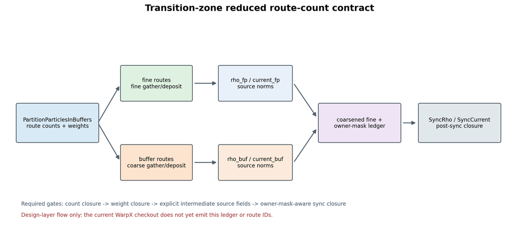

图 7-1：transition-zone reduced route-count 合同的计划数据流。粒子分区先产生 fine/buffer route counts 和 weights，再分别记录 `rho_fp/current_fp` 与 `rho_buf/current_buf`，最后经过 coarsened-fine、owner-mask 和 `SyncRho/SyncCurrent` 形成 post-sync closure。图中流程是设计层接口，不表示当前 checkout 已有 runtime 输出。

### 7.7.8 本章正文与源码同步合同

本章的正文-源码对应关系由 `scripts/audit_boundary_amr_chapter_source_crosswalk.py` 维护。它把 field/particle 参数顺序、PEC/PMC/Silver-Mueller/PECInsulator 分派、PML 生命周期、通信与 guard-cell 预算、AMR 重建、moving window、粒子 scraping 以及 transition-zone 未完成边界固定成 13 组可重复检查。该脚本检查的是代表性入口和证据边界是否仍与正文一致，不是 C++ 语义等价证明，也不是 runtime route-count proof。

后续修改本章时，应同时更新正文、`notes/code-reading/boundary/05-boundary-amr-chapter-source-crosswalk.md` 和脚本输出的 `contract.json`/`contract.md`。特别要保留两条区分：PML exchange/guard-cell 入口不等于 transition-zone route ledger；AMR/MR 的整体末态 regression 也不等于 `fine_gather/coarse_gather/fine_deposit/coarse_deposit` 分支已被专门逐项命中。 官方 `test_2d_subcycling_mr` 也已完成当前 checkout 的 2-rank、250 步运行。独立脚本 `scripts/analyze_subcycling_mr_contract.py` 读取初末 `diag1000000/diag1000250`：末态为两层 AMR、`64x256x1`，E/B/J 在 finest covering grid 上全部 finite；moving window 的实际 z 位移为 `1.9453125e-5 m`，而 `c*t=1.9529297e-5 m`，误差 `7.6171875e-8 m`，不超过 coarse `dz=7.8125e-8 m`；最终 `driver/beam/plasma_e/plasma_p` 粒子数分别为 `10000/10000/30218/31872`。初始诊断帧尚未包含连续注入的两个 plasma species，脚本将其记录为初始化时序而非失败。该 contract 只支撑 subcycling+MR+moving-window 的运行完整性和几何时间一致性，不支撑 transition-zone route-count、fine/coarse 电荷守恒或粒子 gather/deposition 分区证明。报告归档于 `runs/stage-c-validation/subcycling_2d_mr_mpi2/contract.{json,md}`。

# 8. 诊断、验证与案例

PIC 程序的可信度来自验证，而不是来自输入文件能跑完。一个最小验证闭环需要回答：

- 初始条件是否表达了目标物理问题；
- 网格、粒子数、时间步是否分辨关键尺度；
- 输出量是否足以检查守恒律和不稳定性；
- 结果是否能和解析解、benchmark、regression 或文献对比；
- 源码路径是否确实是本次运行用到的路径。

本书当前第一批推荐案例是 Langmuir wave、uniform plasma 和 LWFA/PWFA。

在进入具体案例前，可以先记住 Dawson 1983 对 diagnostics 的一个老判断：simulation 的目标是 physics essence，而不是 detail。也就是说，diagnostics 的价值不在于“把所有字段和粒子都写出来”，而在于能否把大规模数值状态压成可解释的 observables、谱、守恒量和 reader-side 证据。对二维和三维模型，这种 diagnostics / visualization / postprocessing 的难度甚至可能不低于模型本身。这条判断和当前 WarpX worktree 的结构很一致：full diagnostics、reduced diagnostics、back-transformed diagnostics、checkpoint 以及 openPMD/plotfile reader-side analysis，都不该只按 writer 类型分类，而应按“是否真正提炼出目标 physics”来理解。

同一篇综述还给了 diagnostics 的另一条很有价值的组织方式：先分 `measurements related to particle motion`，再分 `measurements related to waves`。前者典型的是 distribution function、phase space、drag、velocity diffusion；后者典型的是 field fluctuation level、time correlations、power spectrum 与 nonuniform-plasma normal modes。这种分法比“plotfile/reduced/openPMD/BTD”更接近物理问题本身，因为它直接对应读者真正要问的量：是想测输运系数、相关时间、噪声底、谱线，还是想重建某个本征模的空间结构。后面各案例如果只停在“输出了哪类文件”，而不说明它到底在测哪一类物理量，diagnostics 章节就会失焦。

`Dawson 1983` 后面的统计理论 examples 又把这条 diagnostics 思路压得更具体：这些 drag、diffusion、field-fluctuation 和 correlation measurements，不只是“可以输出的量”，而是 simulation 用来直接检验 subtle plasma statistics 的观测合同。作者甚至特意把一维 electrostatic sheet model 提出来当高精度 benchmark，因为它不需要 grid、可把 point-particle dynamics 跟到近 machine accuracy。于是 diagnostics 章节里有一条很值得保留的边界：reader-side analysis 的对照对象不一定只有解析式，也可以是更 fundamental、近 exact 的 particle model。这一点对后面理解 noisy thermal backgrounds、transport coefficients 和 fluctuation measurements 特别重要。

把这条统计 diagnostics 再压实一点，Dawson 给出的最小测量合同其实已经很完整：

- drag
  - 不是看单粒子轨道，而是固定窄速度窗口后测群体平均速度衰减；
- velocity diffusion
  - 不是任意时段都能读系数，而要先识别 `\tau^2` 的 short-time regime 和 decorrelation 后的近线性 regime；
- field fluctuations
  - 不是先看整张场图，而是先看每个 `k` mode 的 time-averaged modal energy 是否满足热平衡与 shape-modified fluctuation 预期。

这条合同对当前 worktree 的意义很直接：后面不论是 `uniform_plasma` 的 noisy thermal background、Langmuir family 的 fluctuation floor，还是 thermal-plasma energy/stability families，都更应该被组织成“这些 reader-side measurements 能否稳定恢复理论里真正关心的统计量”，而不是“导出了哪些字段文件”。

如果再往前推进一层，Dawson 的 wave-side diagnostics 还要求继续区分：

- power spectrum：
  - 是 Debye-cloud random continuum 还是 collective plasma spike；
- time correlations：
  - 对应的 wave memory / decorrelation time 多长；
- magnetized peaks：
  - 是 Bernstein、upper-hybrid、ion-cyclotron、lower-hybrid，还是 `\omega=0` 的 convective-cell / charged-flux-tube 结构。

这对本章的直接约束是：thermal / noisy plasma diagnostics 不该只停在 field RMS 或总场能量上，而应继续追问谱线形状、linewidth、相关时间和 peak taxonomy。否则我们只能知道“有噪声”，却不知道噪声究竟来自随机 continuum、热平衡模、磁化谐波，还是低频结构化 cells。

对 nonuniform plasma，Dawson 又把这条 diagnostics 合同推进了一步：reader-side analysis 的目标不只是标出某个 `\omega` 上“有一条峰”，而是重建该峰对应的空间波函数。做法是先记录 `\phi(\mathbf r,t)`、`\mathbf E(\mathbf r,t)` 或 `\mathbf B(\mathbf r,t)`；若系统在某个方向上均匀，就先沿该方向 Fourier 分解，再在剩余坐标上分析 `\phi(k_x,y,\omega)` 这类量。对离散谱线 `\omega_1`，可以把信号分别与 `\sin\omega_1 t` 和 `\cos\omega_1 t` 做相关积分，从而恢复 mode amplitude 和 phase profile。这里有个很硬的 measurement boundary：积分窗口 `T` 必须短于该 mode 的 damping time，否则初始 coherent oscillation 衰减后、由随机粒子运动重新激发的任意相位会把空间相位结构洗掉；长运行应拆成多个短窗口再平均，而不是简单延长一次积分。对连续谱也不能一概当噪声处理，因为其中既可能出现局域在某一小块等离子体区域的 localized oscillations，也可能只是 random particle motion 的 continuum；后者就必须继续测 `\delta v(\mathbf v,x,\omega)` 这类 kinetic quantity，而不能只停在势场或电场谱图。

这一点又和 noisy start / quiet start 的工程边界连在一起。Dawson 明确指出，对 weak instability，random start 的主要问题不只是“图更吵”，而是它会直接限制增长率测量的动态范围：给定 `k` 模的初始涨落通常是 `N^{-1/2}` 量级，而弱不稳定最终可能只长到不到百分之一到几个百分点，于是总共可用的指数增长窗口只有有限的 `\gamma t`。作者给出的数量级判断是 `\gamma t \sim \frac{1}{2}\ln N`；即便 `N=10^5`，典型也只有大约 `5` 个 e-foldings，因此增长率往往只能测到二十个百分点量级，对更弱的不稳定性甚至会被 natural noise 直接淹没。更具体地说，纯随机空间加载还会强烈过激发 small-`k` long-wavelength electrostatic modes，因为它没有体现 Debye shielding 和局域电中性；这说明 quiet-start 或 cell-neutral loading 的意义不只是“让初值更平滑”，而是把 weak-effect measurements 的可识别动态范围从噪声底里救出来。

### Dawson 统计诊断链：从 modal energy 到 normal-mode reconstruction

Dawson 1983 的统计理论 examples 还给出了一条可以直接移植到现代 reader-side analysis 的 wave-side 诊断链。第一层不是把整张场图压成一个 RMS，而是对每个 Fourier mode 计算 time-averaged modal energy；第二层把同一 mode 的时间序列变成 power spectrum，用来区分随机粒子运动形成的连续谱和 collective plasma oscillation 形成的离散尖峰；第三层计算时间相关函数，测量 phase memory 和 decorrelation；第四层在非均匀等离子体中重建 mode 的空间波函数。四层分别回答“能量有多大、是哪类频率结构、记忆持续多久、空间上究竟是哪一个本征模”。

对单个波数 `k`，相关函数可写为

$$C(k,\tau)=\lim_{T\to\infty}\frac{1}{T}\int_0^T E(k,t)E(k,t+\tau)\,dt,$$

其对应的谱密度满足 Wiener–Khintchine 型关系

$$G(k,\omega)=4\int_0^\infty C(k,\tau)\cos(\omega\tau)\,d\tau.$$

因此 power spectrum 和 time correlation 不是两个互不相关的后处理图，而是同一 fluctuation process 的频域/时域表示。有限 run length `T` 还给出不可绕过的频率分辨率边界 `\Delta\omega\simeq 1/T`：如果 `1/T` 大于目标谱线宽度，所谓 peak width 主要是窗函数和有限样本造成的，不能直接当成物理 damping rate。对长期运行，应按多个短窗口分别估计，再把统计量汇总，而不是盲目延长一个相位已经失真的积分窗口。

在磁化等离子体中，peak taxonomy 本身也是物理结果。Bernstein harmonics、upper-hybrid、ion-cyclotron、lower-hybrid，以及 `\omega=0` 附近的 convective-cell / charged-flux-tube 结构，不能统一归类为“噪声峰”；它们需要结合外磁场、species mobility 和空间结构共同解释。对非均匀等离子体，若沿均匀方向先做 Fourier 分解，可在剩余坐标上构造 `\phi(k_x,y,\omega)`；再把离散频率 `\omega_1` 的信号分别与 `\sin\omega_1t`、`\cos\omega_1t` 做相关积分，就能恢复 mode amplitude、phase 和空间波函数。这里的积分窗口必须短于该 mode 的 damping time，否则初始 coherent oscillation 衰减后，随机粒子运动重新激发的任意相位会把空间结构洗掉。

continuous spectrum 也不能自动当成无意义的背景。它可能包含局域在某一小块等离子体区域的真实振荡，也可能只是随机粒子运动的 continuum；后者需要进一步观察 `\delta v(\mathbf v,x,\omega)` 等 kinetic observable，而不是只凭势场或电场谱下结论。对 weak instability，随机初态的 `N^{-1/2}` 模涨落还会消耗可用的指数增长窗口，数量级上 `\gamma t\sim\frac12\ln N`；quiet-start / cell-neutral loading 的价值因此是提高可识别动态范围，而不是保证所有后续演化都更物理。上述统计链来自项目内 `Dawson 1983` 中文讲解的第 22、24–26、53–59 节；它支撑的是 diagnostics 设计原则，不替代当前 WarpX 各案例已有的具体 runtime gate。 此外，`Birdsall 1985` 的 `13-6` 提醒我们：即使线性介电关系显示稳定，相对漂移仍可能把自由能转入非线性相空间 clump 与 density hole；因此接近稳定阈值的案例还应保留 phase-space correlation 观察，而不能只看场能量或把它直接归类为 NCI。

再往实现层压一步，Dawson 给的 quiet-start recipe 也不是抽象建议，而是明确的 phase-space construction：把相空间切成 cells，把每个空间 cell 内的目标速度分布 `P(v)` 归一到该 cell 的粒子数，再把 `P(v)` 分成等面积小区间，每个区间放一个粒子并赋予相应代表速度。对任意目标分布，还可以先构造 cumulative map `y(v)=\int_{-\infty}^{v}P(v')\,dv'`，再用其反函数把 `[0,1]` 上的均匀变量映射成所需速度分布。这说明 diagnostics 一侧讨论 noisy/quiet starts 时，不能只写“quiet start 降噪”，还要看到它真正交换掉了什么：它用更规则的有限粒子 phase-space covering 换取更大的 weak-effect dynamic range，但简单的 equal-area placement 对 tail 或低密度关键区域的分辨能力有限，于是后面才需要 weighted particles / many-size electrons 继续补这条短板。

## Langmuir wave

入口：`../warpx/Examples/Tests/langmuir/inputs_test_1d_langmuir_multi`

关键设置：

- `max_step = 80`
- `geometry.dims = 1`
- `boundary.field_lo = periodic`
- `boundary.field_hi = periodic`
- `algo.field_gathering = energy-conserving`
- `algo.current_deposition = esirkepov`
- 电子和正电子两个 species，密度 `n0 = 2.e24`

这个例子适合检查等离子体振荡频率、沉积和 Gauss 定律误差。输入中定义

$$\omega_p=\sqrt{\frac{2n_0 e^2}{\epsilon_0 m_e}},$$

这里的因子 2 来自电子和正电子两种可动带电粒子的对称贡献。动量微扰用正负相反的三角函数给出，使两个 species 产生相反响应。

图 8-1 给出本地 81 个快照验证树末态的数值电场与解析场对照。两幅图使用同一纵轴尺度：左图为 simulation，右图为 theory。这个图只承担 reader-side 的波形 sanity check；严格的场误差、最终 Gauss-law 误差和频率拟合数值仍以紧随其后的报告和 gate 为准。

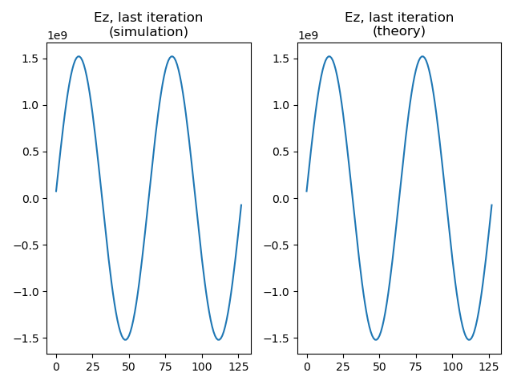

图 8-1 的数据来自 `runs/stage-c-validation/langmuir_frequency_fit/langmuir_multi_1d_analysis.png`，由官方 Langmuir 输入和 `scripts/analyze_langmuir_frequency_fit.py` 生成；图像被复制到书稿专属 `manuscript/assets/figures/` 目录，避免正文依赖运行目录中的临时文件。

当前本地 Langmuir 验证树已经比这个 1D 入口更大。1D/2D/3D/RZ 原生输入族分别复用 `analysis_1d.py`、`analysis_2d.py`、`analysis_3d.py`、`analysis_rz.py`，因此共享同一个“解析场解逐点比较”的主合同；其中 3D 版本还额外检查 selective particle output 和 openPMD 粒子位置上的 `Ex/Ey/Ez` 场采样。`analysis_utils.py` 又把 charge-conservation 检查做成条件分支，只在 Esirkepov、Vay deposition 或 PSATD current-correction 这些适用组合下强制比较 `divE` 与 `rho/\epsilon_0`。与之并列的 `langmuir_fluids` 则是另一棵冷流体验证树：它不只看 `E`，还把 `J` 和 `rho` 一起与解析冷流体解比较。需要单独记住的是，2D/3D/RZ 的 PICMI 变体目前大多仍是 `analysis=OFF` 的前端 + checksum scaffold，不应和原生输入的强物理断言混成同一等级。

从应用综合章的角度，Langmuir wave 的价值不只是“有一个 textbook 解析解”，而是它把当前 worktree 里的四条主线挂到了同一个最小物理问题上：

1. 初始化
   - `NUniformPerCell`
   - `profile = constant`
   - `parse_momentum_function` 共同决定冷等离子体微扰如何进入粒子。
2. 粒子推进与沉积
   - `energy-conserving gather`
   - `Esirkepov`、`Vay deposition`
   - `momentum-conserving gather` 在这个最小问题上暴露 `divE-rho/\epsilon_0` 误差。
3. 场求解
   - FDTD
   - PSATD
   - `current_correction`
   - `JRhom` 都能在同一解析波形下做最小分支验证。
4. 诊断与 reader-side analysis
   - plotfile/full diagnostics
   - openPMD
   - selective particle output
   - on-particle `Ex/Ey/Ez` 都已经有现成 analysis 脚本消费。

这也是为什么 `Examples/Tests/langmuir/` 在当前项目里不是“一个普通回归目录”，而是应用综合章最适合先收口的第一条主线。它已经把：

```
冷等离子体解析振荡
-> parser 初始化
-> gather / pusher / deposition / solver
-> diagnostics / openPMD reader
-> MR / PSATD / current correction / JRhom / PICMI / fluids 分支
```

压在了同一个最小问题上。

到 2026-05-18 为止，这条主线已经不只停在源码和 analysis 脚本层，也有了第一条本地运行记录。当前在

- `PIC-tutor/runs/stage-c-validation/langmuir_1d`

用

```bash
env OMP_NUM_THREADS=1 FI_PROVIDER=tcp \
  $WARPX_ROOT/build_full/bin/warpx.1d.MPI.OMP.DP.PDP.OPMD.FFT.EB.QED.GENQEDTABLES \
  $WARPX_ROOT/Examples/Tests/langmuir/inputs_test_1d_langmuir_multi
```

完成了真实运行，并生成 `diags/diag1000080`。虽然官方 `analysis_1d.py` 因本机缺 `matplotlib/yt` 没有原样跑通，但它的核心断言已经按同一公式手工复现：

- 解析场相对误差 `error_rel = 1.70e-3 < 5e-2`
- `divE-rho/\epsilon_0` 相对误差 `8.35e-12 < 1e-11`

所以 `Langmuir wave` 现在在本项目里已经是运行级强基准，而不只是“源码上看起来应该能验证”的强基准。

## Uniform plasma

入口：`../warpx/Examples/Physics_applications/uniform_plasma/inputs_test_2d_uniform_plasma`

关键设置：

- `max_step = 10`
- `geometry.dims = 2`
- 周期场边界
- 单电子 species
- 常密度 `1.e25`
- gaussian 动量分布，`ux_th = uy_th = uz_th = 0.01`

这个例子更适合检查并行分解、粒子噪声、诊断输出和性能路径。因为物理结构简单，任何明显的非均匀场增长、粒子丢失或能量异常都容易被发现。

但当前本地 `uniform_plasma` 目录里的 regression 边界需要写得更精确。`test_2d_uniform_plasma` 和 `test_3d_uniform_plasma` 在 `CMakeLists.txt` 中都没有独立 analysis，实际只依赖顶层 `Examples/analysis_default_regression.py` 提供 checksum 基线；因此它们更像是“full diagnostics / 并行噪声 / 最小工作流稳定性”基准，而不是独立的热等离子体物理 hard assert。真正的强断言在 `test_3d_uniform_plasma_restart`：它从 `chk000006` 恢复，再用 `Examples/analysis_default_restart.py` 逐字段比较 restart 与非 restart 输出，要求相对误差低于 `1e-12`。另外，名字里带 `uniform_plasma` 的 `test_3d_uniform_plasma_psatd_JRhom_CC1` 并不属于这个应用目录，而是 `nci_psatd_stability` 里的 PSATD 稳定性回归，它检查的是 `JRhom=CC1 + div cleaning` 后电场能量是否足够小，从而证明 NCI 被压制，而不是均匀热等离子体本身的统计性质。

这意味着 `uniform_plasma` 在应用综合章里最准确的角色不是“单一 physics benchmark”，而是最小热背景 workflow：

1. 均匀、周期、单 species 的 thermal background
   - 给粒子噪声和并行划分提供最低复杂度基线；
2. full diagnostics
   - 给 plotfile/openPMD 风格输出提供最小 reader-side 骨架；
3. checkpoint/restart
   - 给 `analysis_default_restart.py` 提供一条极干净的 field-level reproducibility 基准。

如果把 `TODO` 里的“噪声、能量、性能和诊断”拆开，当前工作树里的证据来源其实是分层的：

- 噪声、性能背景、writer/checkpoint：
  - 主要来自 `Examples/Physics_applications/uniform_plasma/`
- 热等离子体总能量强断言：
  - 主要来自相邻 `Examples/Tests/energy_conserving_thermal_plasma/`
- PSATD/JRhom 稳定性强断言：
  - 主要来自相邻 `Examples/Tests/nci_psatd_stability/`

因此 `uniform_plasma` 的真正价值，不是它自己包含了所有强 analysis，而是它把：

```
均匀热背景
-> 粒子噪声 / 并行稳定性
-> full diagnostics / checkpoint
-> restart reproducibility
-> 与能量守恒、PSATD 稳定性测试树的边界
```

压成了项目里第二条最适合成文的应用主线。

到 2026-05-18 为止，这条主线也已有一条最小本地运行记录。当前在

- `PIC-tutor/runs/stage-c-validation/uniform_plasma_2d`

用

```bash
env OMP_NUM_THREADS=1 FI_PROVIDER=tcp \
  $WARPX_ROOT/build_full/bin/warpx.2d.MPI.OMP.DP.PDP.OPMD.FFT.EB.QED.GENQEDTABLES \
  $WARPX_ROOT/Examples/Physics_applications/uniform_plasma/inputs_test_2d_uniform_plasma
```

完成了真实运行，并生成 `diags/diag1000010`。但这里必须保持验证分级：

- 主程序运行成功，只能证明 workflow、writer、最小噪声背景和输出路径正常；
- 官方 regression 本来就只有 `analysis_default_regression.py --path diags/diag1000010` 这一层 checksum；
- 这轮历史运行记录没有复跑 checksum 脚本；当前环境已有 `yt`，但仍缺 `openpmd_viewer`，所以 openPMD 分支仍未在本地验证。

所以 `uniform_plasma` 当前在本项目里的最准确状态仍然是：

- 已有运行级 baseline；
- 尚不是独立物理解强断言；
- 它的强 physics closure 仍需借相邻 `restart`、`energy_conserving_thermal_plasma` 和 `nci_psatd_stability` 三棵树来补齐。

### 2026-07-12：checkpoint/restart 的真实证据

为了把上面的 restart 说明从源码和 CMake wiring 推进到运行级证据，本项目在 `runs/stage-c-validation/uniform_plasma_3d_mpi2/` 复现了同一组 3D 输入：基线从第 0 步运行到第 10 步，并在第 6 步写出 `diags/chk000006`；restart sibling 从该 checkpoint 继续运行到第 10 步。两条路径最终都写出 `diags/diag1000010`。

官方 `../warpx/Examples/analysis_default_restart.py` 与项目内 `scripts/analyze_uniform_plasma_restart.py` 都对两个末态 plotfile 的 level-0 covering grid 逐字段比较。共比较 37 个 field，包含 `Bx/By/Bz`、`Ex/Ey/Ez`、`jx/jy/jz`、`rho`，以及 `electrons` 的粒子位置、动量、权重和粒子 ID；独立 reader-side 对照的最大绝对误差为 `2.4414e-4`，最大相对误差为 `2.8631e-16`，通过官方 `1e-12` 容差。绝对误差来自量纲较大的场/电流数组，不能脱离相对误差单独解释。

这一证据有两个必须同时保留的边界。第一，它直接证明的是 checkpoint 状态恢复、粒子/场续跑和末态 diagnostics 的 reproducibility，不是热平衡能量守恒或某个解析波的 physics gate。第二，WarpX 的 CMake 注册把该测试配置为 2-rank MPI；本轮已用本机 MPICH `mpiexec -n 2` 按官方兄弟目录布局真实补跑。官方 `analysis_default_restart.py` 对 37 个 field 全部通过，独立 reader-side 对照的最大相对误差为 `2.8631e-16 < 1e-12`。但仓库 checksum API 的 rank-specific 聚合参考与本地 2-rank producer 不一致，最大相对差为 `3.20e-2`；因此这里应写成“2-rank restart reproducibility evidence”，同时保留 checksum 非通过边界，不能把逐字段 restart pass 扩大成 checksum pass。

为解释这一 checksum 边界，又用同一当前 WarpX binary 和官方输入分别生成 1-rank、2-rank 的非 restart 基线，并运行 `scripts/analyze_uniform_plasma_mpi_consistency.py`。两套 producer 的粒子总权重完全一致；field energy 相对差为 `1.9379e-2`，particle kinetic energy 相对差为 `8.9170e-4`，total energy 相对差为 `6.2269e-4`，physical-field 最大 L2 相对差为 `1.0185`。因此该 thermal/randomized uniform-plasma case 的 rank-invariant field contract 明确不成立，checksum 差异不能被解释成 restart 失败；本项目只把 2-rank restart 的 plotfile-to-plotfile 一致性写成通过证据。1-rank/2-rank 报告位于 `runs/stage-c-validation/uniform_plasma_3d_mpi2/uniform-plasma-mpi-consistency.{json,md}`。

图 8-11 将这条边界压成两个可读的面板：左图显示 2-rank 相对 1-rank 的全局能量比，右图显示 `B/E/J/rho` 各组 physical field 的最大 L2 相对误差。左图说明粒子动能和总能量仍接近，但右图说明逐场 rank-invariant gate 并未成立；虚线是参考值或 `1e-12` machine-level gate，不是本案例已经通过的物理阈值。

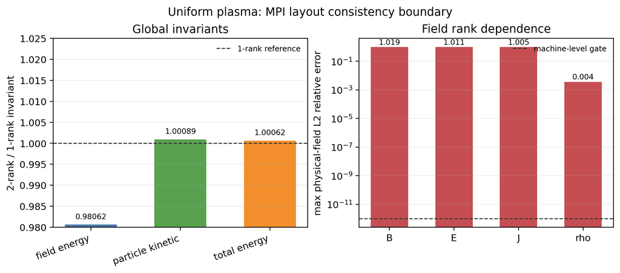

图 8-11 由 `scripts/plot_uniform_plasma_mpi_consistency.py` 从 `uniform-plasma-mpi-consistency.json` 重新生成；该图展示的是并行证据边界，不是新的强 physics benchmark。

## LWFA/PWFA

应用综合章的下一条主线不应再写成单独的 `plasma_acceleration`。当前本地 worktree 里，更准确的组织方式是把：

- `Examples/Physics_applications/laser_acceleration/`
- `Examples/Physics_applications/plasma_acceleration/`

并排视作同一类 wakefield acceleration runtime architecture 的两个分支：

1. `LWFA`
   - laser-driven
2. `PWFA`
   - beam-driven

它们共享的不是统一的 physics hard assert，而是非常相近的工程关注点：

- moving window
- boosted frame
- diagnostics
- mesh refinement
- PICMI/native front-end split

这一节现在还需要保留一条更早的文献边界：当前已经开始精读的 `Tajima-Dawson 1979` 并不是现代 `laser_acceleration` family 的 analysis blueprint，而是这条应用线最早期的 scaling baseline。它把 `laser pulse -> ponderomotive wake -> trapping -> acceleration` 这条最小物理闭环压得很硬，并给出

$$v_p = v_g^{EM} = c\sqrt{1-\frac{\omega_p^2}{\omega^2}},$$

$$L_t = \frac{\lambda_w}{2} = \frac{\pi c}{\omega_p},$$

$$eE_L \cong mc\omega_p,
\qquad
\gamma_{\max} \simeq 2\frac{\omega^2}{\omega_p^2},
\qquad
l_a \cong 2\frac{\omega^2 c}{\omega_p^3}.$$

这些式子最适合在本章里承担 `LWFA earliest scaling baseline` 的角色：它们解释为什么 wake phase velocity、dephasing、加速长度和 underdense-plasma driver 是同一条物理主线；但它们并不直接验证当代 WarpX 的 moving window、boosted frame、mesh refinement、openPMD 或 PICMI 前端实现。

同时，这篇文章也不是只有解析公式。当前精读已经确认它还给出了一个最小 relativistic electromagnetic PIC demonstration：`1 1/2-D`、one spatial dimension、three velocity/field dimensions、Gaussian finite-size particles、固定离子背景，并通过扫描 `\omega/\omega_p` 去对照最早期 scaling。文中数值结果至少压实了三件事：

1. wake longitudinal field 可达到
   $$E_L \sim 0.6\,\frac{mc\omega_p}{e},$$
   即冷等离子体 wave-breaking 级上限的大约 `60%`；
2. driver spectrum 会裂成多峰，作者明确解释为 successive / multiple forward Raman scattering，并把它和 photon deceleration、wake emission 联系起来；
3. simulation 中的最大电子能量随 `(\omega/\omega_p)^2` 的变化基本贴合解析式，只是在高端开始受有限系统大小和周期边界污染。

这进一步说明：`Tajima-Dawson 1979` 能作为 `LWFA` 的 earliest scaling 与 minimal EM-PIC demonstration 文献入口，但它仍不能替代现代 WarpX `laser_acceleration` family 的 runtime regression 合同。

文末还要再保留三条降级边界。第一，原文的 `feasible within present-day technology` 只是 1979 年语境下的工程可行性判断，后面立刻又承认 short-pulse shaping 仍需改进。第二，作者明确保留了 `\Delta\omega = \omega_p` 的 two-laser / beat-wave alternative，因此这篇文章更准确地支撑的是早期 wakefield family，而不是今天单一路径的单脉冲 `LWFA`。第三，pulsar atmosphere / cosmic-ray source 的段落只应当看作历史语境下的 speculative extrapolation，不能进入现代 WarpX 应用合同。

### LWFA：`laser_acceleration` 是 runtime matrix，不是统一 wake benchmark

`laser_acceleration/README.rst` 明确写的是 laser-wakefield acceleration，但 `Analyze` 章节仍是 `TODO`。配合 `CMakeLists.txt` 可以看出，当前这组目录更像是：

- 1D/2D/3D/RZ
- boosted frame
- moving window
- refined patch
- PICMI / Python callback
- openPMD diagnostics

这些路径的 `LWFA runtime matrix`。

当前只有三条局部强 analysis：

1. `analysis_1d_fluid_boosted.py`
   - 检查 boosted 1D 冷流体 `Ez/Jz/rho/Vz` 是否贴理论；
2. `analysis_refined_injection.py`
   - 检查 refined injection 的总粒子数和 refinement-edge 前方 `rho` 均匀性；
3. `analysis_openpmd_rz.py`
   - 检查 RZ openPMD diagnostics 的 mesh shape、species ordering 和 `rho_<species>` 物理中心。

其余大多数 active tests 都是 `analysis = OFF` 加 checksum baseline。因此，当前 `laser_acceleration` 目录更适合在本章承担：

- moving-window / boosted LWFA skeleton
- diagnostics / openPMD / MR / PICMI 路径覆盖

而不是完整的 wake amplitude、beam energy gain 或 laser diffraction 强 benchmark。

### PWFA：`plasma_acceleration` 是 workflow matrix，不是解析 wake benchmark

`plasma_acceleration/README.rst` 明确写的是 beam-driven wakefield acceleration，而不是 generic laser-plasma acceleration。这一点非常重要，因为它决定了这里的 driver 不是 laser antenna，而是 relativistic bunch。

当前目录的另一个硬边界是：

- `Analyze` 仍是 `TODO`
- `Visualize` 仍是 `TODO`
- 3D PICMI boosted-frame 等价性也被 `README.rst` 自己标成 `TODO`

同时，`CMakeLists.txt` 中所有 active tests 都是：

```
OFF  # analysis
"analysis_default_regression.py --path ..."
```

因此 `plasma_acceleration` 当前最准确的角色是：

- `PWFA workflow matrix`
- `beam-driven wakefield application baseline`

它覆盖了：

- moving window
- boosted frame
- rigid bunch
- density ramp / plasma channel
- `particles.use_fdtd_nci_corr = 1`
- mesh refinement
- hybrid grid
- PICMI front-end

但当前并没有目录内统一的 wakefield physics hard assert。尤其要保留一个源码树边界：3D PICMI 输入文件目前仍未像 native 输入那样真正使用 boosted frame，所以不能把它说成 native boosted PWFA 的等价前端。

### 当前 worktree 中这条应用主线真正成立的结论

把 `LWFA/PWFA` 重新收束之后，当前本地证据支持的最强结论是：

1. `laser_acceleration`
   - 是 `LWFA runtime matrix`
   - 强 analysis 只覆盖局部合同
2. `plasma_acceleration`
   - 是 `PWFA workflow matrix`
   - 当前 active tree 全部 checksum-only
3. 二者共享的主线不是统一 benchmark，而是：
   - moving window
   - boosted frame
   - diagnostics
   - MR
   - PICMI/native front-end split

这也意味着，后续书稿如果从应用角度组织 wakefield acceleration，最自然的章节结构不是简单按目录分，而是：

```
wakefield acceleration runtime architectures
-> laser-driven branch (LWFA)
-> beam-driven branch (PWFA)
```

## Laser ion / plasma mirror / RPA/TNSA

这一条应用主线必须写得比目录名更谨慎。当前本地 worktree 里真正可落到 application tree 的 laser-target 入口只有两个：

- `Examples/Physics_applications/laser_ion/`
- `Examples/Physics_applications/plasma_mirror/`

而 `RPA/TNSA` 当前并没有独立应用目录或回归树，只是：

- `laser_ion/README.rst` 背后的物理机制标签；
- `Docs/source/glossary.rst` 里的术语定义。

### `laser_ion`：最强的 laser-target application entry

`laser_ion` 的真实角色不是“已经证明某条 ion-acceleration scaling”，而是：

- Gaussian laser
- planar solid-density target
- full diagnostics
- time-averaged diagnostics
- reduced diagnostics
- PICMI front-end

这条组合工作流的本地入口。

当前它在 CI 里的最硬断言来自 `analysis_test_laser_ion.py`，检查的是：

- `diagInst` 最后 5 个瞬时 `Ez` snapshot 的时间平均
- 与 `diagTimeAvg` 的原位 time-averaged `Ez` 是否逐点一致

因此它当前最强的 regression 合同是：

- diagnostics time-average consistency

而不是：

- TNSA cutoff energy
- RPA threshold
- ion conversion efficiency

README 里的 `analysis_histogram_2D.py` 和 `plot_2d.py` 仍然很重要，但它们当前属于 user-facing post-processing helper，不是活跃 CI regression 本体。

还要再保留一个细边界：`laser_ion` 确实已经有 PICMI 版输入，但其 reduced diagnostics 能力和 native 版并不完全对齐，例如 PICMI 脚本里仍留有 `ParticleHistogram2D` 的 TODO。因此更准确的说法是：

- PICMI 已覆盖主工作流与 `analysis_test_laser_ion.py` 合同；
- 但前端能力还没有完全追平 native input。

### `plasma_mirror`：laser-solid surface-plasma workflow baseline

`plasma_mirror` 当前应用语义很明确：

- laser-solid interaction
- surface plasma
- planar overdense target

但验证层级明显更弱：

- 只有 `test_2d_plasma_mirror`
- `analysis = OFF`
- checksum helper
- 没有 PICMI
- `README.rst` 的 Analyze/Visualize 仍是 `TODO`

因此它更准确的角色是：

- laser-solid surface-plasma workflow baseline

而不是：

- reflectivity benchmark
- high-harmonic benchmark

### `RPA/TNSA`：当前属于物理解释层，不属于本地应用目录层

这条边界如果不写清，很容易把文献中的机制标签误写成当前 worktree 已有的独立本地 examples。当前最强、也最保守的结论只能是：

1. `laser_ion`
   - 是激光打固体平面靶的本地应用骨架；
2. `RPA/TNSA`
   - 是理解这类骨架时需要引入的机制标签；
3. 当前 `Examples/` 中
   - 没有独立 `rpa_*`
   - 也没有独立 `tnsa_*` application tree。

因此，这条应用综合章在当前 worktree 里更准确的组织方式是：

```
laser-target applications
-> laser_ion
-> plasma_mirror
-> RPA/TNSA as mechanism labels, not standalone local trees
```

## Capacitive discharge

这条应用线在当前 worktree 里不该再混成普通 `collision/*` 附属条目。它更准确的角色是：

- `PIC-MCC low-temperature plasma application tree`

因为它同时把以下对象接到同一应用骨架上：

- parallel-plate electrostatic discharge
- `background_mcc`
- 可选 DSMC ionization 分支
- PICMI front-end
- Python callback Poisson solver
- Turner benchmark profile 对照

### 1D PICMI 是当前最强的 Turner benchmark 入口

当前最强的两条 active tests 是：

- `test_1d_background_mcc_picmi`
- `test_1d_dsmc_picmi`

它们共用同一条脚本：

- `inputs_base_1d_picmi.py`

这不是普通薄输入卡，而是完整的 benchmark driver：

1. 选择 Turner case `N=1..4`
2. 组装 1D electrostatic grid
3. 可选安装 Python level Poisson solver callback
4. 打开 `background_mcc`
5. 可选把 ionization 切成 DSMC
6. 累积离子密度并写出 `ion_density_case_N.npy`

当前 CI `--test --pythonsolver` 模式下还会显式确认：

- callback solver 已经实际运行；
- `he_ions` 的 `z` 坐标访问链可用。

因此这条应用树在工程上也不只是低温等离子体 benchmark，同时还是本地最直接的：

- PICMI + Python callback Poisson solver

应用入口之一。

### 当前最硬断言是 case-1 ion-density profile

`analysis_1d.py` 和 `analysis_dsmc.py` 当前都直接读取：

- `ion_density_case_1.npy`

并与内置 Turner case-1 参考离子密度 profile 做 `allclose`。

因此当前 worktree 里最强的 physics contract 是：

- final averaged ion density profile
- against Turner benchmark case 1

而不是笼统的“有 MCC test”或“有 DSMC test”。

### DSMC 版不是孤立小 test，而是同一 benchmark scaffold 的分支

这两条 1D tests 共享同一应用骨架，区别只在于 collision realization：

1. `test_1d_background_mcc_picmi`
   - `background_mcc`
   - external Python Poisson solver callback
   - Turner case-1 profile 对照
2. `test_1d_dsmc_picmi`
   - 把 ionization 切到 DSMC 分支
   - 仍回到同一 Turner case-1 profile 对照

因此更准确的表述是：

- DSMC 分支已经在同一低温等离子体 benchmark scaffold 里被强对照覆盖

而不是只证明“DSMC can run”。

### 2D native / PICMI 当前仍主要是 workflow baseline

与 1D 强对照相比，当前 2D 分支只有：

- `test_2d_background_mcc`
- `test_2d_background_mcc_picmi`

并且两者都是：

- `analysis = OFF`
- checksum helper

因此它们当前只能诚实记成：

- `2D capacitive-discharge workflow baseline`

而不是 2D Turner 强 benchmark。另一个必须保留的边界是：

- `test_2d_background_mcc_dp_psp`

当前整条 `add_warpx_test(...)` 仍被注释掉，所以它只能作为遗留分支记录，不能再冒充活跃 test。

### 既有 `plasma_acceleration` 目录边界

入口：`../warpx/Examples/Physics_applications/plasma_acceleration/inputs_test_3d_plasma_acceleration_boosted`

这一组也需要避免被过度解读。当前本地 `plasma_acceleration` family 在 `CMakeLists.txt` 中所有活跃 tests 都是 `analysis = OFF`，只复用目录内的 `analysis_default_regression.py` 做 checksum。因此它们不是 “PWFA 解析 benchmark”，而是应用工作流基线。

但它们并不空泛。原生输入和 PICMI 输入合起来，已经覆盖了：

- moving window
- boosted frame
- rigid-injected `driver/beam`
- `particles.use_fdtd_nci_corr = 1`
- level-1 refined patch / `add_refined_region(...)`
- `momentum-conserving` gather 分支
- `grid_type = hybrid`
- field / particle diagnostics

因此这组例子当前真正承担的角色是：给 beam-driven wakefield acceleration 的 runtime matrix 保留稳定输出基线，而不是直接对 wake amplitude、dephasing 或 beam loading 做强物理断言。还有一个需要显式保留的源码树边界是：`README.rst` 目前明确写着 3D PICMI 版“应该像原生输入一样使用 boosted frame，但仍是 TODO”。所以 `inputs_test_3d_plasma_acceleration_picmi.py` 当前只能诚实记成 non-boosted PICMI scaffold，不能误写成原生 boosted PWFA 的等价前端。